# Analysis for RNA-seq and ATAC-seq data in Amiri et al 2026

Ezra amiri & Muzi Li

05/02/2026

This Rmd will cover analysis/results for Amiri et al 2026

There are 4 sections

1. WT timecourse (TC) ATAC-seq
2. Cal-opa KD ATAC- and RNA-seq
3. Cal-zld KD ATAC-seq and RNA-seq data
4. Gene loci visualization

# Clean Env & Load packages

```r
suppressPackageStartupMessages({
library(BSgenome.Calbipunctata.Cantata.uni4000)
library(SummarizedExperiment)
library(DESeq2)
library(DEGreport)
library(GenomicRanges)
library(GenomicAlignments)
library(GenomicFeatures)
library(Rsamtools)
library(tidyverse)
library(stringr)
library(ggplot2)
library(ggthemes)
library(ggpubr)
library(dplyr)
library(writexl)
library(readxl)
library(seqLogo)
library(ggvenn)
library(ggrepel)
#library(ballgown)
library(Glimma)
library(Gviz)
library(zoo)
library(rtracklayer)
#library(topGO)
#library("apeglm")
#library(pheatmap)
#library(stats)
#library(beeswarm)
})

library(ChIPseeker)
library(here)
```

## Load Data used throughout the analysis

### Peaks

Peaks were called using open reads (<= 120 bp) from all WT NC11:LNC14 samples. These are the master peaks.

```r
load("../GRanges/peaks-32157.GRanges.R")
```

### all.coldata

Load the coldata data frame (df) containing meta data for all samples in each experiment set.

```r
all.coldata <- as.data.frame(read_xlsx("../all-coldata.xlsx", sheet = 1, col_names = TRUE))

head(all.coldata)
```

```
##    Sample.name.full embryo treatment.group alignment injection Stage Dev.time
## 1  wt.1.mat.RNA.TC1      1              wt     FALSE      none   mat    0h46m
## 2  wt.2.mat.RNA.TC1      2              wt     FALSE      none   mat    0h47m
## 3  wt.3.mat.RNA.TC1      3              wt     FALSE      none   mat    0h48m
## 4  wt.4.mat.RNA.TC1      4              wt     FALSE      none   mat    0h49m
## 5 wt.1.NC11.RNA.TC1      5              wt     FALSE      none  NC11    4h21m
## 6 wt.2.NC11.RNA.TC1      6              wt     FALSE      none  NC11    4h22m
##   Experiment Experiment.Date ATAC.and.RNA TDE.ref.lot.num sample.id.atac
## 1     RNA-TC          230426     rna only            <NA>             NA
## 2     RNA-TC          230426     rna only            <NA>             NA
## 3     RNA-TC          230426     rna only            <NA>             NA
## 4     RNA-TC          230426     rna only            <NA>             NA
## 5     RNA-TC          230426     rna only            <NA>             NA
## 6     RNA-TC          230426     rna only            <NA>             NA
##      sample.id.rna sample.id.rna.2 instrument.atac.data instrument.rna.data
## 1 23003FL-09-01-01              NA                   NA      NovaSeq X Plus
## 2 23003FL-09-01-02              NA                   NA      NovaSeq X Plus
## 3 23003FL-09-01-03              NA                   NA      NovaSeq X Plus
## 4 23003FL-09-01-04              NA                   NA      NovaSeq X Plus
## 5 23003FL-09-01-05              NA                   NA      NovaSeq X Plus
## 6 23003FL-09-01-06              NA                   NA      NovaSeq X Plus
```

## Annotation Data

This will be used throughout the analysis.

### All annotation data table

This table has all the information from the annotation; gene,features of a gene, seed ortholog, GOs,COgs,KEggs etc.

```r
merge.data.file <- "../Annotation_Data/Clogmia.MergedData.csv"
merge.data <- read.csv(merge.data.file)
#head(merge.data)
```

### blast data

This table contains the identified Drosophila melanogaster (Dme) homolgos from reciprocal blastp searches. Some notes: Not every transcript has a Dme hit. Sometimes there are ties, this can occur for similar amino acid sequences generated by transcript isoforms of the same gene or by paralogs. For ties the best 1:1 match will say “bidirectional” in the “Directionality” column and the name of that transcript will be listed in the “Cal HIT” column. Flybase IDs are included in the “flybase.id” column.

```r
blast.file <- "../Annotation_Data/Clogmia.blast.csv"
blast.data <- read.csv(blast.file)
row.names(blast.data)<-blast.data$ID
head(blast.data)
```

```
##                                            ID        Dme.HIT
## evm.TU.scaffold_1.10     evm.TU.scaffold_1.10              -
## evm.TU.scaffold_1.100   evm.TU.scaffold_1.100              -
## evm.TU.scaffold_1.1000 evm.TU.scaffold_1.1000 NP_001260724.1
## evm.TU.scaffold_1.1001 evm.TU.scaffold_1.1001    NP_725699.1
## evm.TU.scaffold_1.1002 evm.TU.scaffold_1.1002    NP_610988.1
## evm.TU.scaffold_1.1003 evm.TU.scaffold_1.1003    NP_524106.3
##                                                     Cal.HIT  Directionality
## evm.TU.scaffold_1.10                                      -          No Hit
## evm.TU.scaffold_1.100                                     -          No Hit
## evm.TU.scaffold_1.1000            evm.model.scaffold_1.1000 uni-directional
## evm.TU.scaffold_1.1001 evm.model.scaffold_1.1001.1.65be597a uni-directional
## evm.TU.scaffold_1.1002            evm.model.scaffold_1.1002   bidirectional
## evm.TU.scaffold_1.1003 evm.model.scaffold_1.1003.8.65be5ad1   bidirectional
##                            dme.hits  flybase.id gene_name
## evm.TU.scaffold_1.10              -           -      <NA>
## evm.TU.scaffold_1.100             -           -      <NA>
## evm.TU.scaffold_1.1000 NP_001260724 FBgn0263144      bin3
## evm.TU.scaffold_1.1001    NP_725699 FBgn0050105   CG30105
## evm.TU.scaffold_1.1002    NP_610988 FBgn0020767     Spred
## evm.TU.scaffold_1.1003    NP_524106 FBgn0014163       fax
```

Combine the blast data and the merge data. This will be used later to find Dme homologs and other information for a gene of interest. The “Parent” column has the gene name. The gene can have features such a exons, transcripts,etc which are distinguished by the “ID” column. The “ID” column is unique. The DE analysis will use gene names corresponding to the “Parent” column. Generally the GO terms and COGs are assigned to the gene/parent not at the feature/transcript level. To find the Dme homolog “Dme HIT” for a gene you need to look at the transcript level.

```r
all.annote.data <- merge(merge.data,blast.data, by.x = "ID", by.y ="ID", all.x = TRUE, all.y = TRUE)
# merge the two dfs by the ID column which is unique and matches 1:1
head(all.annote.data)
```

```
##                               ID      SeqID Source Type   Start     End Score
## 1        evm.model.scaffold_1.10 scaffold_1    EVM mRNA   94878   95939     .
## 2  evm.model.scaffold_1.10.cds.1 scaffold_1    EVM  CDS   94878   95939     .
## 3  evm.model.scaffold_1.10.exon1 scaffold_1    EVM exon   94878   95939     .
## 4       evm.model.scaffold_1.100 scaffold_1    EVM mRNA 1601224 1601682     .
## 5 evm.model.scaffold_1.100.cds.1 scaffold_1    EVM  CDS 1601224 1601682     .
## 6 evm.model.scaffold_1.100.exon1 scaffold_1    EVM exon 1601224 1601682     .
##   Strand Phase                   Parent                          Name query
## 1      -     .     evm.TU.scaffold_1.10  EVM prediction scaffold_1.10  <NA>
## 2      -     0  evm.model.scaffold_1.10                          <NA>  <NA>
## 3      -     .  evm.model.scaffold_1.10                          <NA>  <NA>
## 4      +     .    evm.TU.scaffold_1.100 EVM prediction scaffold_1.100  <NA>
## 5      +     0 evm.model.scaffold_1.100                          <NA>  <NA>
## 6      +     . evm.model.scaffold_1.100                          <NA>  <NA>
##   seed_ortholog evalue score eggNOG_OGs max_annot_lvl COG_category Description
```

[output cut: 27 more lines]

### Genome annotation gff3

Read in the gff3 file. This will be used for constructing the txdb for Clogmia albipunctata.

```r
gff3.file <- "../Annotation_Data/Clogmia_vNCBI.gff3"
```

### txdb of clogmia transcriptome

Generate chromosome information to pass to the makeTxDbFromGFF function. There are six chromosomes that make up the assembly, they are 1,2,3,4,5,7.

```r
calbi.chrom.info <- data.frame("chrom" = seqlevels(Calbipunctata),
                                  "length" = seqlengths(Calbipunctata),
                                  "is_circular" =
                                 isCircular(Calbipunctata),row.names = NULL)
```

Make calbi.txdb the txdb for Clogmia albipunctata (calbi.txdb) will be used to retrieve transcript(s),promoter, gene regions, etc for genes of interest.

```r
calbi.txdb <- GenomicFeatures::makeTxDbFromGFF(file = gff3.file,
                format = c("auto","gff3","gtf"),
                dataSource = "2024 Annotation generated by the Schmidt-Ott lab at Univeristy of Chicago of the Calbipunctata_UNI4000 genome assembled in collaboration with Cantata Bio in 2023",
                organism = "Clogmia albipunctata",
                taxonomyId = 85120,
                circ_seqs = NULL,
                chrominfo=calbi.chrom.info,
                miRBaseBuild=NA)
```

```
## Import genomic features from the file as a GRanges object ... OK
## Prepare the 'metadata' data frame ... OK
## Make the TxDb object ...
```

```
## OK
```

```r
genome(calbi.txdb) <- "ca6" # specify genome
```

##### *transcripts by gene*

For each gene extract all transcripts, then reduce to one transcript region per gene. This will be used to generate RNA-seq counts per gene in later sections.

```r
transcripts.by.gene <- GenomicFeatures::transcriptsBy(calbi.txdb,by="gene")

transcripts.by.gene <- IRanges::reduce(transcripts.by.gene)
```

# Section 1 WT Timecourse ATAC-seq Analysis

### Background

Single embryo ATAC-seq data was performed spanning late syncytial development (NC11 - Late NC14) in the Clogmia albipunctata embryo. In this section we will measure changes in accessibility that occur throughout this developmental period and define dynamic peaks. We will categorize peaks based on where they are in the genome (genomic feature; exon, promoter, intron, intergenic). We will perform MEME analysis to identify putative factors acting at these regions.

Section overview

1. Classify peak by genomic feature

Determine how many peaks correspond to putative intergenic or intronic enhancers, and promoters.

2. Determines how many peaks are open at each stage.
3. Perform differential enrichment analysis stage wise to identify major transitions in accessibility over time.
4. Cluster peaks into dynamic groups based on changes in accessibility.
5. Perform Motif analysis

#### WT Time course ATAC data

Open reads (<= 120 bp) for each sample individually

```r
load("../GRanges/wt-tc-openreads.GRanges.R")


genome(wt.tc.openreads) <- "ca6" # specify genome
```

Open reads (<= 120 bp) merged by stage

```r
load("../GRanges/wt-tc-openreads-mereged-by-stage.GRanges.R")
```

#### Create WT TC ATAC-seq coldata

Sort all.coldata for the WT TC ATAC samples. The coldata will be used later in the DESeq2 analysis.

```r
wt.coldata.atac <- all.coldata %>% filter(.,Experiment == "ATAC-TC")

# factor each column

for (i in 1:ncol(wt.coldata.atac)){
    wt.coldata.atac[, i] = as.factor(wt.coldata.atac[, i])}

# set reference level for stage and treatment.group
wt.coldata.atac$treatment.group <- relevel(wt.coldata.atac$treatment.group,ref = "wt")

wt.coldata.atac$Stage <- factor(wt.coldata.atac$Stage, levels = c("NC11","NC12","NC13","NC14","LNC14"))

wt.coldata.atac$instrument.atac.data <- relevel(wt.coldata.atac$instrument.atac.data, ref = "NextSeq 500")

head(wt.coldata.atac)
```

```
##   Sample.name.full embryo treatment.group alignment injection Stage Dev.time
## 1    wt.1.NC12.TC1      1              wt     FALSE      none  NC12    4h50m
## 2    wt.2.NC12.TC1      2              wt     FALSE      none  NC12    4h51m
## 3    wt.3.NC12.TC1      3              wt     FALSE      none  NC12    4h52m
## 4    wt.1.NC13.TC1      4              wt     FALSE      none  NC13    5h36m
## 5    wt.2.NC13.TC1      5              wt     FALSE      none  NC13    5h37m
## 6    wt.3.NC13.TC1      6              wt     FALSE      none  NC13    5h38m
##   Experiment Experiment.Date ATAC.and.RNA            TDE.ref.lot.num
## 1    ATAC-TC          201204    atac only 20034197/20034210/20464427
## 2    ATAC-TC          201204    atac only 20034197/20034210/20464427
## 3    ATAC-TC          201204    atac only 20034197/20034210/20464427
## 4    ATAC-TC          201204    atac only 20034197/20034210/20464427
## 5    ATAC-TC          201204    atac only 20034197/20034210/20464427
## 6    ATAC-TC          201204    atac only 20034197/20034210/20464427
##    sample.id.atac sample.id.rna sample.id.rna.2 instrument.atac.data
## 1 USO-EA-1-NC12-1            NA              NA          NextSeq 500
## 2 USO-EA-1-NC12-2            NA              NA          NextSeq 500
## 3 USO-EA-1-NC12-3            NA              NA          NextSeq 500
## 4 USO-EA-1-NC13-1            NA              NA          NextSeq 500
## 5 USO-EA-1-NC13-2            NA              NA          NextSeq 500
## 6 USO-EA-1-NC13-3            NA              NA          NextSeq 500
##   instrument.rna.data
## 1                  NA
## 2                  NA
## 3                  NA
## 4                  NA
## 5                  NA
## 6                  NA
```

## 1. Peaks by genome feature

What is the genomic distribution of the peaks? (Promoter, Intergenic, Intron, Exon)

This section will find peaks that overlap with a promoter, exon,intron or if a peak is intergenic. This information will be compiled into a table genomic.feature.peaks so genomic feature data can be pulled for a peak of interest.

Extract the following from the calbi.txdb.

Clogmia genes from the

```r
calbi.genes <- GenomicFeatures::genes(calbi.txdb)
```

Promoters. Will use 500 bp upstream of TSS

```r
calbi.promoters <- GenomicFeatures::promoters(calbi.genes,upstream = 500, downstream = 10,use.names = TRUE)
calbi.promoters <- trim(calbi.promoters) # some regions are out of bounds, trim them
```

Introns

```r
calbi.introns <- GenomicFeatures::intronsByTranscript(calbi.txdb)
calbi.introns <- unlist(calbi.introns) # unlist introns
```

Exons

```r
calbi.exons <- GenomicFeatures::exonsBy(calbi.txdb,"tx")
calbi.exons <- unlist(calbi.exons) # unlist exons
```

##### Create a genomic.feature.peaks table

This table will contain the genomic feature information for a peak. Once made it will be added on to with promoter,exon,intron data.

First from the meta data of peaks get the peak name and original row number of each peak.

The row number is used later to restore peaks to their original row order.

```r
genomic.feature.peaks <- data.frame("peak.name" =  names(peaks.32157),
                     "original.row" = c(1:length(peaks.32157)))
head(genomic.feature.peaks)
```

```
##                  peak.name original.row
## 1   scaffold_1:39064-39403            1
## 2   scaffold_1:41080-41159            2
## 3   scaffold_1:46323-46446            3
## 4 scaffold_1:113573-113903            4
## 5 scaffold_1:114565-114639            5
## 6 scaffold_1:116022-116187            6
```

##### Find overlaps with Promoters

Find peaks that overlap with a promoter. This will be done using the findOverlaps functions.

Create the peaks.promoters.overlaps.df.

```r
peaks.promoters.overlaps.df <- as.data.frame(findOverlaps(query = peaks.32157,subject = calbi.promoters))

head(peaks.promoters.overlaps.df)
```

```
##   queryHits subjectHits
## 1         2        1061
## 2        15        1405
## 3        15        1320
## 4        16        1581
## 5        22        1848
## 6        33        1868
```

Add peak.name column to the peaks.promoters.overlaps.df. Then add “Promoter” = TRUE column. Keep only unique peak.names, as some peaks overlap with more than one promoter region (likely bidirectional or because overlapping genes), we only need one entry per peak.

```r
peaks.promoters.overlaps.df <- peaks.promoters.overlaps.df %>%
  mutate(.,peak.name = names(peaks.32157[queryHits])) %>%
   relocate(.,peak.name,.before = queryHits) %>%
  mutate(.,promoter=TRUE) %>%
  relocate(.,promoter,.before = queryHits) %>%
  distinct(., peak.name,promoter,queryHits)

head(peaks.promoters.overlaps.df)
```

```
##                  peak.name promoter queryHits
## 1   scaffold_1:41080-41159     TRUE         2
## 2 scaffold_1:167960-168177     TRUE        15
## 3 scaffold_1:176987-177106     TRUE        16
## 4 scaffold_1:191006-191109     TRUE        22
## 5 scaffold_1:234465-234782     TRUE        33
## 6 scaffold_1:235053-235251     TRUE        34
```

Now add peaks.promoters.overlaps.df to genomic.feature.peaks df. Do this using the merge function, merging the dfs by peak.name. Keep all rows (all peaks) of the genomic.feature.peaks df. As a result a peak with a promoter hit will have Promoter = TRUE and peaks with no hit will have Promoter = FALSE.

```r
genomic.feature.peaks <- merge(x=genomic.feature.peaks,y=peaks.promoters.overlaps.df, by = "peak.name",all.x = TRUE)

#head(genomic.feature.peaks)
```

Sort the df by the original row.

```r
genomic.feature.peaks <- genomic.feature.peaks[order(genomic.feature.peaks$original.row), ]

head(genomic.feature.peaks)
```

```
##                     peak.name original.row promoter queryHits
## 3090   scaffold_1:39064-39403            1       NA        NA
## 3293   scaffold_1:41080-41159            2     TRUE         2
## 3934   scaffold_1:46323-46446            3       NA        NA
## 91   scaffold_1:113573-113903            4       NA        NA
## 121  scaffold_1:114565-114639            5       NA        NA
## 156  scaffold_1:116022-116187            6       NA        NA
```

Remove queryHits column.

```r
genomic.feature.peaks <- genomic.feature.peaks[,-(grep(colnames(genomic.feature.peaks),pattern = "queryHits"))]
```

Check that all peaks are in the table and in order.

```r
all(names(peaks.32157) == genomic.feature.peaks$peak.name)
```

```
## [1] TRUE
```

##### Find overlaps with Introns

The process will be repeated again for intronic regions.

Create the peaks.introns.overlaps.df.

```r
peaks.introns.overlaps.df <- as.data.frame(findOverlaps(query = peaks.32157,subject = calbi.introns))
```

Add peak.name column to the df, add intron = TRUE, remove duplicate peaks.

```r
peaks.introns.overlaps.df <- peaks.introns.overlaps.df %>%
  mutate(.,peak.name = names(peaks.32157[queryHits])) %>%
   relocate(.,peak.name,.before = queryHits) %>%
  mutate(.,intron=TRUE) %>%
  relocate(.,intron,.before = queryHits) %>%
  distinct(., peak.name,intron,queryHits)
```

Add peaks.introns.overlaps.df to genomic.feature.peaks df.

```r
genomic.feature.peaks <- merge(x=genomic.feature.peaks,y=peaks.introns.overlaps.df, by = "peak.name",all.x = TRUE )

#Sort the new meta data by the original row

genomic.feature.peaks <- genomic.feature.peaks[order(genomic.feature.peaks$original.row), ]

#remove the queryhits column

genomic.feature.peaks <- genomic.feature.peaks[,-(grep(colnames(genomic.feature.peaks),pattern = "queryHits"))]

head(genomic.feature.peaks)
```

```
##                     peak.name original.row promoter intron
## 3090   scaffold_1:39064-39403            1       NA     NA
## 3293   scaffold_1:41080-41159            2     TRUE     NA
## 3934   scaffold_1:46323-46446            3       NA   TRUE
## 91   scaffold_1:113573-113903            4       NA   TRUE
## 121  scaffold_1:114565-114639            5       NA   TRUE
## 156  scaffold_1:116022-116187            6       NA   TRUE
```

Check that the data is in the right order

```r
all(names(peaks.32157) == genomic.feature.peaks$peak.name)
```

```
## [1] TRUE
```

##### Find overlaps with Exons.

Repeat the process for exons.

Create the peaks.exons.overlaps.df.

```r
peaks.exons.overlaps.df <- as.data.frame(findOverlaps(query = peaks.32157,subject = calbi.exons))
```

Add peak.name column to the df, add exon = TRUE, remove duplicate peaks.

```r
 peaks.exons.overlaps.df <- peaks.exons.overlaps.df %>%
  mutate(.,peak.name = names(peaks.32157[queryHits])) %>%
   relocate(.,peak.name,.before = queryHits) %>%
  mutate(.,exon=TRUE) %>%
  relocate(.,exon,.before = queryHits) %>%
  distinct(., peak.name,exon,queryHits)
```

Now add peaks.exons.overlaps.df. to genomic.feature.peaks.

```r
genomic.feature.peaks <- merge(x=genomic.feature.peaks,y=peaks.exons.overlaps.df, by = "peak.name",all.x = TRUE )

#Sort the new meta data by the original row

genomic.feature.peaks <- genomic.feature.peaks[order(genomic.feature.peaks$original.row), ]

#remove the queryhits
genomic.feature.peaks <- genomic.feature.peaks[,-(grep(colnames(genomic.feature.peaks),pattern = "queryHits"))]

head(genomic.feature.peaks)
```

```
##                     peak.name original.row promoter intron exon
## 3090   scaffold_1:39064-39403            1       NA     NA   NA
## 3293   scaffold_1:41080-41159            2     TRUE     NA   NA
## 3934   scaffold_1:46323-46446            3       NA   TRUE   NA
## 91   scaffold_1:113573-113903            4       NA   TRUE   NA
## 121  scaffold_1:114565-114639            5       NA   TRUE TRUE
## 156  scaffold_1:116022-116187            6       NA   TRUE TRUE
```

Check that the data is in the right order.

```r
all(names(peaks.32157) == genomic.feature.peaks$peak.name)
```

```
## [1] TRUE
```

And last…

Will add one final column “intergenic”

This will be a peak that does not overlap with a promoter, intron, nor exon.

Then we will clean up NAs in the columns of promoter,intron,exon, ie change to FALSE instead of NA. Then will add a genomic.feature columnthat consolidates the genomic feature of each peak.

```r
genomic.feature.peaks <- as.data.frame(genomic.feature.peaks) %>%
  mutate(.,promoter =ifelse(is.na(promoter),"FALSE",promoter)) %>%
  mutate(.,intron =ifelse(is.na(intron),"FALSE",intron)) %>%
  mutate(.,exon =ifelse(is.na(exon),"FALSE",exon)) %>%
  mutate(.,intergenic=if_else(promoter== FALSE & intron ==FALSE & exon ==FALSE,TRUE,FALSE)) %>%
  relocate(.,intergenic, .after= peak.name) %>%
  relocate(.,promoter, .after= intergenic) %>%
  relocate(.,intron, .after= promoter) %>%
  relocate(.,exon, .after= intron) %>%
  mutate(genomic.feature = case_when(intergenic == TRUE ~ "intergenic",
                                   promoter == TRUE ~ "promoter",
                                   intron == TRUE & exon == FALSE & promoter == FALSE ~ "intron",
                                   exon == TRUE & intron == FALSE & promoter == FALSE ~ "exon",
                                   exon == TRUE & intron == TRUE & promoter == FALSE ~ "exon and intron")) %>%
  relocate(.,genomic.feature, .after= exon)


head(genomic.feature.peaks)
```

```
##                     peak.name intergenic promoter intron  exon genomic.feature
## 3090   scaffold_1:39064-39403       TRUE    FALSE  FALSE FALSE      intergenic
## 3293   scaffold_1:41080-41159      FALSE     TRUE  FALSE FALSE        promoter
## 3934   scaffold_1:46323-46446      FALSE    FALSE   TRUE FALSE          intron
## 91   scaffold_1:113573-113903      FALSE    FALSE   TRUE FALSE          intron
## 121  scaffold_1:114565-114639      FALSE    FALSE   TRUE  TRUE exon and intron
## 156  scaffold_1:116022-116187      FALSE    FALSE   TRUE  TRUE exon and intron
##      original.row
## 3090            1
## 3293            2
## 3934            3
## 91              4
## 121             5
## 156             6
```

## 2. Peaks by stage

Peaks were called for each stage (nuclear cycles) and a GRanges object has been constructed for each set.

For a final number of stage-specific peaks we will find peaks that are also recovered in the master peak list.

Then we will make a table.

```r
#Load the peaks for each stage GRanges

load("../GRanges/nc11-peaks.GRanges.R")

load("../GRanges/nc12-peaks.GRanges.R")

load("../GRanges/nc13-peaks.GRanges.R")

load("../GRanges/nc14-peaks.GRanges.R")

load("../GRanges/lnc14-peaks.GRanges.R")
```

Use the countOverlaps function to determine if a peak is in the master peaks list, return a vector of TRUE or FALSE. This is done fore each nuclear cycle (NC).

```r
nc11.open.l <- as.logical(countOverlaps(query = peaks.32157, subject = nc11.peaks))

nc12.open.l <- as.logical(countOverlaps(query = peaks.32157, subject = nc12.peaks))

nc13.open.l <- as.logical(countOverlaps(query = peaks.32157, subject = nc13.peaks))

nc14.open.l <- as.logical(countOverlaps(query = peaks.32157, subject = nc14.peaks))

lnc14.open.l <- as.logical(countOverlaps(query = peaks.32157, subject = lnc14.peaks))
```

We will create a peaks open by stage table (peaks.open.by.stage). The df will have each peak listed and whether it is open at each stage.

```r
peaks.open.by.stage <- data.frame(peak.name = names(peaks.32157),
                                  open.at.NC11 = nc11.open.l,
                                  open.at.NC12 = nc12.open.l,
                                  open.at.NC13 = nc13.open.l,
                                  open.at.NC14 = nc14.open.l,
                                  open.at.LNC14 = lnc14.open.l)

head(peaks.open.by.stage)
```

```
##                  peak.name open.at.NC11 open.at.NC12 open.at.NC13 open.at.NC14
## 1   scaffold_1:39064-39403         TRUE         TRUE         TRUE         TRUE
## 2   scaffold_1:41080-41159        FALSE        FALSE        FALSE        FALSE
## 3   scaffold_1:46323-46446        FALSE        FALSE        FALSE         TRUE
## 4 scaffold_1:113573-113903         TRUE         TRUE         TRUE         TRUE
## 5 scaffold_1:114565-114639        FALSE        FALSE        FALSE        FALSE
## 6 scaffold_1:116022-116187         TRUE         TRUE         TRUE         TRUE
##   open.at.LNC14
## 1          TRUE
## 2         FALSE
## 3         FALSE
## 4          TRUE
## 5         FALSE
## 6          TRUE
```

We observe that the number of peaks generally increase as nuclear cycles progress. Except late in NC14 peaks when less peaks are called than at early NC14.

```r
paste0("NC11:",sum(peaks.open.by.stage$open.at.NC11 ==TRUE),
                               " NC12:",sum(peaks.open.by.stage$open.at.NC12 == TRUE),
                               " NC13:",sum(peaks.open.by.stage$open.at.NC13 == TRUE),
                               " NC14:",sum(peaks.open.by.stage$open.at.NC14 == TRUE),
                               " LNC14:",sum(peaks.open.by.stage$open.at.LNC14 == TRUE))
```

```
## [1] "NC11:5013 NC12:5926 NC13:7586 NC14:16147 LNC14:11628"
```

##### Peaks by stage and genomic feature

We will table/plot the genomic distribution for all sets of peaks; all peaks, NC11, NC12, NC13, NC14, LNC14.

We observe that the genomic distribution of peaks shift slightly from stage to stage.

See table/plots below.

##### 2.2a Peaks with genome feature tables

*all peaks*

```r
peaks.open.by.stage %>%
  merge(x=.,y=genomic.feature.peaks, by = "peak.name",all.x = TRUE) %>%
  count(.,genomic.feature) %>%
  mutate(percent = round((n / sum(n)) * 100,1)) %>%
  arrange(desc(n))
```

```
##   genomic.feature     n percent
## 1      intergenic 11507    35.8
## 2          intron  8038    25.0
## 3            exon  4667    14.5
## 4        promoter  4114    12.8
## 5 exon and intron  3831    11.9
```

*NC11 peaks*

```r
peaks.open.by.stage %>%
  merge(x=.,y=genomic.feature.peaks, by = "peak.name",all.x = TRUE) %>%
  filter(.,open.at.NC11) %>%
  count(.,genomic.feature) %>%
  mutate(percent = round((n / sum(n)) * 100,1)) %>%
  arrange(desc(n))
```

```
##   genomic.feature    n percent
## 1      intergenic 1510    30.1
## 2        promoter 1395    27.8
## 3          intron  837    16.7
## 4            exon  676    13.5
## 5 exon and intron  595    11.9
```

*NC12 peaks*

```r
peaks.open.by.stage %>%
  merge(x=.,y=genomic.feature.peaks, by = "peak.name",all.x = TRUE) %>%
  filter(.,open.at.NC12) %>%
  count(.,genomic.feature) %>%
  mutate(percent = round((n / sum(n)) * 100,1)) %>%
  arrange(desc(n))
```

```
##   genomic.feature    n percent
## 1      intergenic 1772    29.9
## 2        promoter 1470    24.8
## 3          intron 1092    18.4
## 4            exon  799    13.5
## 5 exon and intron  793    13.4
```

*NC13 peaks*

```r
peaks.open.by.stage %>%
  merge(x=.,y=genomic.feature.peaks, by = "peak.name",all.x = TRUE) %>%
  filter(.,open.at.NC13) %>%
  count(.,genomic.feature) %>%
  mutate(percent = round((n / sum(n)) * 100,1)) %>%
  arrange(desc(n))
```

```
##   genomic.feature    n percent
## 1      intergenic 2318    30.6
## 2        promoter 1892    24.9
## 3          intron 1380    18.2
## 4 exon and intron 1001    13.2
## 5            exon  995    13.1
```

*NC14 peaks*

```r
peaks.open.by.stage %>%
  merge(x=.,y=genomic.feature.peaks, by = "peak.name",all.x = TRUE) %>%
  filter(.,open.at.NC14) %>%
  count(.,genomic.feature) %>%
  mutate(percent = round((n / sum(n)) * 100,1)) %>%
  arrange(desc(n))
```

```
##   genomic.feature    n percent
## 1      intergenic 5588    34.6
## 2          intron 3776    23.4
## 3        promoter 2654    16.4
## 4 exon and intron 2086    12.9
## 5            exon 2043    12.7
```

*Late NC14 peaks*

```r
peaks.open.by.stage %>%
  merge(x=.,y=genomic.feature.peaks, by = "peak.name",all.x = TRUE) %>%
  filter(.,open.at.LNC14) %>%
  count(.,genomic.feature) %>%
  mutate(percent = round((n / sum(n)) * 100,1)) %>%
  arrange(desc(n))
```

```
##   genomic.feature    n percent
## 1      intergenic 3689    31.7
## 2        promoter 2513    21.6
## 3          intron 2447    21.0
## 4            exon 1519    13.1
## 5 exon and intron 1460    12.6
```

##### 2.2b Peaks with genome feature plot

Now we will make a plot of this information

```r
all.peaks.genome.fig <- genomic.feature.peaks %>%
  count(.,genomic.feature) %>%
  mutate(percent = round((n / sum(n)) * 100,1)) %>%
  arrange(desc(n)) %>%
  mutate(all.peaks="all peaks") %>%
  ggplot(data=., aes(x = all.peaks,y = percent,fill = genomic.feature)) +
  geom_col(position = "stack") +
  scale_fill_manual(values = c("#b5d1ae","#80ae9a","#568b87","#326b77","#1b485e")) +
  geom_text(aes(label=percent),position = position_stack(vjust = 0.5), size = 2) +
  theme(axis.line = element_line(colour = "black"),
    panel.grid.major = element_blank(),
    panel.grid.minor = element_blank(),
    panel.border = element_blank(),
    panel.background = element_blank(),
     axis.text.x=element_blank(),
    axis.ticks.x=element_blank(),
     axis.title.y = element_blank(),
    legend.position = "bottom")

#all.peaks.genome.fig

nc11.peaks.genome.fig <- peaks.open.by.stage %>%
  merge(x=.,y=genomic.feature.peaks, by = "peak.name",all.x = TRUE) %>%
  filter(open.at.NC11 == TRUE) %>%
  count(.,genomic.feature) %>%
  mutate(percent = round((n / sum(n)) * 100,1)) %>%
  arrange(desc(n)) %>%
  mutate(NC11="NC11") %>%
  ggplot(data=., aes(x = NC11,y = percent,fill = genomic.feature)) +
  geom_col() +
  scale_fill_manual(values = c("#b5d1ae","#80ae9a","#568b87","#326b77","#1b485e")) +
  geom_text(aes(label=percent),position = position_stack(vjust = 0.5), size = 2) +
  theme(axis.line = element_line(colour = "black"),
    panel.grid.major = element_blank(),
    panel.grid.minor = element_blank(),
    panel.border = element_blank(),
    panel.background = element_blank(),
     axis.text.x=element_blank(),
    axis.ticks.x=element_blank(),
     axis.title.y = element_blank(),
    legend.position = "bottom")

#nc11.peaks.genome.fig



nc12.peaks.genome.fig <- peaks.open.by.stage %>%
  merge(x=.,y=genomic.feature.peaks, by = "peak.name",all.x = TRUE) %>%
  filter(open.at.NC12 == TRUE) %>%
  count(.,genomic.feature) %>%
  mutate(percent = round((n / sum(n)) * 100,1)) %>%
  arrange(desc(n)) %>%
  mutate(NC12="NC12") %>%
  ggplot(data=., aes(x = NC12,y = percent,fill = genomic.feature)) +
  geom_col() +
  scale_fill_manual(values = c("#b5d1ae","#80ae9a","#568b87","#326b77","#1b485e")) +
  geom_text(aes(label=percent),position = position_stack(vjust = 0.5), size = 2) +
  theme(axis.line = element_line(colour = "black"),
    panel.grid.major = element_blank(),
    panel.grid.minor = element_blank(),
    panel.border = element_blank(),
    panel.background = element_blank(),
     axis.text.x=element_blank(),
    axis.ticks.x=element_blank(),
     axis.title.y = element_blank(),
    legend.position = "bottom")

#nc12.peaks.genome.fig

nc13.peaks.genome.fig <- peaks.open.by.stage %>%
  merge(x=.,y=genomic.feature.peaks, by = "peak.name",all.x = TRUE) %>%
  filter(open.at.NC13 == TRUE) %>%
  count(.,genomic.feature) %>%
  mutate(percent = round((n / sum(n)) * 100,1)) %>%
  arrange(desc(n)) %>%
  mutate(NC13="NC13") %>%
  ggplot(data=., aes(x = NC13,y = percent,fill = genomic.feature)) +
  geom_col() +
  scale_fill_manual(values = c("#b5d1ae","#80ae9a","#568b87","#326b77","#1b485e")) +
  geom_text(aes(label=percent),position = position_stack(vjust = 0.5), size = 2) +
  theme(axis.line = element_line(colour = "black"),
    panel.grid.major = element_blank(),
    panel.grid.minor = element_blank(),
    panel.border = element_blank(),
    panel.background = element_blank(),
     axis.text.x=element_blank(),
    axis.ticks.x=element_blank(),
     axis.title.y = element_blank(),
    legend.position = "bottom")



#nc13.peaks.genome.fig

nc14.peaks.genome.fig <- peaks.open.by.stage %>%
  merge(x=.,y=genomic.feature.peaks, by = "peak.name",all.x = TRUE) %>%
  filter(open.at.NC14 == TRUE) %>%
  count(.,genomic.feature) %>%
  mutate(percent = round((n / sum(n)) * 100,1)) %>%
  arrange(desc(n)) %>%
  mutate(NC14="NC14") %>%
  ggplot(data=., aes(x = NC14,y = percent,fill = genomic.feature)) +
  geom_col() +
  scale_fill_manual(values = c("#b5d1ae","#80ae9a","#568b87","#326b77","#1b485e")) +
  geom_text(aes(label=percent),position = position_stack(vjust = 0.5), size = 2) +
  theme(axis.line = element_line(colour = "black"),
    panel.grid.major = element_blank(),
    panel.grid.minor = element_blank(),
    panel.border = element_blank(),
    panel.background = element_blank(),
     axis.text.x=element_blank(),
    axis.ticks.x=element_blank(),
     axis.title.y = element_blank(),
    legend.position = "bottom")


#nc14.peaks.genome.fig

lnc14.peaks.genome.fig <- peaks.open.by.stage %>%
  merge(x=.,y=genomic.feature.peaks, by = "peak.name",all.x = TRUE) %>%
  filter(open.at.LNC14 == TRUE) %>%
  count(.,genomic.feature) %>%
  mutate(percent = round((n / sum(n)) * 100,1)) %>%
  arrange(desc(n)) %>%
  mutate(LNC14="LNC14") %>%
  ggplot(data=., aes(x = LNC14,y = percent,fill = genomic.feature)) +
  geom_col() +
  scale_fill_manual(values = c("#b5d1ae","#80ae9a","#568b87","#326b77","#1b485e")) +
  geom_text(aes(label=percent),position = position_stack(vjust = 0.5), size = 2) +
  theme(axis.line = element_line(colour = "black"),
    panel.grid.major = element_blank(),
    panel.grid.minor = element_blank(),
    panel.border = element_blank(),
    panel.background = element_blank(),
     axis.text.x=element_blank(),
    axis.ticks.x=element_blank(),
     axis.title.y = element_blank(),
    legend.position = "bottom")

#lnc14.peaks.genome.fig
```

Save plot

```r
pdf(file = "../Plots/peaks-genome.pdf", width = 15, height = 5)

ggarrange(all.peaks.genome.fig,
          nc11.peaks.genome.fig,
          nc12.peaks.genome.fig,
          nc13.peaks.genome.fig,
          nc14.peaks.genome.fig,
          lnc14.peaks.genome.fig,
          ncol = 6,
          nrow = 1)

dev.off()
```

Make and save the plot again except without the % label.

```r
all.peaks.genome.fig <- genomic.feature.peaks %>%
  count(.,genomic.feature) %>%
  mutate(percent = round((n / sum(n)) * 100,1)) %>%
  arrange(desc(n)) %>%
  mutate(all.peaks="all peaks") %>%
  ggplot(data=., aes(x = all.peaks,y = percent,fill = genomic.feature)) +
  geom_col(position = "stack") +
  scale_fill_manual(values = c("#b5d1ae","#80ae9a","#568b87","#326b77","#1b485e")) +
  #geom_text(aes(label=percent),position = position_stack(vjust = 0.5), size = 2) +
  theme(axis.line = element_line(colour = "black"),
    panel.grid.major = element_blank(),
    panel.grid.minor = element_blank(),
    panel.border = element_blank(),
    panel.background = element_blank(),
     axis.text.x=element_blank(),
    axis.ticks.x=element_blank(),
     axis.title.y = element_blank(),
    legend.position = "bottom")

#all.peaks.genome.fig

nc11.peaks.genome.fig <- peaks.open.by.stage %>%
  merge(x=.,y=genomic.feature.peaks, by = "peak.name",all.x = TRUE) %>%
  filter(open.at.NC11 == TRUE) %>%
  count(.,genomic.feature) %>%
  mutate(percent = round((n / sum(n)) * 100,1)) %>%
  arrange(desc(n)) %>%
  mutate(NC11="NC11") %>%
  ggplot(data=., aes(x = NC11,y = percent,fill = genomic.feature)) +
  geom_col() +
  scale_fill_manual(values = c("#b5d1ae","#80ae9a","#568b87","#326b77","#1b485e")) +
  #geom_text(aes(label=percent),position = position_stack(vjust = 0.5), size = 2) +
  theme(axis.line = element_line(colour = "black"),
    panel.grid.major = element_blank(),
    panel.grid.minor = element_blank(),
    panel.border = element_blank(),
    panel.background = element_blank(),
     axis.text.x=element_blank(),
    axis.ticks.x=element_blank(),
     axis.title.y = element_blank(),
    legend.position = "bottom")

#nc11.peaks.genome.fig


nc12.peaks.genome.fig <- peaks.open.by.stage %>%
  merge(x=.,y=genomic.feature.peaks, by = "peak.name",all.x = TRUE) %>%
  filter(open.at.NC12 == TRUE) %>%
  count(.,genomic.feature) %>%
  mutate(percent = round((n / sum(n)) * 100,1)) %>%
  arrange(desc(n)) %>%
  mutate(NC12="NC12") %>%
  ggplot(data=., aes(x = NC12,y = percent,fill = genomic.feature)) +
  geom_col() +
  scale_fill_manual(values = c("#b5d1ae","#80ae9a","#568b87","#326b77","#1b485e")) +
  #geom_text(aes(label=percent),position = position_stack(vjust = 0.5), size = 2) +
  theme(axis.line = element_line(colour = "black"),
    panel.grid.major = element_blank(),
    panel.grid.minor = element_blank(),
    panel.border = element_blank(),
    panel.background = element_blank(),
     axis.text.x=element_blank(),
    axis.ticks.x=element_blank(),
     axis.title.y = element_blank(),
    legend.position = "bottom")

#nc12.peaks.genome.fig

nc13.peaks.genome.fig <- peaks.open.by.stage %>%
  merge(x=.,y=genomic.feature.peaks, by = "peak.name",all.x = TRUE) %>%
  filter(open.at.NC13 == TRUE) %>%
  count(.,genomic.feature) %>%
  mutate(percent = round((n / sum(n)) * 100,1)) %>%
  arrange(desc(n)) %>%
  mutate(NC13="NC13") %>%
  ggplot(data=., aes(x = NC13,y = percent,fill = genomic.feature)) +
  geom_col() +
  scale_fill_manual(values = c("#b5d1ae","#80ae9a","#568b87","#326b77","#1b485e")) +
  #geom_text(aes(label=percent),position = position_stack(vjust = 0.5), size = 2) +
  theme(axis.line = element_line(colour = "black"),
    panel.grid.major = element_blank(),
    panel.grid.minor = element_blank(),
    panel.border = element_blank(),
    panel.background = element_blank(),
     axis.text.x=element_blank(),
    axis.ticks.x=element_blank(),
     axis.title.y = element_blank(),
    legend.position = "bottom")



#nc13.peaks.genome.fig

nc14.peaks.genome.fig <- peaks.open.by.stage %>%
  merge(x=.,y=genomic.feature.peaks, by = "peak.name",all.x = TRUE) %>%
  filter(open.at.NC14 == TRUE) %>%
  count(.,genomic.feature) %>%
  mutate(percent = round((n / sum(n)) * 100,1)) %>%
  arrange(desc(n)) %>%
  mutate(NC14="NC14") %>%
  ggplot(data=., aes(x = NC14,y = percent,fill = genomic.feature)) +
  geom_col() +
  scale_fill_manual(values = c("#b5d1ae","#80ae9a","#568b87","#326b77","#1b485e")) +
  #geom_text(aes(label=percent),position = position_stack(vjust = 0.5), size = 2) +
  theme(axis.line = element_line(colour = "black"),
    panel.grid.major = element_blank(),
    panel.grid.minor = element_blank(),
    panel.border = element_blank(),
    panel.background = element_blank(),
     axis.text.x=element_blank(),
    axis.ticks.x=element_blank(),
     axis.title.y = element_blank(),
    legend.position = "bottom")


#nc14.peaks.genome.fig

lnc14.peaks.genome.fig <- peaks.open.by.stage %>%
  merge(x=.,y=genomic.feature.peaks, by = "peak.name",all.x = TRUE) %>%
  filter(open.at.LNC14 == TRUE) %>%
  count(.,genomic.feature) %>%
  mutate(percent = round((n / sum(n)) * 100,1)) %>%
  arrange(desc(n)) %>%
  mutate(LNC14="LNC14") %>%
  ggplot(data=., aes(x = LNC14,y = percent,fill = genomic.feature)) +
  geom_col() +
  scale_fill_manual(values = c("#b5d1ae","#80ae9a","#568b87","#326b77","#1b485e")) +
  #geom_text(aes(label=percent),position = position_stack(vjust = 0.5), size = 2) +
  theme(axis.line = element_line(colour = "black"),
    panel.grid.major = element_blank(),
    panel.grid.minor = element_blank(),
    panel.border = element_blank(),
    panel.background = element_blank(),
     axis.text.x=element_blank(),
    axis.ticks.x=element_blank(),
     axis.title.y = element_blank(),
    legend.position = "bottom")

#lnc14.peaks.genome.fig
```

```r
pdf(file = "../Plots/peaks-genome.pdf", width = 15, height = 5)

ggarrange(all.peaks.genome.fig,
          nc11.peaks.genome.fig,
          nc12.peaks.genome.fig,
          nc13.peaks.genome.fig,
          nc14.peaks.genome.fig,
          lnc14.peaks.genome.fig,
          ncol = 6,
          nrow = 1)

dev.off()
```

## 3. DESeq2 analysis WT TC ATAC-seq data

We have done some simple characterization of the peaks. Now we want to understand how the accessibility of peaks changes from stage to stage. To determine this we will first perform differential enrichment analysis using DESeq2.

##### Counts ATAC Time course

A counts matrix of open reads (<=120 bp) in MACS identified master peaks will be made.

This will be made by counting the overlaps of open reads (<= 120 bp) into a peak.

The counts matrix along with the sample data in coldata will be the input for DESeq2.

```r
wt.counts.atac <- lapply(wt.tc.openreads, function(x) countOverlaps(peaks.32157,x))

wt.counts.atac <- do.call("cbind",wt.counts.atac) # force the counts data into a table format where rows are peaks and columns are samples

head(wt.counts.atac)
```

```
##                          wt.1.NC12.TC1.USO.EA.1.NC12.1
## scaffold_1:39064-39403                              75
## scaffold_1:41080-41159                               1
## scaffold_1:46323-46446                              10
## scaffold_1:113573-113903                           100
## scaffold_1:114565-114639                            24
## scaffold_1:116022-116187                            81
##                          wt.2.NC12.TC1.USO.EA.1.NC12.2
## scaffold_1:39064-39403                             118
## scaffold_1:41080-41159                               3
## scaffold_1:46323-46446                               3
## scaffold_1:113573-113903                           154
## scaffold_1:114565-114639                            18
## scaffold_1:116022-116187                            83
##                          wt.3.NC12.TC1.USO.EA.1.NC12.3
## scaffold_1:39064-39403                              61
## scaffold_1:41080-41159                               6
## scaffold_1:46323-46446                              23
## scaffold_1:113573-113903                           123
## scaffold_1:114565-114639                             5
## scaffold_1:116022-116187                           109
##                          wt.1.NC13.TC1.USO.EA.1.NC13.1
## scaffold_1:39064-39403                              73
## scaffold_1:41080-41159                               9
## scaffold_1:46323-46446                              14
## scaffold_1:113573-113903                           126
## scaffold_1:114565-114639                            18
## scaffold_1:116022-116187                           100
##                          wt.2.NC13.TC1.USO.EA.1.NC13.2
## scaffold_1:39064-39403                              37
## scaffold_1:41080-41159                               8
## scaffold_1:46323-46446                               4
## scaffold_1:113573-113903                            63
## scaffold_1:114565-114639                             5
## scaffold_1:116022-116187                            71
##                          wt.3.NC13.TC1.USO.EA.1.NC13.3
## scaffold_1:39064-39403                             120
## scaffold_1:41080-41159                              13
## scaffold_1:46323-46446                              21
## scaffold_1:113573-113903                           217
```

[output cut: 71 more lines]

```
## scaffold_1:116022-116187                            169
##                          wt.1.LNC14.TC2.23003FL.06.01.08
## scaffold_1:39064-39403                                75
## scaffold_1:41080-41159                                 5
## scaffold_1:46323-46446                                15
## scaffold_1:113573-113903                             441
## scaffold_1:114565-114639                              39
## scaffold_1:116022-116187                             200
##                          wt.2.LNC14.TC2.23003FL.06.01.09
## scaffold_1:39064-39403                                94
## scaffold_1:41080-41159                                17
## scaffold_1:46323-46446                                 6
## scaffold_1:113573-113903                             464
## scaffold_1:114565-114639                              46
## scaffold_1:116022-116187                             239
```

The colnames of the counts table need to match the rownames of the wt.coldata.atac (created earlier in the document). Below assign the rownames of coldata to equal the colnames of counts.

```r
rownames(wt.coldata.atac) <- colnames(wt.counts.atac)

all(rownames(wt.coldata.atac) %in% colnames(wt.counts.atac))
```

```
## [1] TRUE
```

```r
all(rownames(wt.coldata.atac) == colnames(wt.counts.atac))
```

```
## [1] TRUE
```

Filter counts.

Before running DESeq2 we need to get rid of any peaks that have low or noisy counts.

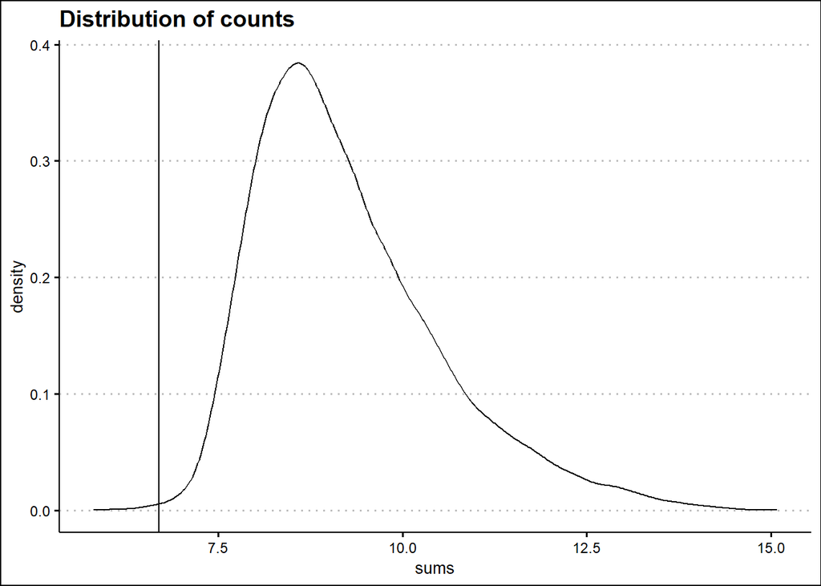

```r
data.frame(sums = log2(rowSums(wt.counts.atac)+1)) %>%
  ggplot(aes(sums)) +
  geom_density() +
 geom_vline(xintercept = 6.7) +
  theme_clean() +
  labs(title = 'Distribution of counts')
```

The number of peaks from the distribution above with counts less than 2^7.

```r
length(which(rowSums(wt.counts.atac) < 2^7))
```

```
## [1] 128
```

The number of peaks with any count value of 0 or 1.

```r
table(apply(wt.counts.atac, 1, function(x) sum(x <= 1)))
```

```
##
##     0     1     2     3     4     5     6     7     8     9    12    13
## 29787  1705   327   166    55    61    19     7    19     9     1     1
```

We will filter peaks that have any count value of 0 or 1.

```r
wt.counts.atac <- wt.counts.atac[apply(wt.counts.atac, 1, function(x) !any(x <= 1)),]
```

The majority of the low count peaks from the distribution above are removed.

```r
length(which(rowSums(wt.counts.atac) < 2^7))
```

```
## [1] 15
```

Check again that colnames of the counts table match the rownames of the wt.coldata.atac and are in the right order.

```r
all(rownames(wt.coldata.atac) %in% colnames(wt.counts.atac))
```

```
## [1] TRUE
```

```r
all(rownames(wt.coldata.atac) == colnames(wt.counts.atac))
```

```
## [1] TRUE
```

##### Run WT ATAC DE Analysis

Now we have both inputs for DESeq2 analysis. The design component for the analysis will include the instrument the ATAC-seq data was sequenced on and the stage (NC). There are two batches of WT ATAC-seq data sequenced on different machines, this variable will be added to the DESeq2 analysis. We are interested in the changes in accessibility due to stage, this variable will be added last in the design.

```r
atac.dds1 <- DESeqDataSetFromMatrix(countData = wt.counts.atac, colData = wt.coldata.atac, design = ~instrument.atac.data + Stage)
```

```
##   Note: levels of factors in the design contain characters other than
##   letters, numbers, '_' and '.'. It is recommended (but not required) to use
##   only letters, numbers, and delimiters '_' or '.', as these are safe characters
##   for column names in R. [This is a message, not a warning or an error]
```

```r
atac.dds1 <- DESeq(atac.dds1, parallel = FALSE)
```

```
##   Note: levels of factors in the design contain characters other than
##   letters, numbers, '_' and '.'. It is recommended (but not required) to use
##   only letters, numbers, and delimiters '_' or '.', as these are safe characters
##   for column names in R. [This is a message, not a warning or an error]
```

```
##   Note: levels of factors in the design contain characters other than
##   letters, numbers, '_' and '.'. It is recommended (but not required) to use
##   only letters, numbers, and delimiters '_' or '.', as these are safe characters
##   for column names in R. [This is a message, not a warning or an error]
```

Check that the names of results are as expected.

```r
resultsNames(atac.dds1)
```

```
## [1] "Intercept"
## [2] "instrument.atac.data_NovaSeq.X.Plus_vs_NextSeq.500"
## [3] "Stage_NC12_vs_NC11"
## [4] "Stage_NC13_vs_NC11"
## [5] "Stage_NC14_vs_NC11"
## [6] "Stage_LNC14_vs_NC11"
```

Dispersion estimates. Take a look at dispersion to makes sure that the data fitting looks reasonable.

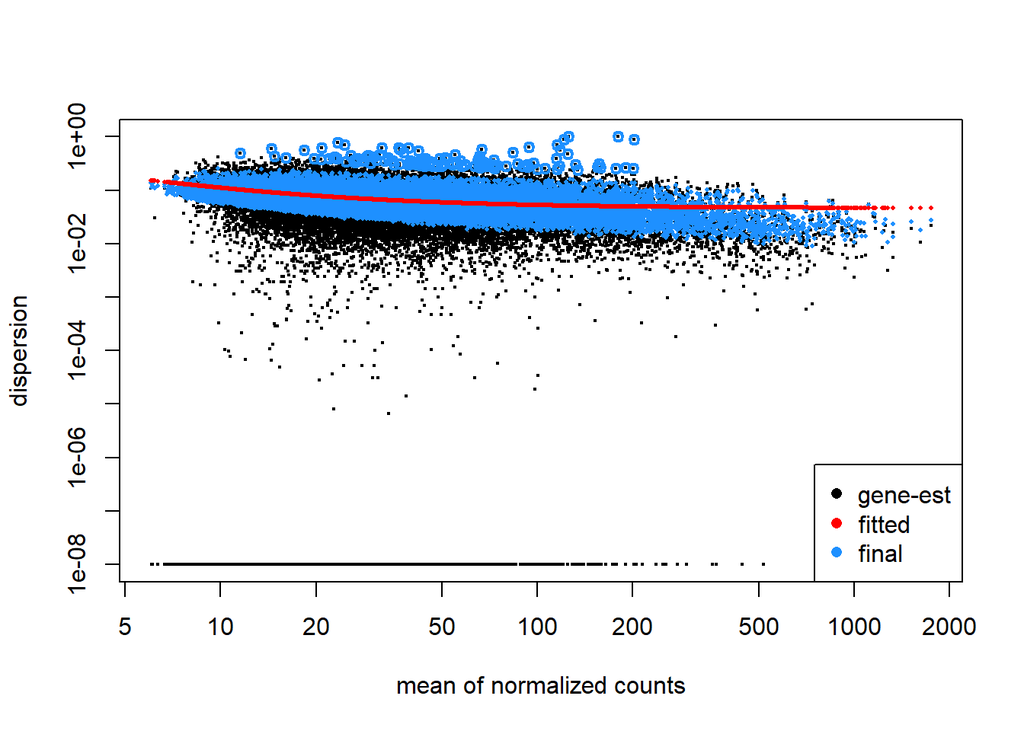

```r
plotDispEsts(atac.dds1)
```

##### Results

We will evaluate in stage wise comparisons how many peaks have a significant change in accessibility. And determine if the change in accessibility is up or down.

Extract the results from DESeq2 using DESeq2::results make a df.

```r
nc12.v.nc11 <- as.data.frame(results(atac.dds1,contrast = c("Stage","NC12","NC11"),independentFiltering = FALSE))

nc13.v.nc12 <- as.data.frame(results(atac.dds1,contrast = c("Stage","NC13","NC12"),independentFiltering = FALSE))

nc14.v.nc13 <- as.data.frame(results(atac.dds1,contrast = c("Stage","NC14","NC13"),independentFiltering = FALSE))

lnc14.v.nc14 <- as.data.frame(results(atac.dds1,contrast = c("Stage","LNC14","NC14"),independentFiltering = FALSE))
```

##### MA plots

MA plot shows the log2 fold change (LFC) as a function of mean signal.

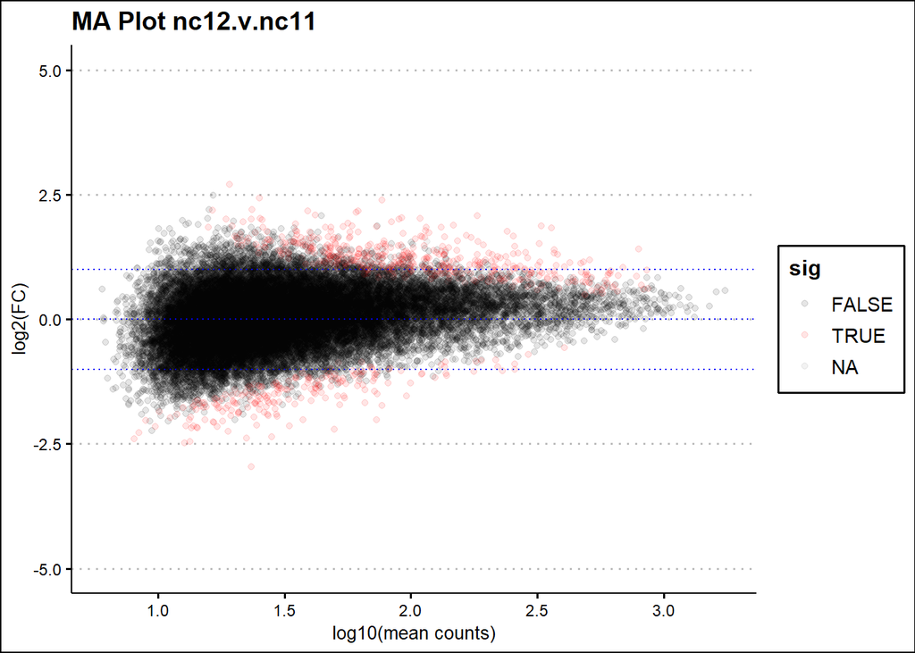

```r
nc12.v.nc11 %>%
  mutate(sig = padj <= 0.05) %>%
  ggplot(aes(x = log10(baseMean), y = log2FoldChange, color = sig)) +
  geom_point(alpha = 0.1) +
  coord_cartesian(ylim = c(-5,5)) +
  scale_color_manual(values = c("TRUE" = "red", "FALSE" =  "black")) +
  geom_hline(yintercept = c(0,1,-1), linetype = 'dotted', color = 'blue') +
  theme_clean() +
  labs(title = "MA Plot nc12.v.nc11",
       x = "log10(mean counts)",
       y = "log2(FC)")
```

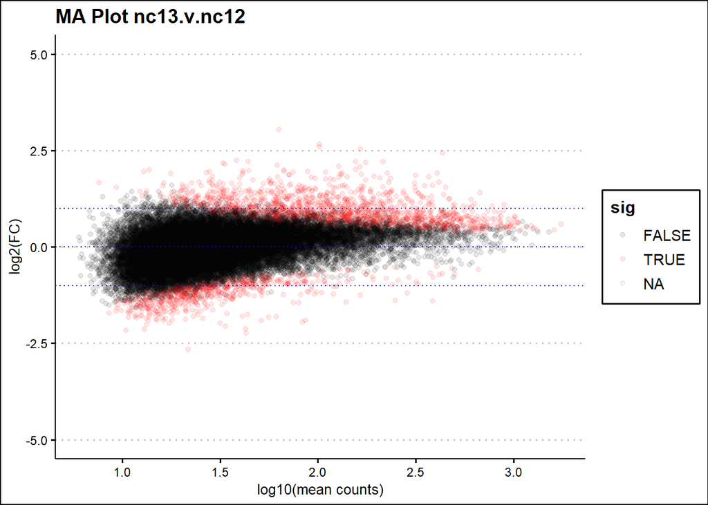

```r
nc13.v.nc12 %>%
  mutate(sig = padj <= 0.05) %>%
  ggplot(aes(x = log10(baseMean), y = log2FoldChange, color = sig)) +
  geom_point(alpha = 0.1) +
  coord_cartesian(ylim = c(-5,5)) +
  scale_color_manual(values = c("TRUE" = "red", "FALSE" =  "black")) +
  geom_hline(yintercept = c(0,1,-1), linetype = 'dotted', color = 'blue') +
  theme_clean() +
  labs(title = "MA Plot nc13.v.nc12",
       x = "log10(mean counts)",
       y = "log2(FC)")
```

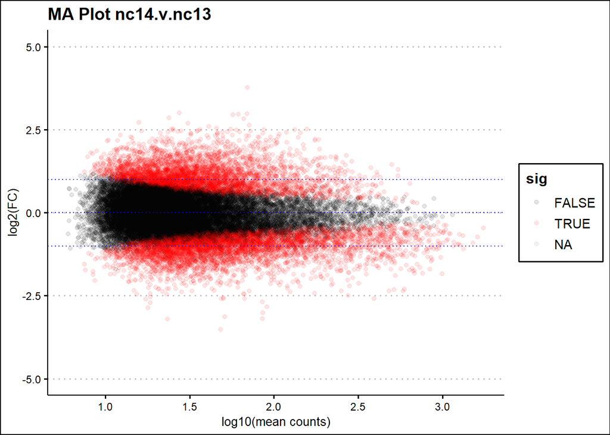

```r
nc14.v.nc13 %>%
  mutate(sig = padj <= 0.05) %>%
  ggplot(aes(x = log10(baseMean), y = log2FoldChange, color = sig)) +
  geom_point(alpha = 0.1) +
  coord_cartesian(ylim = c(-5,5)) +
  scale_color_manual(values = c("TRUE" = "red", "FALSE" =  "black")) +
  geom_hline(yintercept = c(0,1,-1), linetype = 'dotted', color = 'blue') +
  theme_clean() +
  labs(title = "MA Plot nc14.v.nc13",
       x = "log10(mean counts)",
       y = "log2(FC)")
```

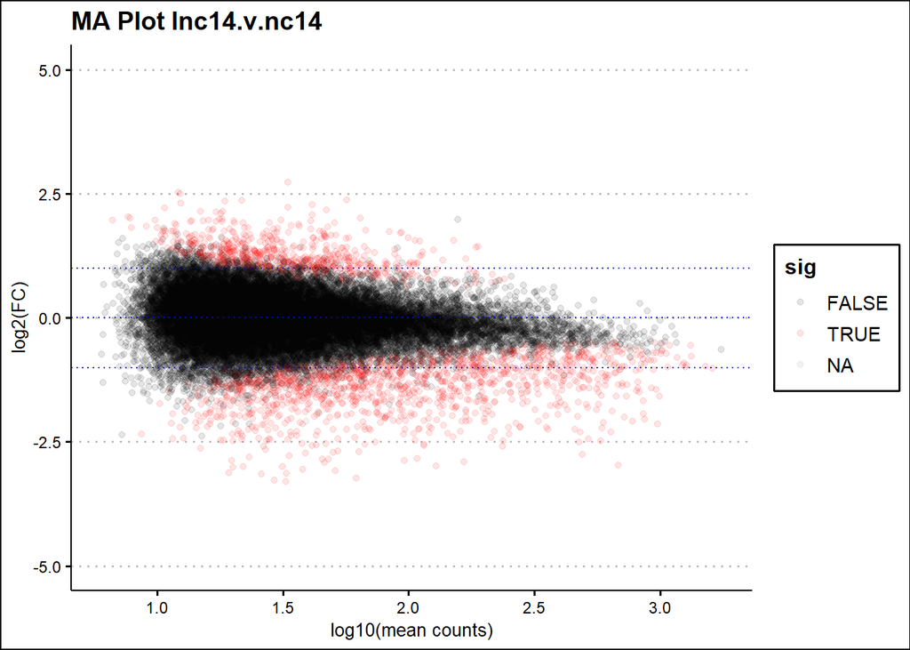

```r
lnc14.v.nc14 %>%
  mutate(sig = padj <= 0.05) %>%
  ggplot(aes(x = log10(baseMean), y = log2FoldChange, color = sig)) +
  geom_point(alpha = 0.1) +
  coord_cartesian(ylim = c(-5,5)) +
  scale_color_manual(values = c("TRUE" = "red", "FALSE" =  "black")) +
  geom_hline(yintercept = c(0,1,-1), linetype = 'dotted', color = 'blue') +
  theme_clean() +
  labs(title = "MA Plot lnc14.v.nc14",
       x = "log10(mean counts)",
       y = "log2(FC)")
```

##### Volcano plots

To visually inspect the results of each comparison we make volcano plots. For these plots significant changes in accessibility will be highlighted, and the number of peaks that go up or down will be quantified. The size of each data point will correspond to the intensity of the peak.

Statistical significance threshold is a LFC >= 1 or LFC <= -1 and an adjusted p-value (padj) <= 0.05.

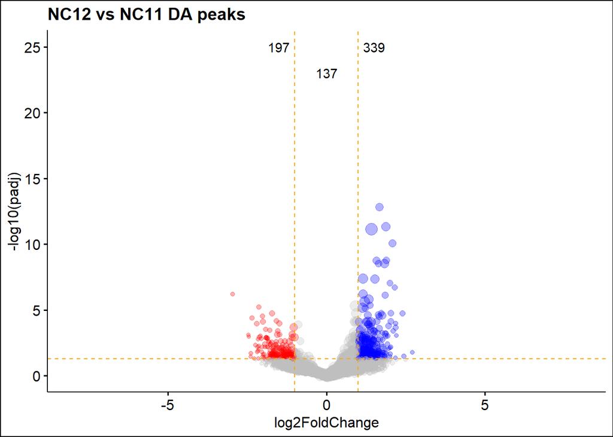

```r
# 1. Update the logical 'sig' column to a 3-way 'Change' column (UP/DOWN/NS)
nc12.v.nc11 <- nc12.v.nc11 %>%
  mutate(Change = case_when(
    is.na(padj) | padj > 0.05 | abs(log2FoldChange) < 1 ~ "NS",
    log2FoldChange <= -1 ~ "DOWN",
    log2FoldChange >= 1 ~ "UP"
  ))

# 2. Build the base plot using the matching theme and aesthetics
nc12.v.nc11.vol <- nc12.v.nc11 %>%
  mutate(mean.intensity = baseMean / max(baseMean, na.rm = TRUE)) %>%
  ggplot(aes(x = log2FoldChange, y = -log10(padj), color = Change, size = mean.intensity)) +
  geom_point(alpha = 0.3) + # Adjusted to 0.3 to match previous
  coord_cartesian(xlim = c(-8, 8), ylim = c(0, 25)) +
  geom_hline(yintercept = -log10(0.05), linetype = 'dashed', col = 'orange') +
  geom_vline(xintercept = c(-1, 1), linetype = 'dashed', col = 'orange') +
  scale_color_manual(values = c("DOWN" = 'red', "UP" = "blue", "NS" = "grey")) +
  theme_clean(base_size = 12) +
  theme(
    legend.position = "none",
    plot.title = element_text(size = 14),
    axis.title = element_text(size = 12),
    axis.text = element_text(size = 12),
    panel.grid.major.y = element_blank(),
    panel.grid.minor.y = element_blank()
  ) +
  labs(title = 'NC12 vs NC11 DA peaks')

# 3. Add the annotations using the safer sum() method
nc12.v.nc11.vol <- nc12.v.nc11.vol +
  annotate("text", x = -1.5, y = 25,
           label = sum(nc12.v.nc11$padj <= 0.05 & nc12.v.nc11$log2FoldChange <= -1, na.rm = TRUE)) +
  annotate("text", x = 1.5, y = 25,
           label = sum(nc12.v.nc11$padj <= 0.05 & nc12.v.nc11$log2FoldChange >= 1, na.rm = TRUE)) +
  annotate("text", x = 0, y = 23,
           label = sum(nc12.v.nc11$padj <= 0.05 & abs(nc12.v.nc11$log2FoldChange) < 1, na.rm = TRUE))

# Display the plot
nc12.v.nc11.vol
```

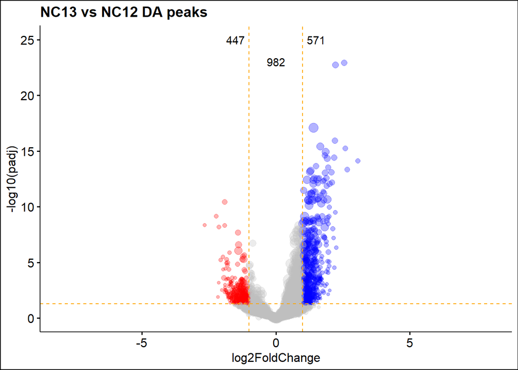

```r
# 1. Update the Change column
nc13.v.nc12 <- nc13.v.nc12 %>%
  mutate(Change = case_when(
    is.na(padj) | padj > 0.05 | abs(log2FoldChange) < 1 ~ "NS",
    log2FoldChange <= -1 ~ "DOWN",
    log2FoldChange >= 1 ~ "UP"
  ))

# 2. Build the base plot
nc13.v.nc12.vol <- nc13.v.nc12 %>%
  mutate(mean.intensity = baseMean / max(baseMean, na.rm = TRUE)) %>%
  ggplot(aes(x = log2FoldChange, y = -log10(padj), color = Change, size = mean.intensity)) +
  geom_point(alpha = 0.3) +
  coord_cartesian(xlim = c(-8, 8), ylim = c(0, 25)) +
  geom_hline(yintercept = -log10(0.05), linetype = 'dashed', col = 'orange') +
  geom_vline(xintercept = c(-1, 1), linetype = 'dashed', col = 'orange') +
  scale_color_manual(values = c("DOWN" = 'red', "UP" = "blue", "NS" = "grey")) +
  theme_clean(base_size = 12) +
  theme(
    legend.position = "none",
    plot.title = element_text(size = 14),
    axis.title = element_text(size = 12),
    axis.text = element_text(size = 12),
    panel.grid.major.y = element_blank(),
    panel.grid.minor.y = element_blank()
  ) +
  labs(title = 'NC13 vs NC12 DA peaks')

# 3. Add the annotations
nc13.v.nc12.vol <- nc13.v.nc12.vol +
  annotate("text", x = -1.5, y = 25,
           label = sum(nc13.v.nc12$padj <= 0.05 & nc13.v.nc12$log2FoldChange <= -1, na.rm = TRUE)) +
  annotate("text", x = 1.5, y = 25,
           label = sum(nc13.v.nc12$padj <= 0.05 & nc13.v.nc12$log2FoldChange >= 1, na.rm = TRUE)) +
  annotate("text", x = 0, y = 23,
           label = sum(nc13.v.nc12$padj <= 0.05 & abs(nc13.v.nc12$log2FoldChange) < 1, na.rm = TRUE))

# Display plot
nc13.v.nc12.vol
```

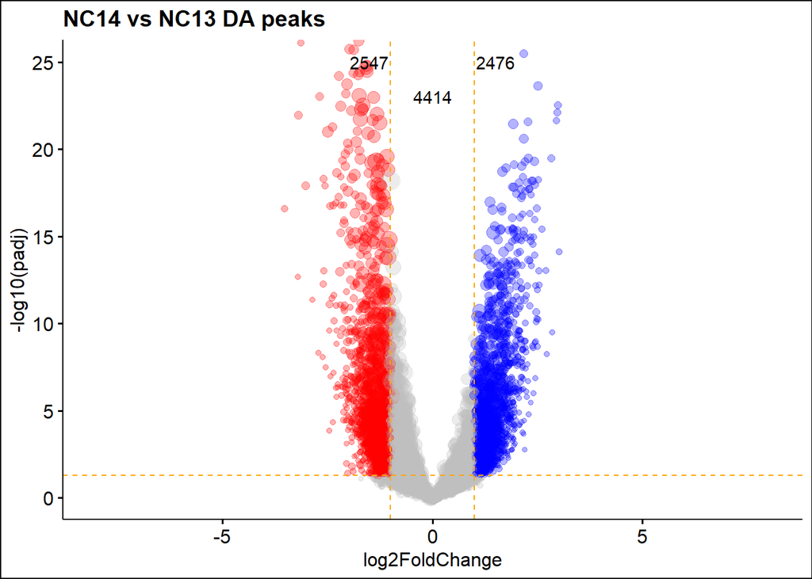

```r
# 1. Update the Change column
nc14.v.nc13 <- nc14.v.nc13 %>%
  mutate(Change = case_when(
    is.na(padj) | padj > 0.05 | abs(log2FoldChange) < 1 ~ "NS",
    log2FoldChange <= -1 ~ "DOWN",
    log2FoldChange >= 1 ~ "UP"
  ))

# 2. Build the base plot
nc14.v.nc13.vol <- nc14.v.nc13 %>%
  mutate(mean.intensity = baseMean / max(baseMean, na.rm = TRUE)) %>%
  ggplot(aes(x = log2FoldChange, y = -log10(padj), color = Change, size = mean.intensity)) +
  geom_point(alpha = 0.3) +
  coord_cartesian(xlim = c(-8, 8), ylim = c(0, 25)) +
  geom_hline(yintercept = -log10(0.05), linetype = 'dashed', col = 'orange') +
  geom_vline(xintercept = c(-1, 1), linetype = 'dashed', col = 'orange') +
  scale_color_manual(values = c("DOWN" = 'red', "UP" = "blue", "NS" = "grey")) +
  theme_clean(base_size = 12) +
  theme(
    legend.position = "none",
    plot.title = element_text(size = 14),
    axis.title = element_text(size = 12),
    axis.text = element_text(size = 12),
    panel.grid.major.y = element_blank(),
    panel.grid.minor.y = element_blank()
  ) +
  labs(title = 'NC14 vs NC13 DA peaks')

# 3. Add the annotations
nc14.v.nc13.vol <- nc14.v.nc13.vol +
  annotate("text", x = -1.5, y = 25,
           label = sum(nc14.v.nc13$padj <= 0.05 & nc14.v.nc13$log2FoldChange <= -1, na.rm = TRUE)) +
  annotate("text", x = 1.5, y = 25,
           label = sum(nc14.v.nc13$padj <= 0.05 & nc14.v.nc13$log2FoldChange >= 1, na.rm = TRUE)) +
  annotate("text", x = 0, y = 23,
           label = sum(nc14.v.nc13$padj <= 0.05 & abs(nc14.v.nc13$log2FoldChange) < 1, na.rm = TRUE))

# Display plot
nc14.v.nc13.vol
```

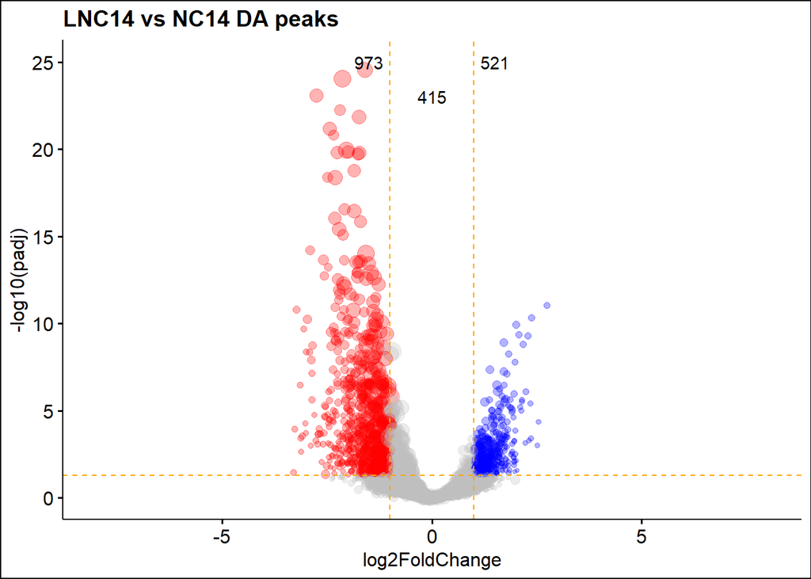

```r
# 1. Update the Change column
lnc14.v.nc14 <- lnc14.v.nc14 %>%
  mutate(Change = case_when(
    is.na(padj) | padj > 0.05 | abs(log2FoldChange) < 1 ~ "NS",
    log2FoldChange <= -1 ~ "DOWN",
    log2FoldChange >= 1 ~ "UP"
  ))

# 2. Build the base plot
lnc14.v.nc14.vol <- lnc14.v.nc14 %>%
  mutate(mean.intensity = baseMean / max(baseMean, na.rm = TRUE)) %>%
  ggplot(aes(x = log2FoldChange, y = -log10(padj), color = Change, size = mean.intensity)) +
  geom_point(alpha = 0.3) +
  coord_cartesian(xlim = c(-8, 8), ylim = c(0, 25)) +
  geom_hline(yintercept = -log10(0.05), linetype = 'dashed', col = 'orange') +
  geom_vline(xintercept = c(-1, 1), linetype = 'dashed', col = 'orange') +
  scale_color_manual(values = c("DOWN" = 'red', "UP" = "blue", "NS" = "grey")) +
  theme_clean(base_size = 12) +
  theme(
    legend.position = "none",
    plot.title = element_text(size = 14),
    axis.title = element_text(size = 12),
    axis.text = element_text(size = 12),
    panel.grid.major.y = element_blank(),
    panel.grid.minor.y = element_blank()
  ) +
  labs(title = 'LNC14 vs NC14 DA peaks')

# 3. Add the annotations
lnc14.v.nc14.vol <- lnc14.v.nc14.vol +
  annotate("text", x = -1.5, y = 25,
           label = sum(lnc14.v.nc14$padj <= 0.05 & lnc14.v.nc14$log2FoldChange <= -1, na.rm = TRUE)) +
  annotate("text", x = 1.5, y = 25,
           label = sum(lnc14.v.nc14$padj <= 0.05 & lnc14.v.nc14$log2FoldChange >= 1, na.rm = TRUE)) +
  annotate("text", x = 0, y = 23,
           label = sum(lnc14.v.nc14$padj <= 0.05 & abs(lnc14.v.nc14$log2FoldChange) < 1, na.rm = TRUE))

# Display plot
lnc14.v.nc14.vol
```

Save plots.

```r
pdf(file = "../Plots/WT_Tc_peaks-genome.pdf", width = 25,height = 5)

ggarrange(nc12.v.nc11.vol,
          nc13.v.nc12.vol,
          nc14.v.nc13.vol,
          lnc14.v.nc14.vol,
                    ncol = 4, nrow = 1)
dev.off()
```

##### PCA

We will make a PCA plot of PC 1 and PC2.

```r
rld <- rlog(atac.dds1, blind = FALSE) #rlog transform the data
pca <- plotPCA(rld, intgroup = c("Stage"), returnData = TRUE, ntop = 1000) # use the built in function plotPCA using only the top 1000 most variable regions
```

```
## using ntop=1000 top features by variance
```

```r
percentVar <- round(100 * attr(pca, "percentVar")) # calculate the variance attributed to each PC
```

We can see that PC1 correlates strongly with the stage of the embryos. For the most part replicates clusters nicely with other replicates of the same stage. Other notable sources of variance include the sex of the embryo. The chromosomes of Clogmia are isomorphic therefore embryo sex cannot be distinguished by the difference in the number of reads mapping to a sex chromosome.

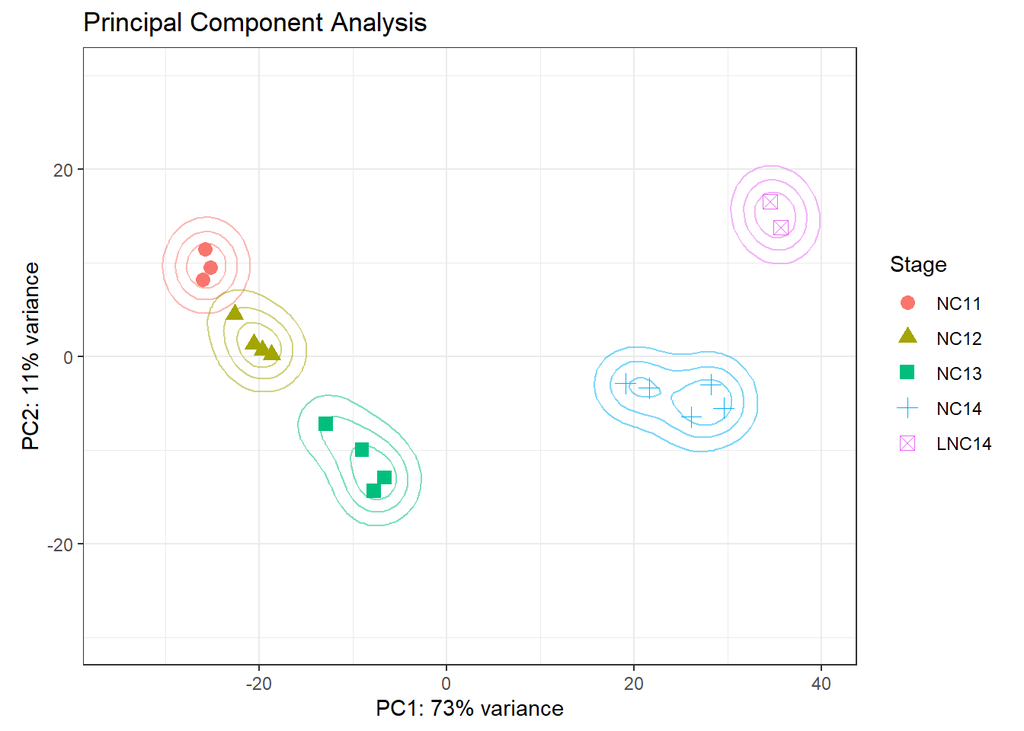

```r
PC12plot <- ggplot(pca, aes(PC1, PC2, color = Stage, shape = Stage)) +
  geom_point(size = 3, alpha = 2) +
  xlab(paste0("PC1: ", percentVar[1], "% variance")) + ylab(paste0("PC2: ", percentVar[2], "% variance")) +
  stat_density_2d(h = 11, contour = TRUE, show.legend = FALSE, alpha = 0.5, contour_var = "ndensity", bins = 4) +
  xlim(-35, 40) +
  ylim(-30, 30) +
  #scale_color_manual(values = c("tomato", "blue")) +
  theme(axis.line = element_line(color = "black")) +
  theme_bw() +
  coord_fixed() +
  labs(title = 'Principal Component Analysis')

PC12plot
```

#### WT ATAC-seq TC DESeq2 summary table

Lets create a df of the DESeq2 results. The results will contain the peak name of the peak evaluated, the average counts of the peak, and the LFC and padj for each stage wise comparison.

```r
#Double check that all rownnames (name of peak) are the same for all comparisons
all(rownames(nc12.v.nc11) == rownames(nc13.v.nc12) &  rownames(nc12.v.nc11) == rownames(nc14.v.nc13) & rownames(nc12.v.nc11) == rownames(lnc14.v.nc14))
```

```
## [1] TRUE
```

```r
de.results.table <- data.frame(
                peak.name = rownames(nc12.v.nc11),
                baseMean.de = nc12.v.nc11$baseMean,
                padj.nc12.v.nc11 = signif(nc12.v.nc11$padj, 4),
                lfc.nc12.v.nc11 = signif(nc12.v.nc11$log2FoldChange, 4),
                padj.nc13.v.nc12 = signif(nc13.v.nc12$padj, 4),
                lfc.nc13.v.nc12 = signif(nc13.v.nc12$log2FoldChange, 4),
                padj.nc14.v.nc13 = signif(nc14.v.nc13$padj, 4),
                lfc.nc14.v.nc13 = signif(nc14.v.nc13$log2FoldChange, 4),
                padj.lnc14.v.nc14 = signif(lnc14.v.nc14$padj, 4),
                lfc.lnc14.v.nc14 = signif(lnc14.v.nc14$log2FoldChange, 4))

head(de.results.table)
```

```
##                  peak.name baseMean.de padj.nc12.v.nc11 lfc.nc12.v.nc11
## 1   scaffold_1:39064-39403    76.28291           0.6301         0.50570
## 2   scaffold_1:46323-46446    12.99380           0.9205        -0.15980
## 3 scaffold_1:113573-113903   180.13612           0.9605        -0.05152
## 4 scaffold_1:114565-114639    20.88217           0.9589        -0.09461
## 5 scaffold_1:116022-116187   122.09435           0.8517         0.15940
## 6 scaffold_1:126620-126698    22.65121           0.8448         0.23890
##   padj.nc13.v.nc12 lfc.nc13.v.nc12 padj.nc14.v.nc13 lfc.nc14.v.nc13
## 1           0.7799         -0.2216          0.02787        -0.90130
## 2           0.8377         -0.2149          0.72900        -0.21260
## 3           0.8222         -0.1371          0.89590        -0.05192
## 4           0.4067         -0.7404          0.73960        -0.23290
## 5           0.6215          0.2511          0.27690        -0.33660
## 6           0.3802         -0.5734          0.98310        -0.01205
##   padj.lnc14.v.nc14 lfc.lnc14.v.nc14
## 1            0.8720          -0.2544
## 2            0.2202          -1.2010
## 3            0.5969           0.4129
## 4            0.8352           0.3909
## 5            0.9257          -0.1168
## 6            0.9463           0.1204
```

```r
# note that not all peaks in the master list were evaluated
#nrow(de.results.table)
```

## 4. Chromatin Acessibility Dynamics

The goal of this section is to determine

1. How many dynamic peaks there are.
2. How the chromatin accessibility for each peak changes with each stage.
3. Identify patterns/clusters of peaks that share similar dynamics.

##### Dynamic peaks

Lets determine how many peak are dynamic using a statistical definition of a logFC >= 1 or logFC <= 1 and padj <= 0.05 in a least one DESeq2 comparison.

There are 6930 dynamic peaks (DAPs).

```r
sig.peak.names <- de.results.table[which(
  (de.results.table$padj.nc12.v.nc11 <= 0.05 &
  abs(de.results.table$lfc.nc12.v.nc11) >= 1) |
  (de.results.table$padj.nc13.v.nc12 <= 0.05 & abs(de.results.table$lfc.nc13.v.nc12) >= 1) |
  (de.results.table$padj.nc14.v.nc13 <= 0.05 & abs(de.results.table$lfc.nc14.v.nc13) >= 1) |
  (de.results.table$padj.lnc14.v.nc14 <= 0.05 & abs(de.results.table$lfc.lnc14.v.nc14) >= 1)
),"peak.name"]
```

Lets make a GRanges of the dynamic peaks. These are the peaks in the sig.peak.names vector.

```r
dynamic <- peaks.32157[names(peaks.32157) %in% sig.peak.names]


## check that the right peaks are labeled

#table(names(dynamic) %in% de.results.table$peak.name)

#all(names(dynamic) %in% sig.peak.names)
```

25227 peaks do not have significant changes in accessibility.

```r
table(!names(peaks.32157) %in% names(dynamic))
```

```
##
## FALSE  TRUE
##  6930 25227
```

Now lets evaluate how the accessibility of peaks change over time and if peaks cluster together based on chromatin accessibility dynamics.

To do this we will use the clustering algorithm degPatterns from DEGreport.

For the function we need to create a normalized count matrix from the DESeq2 object. We will cluster all dynamic peaks identified previously ie the peaks that have some significant change in accessibility.

```r
res.atac <- results(atac.dds1)

sig.res.atac <- res.atac[rownames(res.atac) %in% names(dynamic),]

#table(names(dynamic) %in% rownames(res.atac))

#table(rownames(res.atac) %in% names(dynamic))
```

Now the count matrix needs to be transformed using the rlog transformation.

```r
rm(rld) # if necessary, remove the rld object created for the pca plot,

rld <- rlog(atac.dds1, blind = TRUE) # transform the data with blind = TRUE
```

```
## -- note: fitType='parametric', but the dispersion trend was not well captured by the
##    function: y = a/x + b, and a local regression fit was automatically substituted.
##    specify fitType='local' or 'mean' to avoid this message next time.
```

Extract the normalized matrix.

```r
rld.mat.atac <- assay(rld)
```

Keep only the significant peaks.

```r
sig.rld.mat.atac <- rld.mat.atac[rownames(sig.res.atac),]

#table(names(dynamic) == rownames(sig.rld.mat.atac))

#table(rownames(sig.rld.mat.atac) == names(dynamic))
```

Now that we have the matrix we can run degPatterns. Peaks will be clustered using a z-score. [For more see the manual](https://www.bioconductor.org/packages/release/bioc/html/DEGreport.html).

To cluster peaks we will specify the minimum number of peaks in a group (minc) as 10. We will skip this part to save time, the saved results can be found in “./WT_timecourse/patterns-group-table.txt”

```r
patterns <- degPatterns(sig.rld.mat.atac, metadata = colData(atac.dds1), time = "Stage", minc = 10, col = NULL)
```

##### Dynamic group plot

We observe that there is a lot of fluctuation/ volatility in the accessibility of peak that was not appreciated in the stage-wise comparisons. In other words, there are more complex dynamics than progressive losses or gains in accessibility from stage to stage. These dynamics could reflect the activity of the cis-regulatory element.

```r
patterns$plot
```

[output not shown]

Save plot fo file

```r
pdf(file = "../Plots/dynamic-groups.pdf", width = 10,height = 7)

patterns$plot

dev.off()
```

##### patterns.group.table

Will create a table denoting what dynamic group a peak belongs to if any.

```r
head(patterns.df)

#nrow(patterns.df)

#table(patterns.df$cluster)
```

The names have changed, a “.” has replaced the “:” after scaffold and the “-” between start and end position. We need to change it back before creating a logical vector of peaks in a group. Note the function defaults to calling everything a “genes”, in our case each entry is a peak.

```r
names <- patterns.df$genes
names <- sub(x = names, pattern = "\\.", replacement = ":")
names <- sub(x = names, pattern = "\\.", replacement = "-")

# check that the names have been succesfully corrected
#all(names == names(dynamic))

#all(names == sig.peak.names)
```

```r
patterns.df$genes <- names
head(patterns.df)
```

Create a vector of the peaks names in each group.

```r
group.1.names <- patterns.df[patterns.df$cluster == 1,"genes"]
group.2.names <- patterns.df[patterns.df$cluster == 2,"genes"]
group.3.names <- patterns.df[patterns.df$cluster == 3,"genes"]
group.4.names <- patterns.df[patterns.df$cluster == 4,"genes"]
group.5.names <- patterns.df[patterns.df$cluster == 5,"genes"]
group.6.names <- patterns.df[patterns.df$cluster == 6,"genes"]
group.7.names <- patterns.df[patterns.df$cluster == 7,"genes"]
group.8.names <- patterns.df[patterns.df$cluster == 8,"genes"]
group.9.names <- patterns.df[patterns.df$cluster == 9,"genes"]


group.10.names <- patterns.df[patterns.df$cluster == 10,"genes"]
group.11.names <- patterns.df[patterns.df$cluster == 11,"genes"]
group.12.names <- patterns.df[patterns.df$cluster == 12,"genes"]
group.13.names <- patterns.df[patterns.df$cluster == 13,"genes"]
group.14.names <- patterns.df[patterns.df$cluster == 14,"genes"]
group.15.names <- patterns.df[patterns.df$cluster == 15,"genes"]
group.16.names <- patterns.df[patterns.df$cluster == 16,"genes"]
group.17.names <- patterns.df[patterns.df$cluster == 17,"genes"]
group.18.names <- patterns.df[patterns.df$cluster == 18,"genes"]
group.19.names <- patterns.df[patterns.df$cluster == 19,"genes"]
group.20.names <- patterns.df[patterns.df$cluster == 20,"genes"]
group.21.names <- patterns.df[patterns.df$cluster == 21,"genes"]
```

Now we can determine if a peaks in the main peak list is in a dynamic group. Below will create a T/F vector the length of all peaks. The entry will be TRUE if the peak is a dynamic group. A vector will be made for each group.

```r
group.1.l <- names(peaks.32157) %in% group.1.names
group.2.l <- names(peaks.32157) %in% group.2.names
group.3.l <- names(peaks.32157) %in% group.3.names
group.4.l <- names(peaks.32157) %in% group.4.names
group.5.l <- names(peaks.32157) %in% group.5.names
group.6.l <- names(peaks.32157) %in% group.6.names
group.7.l <- names(peaks.32157) %in% group.7.names
group.8.l <- names(peaks.32157) %in% group.8.names
group.9.l <- names(peaks.32157) %in% group.9.names


group.10.l <- names(peaks.32157) %in% group.10.names
group.11.l <- names(peaks.32157) %in% group.11.names
group.12.l <- names(peaks.32157) %in% group.12.names
group.13.l <- names(peaks.32157) %in% group.13.names
group.14.l <- names(peaks.32157) %in% group.14.names
group.15.l <- names(peaks.32157) %in% group.15.names
group.16.l <- names(peaks.32157) %in% group.16.names
group.17.l <- names(peaks.32157) %in% group.17.names
group.18.l <- names(peaks.32157) %in% group.18.names
group.19.l <- names(peaks.32157) %in% group.19.names
group.20.l <- names(peaks.32157) %in% group.20.names
group.21.l <- names(peaks.32157) %in% group.21.names
```

Now make the patterns.group.table.

```r
patterns.group.table <- data.frame(peak.name = names(peaks.32157),
                                   group.1 = group.1.l,
                                   group.2 = group.2.l,
                                   group.3 = group.3.l,
                                   group.4 = group.4.l,
                                   group.5 = group.5.l,
                                   group.6 = group.6.l,
                                   group.7 = group.7.l,
                                   group.8 = group.8.l,
                                   group.9 = group.9.l,
                                   group.10 = group.10.l,
                                   group.11 = group.11.l,
                                   group.12 = group.12.l,
                                   group.13 = group.13.l,
                                   group.14 = group.14.l,
                                   group.15 = group.15.l,
                                   group.16 = group.16.l,
                                   group.17 = group.17.l,
                                   group.18 = group.18.l,
                                   group.19 = group.19.l,
                                   group.20 = group.20.l,
                                   group.21 = group.21.l)
```

Add a dynamic column “dynamic.peak”, indicating if a peak is dynamic. Add a column, “non.dynamic.peak”, TRU for non dynamic peaks. Add a column “dynamic.in.class”, indicating if a peak is in a dynamic group

```r
patterns.group.table <- patterns.group.table %>%
  mutate(dynamic.peak = (peak.name %in% names(dynamic))) %>%
  mutate(non.dynamic.peak = (!peak.name %in% names(dynamic))) %>%
  mutate(dynamic.in.class = if_else(group.1 == TRUE|
                                      group.2 == TRUE|
                                      group.3 == TRUE|
                                      group.4 == TRUE|
                                      group.5 == TRUE|
                                      group.6 == TRUE|
                                      group.7 == TRUE|
                                      group.8 == TRUE|
                                      group.9 == TRUE|
                                      group.10 == TRUE|
                                      group.11 == TRUE|
                                      group.12 == TRUE|
                                      group.13 == TRUE|
                                      group.14 == TRUE|
                                      group.15 == TRUE|
                                      group.16 == TRUE|
                                      group.17 == TRUE|
                                      group.18 == TRUE|
                                      group.19 == TRUE|
                                      group.20 == TRUE|
                                      group.21 == TRUE,TRUE,FALSE
                                      ))
```

```r
write.table(patterns.group.table,file = "../WT_timecourse/patterns-group-table.txt", sep = "\t", row.names = FALSE, col.names = TRUE)
```

Notice all of the 6930 dynamic peaks are in a group. None of the non dynamic peaks are in a group.

```r
patterns.group.table<-read.delim("../WT_timecourse/patterns-group-table.txt")
head(patterns.group.table)
```

```
##                  peak.name group.1 group.2 group.3 group.4 group.5 group.6
## 1   scaffold_1:39064-39403   FALSE   FALSE   FALSE   FALSE   FALSE   FALSE
## 2   scaffold_1:41080-41159   FALSE   FALSE   FALSE   FALSE   FALSE   FALSE
## 3   scaffold_1:46323-46446   FALSE   FALSE   FALSE   FALSE   FALSE   FALSE
## 4 scaffold_1:113573-113903   FALSE   FALSE   FALSE   FALSE   FALSE   FALSE
## 5 scaffold_1:114565-114639   FALSE   FALSE   FALSE   FALSE   FALSE   FALSE
## 6 scaffold_1:116022-116187   FALSE   FALSE   FALSE   FALSE   FALSE   FALSE
##   group.7 group.8 group.9 group.10 group.11 group.12 group.13 group.14 group.15
## 1   FALSE   FALSE   FALSE    FALSE    FALSE    FALSE    FALSE    FALSE    FALSE
## 2   FALSE   FALSE   FALSE    FALSE    FALSE    FALSE    FALSE    FALSE    FALSE
## 3   FALSE   FALSE   FALSE    FALSE    FALSE    FALSE    FALSE    FALSE    FALSE
## 4   FALSE   FALSE   FALSE    FALSE    FALSE    FALSE    FALSE    FALSE    FALSE
## 5   FALSE   FALSE   FALSE    FALSE    FALSE    FALSE    FALSE    FALSE    FALSE
## 6   FALSE   FALSE   FALSE    FALSE    FALSE    FALSE    FALSE    FALSE    FALSE
##   group.16 group.17 group.18 group.19 group.20 group.21 dynamic.peak
## 1    FALSE    FALSE    FALSE    FALSE    FALSE    FALSE        FALSE
## 2    FALSE    FALSE    FALSE    FALSE    FALSE    FALSE        FALSE
## 3    FALSE    FALSE    FALSE    FALSE    FALSE    FALSE        FALSE
## 4    FALSE    FALSE    FALSE    FALSE    FALSE    FALSE        FALSE
## 5    FALSE    FALSE    FALSE    FALSE    FALSE    FALSE        FALSE
## 6    FALSE    FALSE    FALSE    FALSE    FALSE    FALSE        FALSE
##   non.dynamic.peak dynamic.in.class
## 1             TRUE            FALSE
## 2             TRUE            FALSE
## 3             TRUE            FALSE
## 4             TRUE            FALSE
## 5             TRUE            FALSE
## 6             TRUE            FALSE
```

```r
table(patterns.group.table$dynamic.peak==TRUE & patterns.group.table$dynamic.in.class==TRUE)
```

```
##
## FALSE  TRUE
## 25227  6930
```

```r
#patterns.group.table %>% count(non.dynamic.peak)

#nrow(patterns.group.table)
```

## 5. MOTIF Analysis

Motif enrichment analysis using MEME will be performed to identify potential factors acting on these regions.

In addition motifs for factors of interest, Zld and Opa will be searched for in the peaks using seqLogo::matchPWM.

#### MEME

##### MEME all peaks

Get sequences for peaks using the function below.

For each peak, the peak will be centered on the summit and the length will be normalized to 100 bp. The sequence of this region is extracted from the Calbipunctata object using the getSeq function.

```r
genome(Calbipunctata) <- "ca6" # set genome of Calbipunctata

get.my.seqs <- function(p, name, dir){
    #regions = p[mcols(p)[subset][, 1]]
    #regions  = p[p %in% subset]
    regions = p
    start(regions) = regions$max
    end(regions) = regions$max
    regions = resize(regions, width = 100, fix = "center")
    regionseqs = getSeq(Calbipunctata, regions)
    export(regionseqs, con = paste0(dir, "/", name, ".txt"), format = "fasta")
}
```

*Sequence of all peaks*

```r
# dir for output
sequence.output.directory <-"../MEME"

get.my.seqs(p = peaks.32157, dir = sequence.output.directory, name = "peaks-32157")
```

*Sequence of all NC11:LNC14 peaks*

```r
get.my.seqs(p = peaks.32157[nc11.open.l], dir = sequence.output.directory, name = "nc11-peaks-q1e25")

get.my.seqs(p = peaks.32157[nc12.open.l], dir = sequence.output.directory, name = "nc12-peaks-q1e25")

get.my.seqs(p = peaks.32157[nc13.open.l], dir = sequence.output.directory, name = "nc13-peaks-q1e25")

get.my.seqs(p = peaks.32157[nc14.open.l], dir = sequence.output.directory, name = "nc14-peaks-q1e25")

get.my.seqs(p = peaks.32157[lnc14.open.l], dir = sequence.output.directory, name = "lnc14-peaks-q1e25")
```

Get background sequences

MEME also needs a set of background sequences to run. For all peak we will use a random set of genomic regions where there are no peaks.

Tile the Clogmia genome.

```r
ca.10bp <- tileGenome(seqlengths(BSgenome.Calbipunctata.Cantata.uni4000), tilewidth = 10, cut.last.tile.in.chrom = TRUE)
```

We will only consider the 6 chromosome sized scaffolds. Update the seqinfo for the tiled genome objected (ca.10bp)

```r
good.uns <- seqlevels(peaks.32157)
#good.uns
```

```r
ca.10bp <- ca.10bp[seqnames(ca.10bp) %in% good.uns]
seqlevels(ca.10bp) <- seqlevels(peaks.32157)
seqinfo(ca.10bp) <- seqinfo(peaks.32157)
seqlevels(ca.10bp) <- seqlevelsInUse(ca.10bp)
```

First we get a set of regions (bins) where there are no neighboring peaks. Then the regions are resized to 100 bp and 1000 regions are sampled. The regions are named corresponding to the genomic coordinate. The sequences are then exported using the getSeq and export functions.

```r
emptyBins <- ca.10bp[!as.logical(countOverlaps(ca.10bp, resize(peaks.32157, width = 10000, fix = "center")))]

set.seed(124) # set seed for sampling

selectBins <- resize(sample(emptyBins, size = 1000, replace = FALSE), width = 100, fix = "center")

names(selectBins) <- paste0(seqnames(selectBins),":",start(selectBins),"-",end(selectBins))

controlSeqs <- getSeq(Calbipunctata,selectBins)


export(controlSeqs, con = "../MEME/WT_Tc_control-seq.txt", format = "fasta")
```

##### MEME dynamic peaks

Repeat the process to extract sequences of dynamic peaks.

```r
sequence.output.directory <-
  "../MEME"


get.my.seqs(dynamic, name = "all-dynamic",dir = sequence.output.directory) # export sequences using get.my.seq
```

For control sequences we will use 1000 non dynamic peaks

```r
non.dynamic.peak.l <- !names(peaks.32157) %in% names(dynamic) # create a logical vector of non dynamic peaks.

bgpeaks <- peaks.32157[non.dynamic.peak.l] # use the vector to get the set of non dynamic peaks

set.seed(124) # set seed for sampling

bgset <- sample(bgpeaks, size = 1000) # sample 1000 non dynamic peaks
start(bgset) <- bgset$max
end(bgset) <- bgset$max
bgset <- resize(bgset, width = 100, fix = "center")
bgseqs <- getSeq(Calbipunctata, bgset)

export(bgseqs, con = paste0(sequence.output.directory, "/non-dynamic-peak-background.txt"), format = "fasta")
```

#### MEME non dynamic peaks

Repeat the process to extract sequences of non dynamic peaks.

```r
sequence.output.directory <-"../MEME"

non.dynamic.peak.l <- !names(peaks.32157) %in% names(dynamic) # create a logical vector of non dynamic peaks.

non.dynamic <- peaks.32157[non.dynamic.peak.l] # use the vector to get the set of non dynamic peaks

get.my.seqs(non.dynamic, name = "non-dynamic",dir = sequence.output.directory) # export sequences using get.my.seq
```

For control sequences we will use 1000 dynamic peaks

```r
set.seed(124) # set seed for sampling

bgset <- sample(dynamic, size = 1000) # sample 1000 dynamic peaks
start(bgset) <- bgset$max
end(bgset) <- bgset$max
bgset <- resize(bgset, width = 100, fix = "center")
bgseqs <- getSeq(Calbipunctata, bgset)

export(bgseqs, con = paste0(sequence.output.directory, "/dynamic-peak-background.txt"), format = "fasta")
```

#### Find PWM

In subsequent sections we will explore the effects of Cal-zld and Cal-opa depletion on chromatin accessibility in the Clogmia embryo. Below we will identify peaks with a Zld and or Opa motif.

In the following sections the raw count matrix from a binding assay will be loaded (column order is “A”,“C”,“G”,“T”, row order is DNA positions 1-n). The raw matrix will be converted to a frequency matrix. From the frequency matrix a seqlogo of the PWM in both orientations will be made and trimmed to the positions that contain the most information. The trimmed PWM will be used in the findPWM function to identify peaks with a 80% match to the PWM. For a Dme-Zld data comes from a solex binding assay. The Opa matrix is from Dme ATAC-seq study which found a Dme-Opa motif enriched in late NC14 ATAC-seq peaks (Soluri et al. elife 2020)

##### Zld

```r
zldPWM <- read.delim("../PWMs/vfl_SOLEXA_5_FBgn0259789_raw.txt",header = FALSE)

head(zldPWM)
```

```
##    V1  V2  V3  V4
## 1 110 150 196 229
## 2 149 123 254 235
## 3 144 119 234 264
## 4 116 212 237 196
## 5  54   0 478 229
## 6   7 749   0   5
```

```r
zldPWM <- signif((zldPWM/rowSums(zldPWM)), digits = 8) # convert to frequencies

# included an obnoxious amount of sig digits so that every value sums to one
apply(zldPWM,1,sum)
```

```
##  [1] 1 1 1 1 1 1 1 1 1 1 1 1 1 1 1
```

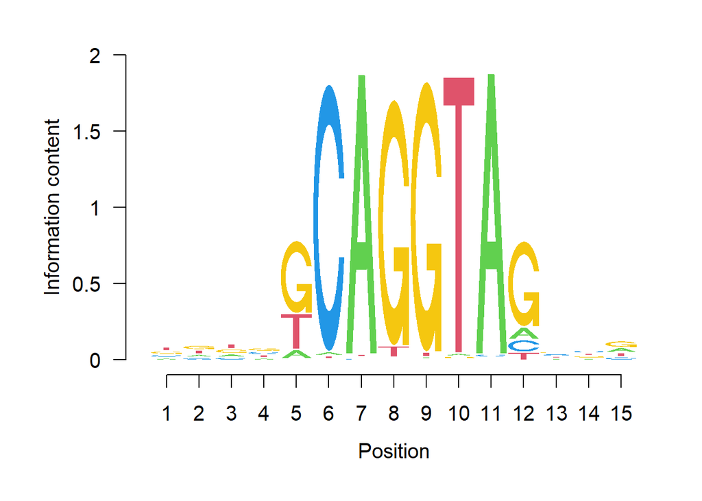

```r
zldPWM <- as.matrix(zldPWM)
colnames(zldPWM) <- c("A","C","G","T") # add col names

tzldPWM<- t(zldPWM) # transpose
seqLogo(tzldPWM)
```

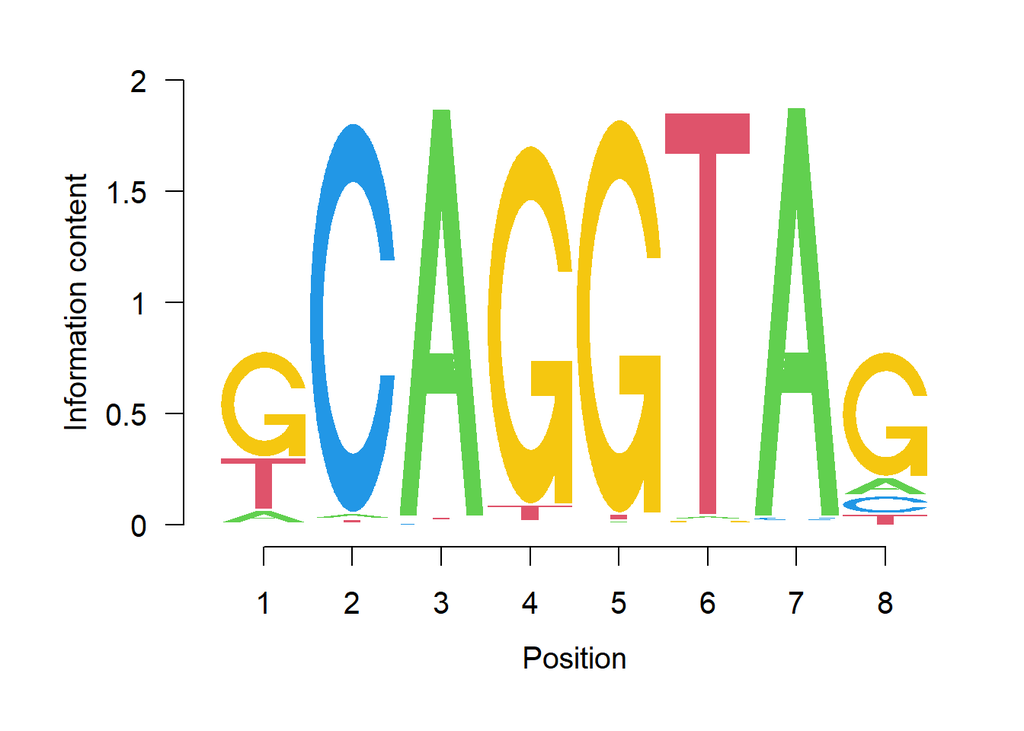

```r
zldPWM <- zldPWM[5:12,] # will trim off the low information positions
tzldPWM <- t(zldPWM)

seqLogo(tzldPWM)
```

Save PWM.

```r
pdf(file = "../Plots/zld-dme.pdf", width = 6,height = 5)

seqLogo(tzldPWM)

dev.off()
```

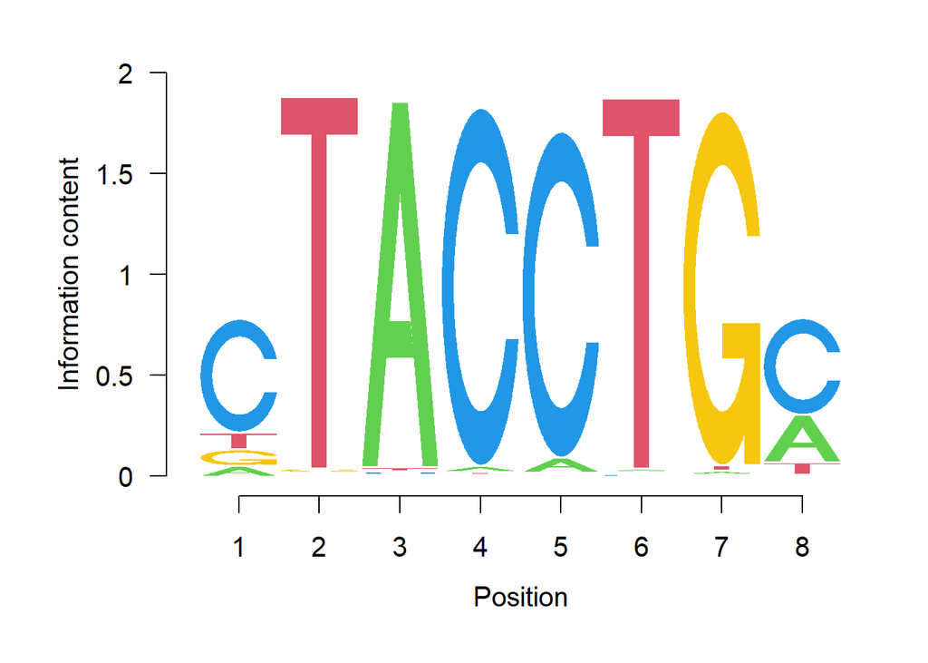

```r
tzldPWMRevCom <- t(reverseComplement(zldPWM))
seqLogo(tzldPWMRevCom)
```

Now we will get sequences for peaks, this sequence will be searched for the PWM using matchPWM.

```r
genome(Calbipunctata) <- "ca6"
seq.peaks <- getSeq(Calbipunctata,peaks.32157)
```

Zld PWM in peaks. We will search both strands.

```r
zld.peak <- lapply(seq.peaks, function(x){
  matchPWM(tzldPWM, subject = x, min.score = "80%",with.score = TRUE)
})

zld.peak.rc <- lapply(seq.peaks, function(x){
  matchPWM(tzldPWMRevCom, subject = x, min.score = "80%",with.score = TRUE)
})
```

Create a vector of peaks with a match.

```r
# peaks with at least one match will have a length greater than 0
n.zld.peak <- zld.peak[lengths(zld.peak) > 0]
n.zld.peak.rc <- zld.peak.rc[lengths(zld.peak.rc) > 0]
```

Peaks with at least one Zld motif.

```r
length(unique(c(names(n.zld.peak),names(n.zld.peak.rc))))
```

[output not shown]

```r
paste0("percent of peaks with a zld motif ",
       round(length(unique(c(names(n.zld.peak),names(n.zld.peak.rc))))/(length(peaks.32157))*100,1),"%")
```

[output not shown]

##### Opa

This is already a frequency matrix.

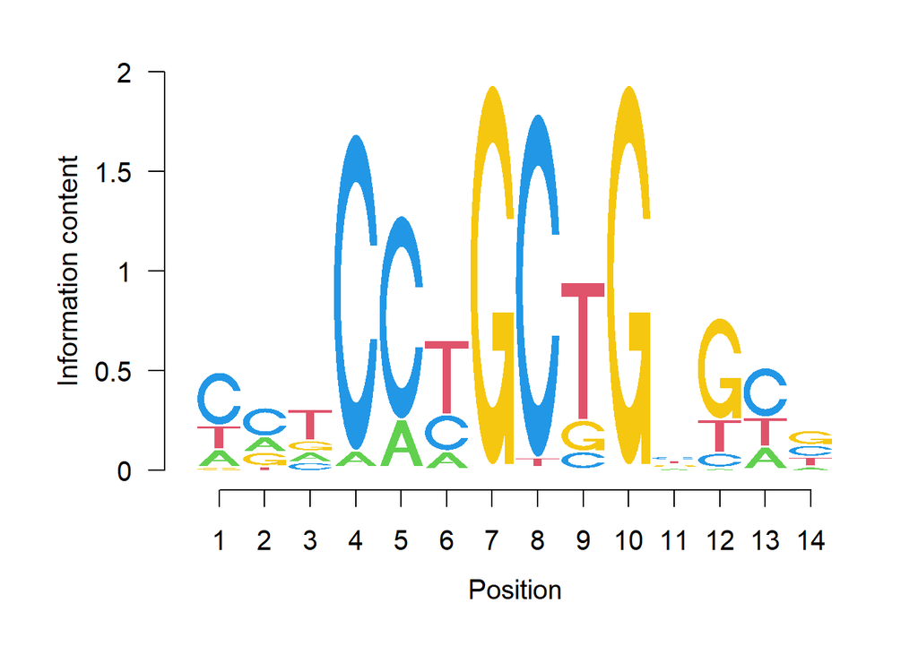

```r
opaPWM <- as.matrix(read.table("../PWMs/Opa_PWM_from_ATAC_wt_late_MEME.txt", header = FALSE, sep =" "))

colnames(opaPWM) <- c("A","C","G","T")

#is.matrix(opaPWM)
topaPWM <- t(opaPWM)
seqLogo(topaPWM)
```

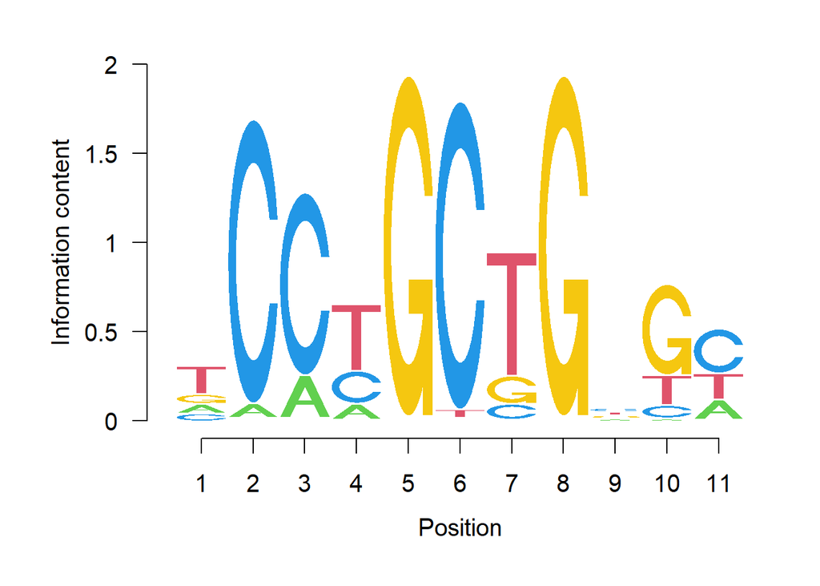

```r
opaPWM <- opaPWM[3:13,]   # will trim off the low information positions
topaPWM <- t(opaPWM)
#topaPWM
seqLogo(topaPWM)
```

Save PWM.

```r
pdf(file = "../Plots/opa-dme-blythe.pdf", width = 6,height = 5)

seqLogo(topaPWM)

dev.off()
```

Reverse complement Opa PWM

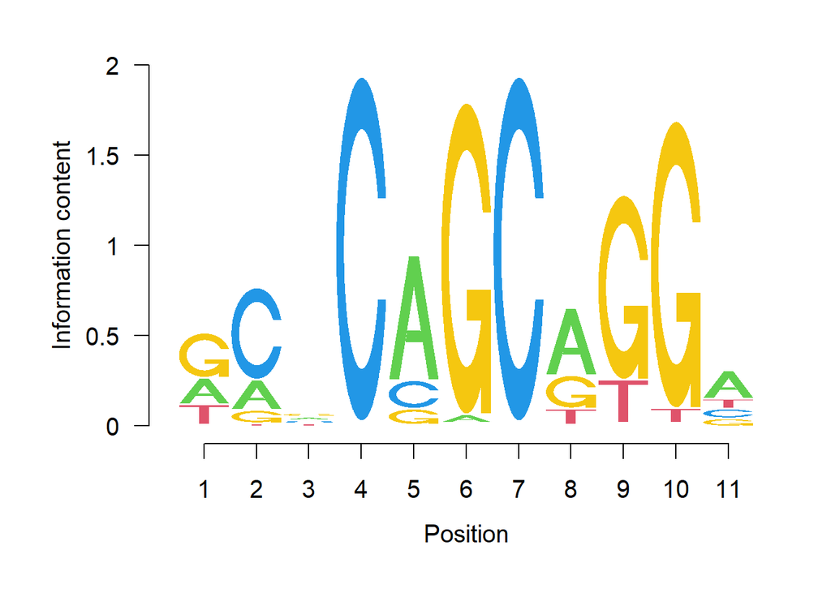

```r
topaPWMRevCom <- t(reverseComplement(opaPWM))
seqLogo(topaPWMRevCom)
```

Opa PWM in peaks. We will search both strands.

```r
opa.peak <- lapply(seq.peaks, function(x){
  matchPWM(topaPWM, subject = x, min.score = "80%",with.score = TRUE)
})

opa.peak.rc <- lapply(seq.peaks, function(x){
  matchPWM(topaPWMRevCom, subject = x, min.score = "80%",with.score = TRUE)
})
```

Create a vector of peaks with a match.

```r
# peaks with at least one match will have a length greater than 0
n.opa.peak <- opa.peak[lengths(opa.peak) > 0]
n.opa.peak.rc <- opa.peak.rc[lengths(opa.peak.rc) > 0]
```

Peaks with at least one Opa motif.

```r
length(unique(c(names(n.opa.peak),names(n.opa.peak.rc))))
```

```
## [1] 3285
```

```r
paste0("percent of peaks with an opa motif ",
       round(length(unique(c(names(n.opa.peak),names(n.opa.peak.rc))))/(length(peaks.32157))*100,1),"%")
```

```
## [1] "percent of peaks with an opa motif 10.2%"
```

##### Motif table

Create a motif table denoting if a peak has a Zld or Opa motif.

Create a logical vector of peaks with a match on the forward or reverse strand for both motifs.

```r
opa.peaks.l <- names(peaks.32157) %in% names(n.opa.peak)
opa.peaks.rc.l <- names(peaks.32157) %in% names(n.opa.peak.rc)

zld.peaks.l <- names(peaks.32157) %in% names(n.zld.peak)
zld.peaks.rc.l <- names(peaks.32157) %in% names(n.zld.peak.rc)
```

Construct the df.

```r
motif.table <- data.frame(peak.name = names(peaks.32157),
                          opa.sites = opa.peaks.l,
                          opa.sites.rc = opa.peaks.rc.l,
                          zld.sites = zld.peaks.l,
                          zld.sites.rc = zld.peaks.rc.l)


head(motif.table)
```

```
##                  peak.name opa.sites opa.sites.rc zld.sites zld.sites.rc
## 1   scaffold_1:39064-39403     FALSE        FALSE     FALSE        FALSE
## 2   scaffold_1:41080-41159     FALSE        FALSE     FALSE        FALSE
## 3   scaffold_1:46323-46446     FALSE        FALSE     FALSE        FALSE
## 4 scaffold_1:113573-113903     FALSE        FALSE     FALSE         TRUE
## 5 scaffold_1:114565-114639     FALSE        FALSE     FALSE        FALSE
## 6 scaffold_1:116022-116187     FALSE        FALSE      TRUE        FALSE
```

### Save results section 1

Tables

The data that summarizes this section are in 5 dfs

1. peaks.open.by.stage with the number of peaks called in each stage
2. The de.results.table containing the WT timecourse DESeq2 results
3. The patterns.group.table of dynamic peaks and the dynamic peak groups
4. The genomic.feature.peaks table categorizing the genomic feature of each peak
5. The motif.table of zld and opa motifs

```r
head(peaks.open.by.stage)
```

```
##                  peak.name open.at.NC11 open.at.NC12 open.at.NC13 open.at.NC14
## 1   scaffold_1:39064-39403         TRUE         TRUE         TRUE         TRUE
## 2   scaffold_1:41080-41159        FALSE        FALSE        FALSE        FALSE
## 3   scaffold_1:46323-46446        FALSE        FALSE        FALSE         TRUE
## 4 scaffold_1:113573-113903         TRUE         TRUE         TRUE         TRUE
## 5 scaffold_1:114565-114639        FALSE        FALSE        FALSE        FALSE
## 6 scaffold_1:116022-116187         TRUE         TRUE         TRUE         TRUE
##   open.at.LNC14
## 1          TRUE
## 2         FALSE
## 3         FALSE
## 4          TRUE
## 5         FALSE
## 6          TRUE
```

```r
head(de.results.table)
```

```
##                  peak.name baseMean.de padj.nc12.v.nc11 lfc.nc12.v.nc11
## 1   scaffold_1:39064-39403    76.28291           0.6301         0.50570
## 2   scaffold_1:46323-46446    12.99380           0.9205        -0.15980
## 3 scaffold_1:113573-113903   180.13612           0.9605        -0.05152
## 4 scaffold_1:114565-114639    20.88217           0.9589        -0.09461
## 5 scaffold_1:116022-116187   122.09435           0.8517         0.15940
## 6 scaffold_1:126620-126698    22.65121           0.8448         0.23890
##   padj.nc13.v.nc12 lfc.nc13.v.nc12 padj.nc14.v.nc13 lfc.nc14.v.nc13
## 1           0.7799         -0.2216          0.02787        -0.90130
## 2           0.8377         -0.2149          0.72900        -0.21260
## 3           0.8222         -0.1371          0.89590        -0.05192
## 4           0.4067         -0.7404          0.73960        -0.23290
## 5           0.6215          0.2511          0.27690        -0.33660
## 6           0.3802         -0.5734          0.98310        -0.01205
##   padj.lnc14.v.nc14 lfc.lnc14.v.nc14
## 1            0.8720          -0.2544
## 2            0.2202          -1.2010
## 3            0.5969           0.4129
## 4            0.8352           0.3909
## 5            0.9257          -0.1168
## 6            0.9463           0.1204
```

```r
head(patterns.group.table)
```

```
##                  peak.name group.1 group.2 group.3 group.4 group.5 group.6
## 1   scaffold_1:39064-39403   FALSE   FALSE   FALSE   FALSE   FALSE   FALSE
## 2   scaffold_1:41080-41159   FALSE   FALSE   FALSE   FALSE   FALSE   FALSE
## 3   scaffold_1:46323-46446   FALSE   FALSE   FALSE   FALSE   FALSE   FALSE
## 4 scaffold_1:113573-113903   FALSE   FALSE   FALSE   FALSE   FALSE   FALSE
## 5 scaffold_1:114565-114639   FALSE   FALSE   FALSE   FALSE   FALSE   FALSE
## 6 scaffold_1:116022-116187   FALSE   FALSE   FALSE   FALSE   FALSE   FALSE
##   group.7 group.8 group.9 group.10 group.11 group.12 group.13 group.14 group.15
## 1   FALSE   FALSE   FALSE    FALSE    FALSE    FALSE    FALSE    FALSE    FALSE
## 2   FALSE   FALSE   FALSE    FALSE    FALSE    FALSE    FALSE    FALSE    FALSE
## 3   FALSE   FALSE   FALSE    FALSE    FALSE    FALSE    FALSE    FALSE    FALSE
## 4   FALSE   FALSE   FALSE    FALSE    FALSE    FALSE    FALSE    FALSE    FALSE
## 5   FALSE   FALSE   FALSE    FALSE    FALSE    FALSE    FALSE    FALSE    FALSE
## 6   FALSE   FALSE   FALSE    FALSE    FALSE    FALSE    FALSE    FALSE    FALSE
##   group.16 group.17 group.18 group.19 group.20 group.21 dynamic.peak
## 1    FALSE    FALSE    FALSE    FALSE    FALSE    FALSE        FALSE
## 2    FALSE    FALSE    FALSE    FALSE    FALSE    FALSE        FALSE
## 3    FALSE    FALSE    FALSE    FALSE    FALSE    FALSE        FALSE
## 4    FALSE    FALSE    FALSE    FALSE    FALSE    FALSE        FALSE
## 5    FALSE    FALSE    FALSE    FALSE    FALSE    FALSE        FALSE
## 6    FALSE    FALSE    FALSE    FALSE    FALSE    FALSE        FALSE
##   non.dynamic.peak dynamic.in.class
## 1             TRUE            FALSE
## 2             TRUE            FALSE
## 3             TRUE            FALSE
## 4             TRUE            FALSE
## 5             TRUE            FALSE
## 6             TRUE            FALSE
```

```r
head(genomic.feature.peaks)
```

```
##                     peak.name intergenic promoter intron  exon genomic.feature
## 3090   scaffold_1:39064-39403       TRUE    FALSE  FALSE FALSE      intergenic
## 3293   scaffold_1:41080-41159      FALSE     TRUE  FALSE FALSE        promoter
## 3934   scaffold_1:46323-46446      FALSE    FALSE   TRUE FALSE          intron
## 91   scaffold_1:113573-113903      FALSE    FALSE   TRUE FALSE          intron
## 121  scaffold_1:114565-114639      FALSE    FALSE   TRUE  TRUE exon and intron
## 156  scaffold_1:116022-116187      FALSE    FALSE   TRUE  TRUE exon and intron
##      original.row
## 3090            1
## 3293            2
## 3934            3
## 91              4
## 121             5
## 156             6
```

```r
head(motif.table)
```

```
##                  peak.name opa.sites opa.sites.rc zld.sites zld.sites.rc
## 1   scaffold_1:39064-39403     FALSE        FALSE     FALSE        FALSE
## 2   scaffold_1:41080-41159     FALSE        FALSE     FALSE        FALSE
## 3   scaffold_1:46323-46446     FALSE        FALSE     FALSE        FALSE
## 4 scaffold_1:113573-113903     FALSE        FALSE     FALSE         TRUE
## 5 scaffold_1:114565-114639     FALSE        FALSE     FALSE        FALSE
## 6 scaffold_1:116022-116187     FALSE        FALSE      TRUE        FALSE
```

SAVE Tables

```r
de.results.table_merge<- de.results.table %>% merge(x=., y=genomic.feature.peaks, by = "peak.name") %>%
  merge(x=.,y=patterns.group.table, by = "peak.name",all.x = TRUE) %>%
  merge(x=.,y=peaks.open.by.stage, by = "peak.name",all.x = TRUE) %>%
  mutate(class = case_when(
  group.1 == TRUE ~ "group.1",
  group.2 == TRUE ~ "group.2",
  group.3 == TRUE ~ "group.3",
  group.4 == TRUE ~ "group.4",
  group.5 == TRUE ~ "group.5",
  group.6 == TRUE ~ "group.6",
  group.7 == TRUE ~ "group.7",
  group.8 == TRUE ~ "group.8",
  group.9 == TRUE ~ "group.9",
  group.10 == TRUE ~ "group.10",
  group.11 == TRUE ~ "group.11",
  group.12 == TRUE ~ "group.12",
  group.13 == TRUE ~ "group.13",
  group.14 == TRUE ~ "group.14",
  group.15 == TRUE ~ "group.15",
  group.16 == TRUE ~ "group.16",
  group.17 == TRUE ~ "group.17",
  group.18 == TRUE ~ "group.18",
  group.19 == TRUE ~ "group.19",
  group.20 == TRUE ~ "group.20",
  group.21 == TRUE ~ "group.21",
  dynamic.peak == TRUE & dynamic.in.class == FALSE ~ "dynamic not in group",
  dynamic.peak == FALSE & dynamic.in.class == FALSE ~ "not dynamic not in group"))

de.results.table_merge<-de.results.table_merge[, -(16:40)]
head(de.results.table_merge)
```

```r
write.csv(de.results.table_merge, file = "../WT_timecourse/WT_timecourse.all.csv", row.names = F)
```

# Section 2 Cal-Opa

### Background

ATAC-seq was performed on Cal-opa RNAi (specific to the maternal transcript) embryos at NC12 and NC13. RNA was isolated from the ATAC preps and made into RNA-seq libraries. Several control groups were collected for these experiments. 1) Wild-type (WT): untreated embryos. 2) Alignment controls: aligned on the injected slide and not injected. 3) injection controls: aligned on the injected slide and injected with dsRNA targeting dsred. Successful Cal-opa knockdown is determined from the RNA-seq data by a fold change (FC) calculation. The FC calculation of Cal-opa mRNA levels is conducted with the average of control embryos (untreated wild-type and alignment controls) from the same experimental date (embryo batch) as reference. Cal-opa RNAi embryos with a FC < 0.25 (knockdown efficiency greater than 75%) were used for further analysis.

Differential enrichment analysis on the ATAC- and RNA-seq data at both timepoints will be performed using DESeq2. The DESeq2 model will be generated from all experimental groups so that wide range of variance stemming from “genotype” and technical manipulation is accounted for. In the text only the results of the Cal-opa KDs vs alignment control (ac) comparison is reported for both ATAC and RNA-seq DE analysis. This serves to simplify reporting and avoids masking the real biological effects.

Section overview:

1. Identify Cal-opa KDs at NC12 and NC13
2. DESeq2 analysis setup.
3. NC12 DE analysis of RNA-seq data and ATAC-seq data.

Identify significant differentially expressed genes (DE genes/degs) upon Cal-opa KD. Identify significant differentially accessible (DA peaks/ daps) upon Cal-opa KD.

4. NC13 DE analysis of RNA-seq data and ATAC-seq data.

Identify significant differentially expressed genes (DE genes/degs) upon Cal-opa. Identify significant differentially accessible (DA peaks/ daps) upon Cal-opa KD.

5. Motif enrichment analysis of DA peaks using MEME.
6. Identify Cal-Opa targets at NC12 and NC13.

Identify how many degs are transcription factors (TFs). In the annotation data the GO term “GO:0003700” for TF and COG symbol “K” for transcription is used to identify these genes. Identify “key” Cal-Opa targets. Key Cal-Opa targets will be identified as DE TFs whose loci has one or more Opa motif positive Cal-Opa sensitive ATAC-seq peaks.

7. Evaluate how Bicoid (Bcd) targets are affected by Cal-Opa depletion in Clogmia

Addendum 8. Repeat of NC12 analysis with one injection control outlier removed.

Hence forth Cal-opa/Cal-Opa may be shortened to opa/Opa.

#### Data

##### Create coldata for RNA-seq and ATAC-seq data

The information contained in the coldatas will match, except the rownames (added later) will be different corresponding to the sample id in the RNA- or ATAC-seq data.

```r
opa.results.folder<-"../opaKD/"
```

NC12

```r
nc12.opakd.coldata.rna <- all.coldata %>%
  filter(.,Experiment == "opaKD") %>%
  filter(.,Stage == "NC12")
head(nc12.opakd.coldata.rna)
```

```
##      Sample.name.full embryo   treatment.group alignment   injection Stage
## 1    wt.1.NC12.opaKD2      1                wt     FALSE        none  NC12
## 2    ac.1.NC12.opaKD2      2 alignment control      TRUE        none  NC12
## 3 dsred.1.NC12.opaKD2      3 injection control      TRUE dsred dsRNA  NC12
## 4   opa.1.NC12.opaKD2      4               opa      TRUE   opa dsRNA  NC12
## 5    wt.2.NC12.opaKD5      5                wt     FALSE        none  NC12
## 6    ac.2.NC12.opaKD5      6 alignment control      TRUE        none  NC12
##   Dev.time Experiment Experiment.Date ATAC.and.RNA   TDE.ref.lot.num
## 1    4h58m      opaKD          230518          yes 15027916/20654347
## 2    5h01m      opaKD          230518          yes 15027916/20654347
## 3    5h02m      opaKD          230518          yes 15027916/20654347
## 4    5h05m      opaKD          230518          yes 15027916/20654347
## 5    4h59m      opaKD          230627          yes 15027916/20723216
## 6    4h57m      opaKD          230627          yes 15027916/20723216
##     sample.id.atac    sample.id.rna sample.id.rna.2 instrument.atac.data
## 1 23003FL-06-01-18 23003FL-09-02-01              NA       NovaSeq X Plus
## 2 23003FL-06-01-19 23003FL-09-02-02              NA       NovaSeq X Plus
## 3 23003FL-06-01-20 23003FL-09-02-03              NA       NovaSeq X Plus
## 4 23003FL-06-01-21 23003FL-09-02-04              NA       NovaSeq X Plus
## 5 23003FL-06-01-35 23003FL-09-02-20              NA       NovaSeq X Plus
## 6 23003FL-06-01-36 23003FL-09-02-21              NA       NovaSeq X Plus
##   instrument.rna.data
## 1      NovaSeq X Plus
## 2      NovaSeq X Plus
## 3      NovaSeq X Plus
## 4      NovaSeq X Plus
## 5      NovaSeq X Plus
## 6      NovaSeq X Plus
```

```r
nc12.opakd.coldata.atac <- all.coldata %>%
  filter(.,Experiment == "opaKD") %>%
  filter(.,Stage == "NC12")
head(nc12.opakd.coldata.atac)
```

```
##      Sample.name.full embryo   treatment.group alignment   injection Stage
## 1    wt.1.NC12.opaKD2      1                wt     FALSE        none  NC12
## 2    ac.1.NC12.opaKD2      2 alignment control      TRUE        none  NC12
## 3 dsred.1.NC12.opaKD2      3 injection control      TRUE dsred dsRNA  NC12
## 4   opa.1.NC12.opaKD2      4               opa      TRUE   opa dsRNA  NC12
## 5    wt.2.NC12.opaKD5      5                wt     FALSE        none  NC12
## 6    ac.2.NC12.opaKD5      6 alignment control      TRUE        none  NC12
##   Dev.time Experiment Experiment.Date ATAC.and.RNA   TDE.ref.lot.num
## 1    4h58m      opaKD          230518          yes 15027916/20654347
## 2    5h01m      opaKD          230518          yes 15027916/20654347
## 3    5h02m      opaKD          230518          yes 15027916/20654347
## 4    5h05m      opaKD          230518          yes 15027916/20654347
## 5    4h59m      opaKD          230627          yes 15027916/20723216
## 6    4h57m      opaKD          230627          yes 15027916/20723216
##     sample.id.atac    sample.id.rna sample.id.rna.2 instrument.atac.data
## 1 23003FL-06-01-18 23003FL-09-02-01              NA       NovaSeq X Plus
## 2 23003FL-06-01-19 23003FL-09-02-02              NA       NovaSeq X Plus
## 3 23003FL-06-01-20 23003FL-09-02-03              NA       NovaSeq X Plus
## 4 23003FL-06-01-21 23003FL-09-02-04              NA       NovaSeq X Plus
## 5 23003FL-06-01-35 23003FL-09-02-20              NA       NovaSeq X Plus
## 6 23003FL-06-01-36 23003FL-09-02-21              NA       NovaSeq X Plus
##   instrument.rna.data
## 1      NovaSeq X Plus
## 2      NovaSeq X Plus
## 3      NovaSeq X Plus
## 4      NovaSeq X Plus
## 5      NovaSeq X Plus
## 6      NovaSeq X Plus
```

NC13

```r
nc13.opakd.coldata.rna <- all.coldata %>%
  filter(.,Experiment == "opaKD") %>%
  filter(.,Stage == "NC13")

head(nc13.opakd.coldata.rna)
```

```
##      Sample.name.full embryo   treatment.group alignment   injection Stage
## 1    wt.1.NC13.opaKD1      1                wt     FALSE        none  NC13
## 2    ac.1.NC13.opaKD1      2 alignment control      TRUE        none  NC13
## 3 dsred.2.NC13.opaKD1      3 injection control      TRUE dsred dsRNA  NC13
## 4   opa.2.NC13.opaKD1      4               opa      TRUE   opa dsRNA  NC13
## 5   opa.3.NC13.opaKD1      5               opa      TRUE   opa dsRNA  NC13
## 6   opa.4.NC13.opaKD1      6               opa      TRUE   opa dsRNA  NC13
##   Dev.time Experiment Experiment.Date ATAC.and.RNA   TDE.ref.lot.num
## 1    5h07m      opaKD          230511          yes 15027916/20654347
## 2    5h09m      opaKD          230511          yes 15027916/20654347
## 3    5h12m      opaKD          230511          yes 15027916/20654347
## 4    5h16m      opaKD          230511          yes 15027916/20654347
## 5    5h18m      opaKD          230511          yes 15027916/20654347
## 6    5h19m      opaKD          230511          yes 15027916/20654347
##     sample.id.atac    sample.id.rna sample.id.rna.2 instrument.atac.data
## 1 23003FL-06-01-10 23003FL-09-01-25              NA       NovaSeq X Plus
## 2 23003FL-06-01-11 23003FL-09-01-26              NA       NovaSeq X Plus
## 3 23003FL-06-01-13 23003FL-09-01-27              NA       NovaSeq X Plus
## 4 23003FL-06-01-15 23003FL-09-01-28              NA       NovaSeq X Plus
## 5 23003FL-06-01-16 23003FL-09-01-29              NA       NovaSeq X Plus
## 6 23003FL-06-01-17 23003FL-09-01-30              NA       NovaSeq X Plus
##   instrument.rna.data
## 1      NovaSeq X Plus
## 2      NovaSeq X Plus
## 3      NovaSeq X Plus
## 4      NovaSeq X Plus
## 5      NovaSeq X Plus
## 6      NovaSeq X Plus
```

```r
nc13.opakd.coldata.atac <- all.coldata %>%
  filter(.,Experiment == "opaKD") %>%
  filter(.,Stage == "NC13")

head(nc13.opakd.coldata.atac)
```

```
##      Sample.name.full embryo   treatment.group alignment   injection Stage
## 1    wt.1.NC13.opaKD1      1                wt     FALSE        none  NC13
## 2    ac.1.NC13.opaKD1      2 alignment control      TRUE        none  NC13
## 3 dsred.2.NC13.opaKD1      3 injection control      TRUE dsred dsRNA  NC13
## 4   opa.2.NC13.opaKD1      4               opa      TRUE   opa dsRNA  NC13
## 5   opa.3.NC13.opaKD1      5               opa      TRUE   opa dsRNA  NC13
## 6   opa.4.NC13.opaKD1      6               opa      TRUE   opa dsRNA  NC13
##   Dev.time Experiment Experiment.Date ATAC.and.RNA   TDE.ref.lot.num
## 1    5h07m      opaKD          230511          yes 15027916/20654347
## 2    5h09m      opaKD          230511          yes 15027916/20654347
## 3    5h12m      opaKD          230511          yes 15027916/20654347
## 4    5h16m      opaKD          230511          yes 15027916/20654347
## 5    5h18m      opaKD          230511          yes 15027916/20654347
## 6    5h19m      opaKD          230511          yes 15027916/20654347
##     sample.id.atac    sample.id.rna sample.id.rna.2 instrument.atac.data
## 1 23003FL-06-01-10 23003FL-09-01-25              NA       NovaSeq X Plus
## 2 23003FL-06-01-11 23003FL-09-01-26              NA       NovaSeq X Plus
## 3 23003FL-06-01-13 23003FL-09-01-27              NA       NovaSeq X Plus
## 4 23003FL-06-01-15 23003FL-09-01-28              NA       NovaSeq X Plus
## 5 23003FL-06-01-16 23003FL-09-01-29              NA       NovaSeq X Plus
## 6 23003FL-06-01-17 23003FL-09-01-30              NA       NovaSeq X Plus
##   instrument.rna.data
## 1      NovaSeq X Plus
## 2      NovaSeq X Plus
## 3      NovaSeq X Plus
## 4      NovaSeq X Plus
## 5      NovaSeq X Plus
## 6      NovaSeq X Plus
```

Check that the samples in both sets of coldata match.

```r
all(nc12.opakd.coldata.rna$Sample.name.full == nc12.opakd.coldata.atac$Sample.name.full)
```

```
## [1] TRUE
```

```r
all(nc13.opakd.coldata.rna$Sample.name.full == nc13.opakd.coldata.atac$Sample.name.full)
```

```
## [1] TRUE
```

#### Cal-opa RNA-seq data and ATAC-seq data

##### RNA-seq data

This GRanges object contains all RNA-seq reads for all samples.

Sample names in the GRanges will match information in the columns of the coldata.

The naming convention is coldata$Sample.name.full"."coldata$sample.id.rna.

The Sample.name.full will correspond to only one sample.

NC12

```r
load("../GRanges/opakd-nc12-rnaseq.GRanges.R")

head(opakd.nc12.rnaseq)
```

```
## GRangesList object of length 6:
## $wt.1.NC12.opaKD2.23003FL.09.02.01
## GRanges object with 21063394 ranges and 0 metadata columns:
##                seqnames            ranges strand
##                   <Rle>         <IRanges>  <Rle>
##          [1] scaffold_1       48383-48452      +
##          [2] scaffold_1       62323-62397      -
##          [3] scaffold_1       70457-70599      -
##          [4] scaffold_1       70978-71055      +
##          [5] scaffold_1       72848-72891      +
##          ...        ...               ...    ...
##   [21063390] scaffold_7 51659662-51659824      +
##   [21063391] scaffold_7 51659662-51659824      +
##   [21063392] scaffold_7 51659655-51659824      -
##   [21063393] scaffold_7 51659703-51659834      +
##   [21063394] scaffold_7 51659655-51659824      -
##   -------
##   seqinfo: 6 sequences from ca6 genome
##
## ...
## <5 more elements>
```

NC13

```r
load("../GRanges/opakd-nc13-rnaseq.GRanges.R")

head(opakd.nc13.rnaseq)
```

```
## GRangesList object of length 6:
## $wt.1.NC13.opaKD1.23003FL.09.01.25
## GRanges object with 18473921 ranges and 0 metadata columns:
##                seqnames            ranges strand
##                   <Rle>         <IRanges>  <Rle>
##          [1] scaffold_1       43358-45143      -
##          [2] scaffold_1       43358-45143      -
##          [3] scaffold_1       43358-45143      -
##          [4] scaffold_1       45675-45724      -
##          [5] scaffold_1       61695-61761      +
##          ...        ...               ...    ...
##   [18473917] scaffold_7 51659338-51659376      +
##   [18473918] scaffold_7 51665341-51665616      +
##   [18473919] scaffold_7 51665374-51666105      +
##   [18473920] scaffold_7 51665360-51665622      -
##   [18473921] scaffold_7 51665488-51665568      +
##   -------
##   seqinfo: 6 sequences from ca6 genome
##
## ...
## <5 more elements>
```

##### ATAC-seq data

This GRanges object contains all open ATAC-seq reads ( <= 120 bp) for all samples.

Sample names in the GRanges will match information in the columns of the coldata.

The naming convention is coldata$Sample.name.full"."coldata$sample.id.atac.

The Sample.name.full will correspond to only one sample.

```r
load("../GRanges/opakd-nc12-openreads.GRanges.R")

head(opakd.nc12.openreads)
```

```
## GRangesList object of length 6:
## $wt.1.NC12.opaKD2.23003FL.06.01.18
## GRanges object with 9079609 ranges and 0 metadata columns:
##               seqnames            ranges strand
##                  <Rle>         <IRanges>  <Rle>
##         [1] scaffold_1       23421-23495      +
##         [2] scaffold_1       23436-23505      +
##         [3] scaffold_1       35960-36032      +
##         [4] scaffold_1       35960-36032      +
##         [5] scaffold_1       37644-37726      +
##         ...        ...               ...    ...
##   [9079605] scaffold_7 51667151-51667202      +
##   [9079606] scaffold_7 51667180-51667242      -
##   [9079607] scaffold_7 51667198-51667254      +
##   [9079608] scaffold_7 51667198-51667254      +
##   [9079609] scaffold_7 51700431-51700519      +
##   -------
##   seqinfo: 6 sequences from ca6 genome
##
## ...
## <5 more elements>
```

```r
load("../GRanges/opakd-nc13-openreads.GRanges.R")

head(opakd.nc13.openreads)
```

```
## GRangesList object of length 6:
## $wt.1.NC13.opaKD1.23003FL.06.01.10
## GRanges object with 4405416 ranges and 0 metadata columns:
##               seqnames            ranges strand
##                  <Rle>         <IRanges>  <Rle>
##         [1] scaffold_1       23412-23461      +
##         [2] scaffold_1       37241-37314      -
##         [3] scaffold_1       38694-38744      -
##         [4] scaffold_1       39021-39089      -
##         [5] scaffold_1       39073-39138      -
##         ...        ...               ...    ...
##   [4405412] scaffold_7 51667164-51667254      -
##   [4405413] scaffold_7 51667167-51667218      +
##   [4405414] scaffold_7 51667180-51667252      +
##   [4405415] scaffold_7 51667206-51667256      -
##   [4405416] scaffold_7 51697133-51697227      +
##   -------
##   seqinfo: 6 sequences from ca6 genome
##
## ...
## <5 more elements>
```

find the nearby gene for every peak

```r
peak_annotation<-as.data.frame(annotatePeak(peaks.32157, tssRegion=c(-3000, 3000), TxDb=calbi.txdb))
```

```
## >> preparing features information...      2026-05-11 10:31:19 PM
## >> identifying nearest features...        2026-05-11 10:31:19 PM
## >> calculating distance from peak to TSS...   2026-05-11 10:31:19 PM
## >> assigning genomic annotation...        2026-05-11 10:31:19 PM
## >> assigning chromosome lengths           2026-05-11 10:31:22 PM
## >> done...                    2026-05-11 10:31:22 PM
```

```r
row.names(peak_annotation)<- paste0(seqnames(peaks.32157), ":", start(peaks.32157), "-", end(peaks.32157))
```

## 1. Identify knockdowns

Now we will identify KDs by calculating the fold change (FC) of opa for each sample for both stages.

First we create a count matrix of RNA-seq counts per gene.

Then we create a CPM matrix that will be used in the fold change calculation.

The FC calculation of Cal-opa mRNA levels is conducted with the average of control embryos (untreated wild-type and alignment controls) from the same embryo batch (experimental date) as reference.

In the annotation of Clogmia albipunctata the opa gene is “evm.TU.scaffold_7.878”.

##### RNA counts matrix

We will first generate a RNA counts matrix of sample counts per gene.

We will use the countOverlap function to count RNA-seq reads within the gene transcript (transcripts.by.gene).

The count matrix will be normalize CPM for the FC calculation

The raw counts matrix will be used for DESeq2 analysis (in proceeding sections).

NC12

```r
nc12.opakd.counts.rna <- lapply(opakd.nc12.rnaseq, function(x) countOverlaps(transcripts.by.gene,x))
nc12.opakd.counts.rna <- do.call("cbind",nc12.opakd.counts.rna) # force the counts data into a table format where rows are genes and columns are samples

head(nc12.opakd.counts.rna[,1:6])
```

```
##                        wt.1.NC12.opaKD2.23003FL.09.02.01
## evm.TU.scaffold_1.10                                   0
## evm.TU.scaffold_1.100                                  0
## evm.TU.scaffold_1.1000                              1244
## evm.TU.scaffold_1.1001                               413
## evm.TU.scaffold_1.1002                               266
## evm.TU.scaffold_1.1003                              5060
##                        ac.1.NC12.opaKD2.23003FL.09.02.02
## evm.TU.scaffold_1.10                                   0
## evm.TU.scaffold_1.100                                  0
## evm.TU.scaffold_1.1000                              1707
## evm.TU.scaffold_1.1001                               668
## evm.TU.scaffold_1.1002                               232
## evm.TU.scaffold_1.1003                              5194
##                        dsred.1.NC12.opaKD2.23003FL.09.02.03
## evm.TU.scaffold_1.10                                      0
## evm.TU.scaffold_1.100                                     0
## evm.TU.scaffold_1.1000                                 1771
## evm.TU.scaffold_1.1001                                  419
## evm.TU.scaffold_1.1002                                  226
## evm.TU.scaffold_1.1003                                 6005
##                        opa.1.NC12.opaKD2.23003FL.09.02.04
## evm.TU.scaffold_1.10                                    0
## evm.TU.scaffold_1.100                                   0
## evm.TU.scaffold_1.1000                               1669
## evm.TU.scaffold_1.1001                                428
## evm.TU.scaffold_1.1002                                330
## evm.TU.scaffold_1.1003                               6812
##                        wt.2.NC12.opaKD5.23003FL.09.02.20
## evm.TU.scaffold_1.10                                   0
## evm.TU.scaffold_1.100                                  0
## evm.TU.scaffold_1.1000                              2601
## evm.TU.scaffold_1.1001                               289
## evm.TU.scaffold_1.1002                               295
## evm.TU.scaffold_1.1003                             12901
##                        ac.2.NC12.opaKD5.23003FL.09.02.21
## evm.TU.scaffold_1.10                                   0
## evm.TU.scaffold_1.100                                  0
## evm.TU.scaffold_1.1000                              1101
## evm.TU.scaffold_1.1001                               593
## evm.TU.scaffold_1.1002                               192
## evm.TU.scaffold_1.1003                              5158
```

NC13

```r
nc13.opakd.counts.rna <- lapply(opakd.nc13.rnaseq, function(x) countOverlaps(transcripts.by.gene,x))
nc13.opakd.counts.rna <- do.call("cbind",nc13.opakd.counts.rna) # force the counts data into a table format where rows are genes and columns are samples

head(nc13.opakd.counts.rna[,1:6])
```

```
##                        wt.1.NC13.opaKD1.23003FL.09.01.25
## evm.TU.scaffold_1.10                                   0
## evm.TU.scaffold_1.100                                  0
## evm.TU.scaffold_1.1000                              1185
## evm.TU.scaffold_1.1001                               220
## evm.TU.scaffold_1.1002                               268
## evm.TU.scaffold_1.1003                              9754
##                        ac.1.NC13.opaKD1.23003FL.09.01.26
## evm.TU.scaffold_1.10                                   0
## evm.TU.scaffold_1.100                                  2
## evm.TU.scaffold_1.1000                              1761
## evm.TU.scaffold_1.1001                               244
## evm.TU.scaffold_1.1002                               402
## evm.TU.scaffold_1.1003                             12284
##                        dsred.2.NC13.opaKD1.23003FL.09.01.27
## evm.TU.scaffold_1.10                                      0
## evm.TU.scaffold_1.100                                     0
## evm.TU.scaffold_1.1000                                  987
## evm.TU.scaffold_1.1001                                  183
## evm.TU.scaffold_1.1002                                  180
## evm.TU.scaffold_1.1003                                 6024
##                        opa.2.NC13.opaKD1.23003FL.09.01.28
## evm.TU.scaffold_1.10                                    0
## evm.TU.scaffold_1.100                                   0
## evm.TU.scaffold_1.1000                               1891
## evm.TU.scaffold_1.1001                                381
## evm.TU.scaffold_1.1002                                409
## evm.TU.scaffold_1.1003                              12511
##                        opa.3.NC13.opaKD1.23003FL.09.01.29
## evm.TU.scaffold_1.10                                    0
## evm.TU.scaffold_1.100                                   3
## evm.TU.scaffold_1.1000                               1040
## evm.TU.scaffold_1.1001                                330
## evm.TU.scaffold_1.1002                                286
## evm.TU.scaffold_1.1003                               6074
##                        opa.4.NC13.opaKD1.23003FL.09.01.30
## evm.TU.scaffold_1.10                                    0
## evm.TU.scaffold_1.100                                   0
## evm.TU.scaffold_1.1000                               1125
## evm.TU.scaffold_1.1001                                201
## evm.TU.scaffold_1.1002                                271
## evm.TU.scaffold_1.1003                               9771
```

Now we will CPM normalize the count data for each stage.

NC12

```r
nc12.opakd.colsums <- colSums(nc12.opakd.counts.rna) # total counts for each sample


nc12.opakd.cpm <- sweep(x = nc12.opakd.counts.rna, MARGIN = 2, STATS = nc12.opakd.colsums, FUN = '/') # For each sample divide each count by the total counts

nc12.opakd.cpm <- nc12.opakd.cpm*1e6 # Multiple by 1M to get CPM


table(round(colSums(nc12.opakd.cpm))) # double check the sum is 1M
```

```
##
## 1e+06
##    15
```

NC13

```r
nc13.opakd.colsums <- colSums(nc13.opakd.counts.rna) # total counts for each sample

nc13.opakd.cpm <- sweep(x = nc13.opakd.counts.rna, MARGIN = 2, STATS = nc13.opakd.colsums, FUN = '/')  # For each sample divide each count by the total counts

nc13.opakd.cpm <- nc13.opakd.cpm*1e6 # Multiple by 1M to get CPM

table(round(colSums(nc13.opakd.cpm))) # double check the sum is 1M
```

```
##
## 1e+06
##    18
```

We will create a FC df (fc.table) for each stage containing the sample name, treatment group, embryo batch (Experiment.Date) and opa CPMs.

Starting with NC12.

#### FC calculation NC12

```r
nc12.fc.table <- data.frame(Sample.name.full = nc12.opakd.coldata.rna$Sample.name.full,
                            treatment.group = nc12.opakd.coldata.rna$treatment.group,
                            Experiment.Date = nc12.opakd.coldata.rna$Experiment.Date,
                            opa.cpm=nc12.opakd.cpm["evm.TU.scaffold_7.878",])
```

Get the averaged opa CPM for control samples (wt and alignment) by embryo batch.

```r
opa.cpm.wt.ac.avg.by.date.nc12 <- nc12.fc.table %>%
  filter(.,treatment.group == "wt" | treatment.group == "alignment control") %>%
  group_by(.,Experiment.Date) %>%
  summarize(.,mean(opa.cpm))
```

Add the averaged control CPM to the fc.table, each will have a column. Then perform the FC calculation by dividing each sample’s CPM by the control CPM from the the same embryo batch. Add the result to the fc.table, producing the the column called “FC”.

```r
nc12.fc.table <- nc12.fc.table %>%
mutate(., opa.cpm.wt.ac.avg.230518 = rep(opa.cpm.wt.ac.avg.by.date.nc12[[1,2]],nrow(nc12.fc.table)),
opa.cpm.wt.ac.avg.230627 = rep(opa.cpm.wt.ac.avg.by.date.nc12[[2,2]],nrow(nc12.fc.table)),
opa.cpm.wt.ac.avg.230629 = rep(opa.cpm.wt.ac.avg.by.date.nc12[[3,2]],nrow(nc12.fc.table))) %>%
  mutate(., FC =case_when(
  Experiment.Date == "230518" ~ opa.cpm/opa.cpm.wt.ac.avg.230518,
  Experiment.Date == "230627" ~ opa.cpm/opa.cpm.wt.ac.avg.230627,
  Experiment.Date == "230629" ~ opa.cpm/opa.cpm.wt.ac.avg.230629))
```

Plot

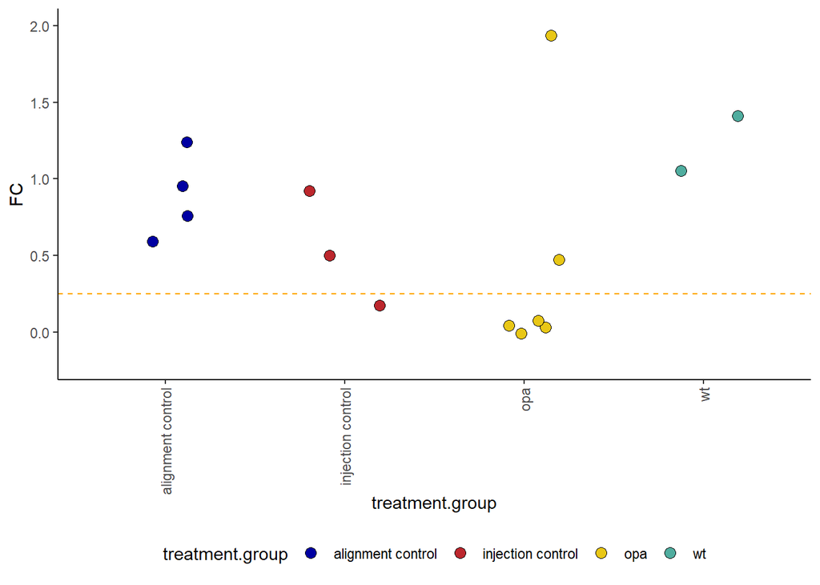

```r
color.code <-c("wt" = "#50ad9f","alignment control" = "#0000A2","injection control"="#bc272d", "opa"="#e9c716")

 nc12.fc.table %>% ggplot(., aes(x= treatment.group, y = FC, fill = treatment.group)) +
  geom_jitter(size = 3,shape = 21, color = "black",width=0.2)+
  scale_fill_manual(values = color.code) +
  ylim(-0.2,2) +
  geom_hline(yintercept = 0.25, linetype = 'dashed', col = 'orange') +
theme(axis.text.x = element_text(angle = 90, vjust = 0.5, hjust=1),
        axis.line = element_line(colour = "black"),
        legend.position = "bottom",
        panel.background = element_blank(),
        panel.grid.major = element_blank(),
    panel.grid.minor = element_blank())
```

4 Cal-opa RNAi embryos have a FC < 0.25

#### FC calculation NC13

Repeat the process done for NC12 for NC13.

```r
nc13.fc.table <- data.frame(Sample.name.full = nc13.opakd.coldata.rna$Sample.name.full,
                            treatment.group = nc13.opakd.coldata.rna$treatment.group,
                            Experiment.Date = nc13.opakd.coldata.rna$Experiment.Date,
                            opa.cpm=nc13.opakd.cpm["evm.TU.scaffold_7.878",])
```

Get the averaged opa CPM for control samples (wt and alignment) by embryo batch.

```r
opa.cpm.wt.ac.avg.by.date.nc13 <- nc13.fc.table %>%
  filter(., treatment.group == "wt" | treatment.group == "alignment control") %>%
  group_by(.,Experiment.Date) %>%
  summarize(.,mean(opa.cpm))
```

Add the averaged control CPM to the fc.table, each will have a column. Then perform the FC calculation by dividing each sample’s CPM by the control CPM from the the same embryo batch. Add the result to the fc.table, producing the the column called “FC”.

```r
nc13.fc.table <- nc13.fc.table %>%
mutate(., opa.cpm.wt.ac.avg.230511 = rep(opa.cpm.wt.ac.avg.by.date.nc13[[1,2]],nrow(nc13.fc.table)),
opa.cpm.wt.ac.avg.230616 =rep(opa.cpm.wt.ac.avg.by.date.nc13[[2,2]],nrow(nc13.fc.table)),
opa.cpm.wt.ac.avg.230622 = rep(opa.cpm.wt.ac.avg.by.date.nc13[[3,2]],nrow(nc13.fc.table))) %>%
  mutate(., FC =case_when(
  Experiment.Date == "230511" ~ opa.cpm/opa.cpm.wt.ac.avg.230511,
  Experiment.Date == "230616" ~ opa.cpm/opa.cpm.wt.ac.avg.230616,
  Experiment.Date == "230622" ~ opa.cpm/opa.cpm.wt.ac.avg.230622))
```

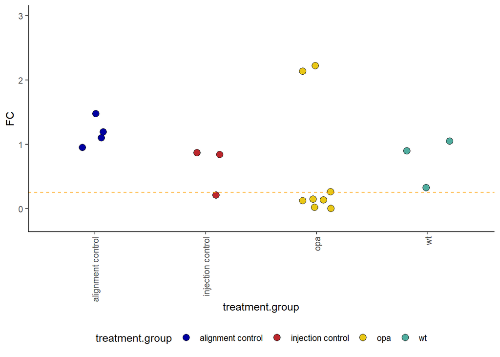

```r
color.code <-c("wt" = "#50ad9f","alignment control" = "#0000A2","injection control"="#bc272d", "opa"="#e9c716")

 nc13.fc.table %>% ggplot(., aes(x= treatment.group, y = FC, fill = treatment.group)) +
  geom_jitter(size = 3,shape = 21, color = "black",width=0.2)+
  scale_fill_manual(values = color.code) +
  ylim(-0.2,3) +
  geom_hline(yintercept = 0.25, linetype = 'dashed', col = 'orange') +
theme(axis.text.x = element_text(angle = 90, vjust = 0.5, hjust=1),
        axis.line = element_line(colour = "black"),
        legend.position = "bottom",
        panel.background = element_blank(),
        panel.grid.major = element_blank(),
    panel.grid.minor = element_blank())
```

5 Cal-opa RNAi embryos have a FC < 0.25

## 2. DE Analysis Setup

#### Update coldatas and counts.rna

Now that KDs have been identified the coldata should be updated.

Add a genotype column to coldata. For the opa treatment group an embryo’s genotype will be either opa, intKD or noKD based on the FC; FC < 0.25 is a KD (opa), 0.25 < FC < 0.5 intermediate KD (intKD) and FC > 0.5 is no KD (noKD). For the control treatment groups, genotype is equal to the treatment group, but written in short hand.

*NC12*

Add the colnames of the RNA counts to the rownames of coldata.rna

```r
rownames(nc12.opakd.coldata.rna) <- colnames(nc12.opakd.counts.rna)
```

Add the FC to the coldatas and add a genotype column.

Starting with coldata.rna

```r
nc12.opakd.coldata.rna <- cbind(nc12.opakd.coldata.rna, FC = nc12.fc.table$FC)

nc12.opakd.coldata.rna <- nc12.opakd.coldata.rna %>%
  mutate(genotype = case_when(
  treatment.group == "wt"  ~ "wt",
  treatment.group == "alignment control" ~ "ac",
  treatment.group == "injection control" ~ "dsred",
  (treatment.group == "opa" & FC > 0.5) ~ "noKD",
  (treatment.group == "opa" & 0.25 < FC & FC < 0.5) ~ "intKD",
   (treatment.group == "opa" & FC < 0.25) ~ "opa")) %>%
  relocate(.,genotype,.after = treatment.group)

# factor columns
for (i in 1:ncol(nc12.opakd.coldata.rna)){
    nc12.opakd.coldata.rna[, i] = as.factor(nc12.opakd.coldata.rna[, i])
}

# Set the reference levels
nc12.opakd.coldata.rna$treatment.group <- relevel(nc12.opakd.coldata.rna$treatment.group,ref = "alignment control")

nc12.opakd.coldata.rna$genotype <- relevel(nc12.opakd.coldata.rna$genotype,ref = "ac")

nc12.opakd.coldata.rna$Experiment.Date <- relevel(nc12.opakd.coldata.rna$Experiment.Date,ref = "230627")

head(nc12.opakd.coldata.rna)
```

```
##                                         Sample.name.full embryo
## wt.1.NC12.opaKD2.23003FL.09.02.01       wt.1.NC12.opaKD2      1
## ac.1.NC12.opaKD2.23003FL.09.02.02       ac.1.NC12.opaKD2      2
## dsred.1.NC12.opaKD2.23003FL.09.02.03 dsred.1.NC12.opaKD2      3
## opa.1.NC12.opaKD2.23003FL.09.02.04     opa.1.NC12.opaKD2      4
## wt.2.NC12.opaKD5.23003FL.09.02.20       wt.2.NC12.opaKD5      5
## ac.2.NC12.opaKD5.23003FL.09.02.21       ac.2.NC12.opaKD5      6
##                                        treatment.group genotype alignment
## wt.1.NC12.opaKD2.23003FL.09.02.01                   wt       wt     FALSE
## ac.1.NC12.opaKD2.23003FL.09.02.02    alignment control       ac      TRUE
## dsred.1.NC12.opaKD2.23003FL.09.02.03 injection control    dsred      TRUE
## opa.1.NC12.opaKD2.23003FL.09.02.04                 opa     noKD      TRUE
## wt.2.NC12.opaKD5.23003FL.09.02.20                   wt       wt     FALSE
## ac.2.NC12.opaKD5.23003FL.09.02.21    alignment control       ac      TRUE
##                                        injection Stage Dev.time Experiment
## wt.1.NC12.opaKD2.23003FL.09.02.01           none  NC12    4h58m      opaKD
## ac.1.NC12.opaKD2.23003FL.09.02.02           none  NC12    5h01m      opaKD
## dsred.1.NC12.opaKD2.23003FL.09.02.03 dsred dsRNA  NC12    5h02m      opaKD
## opa.1.NC12.opaKD2.23003FL.09.02.04     opa dsRNA  NC12    5h05m      opaKD
## wt.2.NC12.opaKD5.23003FL.09.02.20           none  NC12    4h59m      opaKD
## ac.2.NC12.opaKD5.23003FL.09.02.21           none  NC12    4h57m      opaKD
##                                      Experiment.Date ATAC.and.RNA
## wt.1.NC12.opaKD2.23003FL.09.02.01             230518          yes
## ac.1.NC12.opaKD2.23003FL.09.02.02             230518          yes
## dsred.1.NC12.opaKD2.23003FL.09.02.03          230518          yes
## opa.1.NC12.opaKD2.23003FL.09.02.04            230518          yes
## wt.2.NC12.opaKD5.23003FL.09.02.20             230627          yes
## ac.2.NC12.opaKD5.23003FL.09.02.21             230627          yes
##                                        TDE.ref.lot.num   sample.id.atac
## wt.1.NC12.opaKD2.23003FL.09.02.01    15027916/20654347 23003FL-06-01-18
## ac.1.NC12.opaKD2.23003FL.09.02.02    15027916/20654347 23003FL-06-01-19
## dsred.1.NC12.opaKD2.23003FL.09.02.03 15027916/20654347 23003FL-06-01-20
## opa.1.NC12.opaKD2.23003FL.09.02.04   15027916/20654347 23003FL-06-01-21
## wt.2.NC12.opaKD5.23003FL.09.02.20    15027916/20723216 23003FL-06-01-35
## ac.2.NC12.opaKD5.23003FL.09.02.21    15027916/20723216 23003FL-06-01-36
##                                         sample.id.rna sample.id.rna.2
## wt.1.NC12.opaKD2.23003FL.09.02.01    23003FL-09-02-01              NA
## ac.1.NC12.opaKD2.23003FL.09.02.02    23003FL-09-02-02              NA
## dsred.1.NC12.opaKD2.23003FL.09.02.03 23003FL-09-02-03              NA
## opa.1.NC12.opaKD2.23003FL.09.02.04   23003FL-09-02-04              NA
## wt.2.NC12.opaKD5.23003FL.09.02.20    23003FL-09-02-20              NA
## ac.2.NC12.opaKD5.23003FL.09.02.21    23003FL-09-02-21              NA
##                                      instrument.atac.data instrument.rna.data
## wt.1.NC12.opaKD2.23003FL.09.02.01          NovaSeq X Plus      NovaSeq X Plus
## ac.1.NC12.opaKD2.23003FL.09.02.02          NovaSeq X Plus      NovaSeq X Plus
## dsred.1.NC12.opaKD2.23003FL.09.02.03       NovaSeq X Plus      NovaSeq X Plus
## opa.1.NC12.opaKD2.23003FL.09.02.04         NovaSeq X Plus      NovaSeq X Plus
## wt.2.NC12.opaKD5.23003FL.09.02.20          NovaSeq X Plus      NovaSeq X Plus
## ac.2.NC12.opaKD5.23003FL.09.02.21          NovaSeq X Plus      NovaSeq X Plus
##                                                     FC
## wt.1.NC12.opaKD2.23003FL.09.02.01     1.05332966096683
## ac.1.NC12.opaKD2.23003FL.09.02.02    0.946670339033167
## dsred.1.NC12.opaKD2.23003FL.09.02.03   0.9205636983224
## opa.1.NC12.opaKD2.23003FL.09.02.04    1.92702187330544
## wt.2.NC12.opaKD5.23003FL.09.02.20     1.41559499116167
## ac.2.NC12.opaKD5.23003FL.09.02.21    0.584405008838331
```

Update coldata.atac

```r
nc12.opakd.coldata.atac <- cbind(nc12.opakd.coldata.atac, FC = nc12.fc.table$FC)

nc12.opakd.coldata.atac <- nc12.opakd.coldata.atac %>%
  mutate(genotype = case_when(
  treatment.group == "wt" ~ "wt",
  treatment.group == "alignment control" ~ "ac",
  treatment.group == "injection control" ~ "dsred",
  (treatment.group == "opa" & FC > 0.5) ~ "noKD",
  (treatment.group == "opa" & 0.25 < FC & FC < 0.5) ~ "intKD",
   (treatment.group == "opa" & FC < 0.25) ~ "opa")) %>%
  relocate(.,genotype,.after = treatment.group)

# factor columns
for (i in 1:ncol(nc12.opakd.coldata.atac)){
    nc12.opakd.coldata.atac[, i] = as.factor(nc12.opakd.coldata.atac[, i])
}

# Set the reference levels
nc12.opakd.coldata.atac$treatment.group <- relevel(nc12.opakd.coldata.atac$treatment.group,ref = "alignment control")

nc12.opakd.coldata.atac$genotype <- relevel(nc12.opakd.coldata.atac$genotype,ref = "ac")

nc12.opakd.coldata.atac$Experiment.Date <- relevel(nc12.opakd.coldata.atac$Experiment.Date,ref = "230627")

head(nc12.opakd.coldata.atac)
```

```
##      Sample.name.full embryo   treatment.group genotype alignment   injection
## 1    wt.1.NC12.opaKD2      1                wt       wt     FALSE        none
## 2    ac.1.NC12.opaKD2      2 alignment control       ac      TRUE        none
## 3 dsred.1.NC12.opaKD2      3 injection control    dsred      TRUE dsred dsRNA
## 4   opa.1.NC12.opaKD2      4               opa     noKD      TRUE   opa dsRNA
## 5    wt.2.NC12.opaKD5      5                wt       wt     FALSE        none
## 6    ac.2.NC12.opaKD5      6 alignment control       ac      TRUE        none
##   Stage Dev.time Experiment Experiment.Date ATAC.and.RNA   TDE.ref.lot.num
## 1  NC12    4h58m      opaKD          230518          yes 15027916/20654347
## 2  NC12    5h01m      opaKD          230518          yes 15027916/20654347
## 3  NC12    5h02m      opaKD          230518          yes 15027916/20654347
## 4  NC12    5h05m      opaKD          230518          yes 15027916/20654347
## 5  NC12    4h59m      opaKD          230627          yes 15027916/20723216
## 6  NC12    4h57m      opaKD          230627          yes 15027916/20723216
##     sample.id.atac    sample.id.rna sample.id.rna.2 instrument.atac.data
## 1 23003FL-06-01-18 23003FL-09-02-01              NA       NovaSeq X Plus
## 2 23003FL-06-01-19 23003FL-09-02-02              NA       NovaSeq X Plus
## 3 23003FL-06-01-20 23003FL-09-02-03              NA       NovaSeq X Plus
## 4 23003FL-06-01-21 23003FL-09-02-04              NA       NovaSeq X Plus
## 5 23003FL-06-01-35 23003FL-09-02-20              NA       NovaSeq X Plus
## 6 23003FL-06-01-36 23003FL-09-02-21              NA       NovaSeq X Plus
##   instrument.rna.data                FC
## 1      NovaSeq X Plus  1.05332966096683
## 2      NovaSeq X Plus 0.946670339033167
## 3      NovaSeq X Plus   0.9205636983224
## 4      NovaSeq X Plus  1.92702187330544
## 5      NovaSeq X Plus  1.41559499116167
## 6      NovaSeq X Plus 0.584405008838331
```

Check that the samples are in both RNA and ATAC coldatas.

```r
all(as.character(nc12.opakd.coldata.rna$Sample.name.full) == nc12.opakd.coldata.atac$Sample.name.full)
```

```
## [1] TRUE
```

Check that all samples match and are in the correct order

```r
all(rownames(nc12.opakd.coldata.rna) %in% colnames(nc12.opakd.counts.rna)) & all(rownames(nc12.opakd.coldata.rna) == colnames(nc12.opakd.counts.rna))
```

```
## [1] TRUE
```

*NC13* Repeat for NC13 coldatas.

Add the colnames of the RNA counts to the rownames of coldata.rna

```r
rownames(nc13.opakd.coldata.rna) <- colnames(nc13.opakd.counts.rna)
```

Add FC and genotype columns.

Starting with coldata.rna

```r
nc13.opakd.coldata.rna <- cbind(nc13.opakd.coldata.rna, FC = nc13.fc.table$FC)

nc13.opakd.coldata.rna <- nc13.opakd.coldata.rna %>%
  mutate(genotype = case_when(
  treatment.group == "wt" ~ "wt",
  treatment.group == "alignment control" ~ "ac",
  treatment.group == "injection control" ~ "dsred",
  (treatment.group == "opa" & FC > 0.5) ~ "noKD",
  (treatment.group == "opa" & 0.25 < FC & FC < 0.5) ~ "intKD",
   (treatment.group == "opa" & FC < 0.25) ~ "opa")) %>%
  relocate(.,genotype,.after = treatment.group)

# factor columns
for (i in 1:ncol(nc13.opakd.coldata.rna)){
    nc13.opakd.coldata.rna[, i] = as.factor(nc13.opakd.coldata.rna[, i])
}

# Set the reference levels
nc13.opakd.coldata.rna$treatment.group <- relevel(nc13.opakd.coldata.rna$treatment.group,ref = "alignment control")

nc13.opakd.coldata.rna$genotype <- relevel(nc13.opakd.coldata.rna$genotype,ref = "ac")

nc13.opakd.coldata.rna$Experiment.Date <- relevel(nc13.opakd.coldata.rna$Experiment.Date,ref = "230616")

head(nc13.opakd.coldata.rna)
```

```
##                                         Sample.name.full embryo
## wt.1.NC13.opaKD1.23003FL.09.01.25       wt.1.NC13.opaKD1      1
## ac.1.NC13.opaKD1.23003FL.09.01.26       ac.1.NC13.opaKD1      2
## dsred.2.NC13.opaKD1.23003FL.09.01.27 dsred.2.NC13.opaKD1      3
## opa.2.NC13.opaKD1.23003FL.09.01.28     opa.2.NC13.opaKD1      4
## opa.3.NC13.opaKD1.23003FL.09.01.29     opa.3.NC13.opaKD1      5
## opa.4.NC13.opaKD1.23003FL.09.01.30     opa.4.NC13.opaKD1      6
##                                        treatment.group genotype alignment
## wt.1.NC13.opaKD1.23003FL.09.01.25                   wt       wt     FALSE
## ac.1.NC13.opaKD1.23003FL.09.01.26    alignment control       ac      TRUE
## dsred.2.NC13.opaKD1.23003FL.09.01.27 injection control    dsred      TRUE
## opa.2.NC13.opaKD1.23003FL.09.01.28                 opa     noKD      TRUE
## opa.3.NC13.opaKD1.23003FL.09.01.29                 opa     noKD      TRUE
## opa.4.NC13.opaKD1.23003FL.09.01.30                 opa    intKD      TRUE
##                                        injection Stage Dev.time Experiment
## wt.1.NC13.opaKD1.23003FL.09.01.25           none  NC13    5h07m      opaKD
## ac.1.NC13.opaKD1.23003FL.09.01.26           none  NC13    5h09m      opaKD
## dsred.2.NC13.opaKD1.23003FL.09.01.27 dsred dsRNA  NC13    5h12m      opaKD
## opa.2.NC13.opaKD1.23003FL.09.01.28     opa dsRNA  NC13    5h16m      opaKD
## opa.3.NC13.opaKD1.23003FL.09.01.29     opa dsRNA  NC13    5h18m      opaKD
## opa.4.NC13.opaKD1.23003FL.09.01.30     opa dsRNA  NC13    5h19m      opaKD
##                                      Experiment.Date ATAC.and.RNA
## wt.1.NC13.opaKD1.23003FL.09.01.25             230511          yes
## ac.1.NC13.opaKD1.23003FL.09.01.26             230511          yes
## dsred.2.NC13.opaKD1.23003FL.09.01.27          230511          yes
## opa.2.NC13.opaKD1.23003FL.09.01.28            230511          yes
## opa.3.NC13.opaKD1.23003FL.09.01.29            230511          yes
## opa.4.NC13.opaKD1.23003FL.09.01.30            230511          yes
##                                        TDE.ref.lot.num   sample.id.atac
## wt.1.NC13.opaKD1.23003FL.09.01.25    15027916/20654347 23003FL-06-01-10
## ac.1.NC13.opaKD1.23003FL.09.01.26    15027916/20654347 23003FL-06-01-11
## dsred.2.NC13.opaKD1.23003FL.09.01.27 15027916/20654347 23003FL-06-01-13
## opa.2.NC13.opaKD1.23003FL.09.01.28   15027916/20654347 23003FL-06-01-15
## opa.3.NC13.opaKD1.23003FL.09.01.29   15027916/20654347 23003FL-06-01-16
## opa.4.NC13.opaKD1.23003FL.09.01.30   15027916/20654347 23003FL-06-01-17
##                                         sample.id.rna sample.id.rna.2
## wt.1.NC13.opaKD1.23003FL.09.01.25    23003FL-09-01-25              NA
## ac.1.NC13.opaKD1.23003FL.09.01.26    23003FL-09-01-26              NA
## dsred.2.NC13.opaKD1.23003FL.09.01.27 23003FL-09-01-27              NA
## opa.2.NC13.opaKD1.23003FL.09.01.28   23003FL-09-01-28              NA
## opa.3.NC13.opaKD1.23003FL.09.01.29   23003FL-09-01-29              NA
## opa.4.NC13.opaKD1.23003FL.09.01.30   23003FL-09-01-30              NA
##                                      instrument.atac.data instrument.rna.data
## wt.1.NC13.opaKD1.23003FL.09.01.25          NovaSeq X Plus      NovaSeq X Plus
## ac.1.NC13.opaKD1.23003FL.09.01.26          NovaSeq X Plus      NovaSeq X Plus
## dsred.2.NC13.opaKD1.23003FL.09.01.27       NovaSeq X Plus      NovaSeq X Plus
## opa.2.NC13.opaKD1.23003FL.09.01.28         NovaSeq X Plus      NovaSeq X Plus
## opa.3.NC13.opaKD1.23003FL.09.01.29         NovaSeq X Plus      NovaSeq X Plus
## opa.4.NC13.opaKD1.23003FL.09.01.30         NovaSeq X Plus      NovaSeq X Plus
##                                                     FC
## wt.1.NC13.opaKD1.23003FL.09.01.25    0.900633102031209
## ac.1.NC13.opaKD1.23003FL.09.01.26     1.09936689796879
## dsred.2.NC13.opaKD1.23003FL.09.01.27 0.841277096255892
## opa.2.NC13.opaKD1.23003FL.09.01.28    2.13789698427665
## opa.3.NC13.opaKD1.23003FL.09.01.29    2.22128877732642
## opa.4.NC13.opaKD1.23003FL.09.01.30   0.262361224503762
```

Update coldata.atac

```r
nc13.opakd.coldata.atac <- cbind(nc13.opakd.coldata.atac, FC = nc13.fc.table$FC)

nc13.opakd.coldata.atac <- nc13.opakd.coldata.atac %>%
  mutate(genotype = case_when(
  treatment.group == "wt" ~ "wt",
  treatment.group == "alignment control" ~ "ac",
  treatment.group == "injection control" ~ "dsred",
  (treatment.group == "opa" & FC > 0.5) ~ "noKD",
  (treatment.group == "opa" & 0.25 < FC & FC < 0.5) ~ "intKD",
   (treatment.group == "opa" & FC < 0.25) ~ "opa")) %>%
  relocate(.,genotype,.after = treatment.group)

# factor columns
for (i in 1:ncol(nc13.opakd.coldata.atac)){
    nc13.opakd.coldata.atac[, i] = as.factor(nc13.opakd.coldata.atac[, i])
}

# Set the reference levels
nc13.opakd.coldata.atac$treatment.group <- relevel(nc13.opakd.coldata.atac$treatment.group,ref = "alignment control")

nc13.opakd.coldata.atac$genotype <- relevel(nc13.opakd.coldata.atac$genotype,ref = "ac")

nc13.opakd.coldata.atac$Experiment.Date <- relevel(nc13.opakd.coldata.atac$Experiment.Date,ref = "230616")

head(nc13.opakd.coldata.atac)
```

```
##      Sample.name.full embryo   treatment.group genotype alignment   injection
## 1    wt.1.NC13.opaKD1      1                wt       wt     FALSE        none
## 2    ac.1.NC13.opaKD1      2 alignment control       ac      TRUE        none
## 3 dsred.2.NC13.opaKD1      3 injection control    dsred      TRUE dsred dsRNA
## 4   opa.2.NC13.opaKD1      4               opa     noKD      TRUE   opa dsRNA
## 5   opa.3.NC13.opaKD1      5               opa     noKD      TRUE   opa dsRNA
## 6   opa.4.NC13.opaKD1      6               opa    intKD      TRUE   opa dsRNA
##   Stage Dev.time Experiment Experiment.Date ATAC.and.RNA   TDE.ref.lot.num
## 1  NC13    5h07m      opaKD          230511          yes 15027916/20654347
## 2  NC13    5h09m      opaKD          230511          yes 15027916/20654347
## 3  NC13    5h12m      opaKD          230511          yes 15027916/20654347
## 4  NC13    5h16m      opaKD          230511          yes 15027916/20654347
## 5  NC13    5h18m      opaKD          230511          yes 15027916/20654347
## 6  NC13    5h19m      opaKD          230511          yes 15027916/20654347
##     sample.id.atac    sample.id.rna sample.id.rna.2 instrument.atac.data
## 1 23003FL-06-01-10 23003FL-09-01-25              NA       NovaSeq X Plus
## 2 23003FL-06-01-11 23003FL-09-01-26              NA       NovaSeq X Plus
## 3 23003FL-06-01-13 23003FL-09-01-27              NA       NovaSeq X Plus
## 4 23003FL-06-01-15 23003FL-09-01-28              NA       NovaSeq X Plus
## 5 23003FL-06-01-16 23003FL-09-01-29              NA       NovaSeq X Plus
## 6 23003FL-06-01-17 23003FL-09-01-30              NA       NovaSeq X Plus
##   instrument.rna.data                FC
## 1      NovaSeq X Plus 0.900633102031209
## 2      NovaSeq X Plus  1.09936689796879
## 3      NovaSeq X Plus 0.841277096255892
## 4      NovaSeq X Plus  2.13789698427665
## 5      NovaSeq X Plus  2.22128877732642
## 6      NovaSeq X Plus 0.262361224503762
```

```r
GRange_to_Bigwig<-function(genome_bin, featureGrange){
  open100.binavg <- binnedAverage(bins = genome_bin, numvar = coverage(featureGrange), varname = "score")
score(open100.binavg) <- signif(score(open100.binavg)/length(featureGrange)*1e+6, 4)
return(open100.binavg)
}

Calbi<-Calbipunctata
names_by_size=names(sort(seqlengths(Calbi), decreasing = T))
chromosome.uns <- seqlevels(Calbi)[seqlevels(Calbi)%in%names_by_size[1:6]]
Calbi_chr<-getSeq(Calbi, chromosome.uns )

#Create a genome tile
Calbi.10bp <- tileGenome(seqlengths(Calbi_chr), tilewidth = 10, cut.last.tile.in.chrom = TRUE)
```

Check that the samples are in both RNA and ATAC coldatas.

```r
all(as.character(nc13.opakd.coldata.rna$Sample.name.full) == nc13.opakd.coldata.atac$Sample.name.full)
```

```
## [1] TRUE
```

Check that all samples match and are in the correct order

```r
all(rownames(nc13.opakd.coldata.rna) %in% colnames(nc13.opakd.counts.rna)) & all(rownames(nc13.opakd.coldata.rna) == colnames(nc13.opakd.counts.rna))
```

```
## [1] TRUE
```

#### Counts ATAC-seq

A counts matrix of open reads (<=120 bp) in MACS identified master peaks will be made.

This will be made by counting the overlaps of open reads (<= 120 bp) into a peak.

NC12

```r
nc12.opakd.counts.atac <- lapply(opakd.nc12.openreads, function(x) countOverlaps(peaks.32157,x))
nc12.opakd.counts.atac <- do.call("cbind",nc12.opakd.counts.atac) # coerce into a table, rows are peaks, columns are samples
head(nc12.opakd.counts.atac[,1:6])
```

```
##                          wt.1.NC12.opaKD2.23003FL.06.01.18
## scaffold_1:39064-39403                                 109
## scaffold_1:41080-41159                                  11
## scaffold_1:46323-46446                                  17
## scaffold_1:113573-113903                               227
## scaffold_1:114565-114639                                21
## scaffold_1:116022-116187                               134
##                          ac.1.NC12.opaKD2.23003FL.06.01.19
## scaffold_1:39064-39403                                  67
## scaffold_1:41080-41159                                   6
## scaffold_1:46323-46446                                  14
## scaffold_1:113573-113903                               118
## scaffold_1:114565-114639                                14
## scaffold_1:116022-116187                                77
##                          dsred.1.NC12.opaKD2.23003FL.06.01.20
## scaffold_1:39064-39403                                     16
## scaffold_1:41080-41159                                      4
## scaffold_1:46323-46446                                      4
## scaffold_1:113573-113903                                   44
## scaffold_1:114565-114639                                    2
## scaffold_1:116022-116187                                   20
##                          opa.1.NC12.opaKD2.23003FL.06.01.21
## scaffold_1:39064-39403                                   83
## scaffold_1:41080-41159                                    7
## scaffold_1:46323-46446                                   13
## scaffold_1:113573-113903                                107
## scaffold_1:114565-114639                                 20
## scaffold_1:116022-116187                                 79
##                          wt.2.NC12.opaKD5.23003FL.06.01.35
## scaffold_1:39064-39403                                  42
## scaffold_1:41080-41159                                   2
## scaffold_1:46323-46446                                  13
## scaffold_1:113573-113903                               123
## scaffold_1:114565-114639                                19
## scaffold_1:116022-116187                                40
##                          ac.2.NC12.opaKD5.23003FL.06.01.36
## scaffold_1:39064-39403                                  36
## scaffold_1:41080-41159                                   3
## scaffold_1:46323-46446                                   8
## scaffold_1:113573-113903                               103
## scaffold_1:114565-114639                                 6
## scaffold_1:116022-116187                                53
```

Now add rownames to coldata.atac

```r
rownames(nc12.opakd.coldata.atac) <- colnames(nc12.opakd.counts.atac)
```

Double check order

```r
all(rownames(nc12.opakd.coldata.atac) %in% colnames(nc12.opakd.counts.atac)) &
all(rownames(nc12.opakd.coldata.atac) == colnames(nc12.opakd.counts.atac))
```

```
## [1] TRUE
```

NC13

```r
nc13.opakd.counts.atac <- lapply(opakd.nc13.openreads, function(x) countOverlaps(peaks.32157,x))
nc13.opakd.counts.atac <- do.call("cbind",nc13.opakd.counts.atac) # coerce into a table, rows are peaks, columns are samples
head(nc13.opakd.counts.atac[,1:6])
```

```
##                          wt.1.NC13.opaKD1.23003FL.06.01.10
## scaffold_1:39064-39403                                  40
## scaffold_1:41080-41159                                   3
## scaffold_1:46323-46446                                   8
## scaffold_1:113573-113903                               125
## scaffold_1:114565-114639                                25
## scaffold_1:116022-116187                                71
##                          ac.1.NC13.opaKD1.23003FL.06.01.11
## scaffold_1:39064-39403                                  64
## scaffold_1:41080-41159                                   6
## scaffold_1:46323-46446                                  11
## scaffold_1:113573-113903                               161
## scaffold_1:114565-114639                                27
## scaffold_1:116022-116187                               101
##                          dsred.2.NC13.opaKD1.23003FL.06.01.13
## scaffold_1:39064-39403                                     37
## scaffold_1:41080-41159                                      3
## scaffold_1:46323-46446                                      4
## scaffold_1:113573-113903                                  125
## scaffold_1:114565-114639                                   22
## scaffold_1:116022-116187                                   77
##                          opa.2.NC13.opaKD1.23003FL.06.01.15
## scaffold_1:39064-39403                                   35
## scaffold_1:41080-41159                                    7
## scaffold_1:46323-46446                                    5
## scaffold_1:113573-113903                                131
## scaffold_1:114565-114639                                 13
## scaffold_1:116022-116187                                 77
##                          opa.3.NC13.opaKD1.23003FL.06.01.16
## scaffold_1:39064-39403                                   67
## scaffold_1:41080-41159                                   10
## scaffold_1:46323-46446                                   10
## scaffold_1:113573-113903                                221
## scaffold_1:114565-114639                                 34
## scaffold_1:116022-116187                                116
##                          opa.4.NC13.opaKD1.23003FL.06.01.17
## scaffold_1:39064-39403                                   35
## scaffold_1:41080-41159                                    3
## scaffold_1:46323-46446                                   12
## scaffold_1:113573-113903                                145
## scaffold_1:114565-114639                                 12
## scaffold_1:116022-116187                                104
```

Now add rownames to coldata.atac

```r
rownames(nc13.opakd.coldata.atac) <- colnames(nc13.opakd.counts.atac)
```

Double check order

```r
all(rownames(nc13.opakd.coldata.atac) %in% colnames(nc13.opakd.counts.atac)) & all(rownames(nc13.opakd.coldata.atac) == colnames(nc13.opakd.counts.atac))
```

```
## [1] TRUE
```

Now we are ready to perform DESeq2 on both ATAC- and RNA-seq data for both time points.

KDs have been identified and genotyped.

We have necessary inputs for DESeq2 a counts table and the colData.

For NC12

nc12.opakd.counts.rna and nc12.opakd.coldata.rna

nc12.opakd.counts.atac and nc12.opakd.coldata.atac

For NC13

nc13.opakd.counts.rna and nc13.opakd.coldata.rna

nc13.opakd.counts.atac and nc13.opakd.coldata.atac

###### Save updated coldatas and counts

NC12

```r
nc12.opakd.coldata.atac <- cbind("row.name" =rownames(nc12.opakd.coldata.atac),nc12.opakd.coldata.atac)
nc12.opakd.coldata.rna <- cbind("row.name"=rownames(nc12.opakd.coldata.rna),nc12.opakd.coldata.rna)
```

```r
write_xlsx(list("nc12.opakd.coldata.atac"=as.data.frame(nc12.opakd.coldata.atac),
              "nc12.opakd.coldata.rna"=as.data.frame(nc12.opakd.coldata.rna)),
          "../opaKD/nc12-opa-coldata-updated.xlsx")
```

```r
write.table(nc12.opakd.counts.atac,file = "../opaKD/nc12-opakd-counts-atac.txt", sep = "\t", row.names = TRUE, col.names = TRUE)

write.table(nc12.opakd.counts.rna,file = "../opaKD/nc12-opakd-counts-rna.txt", sep = "\t", row.names = TRUE, col.names = TRUE)
```

NC13

```r
nc13.opakd.coldata.atac <- cbind("row.name" =rownames(nc13.opakd.coldata.atac),nc13.opakd.coldata.atac)
nc13.opakd.coldata.rna <- cbind("row.name"=rownames(nc13.opakd.coldata.rna),nc13.opakd.coldata.rna)
```

```r
write_xlsx(list("nc13.opakd.coldata.atac"=as.data.frame(nc13.opakd.coldata.atac),
                "nc13.opakd.coldata.rna"=as.data.frame(nc13.opakd.coldata.rna)),
           "../opaKD/nc13-opa-coldata-updated.xlsx")
```

```r
write.table(nc13.opakd.counts.atac,file = "../opaKD/nc13-opakd-counts-atac.txt", sep = "\t", row.names = TRUE, col.names = TRUE)

write.table(nc13.opakd.counts.rna,file = "../opaKD/nc13-opakd-counts-rna.txt", sep = "\t", row.names = TRUE, col.names = TRUE)
```

#### Filter RNA counts

Before proceeding with the DESeq2 analysis, the RNA-seq counts need to be filtered to remove noisy and no count genes. This will be done by plotting the distribution of counts, which will show the true distribution and the noise. A cutoff based on the count distribution will be applied to remove any counts below those values.

NC12

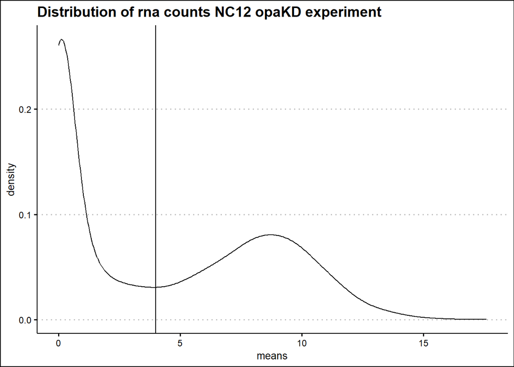

```r
data.frame(means = log2(rowMeans(nc12.opakd.counts.rna)+1)) %>%
  ggplot(aes(means)) +
  geom_density() +
  geom_vline(xintercept = 4) +
  theme_clean() +
  labs(title = 'Distribution of rna counts NC12 opaKD experiment')
```

Remove any gene counts below 2^4.

```r
nc12.opakd.counts.rna <- nc12.opakd.counts.rna[rowMeans(nc12.opakd.counts.rna) > 2^4,]
```

Again check that the colnames in the counts matrix match the rownames in coldata.

```r
all(colnames(nc12.opakd.counts.rna) == rownames(nc12.opakd.coldata.rna))
```

```
## [1] TRUE
```

NC13

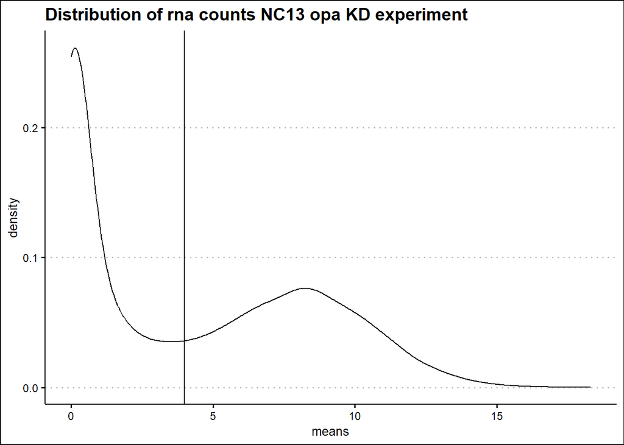

```r
data.frame(means = log2(rowMeans(nc13.opakd.counts.rna)+1)) %>%
  ggplot(aes(means)) +
  geom_density() +
  geom_vline(xintercept = 4) +
  theme_clean() +
  labs(title = 'Distribution of rna counts NC13 opa KD experiment')
```

Remove any gene counts below 2^4.

```r
nc13.opakd.counts.rna <- nc13.opakd.counts.rna[rowMeans(nc13.opakd.counts.rna) > 2^4,]
```

Again check that the colnames in the counts matrix match the rownames in coldata.

```r
all(colnames(nc13.opakd.counts.rna) == rownames(nc13.opakd.coldata.rna))
```

```
## [1] TRUE
```

#### Filter ATAC counts

Before running DESeq2 we need to get rid of any peaks that have low or noisy counts.

NC12

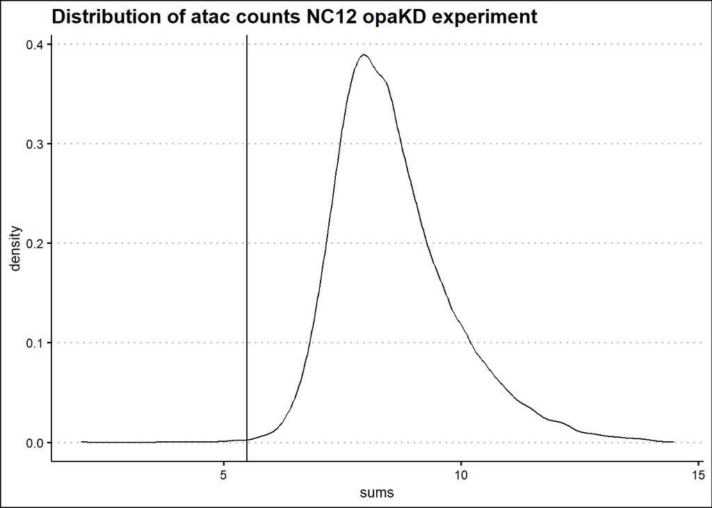

```r
data.frame(sums = log2(rowSums(nc12.opakd.counts.atac)+1)) %>%
  ggplot(aes(sums)) +
  geom_density() +
  geom_vline(xintercept = 5.5) +
  theme_clean() +
  labs(title = 'Distribution of atac counts NC12 opaKD experiment')
```

The number of peaks from the distribution above with counts less than 2^5.5.

```r
length(which(rowSums(nc12.opakd.counts.atac) < 2^5.5))
```

```
## [1] 42
```

The number of peaks with any count value of 0 or 1.

```r
table(apply(nc12.opakd.counts.atac, 1, function(x) sum(x <= 1)))
```

```
##
##     0     1     2     3     4     5     6     7     8     9    10    11    12
## 25966  4288  1219   429   137    57    17    16    12     3     5     4     2
##    14    15
##     1     1
```

We will filter peaks that have any count value of 0 or 1.

```r
nc12.opakd.counts.atac <- nc12.opakd.counts.atac[apply(nc12.opakd.counts.atac, 1, function(x) !any(x <= 1)),]
```

This removes low count peaks form the distribution above.

```r
length(which(rowSums(nc12.opakd.counts.atac) < 2^5.5))
```

```
## [1] 0
```

Again check that the colnames in the counts matrix match the rownames in coldata.

```r
all(colnames(nc12.opakd.counts.atac) == rownames(nc12.opakd.coldata.atac))
```

```
## [1] TRUE
```

Repeat for NC13

NC13

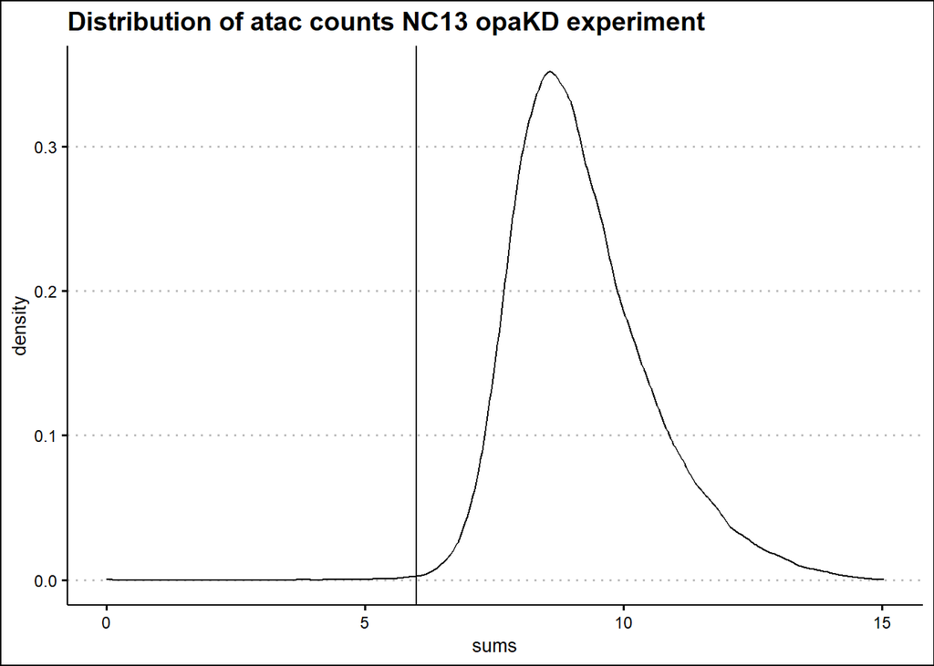

```r
data.frame(sums = log2(rowSums(nc13.opakd.counts.atac)+1)) %>%
  ggplot(aes(sums)) +
  geom_density() +
  geom_vline(xintercept = 6) +
  theme_clean() +
  labs(title = 'Distribution of atac counts NC13 opaKD experiment')
```

The number of peaks from the distribution above with counts less than 2^6.

```r
length(which(rowSums(nc13.opakd.counts.atac) < 2^6))
```

```
## [1] 43
```

The number of peaks with any count value of 0 or 1.

```r
table(apply(nc13.opakd.counts.atac, 1, function(x) sum(x <= 1)))
```

[output not shown]

We will filter peaks that have any count value of 0 or 1.

```r
nc13.opakd.counts.atac <- nc13.opakd.counts.atac[apply(nc13.opakd.counts.atac, 1, function(x) !any(x <= 1)),]
```

This removes low count peaks form the distribution above.

```r
length(which(rowSums(nc13.opakd.counts.atac) < 2^6))
```

```
## [1] 0
```

Again check that the colnames in the counts matrix match the rownames in coldata.

```r
all(colnames(nc13.opakd.counts.atac) == rownames(nc13.opakd.coldata.atac))
```

```
## [1] TRUE
```

## 3. NC12 DE Analysis

The design component for RNA-seq and ATAC-seq the DESeq2 analysis with be the same. The design component will include embryo batch (Experiment.Date) and genotype. We are interested in the changes in expression/accessibility due to genotype, this variable will be added last in the design.

#### NC12 DESeq2 RNA-seq data

```r
nc12.rna.dds <- DESeqDataSetFromMatrix(countData = nc12.opakd.counts.rna, colData = nc12.opakd.coldata.rna, design = ~ Experiment.Date + genotype)

nc12.rna.dds <- DESeq(nc12.rna.dds, parallel = FALSE)
```

Check that the names of results are as expected.

```r
resultsNames(nc12.rna.dds)
```

```
## [1] "Intercept"                        "Experiment.Date_230518_vs_230627"
## [3] "Experiment.Date_230629_vs_230627" "genotype_dsred_vs_ac"
## [5] "genotype_intKD_vs_ac"             "genotype_noKD_vs_ac"
## [7] "genotype_opa_vs_ac"               "genotype_wt_vs_ac"
```

Dispersion estimates. Take a look at dispersion to makes sure that the data fitting looks reasonable.

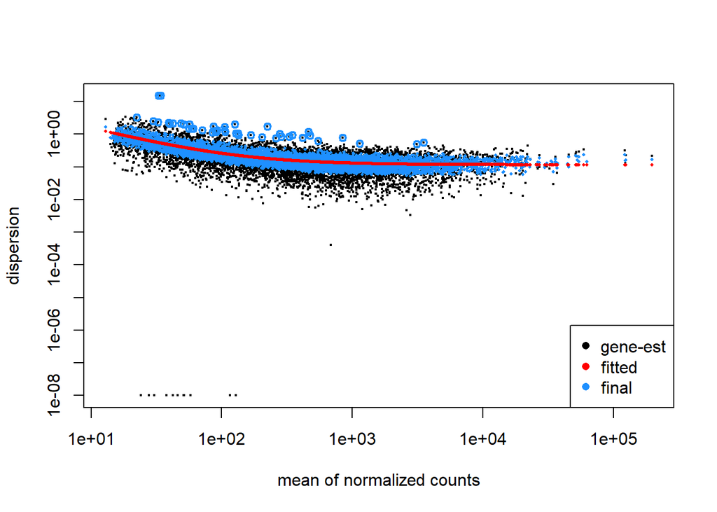

```r
plotDispEsts(nc12.rna.dds)
```

Results

##### NC12 opa KD vs alignment control DE genes

```r
nc12.res.opa.ac.rna <- as.data.frame(results(nc12.rna.dds, contrast = c("genotype", "opa", "ac"), independentFiltering = FALSE))
```

Add a column indicating if a gene is significantly differentially expressed.

Significant DEGs will be genes with a LFC >= 1 or LFC <=-1 and a padj <= 0.05

```r
nc12.res.opa.ac.rna <- nc12.res.opa.ac.rna %>%
  mutate(.,Sig = if_else((padj <= 0.05 & abs(log2FoldChange) >=1),TRUE,FALSE))
```

Add a column, “Change”, indicating if the change in expression was up or down.

```r
nc12.res.opa.ac.rna <- nc12.res.opa.ac.rna %>% mutate(Change = case_when(
  is.na(log2FoldChange) == TRUE | Sig == FALSE ~ "NA",
  log2FoldChange < 0 ~ "DOWN",
  log2FoldChange > 0 ~ "UP"))
```

Add a column, “gene.locus”, with the gene name.

```r
nc12.res.opa.ac.rna <- nc12.res.opa.ac.rna %>% mutate(gene.locus = rownames(.))
```

MA Plot

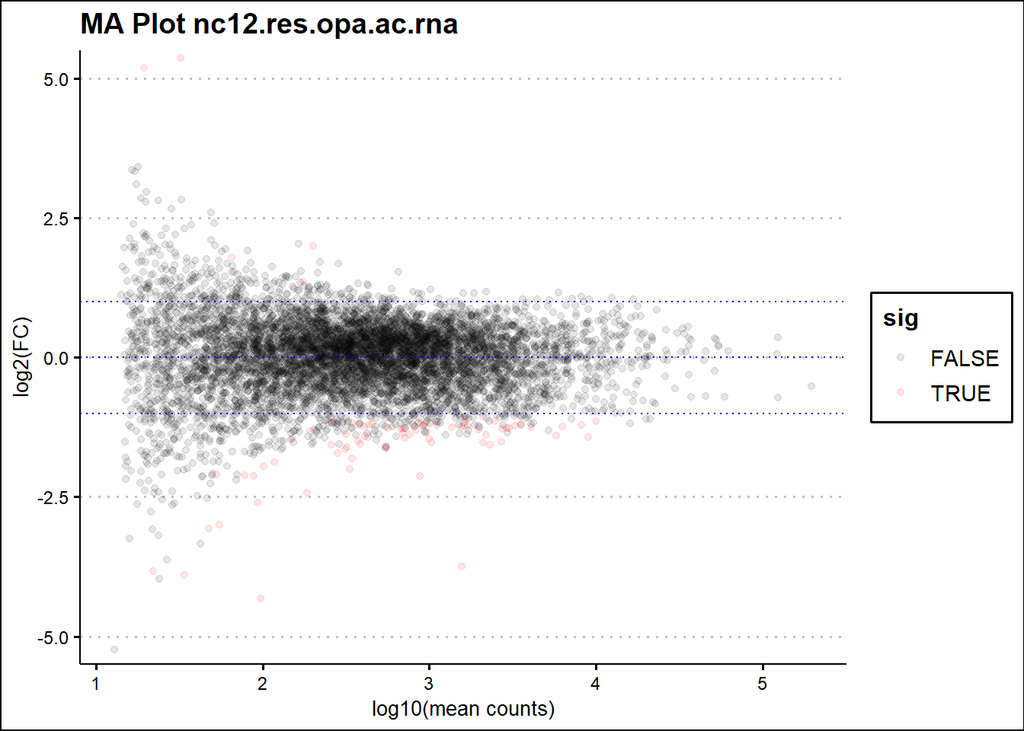

```r
nc12.res.opa.ac.rna %>%
  mutate(sig = padj <= 0.05) %>%
  ggplot(aes(x = log10(baseMean), y = log2FoldChange, color = sig)) +
  geom_point(alpha = 0.1) +
  coord_cartesian(ylim = c(-5,5)) +
  scale_color_manual(values = c("TRUE" = "red", "FALSE" =  "black")) +
  geom_hline(yintercept = c(0,1,-1), linetype = 'dotted', color = 'blue') +
  theme_clean() +
  labs(title = "MA Plot nc12.res.opa.ac.rna",
       x = "log10(mean counts)",
       y = "log2(FC)")
```

Lets plot the result and highlight significant DEGs. For this plot sig DEGs will be highlighted, and the number of DEGs that go up or down will be quantified.

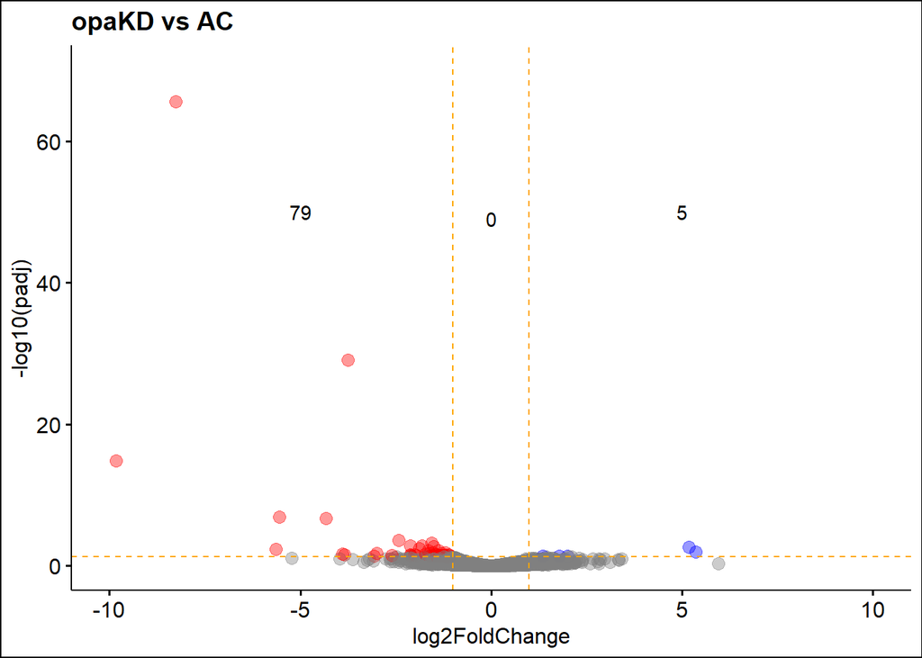

```r
# pdf("../Plots/nc12_opa_ac_rna_volcano_plot_clean.pdf", width = 4, height = 3)


nc12.opa.ac.rna.vol.rna <- nc12.res.opa.ac.rna %>%
  ggplot(aes(x = log2FoldChange, y = -log10(padj), color = Change, size = mean.intensity)) +
  geom_point(alpha = 0.4, size = 3) +
  coord_cartesian(xlim = c(-10, 10), ylim = c(0, 70)) +
  geom_hline(yintercept = -log10(0.05), linetype = 'dashed', col = 'orange') +
  geom_vline(xintercept = log2(c(0.5, 2)), linetype = 'dashed', col = 'orange') +
  scale_color_manual(values = c("DOWN" = 'red', "UP" = "blue", "NS" = "grey")) +
  theme_clean(base_size = 12) + theme(legend.position = "none")+
  theme(
    plot.title = element_text(size = 14),
    axis.title = element_text(size = 12),
    axis.text = element_text(size = 12),
    panel.grid.major.y = element_blank(),
    panel.grid.minor.y = element_blank()
  ) +

  labs(title = 'opaKD vs AC')

nc12.opa.ac.rna.vol.rna  +
  annotate(geom = "text", x = -5, y = 50, label = length(which(nc12.res.opa.ac.rna$padj <= 0.05 & nc12.res.opa.ac.rna$log2FoldChange <= -1))) +
  annotate(geom = "text", x = 5, y = 50, label = length(which(nc12.res.opa.ac.rna$padj <= 0.05 & nc12.res.opa.ac.rna$log2FoldChange >= 1))) +
  annotate(geom = 'text', x = 0, y = 49, label = length(which(nc12.res.opa.ac.rna$padj <= 0.05 & abs(nc12.res.opa.ac.rna$log2FoldChange) < 1)))
```

```r
#dev.off()
```

##### NC12 opa KD vs dsRed injection control DE genes

```r
nc12.res.opa.dsred.rna <- as.data.frame(results(nc12.rna.dds, contrast = c("genotype", "opa", "dsred"), independentFiltering = FALSE))
```

Add a column indicating if a gene is significantly differentially expressed.

Significant DEGs will be genes with a LFC >= 1 or LFC <=-1 and a padj <= 0.05

```r
nc12.res.opa.dsred.rna  <-nc12.res.opa.dsred.rna  %>%
  mutate(.,Sig = if_else((padj <= 0.05 & abs(log2FoldChange) >=1),TRUE,FALSE))
```

Add a column, “Change”, indicating if the change in expression was up or down.

```r
nc12.res.opa.dsred.rna <- nc12.res.opa.dsred.rna %>% mutate(Change = case_when(
  is.na(log2FoldChange) == TRUE | Sig == FALSE ~ "NA",
  log2FoldChange < 0 ~ "DOWN",
  log2FoldChange > 0 ~ "UP"))
```

Add a column, “gene.locus”, with the gene name.

```r
nc12.res.opa.dsred.rna  <- nc12.res.opa.dsred.rna %>% mutate(gene.locus = rownames(.))
```

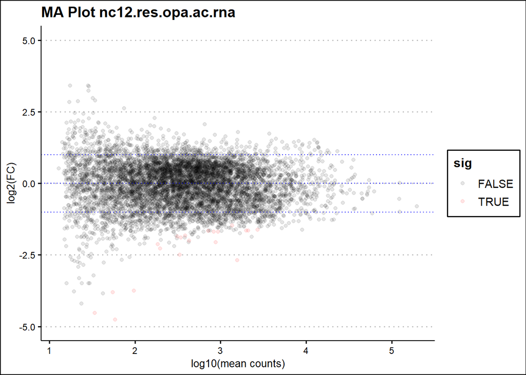

```r
nc12.res.opa.dsred.rna %>%
  mutate(sig = padj <= 0.05) %>%
  ggplot(aes(x = log10(baseMean), y = log2FoldChange, color = sig)) +
  geom_point(alpha = 0.1) +
  coord_cartesian(ylim = c(-5,5)) +
  scale_color_manual(values = c("TRUE" = "red", "FALSE" =  "black")) +
  geom_hline(yintercept = c(0,1,-1), linetype = 'dotted', color = 'blue') +
  theme_clean() +
  labs(title = "MA Plot nc12.res.opa.ac.rna",
       x = "log10(mean counts)",
       y = "log2(FC)")
```

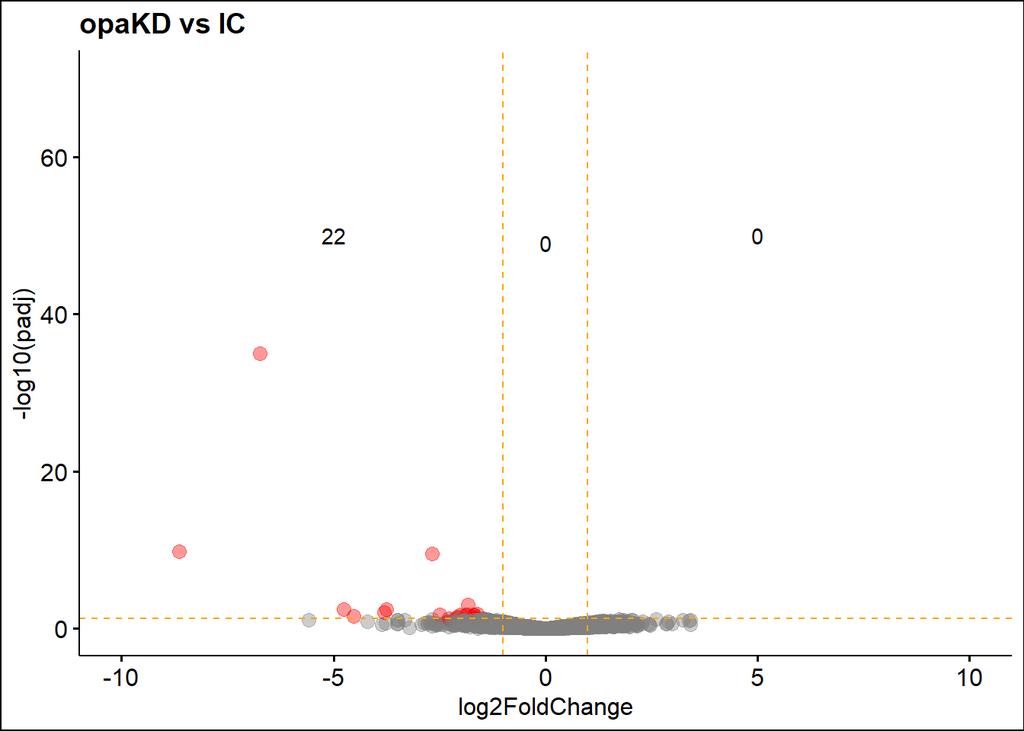

```r
#pdf("../Plots/nc12_opa_dsred_rna_volcano_plot_clean.pdf", width = 4, height = 3)


# Create base plot object

nc12.opa.dsred.rna.vol.rna <- nc12.res.opa.dsred.rna %>%
  ggplot(aes(x = log2FoldChange, y = -log10(padj), color = Change, size = mean.intensity)) +
  geom_point(alpha = 0.4, size = 3) +
  coord_cartesian(xlim = c(-10, 10), ylim = c(0, 70)) +
  geom_hline(yintercept = -log10(0.05), linetype = 'dashed', col = 'orange') +
  geom_vline(xintercept = log2(c(0.5, 2)), linetype = 'dashed', col = 'orange') +
  scale_color_manual(values = c("DOWN" = 'red', "UP" = "blue", "NS" = "grey")) +
  theme_clean(base_size = 12) + theme(legend.position = "none")+
  theme(
    plot.title = element_text(size = 14),
    axis.title = element_text(size = 12),
    axis.text = element_text(size = 12),
    panel.grid.major.y = element_blank(),
    panel.grid.minor.y = element_blank()
  ) +
  labs(title = 'opaKD vs IC')

# Print plot with annotated counts
nc12.opa.dsred.rna.vol.rna  +
  annotate(geom = "text", x = -5, y = 50, label = length(which(nc12.res.opa.dsred.rna$padj <= 0.05 & nc12.res.opa.dsred.rna$log2FoldChange <= -1))) +
  annotate(geom = "text", x = 5, y = 50, label = length(which(nc12.res.opa.dsred.rna$padj <= 0.05 & nc12.res.opa.dsred.rna$log2FoldChange >= 1))) +
  annotate(geom = 'text', x = 0, y = 49, label = length(which(nc12.res.opa.dsred.rna$padj <= 0.05 & abs(nc12.res.opa.dsred.rna$log2FoldChange) < 1)))
```

```r
#dev.off()
```

```r
nc12.res.opa.dsred.rna<- nc12.res.opa.dsred.rna %>% mutate(best_hit_in_Dme=blast.data[gene.locus,]$gene_name)
nc12.res.opa.ac.rna<- nc12.res.opa.ac.rna %>% mutate(best_hit_in_Dme=blast.data[gene.locus,]$gene_name)
write_xlsx(list("nc12.opaKD.ac.rna"=nc12.res.opa.ac.rna,"nc12.opaKD.dsred.rna"= nc12.res.opa.dsred.rna), paste0(opa.results.folder, "NC12_opa_degs.xlsx"))
```

#### NC12 DESeq2 ATAC-seq data

```r
nc12.atac.dds <- DESeqDataSetFromMatrix(countData = nc12.opakd.counts.atac, colData = nc12.opakd.coldata.atac, design = ~ Experiment.Date + genotype)
nc12.atac.dds <- DESeq(nc12.atac.dds, parallel = FALSE)
```

Check that the names of results are as expected.

```r
resultsNames(nc12.atac.dds)
```

```
## [1] "Intercept"                        "Experiment.Date_230518_vs_230627"
## [3] "Experiment.Date_230629_vs_230627" "genotype_dsred_vs_ac"
## [5] "genotype_intKD_vs_ac"             "genotype_noKD_vs_ac"
## [7] "genotype_opa_vs_ac"               "genotype_wt_vs_ac"
```

Dispersion estimates. Take a look at dispersion to makes sure that the data fitting looks reasonable.

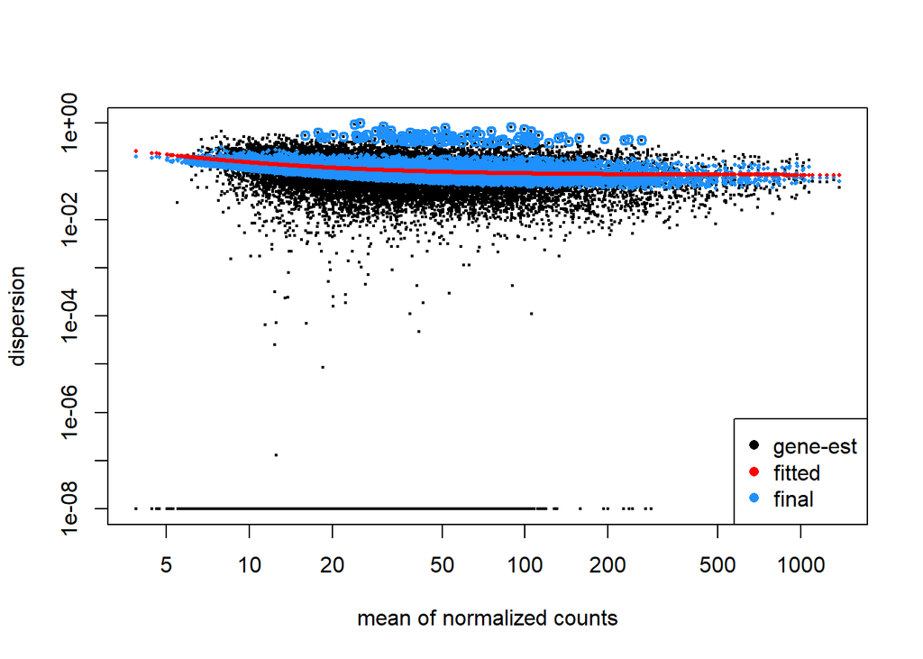

```r
plotDispEsts(nc12.atac.dds)
```

##### NC12 opa KD vs alignment control control DA peaks

```r
nc12.res.opa.ac.atac <- as.data.frame(results(nc12.atac.dds, contrast = c("genotype", "opa", "ac"), independentFiltering = FALSE))
```

Add a column, “Sig”, indicating if a peak has undergone a significantly change in accessibility.

Significant DAPs will be peaks with a LFC >= 1 or LFC <=-1 and a padj <= 0.05

```r
nc12.res.opa.ac.atac <- nc12.res.opa.ac.atac %>%
  mutate(.,Sig = if_else((padj <= 0.05 & abs(log2FoldChange) >=1),TRUE,FALSE))
```

Add a column, “Change”, indicating if the change in accessibility was up or down.

```r
nc12.res.opa.ac.atac <- nc12.res.opa.ac.atac %>%
  mutate(Change = case_when(
  is.na(log2FoldChange) == TRUE | Sig == FALSE ~ "NA",
  log2FoldChange < 0 ~ "DOWN",
  log2FoldChange > 0 ~ "UP"))
```

Add a column, “peak.name”, with the peak name and add the nearby gene for each peak.

```r
nc12.res.opa.ac.atac <- nc12.res.opa.ac.atac %>% mutate(peak.name = rownames(.))
nc12.res.opa.ac.atac$gene_locus <-peak_annotation[match(nc12.res.opa.ac.atac$peak.name, row.names(peak_annotation)),]$geneId
```

MA plot

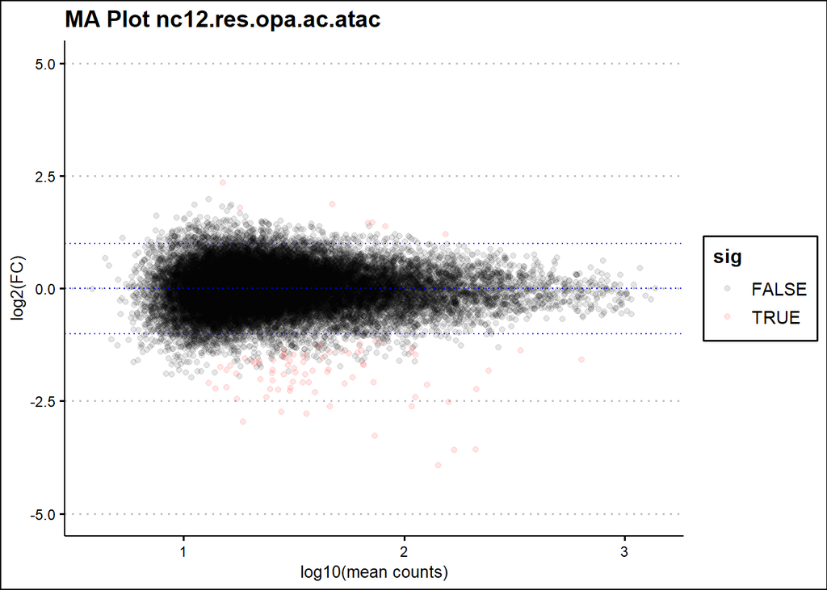

```r
nc12.res.opa.ac.atac %>%
  mutate(sig = padj <= 0.05) %>%
  ggplot(aes(x = log10(baseMean), y = log2FoldChange, color = sig)) +
  geom_point(alpha = 0.1) +
  coord_cartesian(ylim = c(-5,5)) +
  scale_color_manual(values = c("TRUE" = "red", "FALSE" =  "black")) +
  geom_hline(yintercept = c(0,1,-1), linetype = 'dotted', color = 'blue') +
  theme_clean() +
  labs(title = "MA Plot nc12.res.opa.ac.atac",
       x = "log10(mean counts)",
       y = "log2(FC)")
```

Lets plot the result and highlight significant DAPs. For this plot sig DAPs will be highlighted, and the number of DAPs that go up or down will be quantified. The size of each data point will correspond to the intensity of the peak.

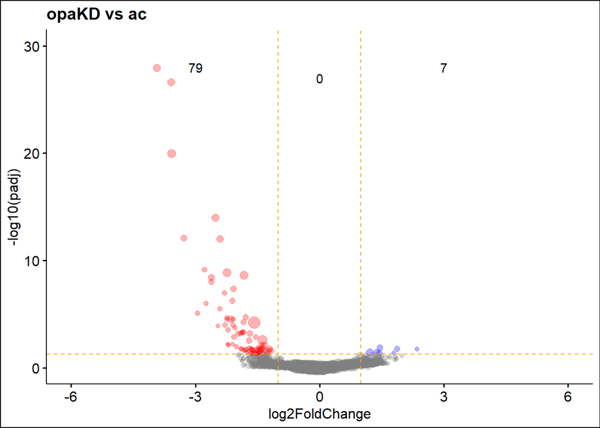

```r
#pdf("../Plots/nc12_opa_ac_atac_volcano_plot.pdf", width = 4, height = 3)
# Create base plot object
nc12.opa.ac.atac.vol.rna <- nc12.res.opa.ac.atac %>%mutate(mean.intensity = baseMean/max(baseMean)) %>%
  ggplot(aes(x = log2FoldChange, y = -log10(padj), color = Change, size = mean.intensity)) +
  geom_point(alpha = 0.3) +
  coord_cartesian(xlim = c(-6, 6), ylim = c(0, 30)) +
  geom_hline(yintercept = -log10(0.05), linetype = 'dashed', col = 'orange') +
  geom_vline(xintercept = log2(c(0.5, 2)), linetype = 'dashed', col = 'orange') +
  scale_color_manual(values = c("DOWN" = 'red', "UP" = "blue", "NS" = "grey")) +


  theme_clean(base_size = 12) + theme(legend.position = "none")+
  theme(
    plot.title = element_text(size = 14),
    axis.title = element_text(size = 12),
    axis.text = element_text(size = 12),
    panel.grid.major.y = element_blank(),
    panel.grid.minor.y = element_blank()
  ) +
  labs(title = 'opaKD vs ac')

# Print plot with annotated counts
nc12.opa.ac.atac.vol.rna  +
  annotate(geom = "text", x = -3, y = 28, label = length(which(nc12.res.opa.ac.atac$padj <= 0.05 & nc12.res.opa.ac.atac$log2FoldChange <= -1))) +
  annotate(geom = "text", x = 3, y = 28, label = length(which(nc12.res.opa.ac.atac$padj <= 0.05 & nc12.res.opa.ac.atac$log2FoldChange >= 1))) +
  annotate(geom = 'text', x = 0, y = 27, label = length(which(nc12.res.opa.ac.atac$padj <= 0.05 & abs(nc12.res.opa.ac.atac$log2FoldChange) < 1)))
```

```r
#dev.off()
```

##### NC12 opa KD vs dsRed injection control control DA peaks

```r
# Extract results for opaKD vs opanoKD (ATAC)
nc12.res.opa.dsred.atac <- as.data.frame(results(nc12.atac.dds, contrast = c("genotype", "opa", "dsred"), independentFiltering = FALSE))

# Add Sig, Change, and peak.name columns
nc12.res.opa.dsred.atac  <- nc12.res.opa.dsred.atac  %>%
  mutate(peak.name = rownames(.)) %>%
  mutate(Sig = if_else((padj <= 0.05 & abs(log2FoldChange) >= 1), TRUE, FALSE)) %>%
  mutate(Change = case_when(
    is.na(log2FoldChange) == TRUE | Sig == FALSE ~ "NA",
    log2FoldChange < 0 ~ "DOWN",
    log2FoldChange > 0 ~ "UP"
  ))
```

Add a column, “peak.name”, with the peak name and add the nearby gene for each peak.

```r
nc12.res.opa.dsred.atac <- nc12.res.opa.dsred.atac %>% mutate(peak.name = rownames(.))
nc12.res.opa.dsred.atac$gene_locus <-peak_annotation[match(nc12.res.opa.dsred.atac$peak.name, row.names(peak_annotation)),]$geneId
```

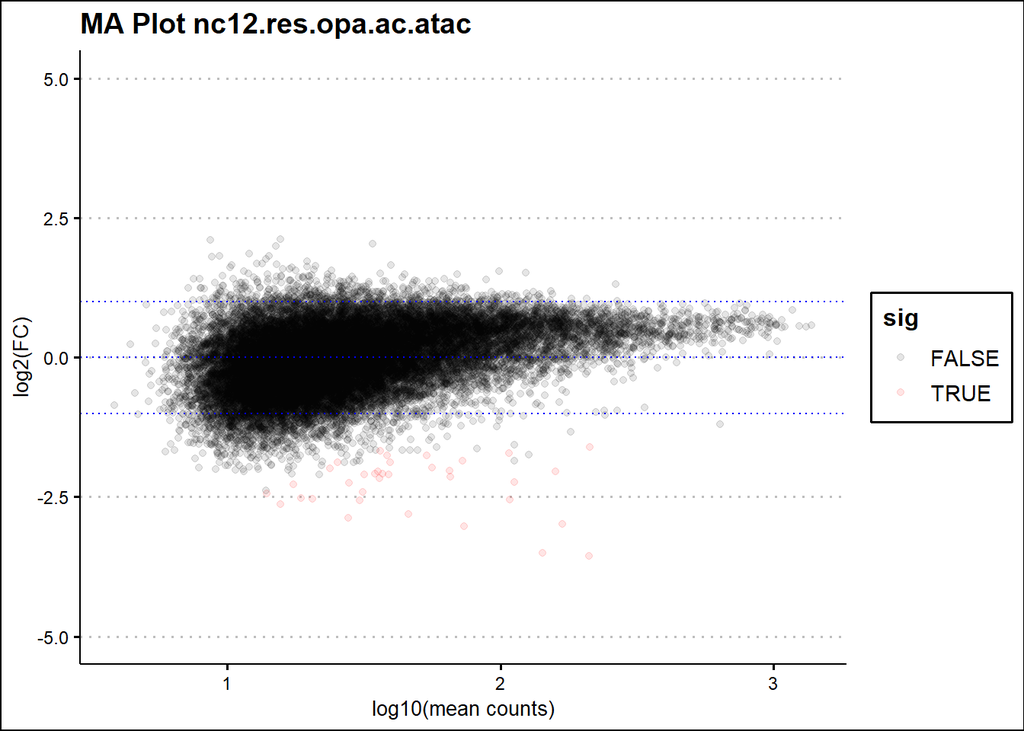

```r
nc12.res.opa.dsred.atac %>%
  mutate(sig = padj <= 0.05) %>%
  ggplot(aes(x = log10(baseMean), y = log2FoldChange, color = sig)) +
  geom_point(alpha = 0.1) +
  coord_cartesian(ylim = c(-5,5)) +
  scale_color_manual(values = c("TRUE" = "red", "FALSE" =  "black")) +
  geom_hline(yintercept = c(0,1,-1), linetype = 'dotted', color = 'blue') +
  theme_clean() +
  labs(title = "MA Plot nc12.res.opa.ac.atac",
       x = "log10(mean counts)",
       y = "log2(FC)")
```

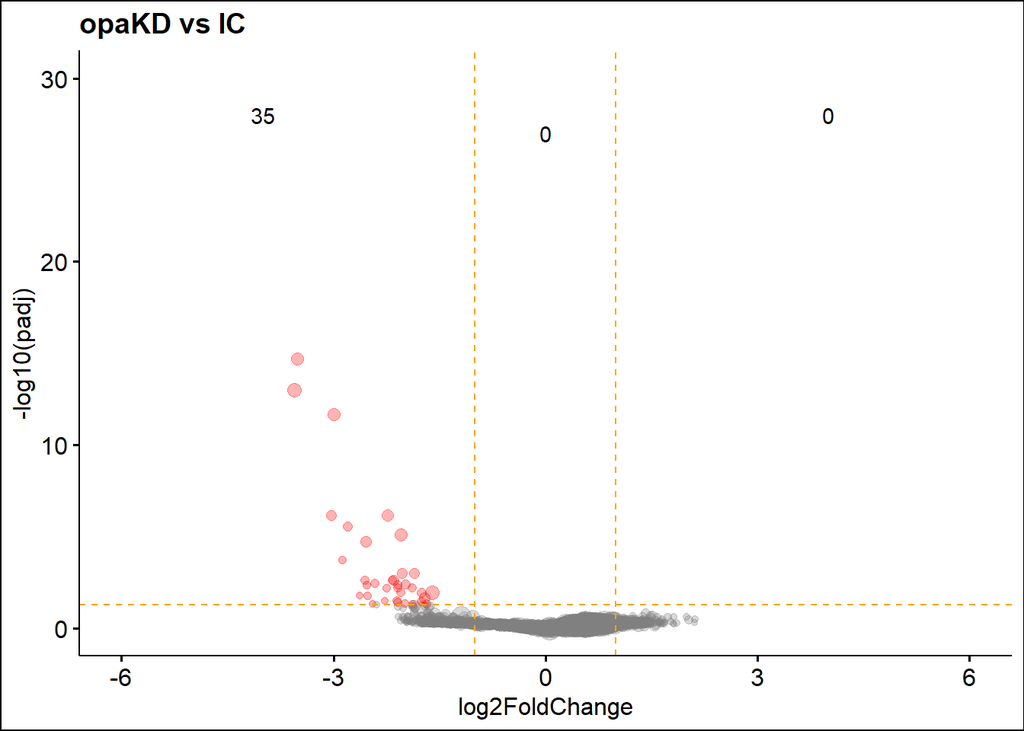

```r
#pdf("../Plots/nc12_opa_dsred_atac_volcano_plot.pdf", width = 4, height = 3)
# Create base plot object
nc12.opa.dsred.atac.vol.rna <- nc12.res.opa.dsred.atac %>%mutate(mean.intensity = baseMean/max(baseMean)) %>%
  ggplot(aes(x = log2FoldChange, y = -log10(padj), color = Change, size = mean.intensity)) +
  geom_point(alpha = 0.3) +
  coord_cartesian(xlim = c(-6, 6), ylim = c(0, 30)) +
  geom_hline(yintercept = -log10(0.05), linetype = 'dashed', col = 'orange') +
  geom_vline(xintercept = log2(c(0.5, 2)), linetype = 'dashed', col = 'orange') +
  scale_color_manual(values = c("DOWN" = 'red', "UP" = "blue", "NS" = "grey")) +


  theme_clean(base_size = 12) + theme(legend.position = "none")+

  # Optional: Fine-tune specific elements if base_size isn't enough
  theme(
    plot.title = element_text(size = 14),
    axis.title = element_text(size = 12),
    axis.text = element_text(size = 12),
    panel.grid.major.y = element_blank(),
    panel.grid.minor.y = element_blank()
  ) +
  labs(title = 'opaKD vs IC')

# Print plot with annotated counts
nc12.opa.dsred.atac.vol.rna  +
  annotate(geom = "text", x = -4, y = 28, label = length(which(nc12.res.opa.dsred.atac$padj <= 0.05 & nc12.res.opa.dsred.atac$log2FoldChange <= -1))) +
  annotate(geom = "text", x = 4, y = 28, label = length(which(nc12.res.opa.dsred.atac$padj <= 0.05 & nc12.res.opa.dsred.atac$log2FoldChange >= 1))) +
  annotate(geom = 'text', x = 0, y = 27, label = length(which(nc12.res.opa.dsred.atac$padj <= 0.05 & abs(nc12.res.opa.dsred.atac$log2FoldChange) < 1)))
```

```r
#dev.off()
```

## 4. NC13 DE Analysis

The design component for RNA-seq and ATAC-seq the DESeq2 analysis with be the same. The design component will include embryo batch (Experiment.Date) and genotype. We are interested in the changes in expression/accessibility due to genotype, this variable will be added last in the design.

#### NC13 DESeq2 RNA-seq data

```r
nc13.rna.dds <- DESeqDataSetFromMatrix(countData = nc13.opakd.counts.rna, colData = nc13.opakd.coldata.rna, design = ~ Experiment.Date + genotype)
nc13.rna.dds <- DESeq(nc13.rna.dds, parallel = FALSE)
```

Check that the names of results are as expected.

```r
resultsNames(nc13.rna.dds)
```

```
## [1] "Intercept"                        "Experiment.Date_230511_vs_230616"
## [3] "Experiment.Date_230622_vs_230616" "genotype_dsred_vs_ac"
## [5] "genotype_intKD_vs_ac"             "genotype_noKD_vs_ac"
## [7] "genotype_opa_vs_ac"               "genotype_wt_vs_ac"
```

Dispersion estimates. Take a look at dispersion to makes sure that the data fitting looks reasonable.

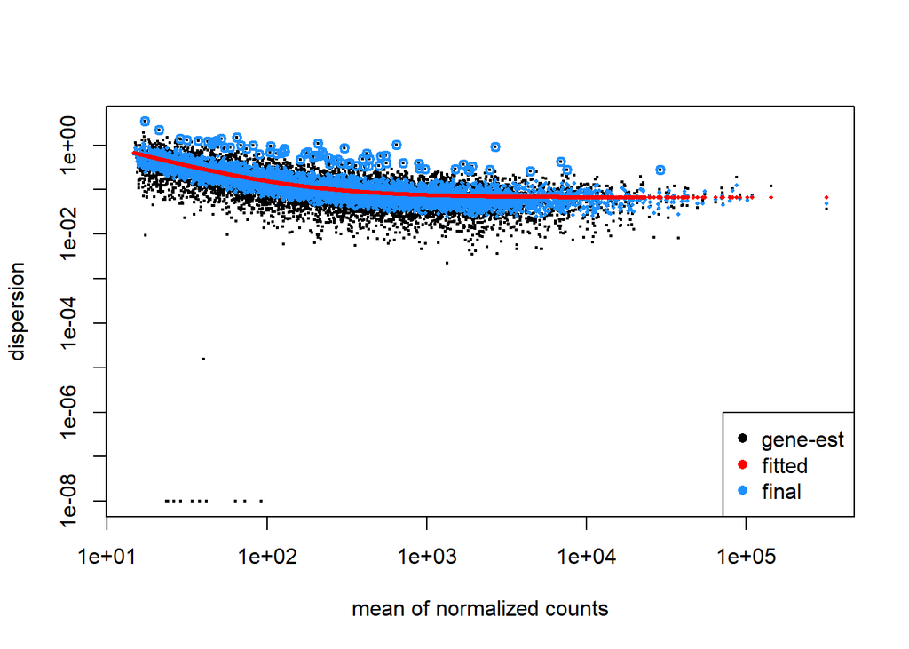

```r
plotDispEsts(nc13.rna.dds)
```

Results

##### NC13 opaKD vs alignemnt control DE genes

```r
nc13.res.opa.ac.rna <- as.data.frame(results(nc13.rna.dds, contrast = c("genotype", "opa", "ac"), independentFiltering = FALSE))
```

Add a column indicating, “Sig”, if a gene is significantly differentially expressed.

Significant DEGs will be genes with a LFC >= 1 or LFC <=-1 and a padj <= 0.05

```r
nc13.res.opa.ac.rna <- nc13.res.opa.ac.rna %>% mutate(.,Sig = if_else((padj <= 0.05 & abs(log2FoldChange) >=1),TRUE,FALSE))
```

Add a column “Change”, indicating if the change in expression was up or down.

```r
nc13.res.opa.ac.rna <- nc13.res.opa.ac.rna %>% mutate(Change = case_when(
  is.na(log2FoldChange) == TRUE | Sig == FALSE ~ "NA",
  log2FoldChange < 0 ~ "DOWN",
  log2FoldChange > 0 ~ "UP"))
```

Add a column, “gene.locus”, with the gene name.

```r
nc13.res.opa.ac.rna <- nc13.res.opa.ac.rna %>% mutate(., gene.locus = rownames(.))
```

MA plot

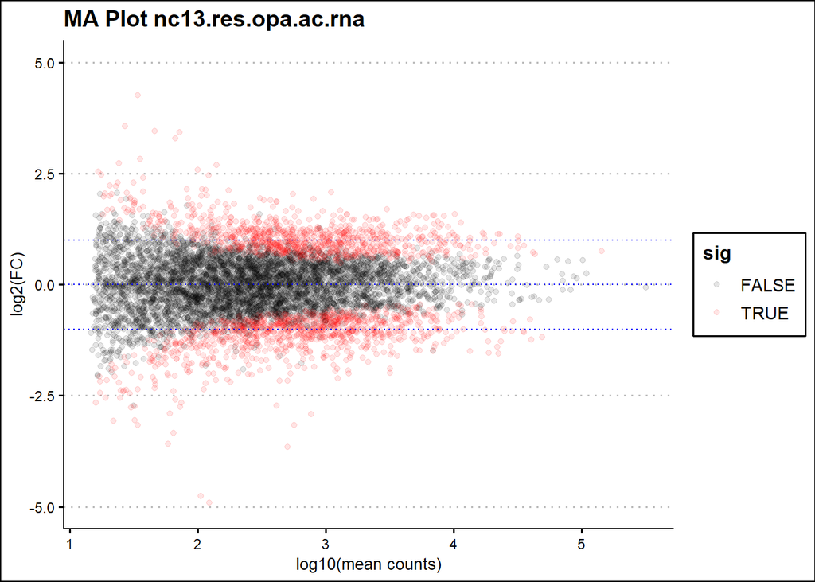

```r
nc13.res.opa.ac.rna %>%
  mutate(sig = padj <= 0.05) %>%
  ggplot(aes(x = log10(baseMean), y = log2FoldChange, color = sig)) +
  geom_point(alpha = 0.1) +
  coord_cartesian(ylim = c(-5,5)) +
  scale_color_manual(values = c("TRUE" = "red", "FALSE" =  "black")) +
  geom_hline(yintercept = c(0,1,-1), linetype = 'dotted', color = 'blue') +
  theme_clean() +
  labs(title = "MA Plot nc13.res.opa.ac.rna",
       x = "log10(mean counts)",
       y = "log2(FC)")
```

Lets plot the result and highlight significant DEGs. For this plot sig DEGs will be highlighted, and the number of DEGs that go up or down will be quantified.

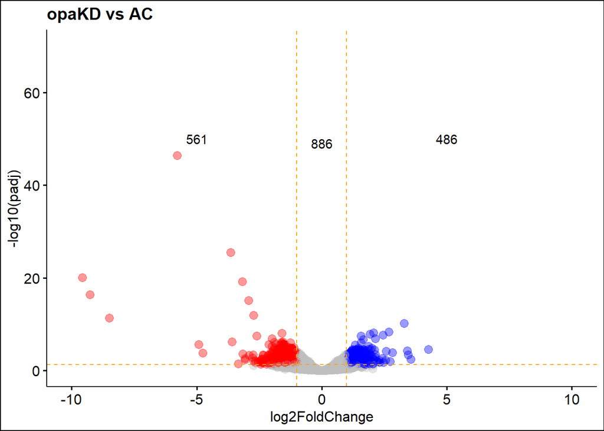

```r
#pdf("../Plots/nc13_opa_ac_rna_volcano_plot_clean.pdf", width = 4, height = 3)

nc13.opa.ac.vol.rna <- nc13.res.opa.ac.rna %>%
  ggplot(aes(x = log2FoldChange, y = -log10(padj), color = Change, size = mean.intensity)) +
  geom_point(alpha = 0.4, size=3) +
  coord_cartesian(xlim = c(-10, 10), ylim = c(0, 70)) +
  geom_hline(yintercept = -log10(0.05), linetype = 'dashed', col = 'orange') +
  geom_vline(xintercept = log2(c(0.5, 2)), linetype = 'dashed', col = 'orange') +
  scale_color_manual(values = c("DOWN" = 'red', "UP" = "blue", "NA" = "grey")) +
  theme_clean(base_size = 12) + theme(legend.position = "none")+
  theme(
    plot.title = element_text(size = 14),
    axis.title = element_text(size = 12),
    axis.text = element_text(size = 12),
    panel.grid.major.y = element_blank(),
    panel.grid.minor.y = element_blank()
  ) +labs(title = 'opaKD vs AC')

nc13.opa.ac.vol.rna  +
  annotate(geom = "text", x = -5, y = 50, label = length(which(nc13.res.opa.ac.rna$padj <= 0.05 & nc13.res.opa.ac.rna$log2FoldChange <= -1))) +
  annotate(geom = "text", x = 5, y = 50, label = length(which(nc13.res.opa.ac.rna$padj <= 0.05 & nc13.res.opa.ac.rna$log2FoldChange >= 1))) +
  annotate(geom = 'text', x = 0, y = 49, label = length(which(nc13.res.opa.ac.rna$padj <= 0.05 & abs(nc13.res.opa.ac.rna$log2FoldChange) < 1)))
```

```r
#dev.off()
```

##### NC13 opaKD vs dsRed injection control DE genes

```r
nc13.res.opa.dsred.rna <- as.data.frame(results(nc13.rna.dds, contrast = c("genotype", "opa", "dsred"), independentFiltering = FALSE))
```

Add a column indicating, “Sig”, if a gene is significantly differentially expressed.

Significant DEGs will be genes with a LFC >= 1 or LFC <=-1 and a padj <= 0.05

```r
nc13.res.opa.dsred.rna <- nc13.res.opa.dsred.rna  %>% mutate(.,Sig = if_else((padj <= 0.05 & abs(log2FoldChange) >=1),TRUE,FALSE))
```

Add a column “Change”, indicating if the change in expression was up or down.

```r
nc13.res.opa.dsred.rna  <-nc13.res.opa.dsred.rna %>% mutate(Change = case_when(
  is.na(log2FoldChange) == TRUE | Sig == FALSE ~ "NA",
  log2FoldChange < 0 ~ "DOWN",
  log2FoldChange > 0 ~ "UP"))
```

Add a column, “gene.locus”, with the gene name.

```r
nc13.res.opa.dsred.rna <- nc13.res.opa.dsred.rna  %>% mutate(., gene.locus = rownames(.))
```

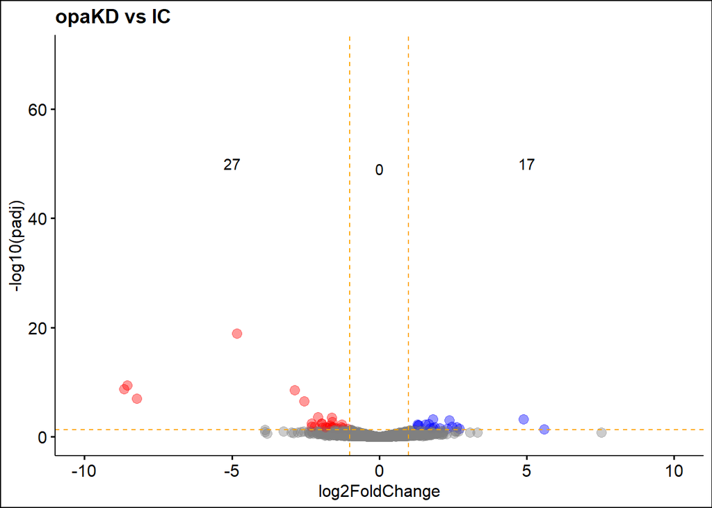

```r
#pdf("../Plots/nc13_opa_dsred_rna_volcano_plot_clean.pdf", width = 4, height = 3)
# Create base plot object

nc13.opa.dsred.rna.vol.rna <- nc13.res.opa.dsred.rna %>%
  ggplot(aes(x = log2FoldChange, y = -log10(padj), color = Change, size = mean.intensity)) +
  geom_point(alpha = 0.4, size=3) +
  coord_cartesian(xlim = c(-10, 10), ylim = c(0, 70)) +
  geom_hline(yintercept = -log10(0.05), linetype = 'dashed', col = 'orange') +
  geom_vline(xintercept = log2(c(0.5, 2)), linetype = 'dashed', col = 'orange') +
  scale_color_manual(values = c("DOWN" = 'red', "UP" = "blue", "NS" = "grey")) +
  theme_clean(base_size = 12) + theme(legend.position = "none")+
  theme(
    plot.title = element_text(size = 14),
    axis.title = element_text(size = 12),
    axis.text = element_text(size = 12),
    panel.grid.major.y = element_blank(),
    panel.grid.minor.y = element_blank()
  ) +
  labs(title = 'opaKD vs IC')

# Print plot with annotated counts
nc13.opa.dsred.rna.vol.rna  +
  annotate(geom = "text", x = -5, y = 50, label = length(which(nc13.res.opa.dsred.rna$padj <= 0.05 & nc13.res.opa.dsred.rna$log2FoldChange <= -1))) +
  annotate(geom = "text", x = 5, y = 50, label = length(which(nc13.res.opa.dsred.rna$padj <= 0.05 & nc13.res.opa.dsred.rna$log2FoldChange >= 1))) +
  annotate(geom = 'text', x = 0, y = 49, label = length(which(nc13.res.opa.dsred.rna$padj <= 0.05 & abs(nc13.res.opa.dsred.rna$log2FoldChange) < 1)))
```

```r
#dev.off()
```

##### NC13 opaKD vs opanoKD DE genes

```r
# Extract results for opaKD vs opanoKD
nc13.res.opaKD.opanoKD.rna <- as.data.frame(results(nc13.rna.dds, contrast = c("genotype", "opa", "noKD"), independentFiltering = FALSE))

# Add Sig, Change, and gene.locus columns
nc13.res.opaKD.opanoKD.rna <- nc13.res.opaKD.opanoKD.rna %>%
  mutate(Sig = if_else((padj <= 0.05 & abs(log2FoldChange) >= 1), TRUE, FALSE)) %>%
  mutate(Change = case_when(
    is.na(log2FoldChange) == TRUE | Sig == FALSE ~ "NA",
    log2FoldChange < 0 ~ "DOWN",
    log2FoldChange > 0 ~ "UP"
  ))%>% mutate(., gene.locus = rownames(.))
```

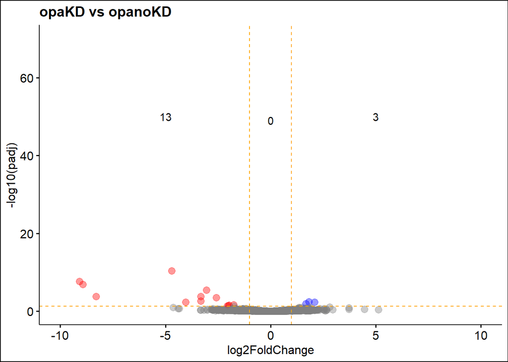

```r
#pdf("../Plots/nc13_opaKD_opanoKD_rna_volcano_plot_clean.pdf", width = 4, height = 3)
# Create base plot object


nc13.opaKD.opanoKD.vol.rna <- nc13.res.opaKD.opanoKD.rna %>%
  ggplot(aes(x = log2FoldChange, y = -log10(padj), color = Change, size = mean.intensity)) +
  geom_point(alpha = 0.4, size=3) +
  coord_cartesian(xlim = c(-10, 10), ylim = c(0, 70)) +
  geom_hline(yintercept = -log10(0.05), linetype = 'dashed', col = 'orange') +
  geom_vline(xintercept = log2(c(0.5, 2)), linetype = 'dashed', col = 'orange') +
  scale_color_manual(values = c("DOWN" = 'red', "UP" = "blue", "NS" = "grey")) +
  # --- CHANGE 1: Increase base_size here ---
  # theme_clean usually defaults to 12. changing to 18 makes it much larger.
  theme_clean(base_size = 12) + theme(legend.position = "none")+

  # Optional: Fine-tune specific elements if base_size isn't enough
  theme(
    plot.title = element_text(size = 14),
    axis.title = element_text(size = 12),
    axis.text = element_text(size = 12),
    panel.grid.major.y = element_blank(),
    panel.grid.minor.y = element_blank()
  ) +
  labs(title = 'opaKD vs opanoKD')



# Print plot with annotated counts
nc13.opaKD.opanoKD.vol.rna  +
  annotate(geom = "text", x = -5, y = 50, label = length(which(nc13.res.opaKD.opanoKD.rna$padj <= 0.05 & nc13.res.opaKD.opanoKD.rna$log2FoldChange <= -1))) +
  annotate(geom = "text", x = 5, y = 50, label = length(which(nc13.res.opaKD.opanoKD.rna$padj <= 0.05 & nc13.res.opaKD.opanoKD.rna$log2FoldChange >= 1))) +
  annotate(geom = 'text', x = 0, y = 49, label = length(which(nc13.res.opaKD.opanoKD.rna$padj <= 0.05 & abs(nc13.res.opaKD.opanoKD.rna$log2FoldChange) < 1)))
```

```r
#dev.off()
```

##### NC13 opanoKD vs alignment control DE genes

```r
#extract results for opanoKD vs AC
nc13.res.opanoKD.ac.rna <- as.data.frame(results(nc13.rna.dds, contrast = c("genotype", "noKD", "ac"), independentFiltering = FALSE))
# Add Sig, Change, and gene.locus columns
nc13.res.opanoKD.ac.rna <- nc13.res.opanoKD.ac.rna %>%
  mutate(Sig = if_else((padj <= 0.05 & abs(log2FoldChange) >= 1), TRUE, FALSE)) %>%
  mutate(Change = case_when(
    is.na(log2FoldChange) == TRUE | Sig == FALSE ~ "NA",
    log2FoldChange < 0 ~ "DOWN",
    log2FoldChange > 0 ~ "UP"
  ))%>% mutate(., gene.locus = rownames(.))
```

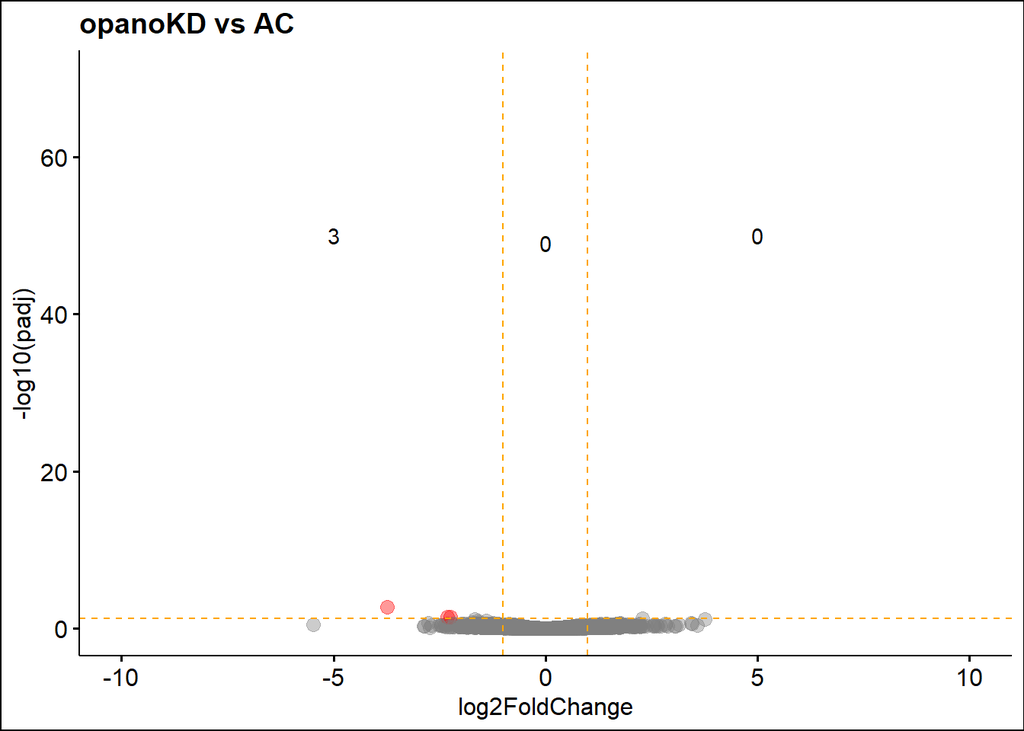

```r
#volcano plot for opanoKD vs AC
#pdf("../Plots/nc13_opanoKD_ac_rna_volcano_plot_clean.pdf", width = 4, height = 3)

nc13.opanoKD.ac.vol.rna <- nc13.res.opanoKD.ac.rna %>%
  ggplot(aes(x = log2FoldChange, y = -log10(padj), color = Change, size = mean.intensity)) +
  geom_point(alpha = 0.4, size=3) +
  coord_cartesian(xlim = c(-10, 10), ylim = c(0, 70)) +
  geom_hline(yintercept = -log10(0.05), linetype = 'dashed', col = 'orange') +
  geom_vline(xintercept = log2(c(0.5, 2)), linetype = 'dashed', col = 'orange') +
  scale_color_manual(values = c("DOWN" = 'red', "UP" = "blue", "NS" = "grey")) +
  theme_clean(base_size = 12) + theme(legend.position = "none")+
  theme(
    plot.title = element_text(size = 14),
    axis.title = element_text(size = 12),
    axis.text = element_text(size = 12),
    panel.grid.major.y = element_blank(),
    panel.grid.minor.y = element_blank()
  ) +
  labs(title = 'opanoKD vs AC')

# Print plot with annotated counts
nc13.opanoKD.ac.vol.rna  +
  annotate(geom = "text", x = -5, y = 50, label = length(which(nc13.res.opanoKD.ac.rna$padj <= 0.05 & nc13.res.opanoKD.ac.rna$log2FoldChange <= -1))) +
  annotate(geom = "text", x = 5, y = 50, label = length(which(nc13.res.opanoKD.ac.rna$padj <= 0.05 & nc13.res.opanoKD.ac.rna$log2FoldChange >= 1))) +
  annotate(geom = 'text', x = 0, y = 49, label = length(which(nc13.res.opanoKD.ac.rna$padj <= 0.05 & abs(nc13.res.opanoKD.ac.rna$log2FoldChange) < 1)))
```

```r
#dev.off()
```

##### save.NC13 opa DEG comparisons

```r
nc13.res.opa.ac.rna<-nc13.res.opa.ac.rna%>% mutate(best_hit_in_Dme=blast.data[gene.locus,]$gene_name)
nc13.res.opaKD.opanoKD.rna<-nc13.res.opaKD.opanoKD.rna%>% mutate(best_hit_in_Dme=blast.data[gene.locus,]$gene_name)
nc13.res.opa.dsred.rna<-nc13.res.opa.dsred.rna%>% mutate(best_hit_in_Dme=blast.data[gene.locus,]$gene_name)
nc13.res.opanoKD.ac.rna<-nc13.res.opanoKD.ac.rna%>% mutate(best_hit_in_Dme=blast.data[gene.locus,]$gene_name)

write_xlsx(list("nc13.opa.ac.rna"=nc13.res.opa.ac.rna,"nc13.opaKD.opanoKD.rna"=nc13.res.opaKD.opanoKD.rna, "nc13.opa.dsred.rna"=nc13.res.opa.dsred.rna, "nc13.opanoKD.ac.rna"=nc13.res.opanoKD.ac.rna), paste0(opa.results.folder, "NC13_opa_degs.xlsx"))
```

#### NC13 DESeq2 ATAC-seq data

```r
nc13.atac.dds <- DESeqDataSetFromMatrix(countData = nc13.opakd.counts.atac, colData = nc13.opakd.coldata.atac, design = ~ Experiment.Date + genotype)
nc13.atac.dds <- DESeq(nc13.atac.dds, parallel = FALSE)
```

Check that the names of results are as expected.

```r
resultsNames(nc13.atac.dds)
```

```
## [1] "Intercept"                        "Experiment.Date_230511_vs_230616"
## [3] "Experiment.Date_230622_vs_230616" "genotype_dsred_vs_ac"
## [5] "genotype_intKD_vs_ac"             "genotype_noKD_vs_ac"
## [7] "genotype_opa_vs_ac"               "genotype_wt_vs_ac"
```

Dispersion estimates. Take a look at dispersion to makes sure that the data fitting looks reasonable.

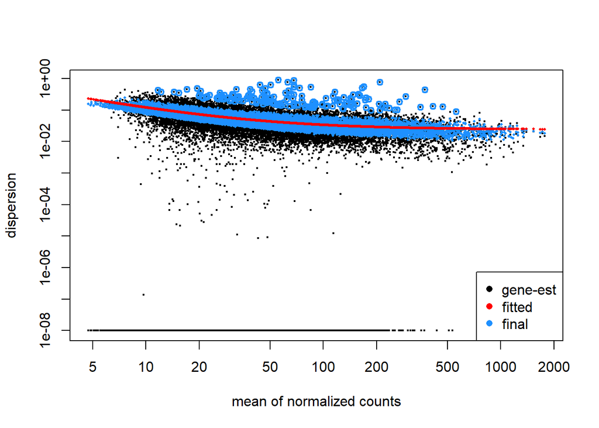

```r
plotDispEsts(nc13.atac.dds)
```

##### NC13 opaKD vs alignment control DA peaks

```r
nc13.res.opa.ac.atac <- as.data.frame(results(nc13.atac.dds, contrast = c("genotype", "opa", "ac"), independentFiltering = FALSE))
```

Add a column, “Sig”, indicating if a peak has undergone a significantly change in accessibility.

Significant DAPs will be peaks with a LFC >= 1 or LFC <=-1 and a padj <= 0.05

```r
nc13.res.opa.ac.atac <- nc13.res.opa.ac.atac %>% mutate(.,Sig = if_else((padj <= 0.05 & abs(log2FoldChange) >=1),TRUE,FALSE))
```

Add a column, “Change”, indicating if the change in accessibility was up or down.

```r
nc13.res.opa.ac.atac <- nc13.res.opa.ac.atac %>%
  mutate(Change = case_when(
  is.na(log2FoldChange) == TRUE | Sig == FALSE ~ "NA",
  log2FoldChange < 0 ~ "DOWN",
  log2FoldChange > 0 ~ "UP"))
```

Add a column, “peak.name” with the peak name and a column geneId with the nearby gene.

```r
nc13.res.opa.ac.atac <- nc13.res.opa.ac.atac %>% mutate(., peak.name = rownames(.))
nc13.res.opa.ac.atac$gene_locus<-peak_annotation[match(nc13.res.opa.ac.atac$peak.name, row.names(peak_annotation)),]$geneId
```

MA plot

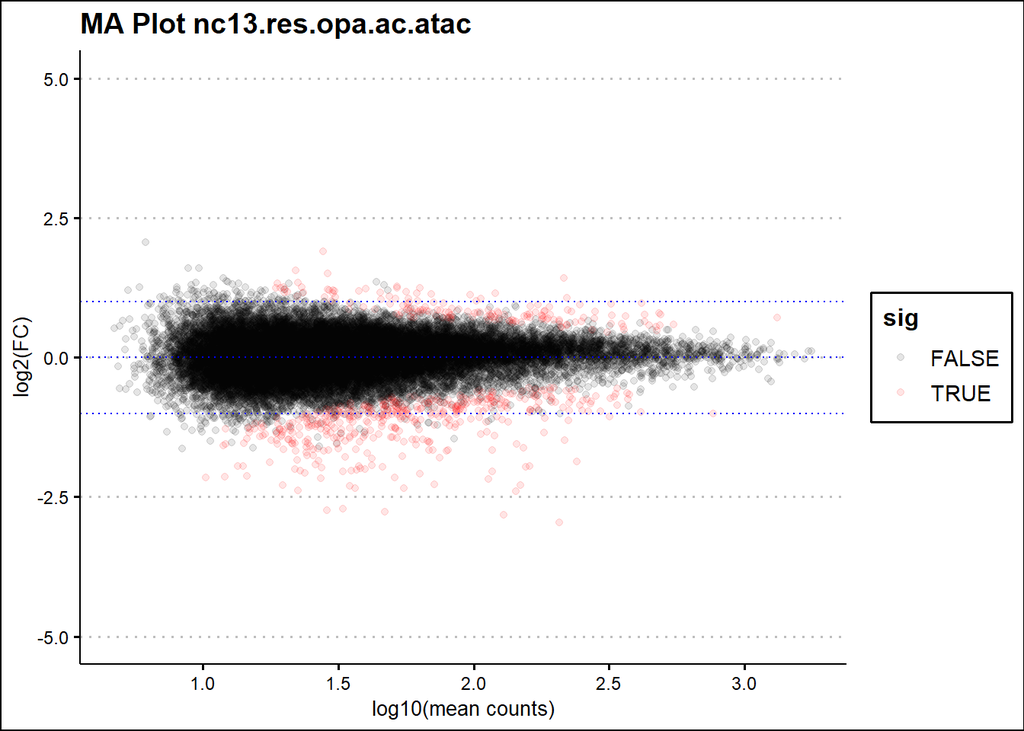

```r
nc13.res.opa.ac.atac %>%
  mutate(sig = padj <= 0.05) %>%
  ggplot(aes(x = log10(baseMean), y = log2FoldChange, color = sig)) +
  geom_point(alpha = 0.1) +
  coord_cartesian(ylim = c(-5,5)) +
  scale_color_manual(values = c("TRUE" = "red", "FALSE" =  "black")) +
  geom_hline(yintercept = c(0,1,-1), linetype = 'dotted', color = 'blue') +
  theme_clean() +
  labs(title = "MA Plot nc13.res.opa.ac.atac",
       x = "log10(mean counts)",
       y = "log2(FC)")
```

Lets plot the result and highlight significant DAPs. For this plot sig DAPs will be highlighted, and the number of DAPs that go up or down will be quantified. The size of each data point will correspond to the intensity of the peak.

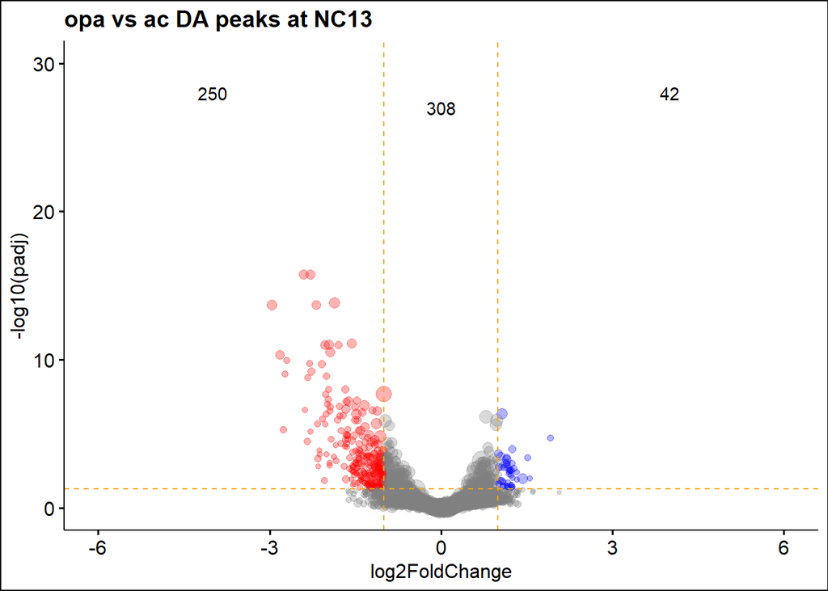

```r
#pdf("../Plots/nc13_opa_ac_atac_volcano_plot.pdf", width = 4, height = 3)

nc13.opa.ac.vol.atac <- nc13.res.opa.ac.atac %>%
  mutate(mean.intensity = baseMean/max(baseMean)) %>%
  ggplot(aes(x = log2FoldChange, y = -log10(padj), color = Change, size = mean.intensity)) +
  geom_point(alpha = 0.3) +
  coord_cartesian(xlim =c(-6,6),ylim = c(0,30)) +
  geom_hline(yintercept = -log10(0.05), linetype = 'dashed', col = 'orange') +
  geom_vline(xintercept = log2(c(0.5,2)), linetype = 'dashed', col = 'orange') +
  scale_color_manual(values = c("DOWN" = 'red', "UP" = "blue", "NS" = "grey")) +
  theme_clean(base_size = 12) + theme(legend.position = "none")+
  theme(
   plot.title = element_text(size = 14),
    axis.title = element_text(size = 12),
    axis.text = element_text(size = 12),
    panel.grid.major.y = element_blank(),
    panel.grid.minor.y = element_blank()
  ) +
  labs(title = 'opa vs ac DA peaks at NC13')

nc13.opa.ac.vol.atac  +
  annotate(geom = "text", x = -4, y = 28, label = length(which(nc13.res.opa.ac.atac$padj <= 0.05 & nc13.res.opa.ac.atac$log2FoldChange <= -1))) +
  annotate(geom = "text", x = 4, y = 28, label = length(which(nc13.res.opa.ac.atac$padj <= 0.05 & nc13.res.opa.ac.atac$log2FoldChange >= 1))) +
  annotate(geom = 'text', x = 0, y = 27, label = length(which(nc13.res.opa.ac.atac$padj <= 0.05 & abs(nc13.res.opa.ac.atac$log2FoldChange) < 1)))
```

```r
#dev.off()
```

##### NC13 opaKD vs injection control DA peaks

```r
# Extract results for opaKD vs opanoKD (ATAC)
nc13.res.opaKD.dsred.atac <- as.data.frame(results(nc13.atac.dds, contrast = c("genotype", "opa", "dsred"), independentFiltering = FALSE))

# Add Sig, Change, and peak.name columns
nc13.res.opaKD.dsred.atac <- nc13.res.opaKD.dsred.atac %>%
  mutate(Sig = if_else((padj <= 0.05 & abs(log2FoldChange) >= 1), TRUE, FALSE)) %>%
  mutate(Change = case_when(
    is.na(log2FoldChange) == TRUE | Sig == FALSE ~ "NA",
    log2FoldChange < 0 ~ "DOWN",
    log2FoldChange > 0 ~ "UP"
  ))%>% mutate(peak.name = rownames(.))
```

```r
nc13.res.opaKD.dsred.atac$gene_locus<-peak_annotation[match(nc13.res.opaKD.dsred.atac$peak.name, row.names(peak_annotation)),]$geneId
```

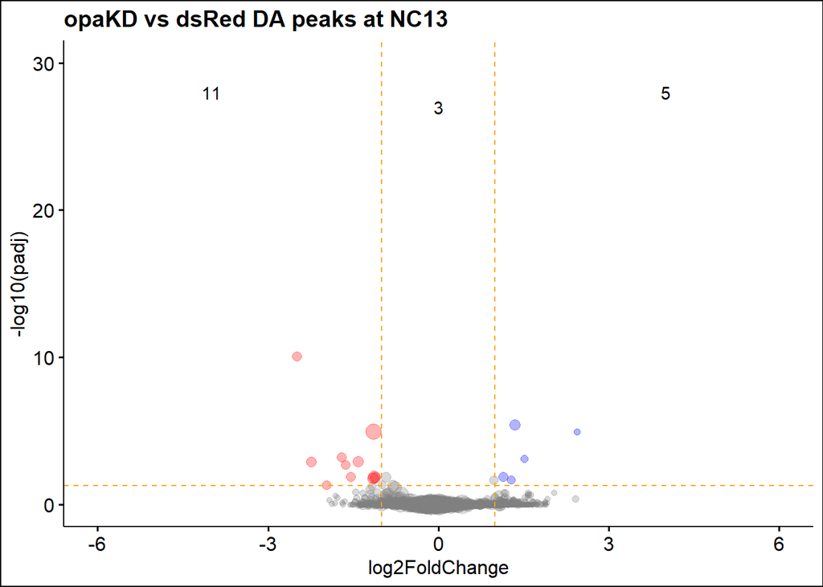

```r
#pdf("../Plots/nc13_opaKD_dsred_atac_volcano_plot.pdf", width = 4, height = 3)
# Create the base plot object
nc13.res.opaKD.dsred.vol.atac <- nc13.res.opaKD.dsred.atac%>%
  mutate(mean.intensity = baseMean/max(baseMean)) %>%
  ggplot(aes(x = log2FoldChange, y = -log10(padj), color = Change, size = mean.intensity)) +
  geom_point(alpha = 0.3) +
  coord_cartesian(xlim = c(-6,6), ylim = c(0,30)) +
  geom_hline(yintercept = -log10(0.05), linetype = 'dashed', col = 'orange') +
  geom_vline(xintercept = log2(c(0.5,2)), linetype = 'dashed', col = 'orange') +
  scale_color_manual(values = c("DOWN" = 'red', "UP" = "blue", "NS" = "grey"))+
  theme_clean(base_size = 12) + theme(legend.position = "none")+
  theme(
   plot.title = element_text(size = 14),
    axis.title = element_text(size = 12),
    axis.text = element_text(size = 12),
    panel.grid.major.y = element_blank(),
    panel.grid.minor.y = element_blank()
  ) +
  labs(title = 'opaKD vs dsRed DA peaks at NC13')

# Print the plot with annotated counts
nc13.res.opaKD.dsred.vol.atac  +
  annotate(geom = "text", x = -4, y = 28, label = length(which(nc13.res.opaKD.dsred.atac$padj <= 0.05 & nc13.res.opaKD.dsred.atac$log2FoldChange <= -1))) +
  annotate(geom = "text", x = 4, y = 28, label = length(which(nc13.res.opaKD.dsred.atac$padj <= 0.05 & nc13.res.opaKD.dsred.atac$log2FoldChange >= 1))) +
  annotate(geom = 'text', x = 0, y = 27, label = length(which(nc13.res.opaKD.dsred.atac$padj <= 0.05 & abs(nc13.res.opaKD.dsred.atac$log2FoldChange) < 1)))
```

```r
#dev.off()
```

##### NC13 opaKD vs opanoKD DA peaks

```r
# Extract results for opaKD vs IC (ATAC)
nc13.res.opaKD.opanoKD.atac <- as.data.frame(results(nc13.atac.dds, contrast = c("genotype", "opa", "noKD"), independentFiltering = FALSE))

# Add Sig, Change, and peak.name columns
nc13.res.opaKD.opanoKD.atac <- nc13.res.opaKD.opanoKD.atac  %>%
  mutate(Sig = if_else((padj <= 0.05 & abs(log2FoldChange) >= 1), TRUE, FALSE)) %>%
  mutate(Change = case_when(
    is.na(log2FoldChange) == TRUE | Sig == FALSE ~ "NA",
    log2FoldChange < 0 ~ "DOWN",
    log2FoldChange > 0 ~ "UP"
  ))%>% mutate(peak.name = rownames(.))
```

Add a column geneId with the nearby gene.

```r
nc13.res.opaKD.opanoKD.atac$gene_locus<-peak_annotation[match(nc13.res.opaKD.opanoKD.atac$peak.name, row.names(peak_annotation)),]$geneId
```

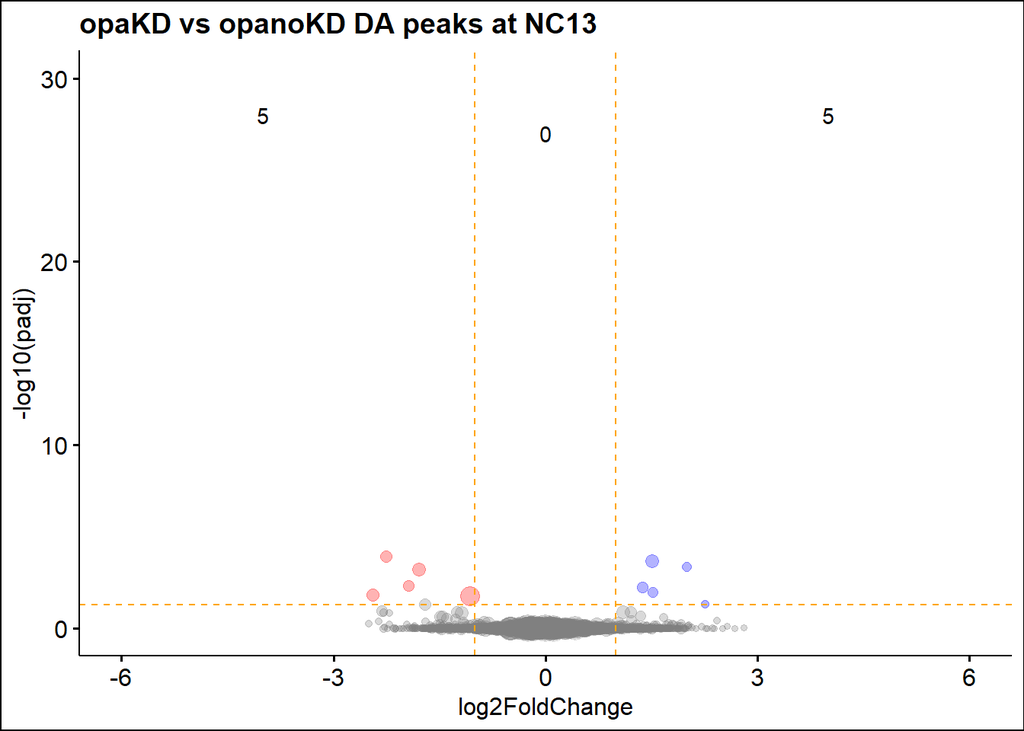

```r
#pdf("../Plots/nc13_opaKD_opanoKD_atac_volcano_plot.pdf", width = 4, height = 3)
# Create the base plot object
nc13.opaKD.opanoKD.vol.atac <- nc13.res.opaKD.opanoKD.atac %>%
  mutate(mean.intensity = baseMean/max(baseMean)) %>%
  ggplot(aes(x = log2FoldChange, y = -log10(padj), color = Change, size = mean.intensity)) +
  geom_point(alpha = 0.3) +
  coord_cartesian(xlim = c(-6,6), ylim = c(0,30)) +
  geom_hline(yintercept = -log10(0.05), linetype = 'dashed', col = 'orange') +
  geom_vline(xintercept = log2(c(0.5,2)), linetype = 'dashed', col = 'orange') +
  scale_color_manual(values = c("DOWN" = 'red', "UP" = "blue", "NS" = "grey"))+
  theme_clean() + theme(legend.position = "none")+
  theme(
   plot.title = element_text(size = 14),
    axis.title = element_text(size = 12),
    axis.text = element_text(size = 12),
    panel.grid.major.y = element_blank(),
    panel.grid.minor.y = element_blank()
  ) +
  labs(title = 'opaKD vs opanoKD DA peaks at NC13')

# Print the plot with annotated counts
nc13.opaKD.opanoKD.vol.atac  +
  annotate(geom = "text", x = -4, y = 28, label = length(which(nc13.res.opaKD.opanoKD.atac$padj <= 0.05 & nc13.res.opaKD.opanoKD.atac$log2FoldChange <= -1))) +
  annotate(geom = "text", x = 4, y = 28, label = length(which(nc13.res.opaKD.opanoKD.atac$padj <= 0.05 & nc13.res.opaKD.opanoKD.atac$log2FoldChange >= 1))) +
  annotate(geom = 'text', x = 0, y = 27, label = length(which(nc13.res.opaKD.opanoKD.atac$padj <= 0.05 & abs(nc13.res.opaKD.opanoKD.atac$log2FoldChange) < 1)))
```

```r
#dev.off()
```

##### NC13 opanoKD vs alignment DA peaks

```r
nc13.res.opanoKD.ac.atac <- as.data.frame(results(nc13.atac.dds, contrast = c("genotype", "noKD", "ac"), independentFiltering = FALSE))
# Add Sig, Change, and peak.name columns
nc13.res.opanoKD.ac.atac <- nc13.res.opanoKD.ac.atac%>%
  mutate(Sig = if_else((padj <= 0.05 & abs(log2FoldChange) >= 1), TRUE, FALSE)) %>%
  mutate(Change = case_when(
    is.na(log2FoldChange) == TRUE | Sig == FALSE ~ "NA",
    log2FoldChange < 0 ~ "DOWN",
    log2FoldChange > 0 ~ "UP"
  )) %>%mutate(peak.name = rownames(.))
```

Add a column geneId with the nearby gene.

```r
nc13.res.opanoKD.ac.atac$gene_locus<-peak_annotation[match(nc13.res.opanoKD.ac.atac$peak.name, row.names(peak_annotation)),]$geneId
```

volcano plot for noKD vs AC (ATAC)

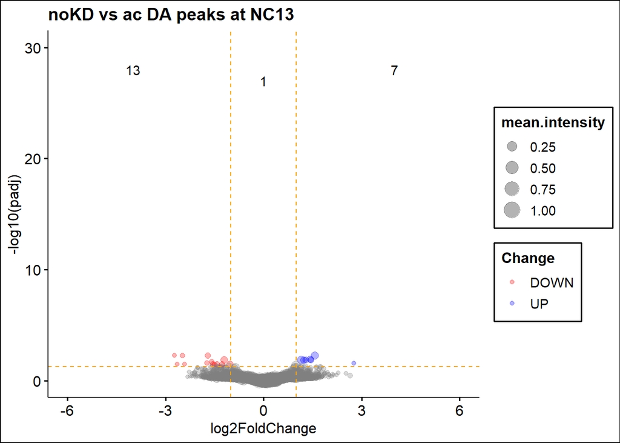

```r
#pdf("../Plots/nc13_opanoKD_ac_atac_volcano_plot_legend.pdf", width = 5, height = 3)
nc13.nokD.ac.vol.atac <- nc13.res.opanoKD.ac.atac %>%
  mutate(mean.intensity = baseMean/max(baseMean)) %>%
  ggplot(aes(x = log2FoldChange, y = -log10(padj), color = Change, size = mean.intensity)) +
  geom_point(alpha = 0.3) +
  coord_cartesian(xlim = c(-6,6), ylim = c(0,30)) +
  geom_hline(yintercept = -log10(0.05), linetype = 'dashed', col = 'orange') +
  geom_vline(xintercept = log2(c(0.5,2)), linetype = 'dashed', col = 'orange') +
  scale_color_manual(values = c("DOWN" = 'red', "UP" = "blue", "NS" = "grey"))+
  theme_clean()  + #theme(legend.position = "none")+
  theme(
   plot.title = element_text(size = 14),
    axis.title = element_text(size = 12),
    axis.text = element_text(size = 12),
    panel.grid.major.y = element_blank(),
    panel.grid.minor.y = element_blank()
  ) +
  labs(title = 'noKD vs ac DA peaks at NC13')

nc13.nokD.ac.vol.atac  +
  annotate(geom = "text", x = -4, y = 28, label = length(which(nc13.res.opanoKD.ac.atac$padj <= 0.05 & nc13.res.opanoKD.ac.atac$log2FoldChange <= -1))) +
  annotate(geom = "text", x = 4, y = 28, label = length(which(nc13.res.opanoKD.ac.atac$padj <= 0.05 & nc13.res.opanoKD.ac.atac$log2FoldChange >= 1))) +
  annotate(geom = 'text', x = 0, y = 27, label = length(which(nc13.res.opanoKD.ac.atac$padj <= 0.05 & abs(nc13.res.opanoKD.ac.atac$log2FoldChange) < 1)))
```

```r
#dev.off()
```

##### save NC13 ATAC dap results

```r
write_xlsx(list("nc13.opa.ac.atac.nc13"=nc13.res.opa.ac.atac,"nc13.opa.dsred.atac"=nc13.res.opaKD.dsred.atac,"nc13.opaKD.opanoKD.atac"=nc13.res.opaKD.opanoKD.atac,"nc13.noKD.ac.atac"=nc13.res.opanoKD.ac.atac), paste0(opa.results.folder, "NC13_opa_daps_all.xlsx"))
```

## 5. MEME opa DA peaks

We will use MEME to identify motifs in Cal-opa sensitive peaks.

MEME will be performed on all Cal-opa sensitive peaks, Cal-opa sensitive peaks that lose accessibility and Cal-opa sensitive peaks that gain accessibility. Data will be combined for NC12 and NC13.

Get the names of DA peaks for each stage.

```r
nc12.daps.up <- nc12.res.opa.ac.atac %>% filter(.,Sig == TRUE & Change == "UP") %>% rownames()
nc12.daps.up.IC<-nc12.res.opa.dsred.atac %>% filter(.,Sig == TRUE & Change == "UP") %>% rownames()
#nc12.daps.up


nc12.daps.down <- nc12.res.opa.ac.atac %>% filter(.,Sig == TRUE & Change == "DOWN") %>% rownames()
nc12.daps.down.IC<-nc12.res.opa.dsred.atac %>% filter(.,Sig == TRUE & Change == "DOWN") %>% rownames()
#nc12.daps.down
```

```r
nc13.daps.up <- nc13.res.opa.ac.atac %>% filter(.,Sig == TRUE & Change == "UP") %>% rownames()
nc13.daps.up.IC<-nc13.res.opaKD.dsred.atac %>% filter(.,Sig == TRUE & Change == "UP") %>% rownames()
#nc13.daps.up


nc13.daps.down <- nc13.res.opa.ac.atac %>% filter(.,Sig == TRUE & Change == "DOWN") %>% rownames()
nc13.daps.down.IC<-nc13.res.opaKD.dsred.atac %>% filter(.,Sig == TRUE & Change == "DOWN") %>% rownames()
#nc13.daps.down
```

Combine NC12 and NC13 DAPs UP or DOWN. Combine all DAPs UP and DOWN.

```r
# remove any duplicates using unique

opa.daps.up <- unique(c(nc12.daps.up,nc13.daps.up))

opa.daps.down <- unique(c(nc12.daps.down,nc13.daps.down))

opa.daps.all <- c(opa.daps.up,opa.daps.down)

opa.daps.up.IC<-unique(c(nc12.daps.up.IC,nc13.daps.up.IC))
opa.daps.down.IC<-unique(c(nc12.daps.down.IC,nc13.daps.down.IC))
```

get all background peaks

```r
nc13.opaKD.ac.daps.BG<-nc13.res.opa.ac.atac %>% filter(.,Sig == FALSE ) %>% rownames()
nc13.opanoKD.ac.daps.BG<-nc13.res.opanoKD.ac.atac  %>% filter(.,Sig == FALSE ) %>% rownames()
nc13.opaKD.opanoKD.daps.BG<-nc13.res.opaKD.opanoKD.atac %>% filter(.,Sig == FALSE ) %>% rownames()
nc13.opaKD.dsred.daps.BG<-nc13.res.opaKD.dsred.atac%>% filter(.,Sig == FALSE ) %>% rownames()
nc12.opaKD.ac.daps.BG<-nc12.res.opa.ac.atac%>% filter(.,Sig == FALSE ) %>% rownames()
nc12.opaKD.dsred.daps.BG<-nc12.res.opa.dsred.atac%>% filter(.,Sig == FALSE ) %>% rownames()

opa.daps.all.BG<-common_names <- Reduce(intersect, list(nc13.opaKD.ac.daps.BG,nc13.opanoKD.ac.daps.BG, nc13.opaKD.opanoKD.daps.BG,nc13.opaKD.dsred.daps.BG, nc12.opaKD.dsred.daps.BG,nc12.opaKD.ac.daps.BG))
```

Get sequences for each peak group using the get.my.seqs function.

```r
# dir for output
sequence.output.directory<-"../MEME"

get.my.seqs(p = peaks.32157[names(peaks.32157) %in% opa.daps.all.BG], dir = sequence.output.directory, name = "opa-daps-bg")

get.my.seqs(p = peaks.32157[names(peaks.32157) %in% opa.daps.down], dir = sequence.output.directory, name = "opa-daps-down")

get.my.seqs(p = peaks.32157[names(peaks.32157) %in% opa.daps.up], dir = sequence.output.directory, name = "opa-daps-up")

get.my.seqs(p = peaks.32157[names(peaks.32157) %in% opa.daps.all], dir = sequence.output.directory, name = "opa-daps-all")

get.my.seqs(p = peaks.32157[names(peaks.32157) %in% opa.daps.down.IC],dir = sequence.output.directory, name = "opa-daps-down-IC")

get.my.seqs(p = peaks.32157[names(peaks.32157) %in% opa.daps.up.IC],dir = sequence.output.directory, name = "opa-daps-up-IC")
```

We identify an Opa motif enriched in Cal-opa sensitive peaks.

Below we will identify peaks with the Opa motif derived from MEME (Opa PWM 2)

The Opa motif will be searched in peaks as done in previous sections.

#### Find Opa PWM 2

Read in the frequency matrix from MEME.

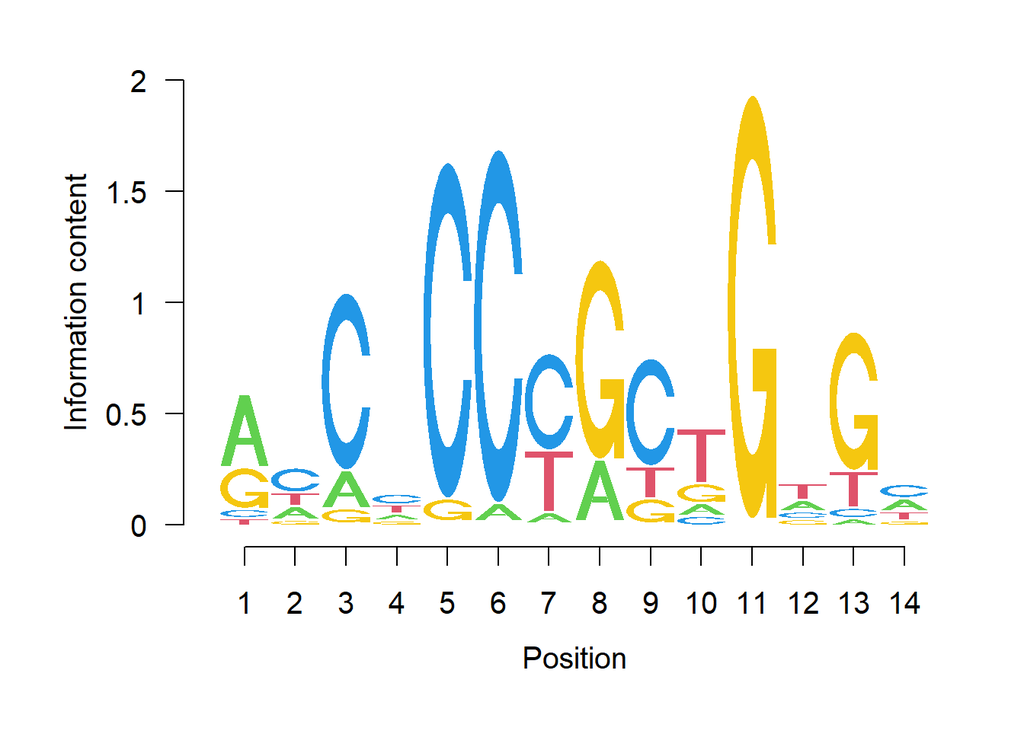

```r
opaPWM2 <- as.matrix(read.table("../PWMs/opa_meme_motif_dis.txt", header = FALSE, sep ="\t"))

colnames(opaPWM2) <- c("A","C","G","T")

topaPWM2 <- t(opaPWM2)
seqLogo(topaPWM2)
```

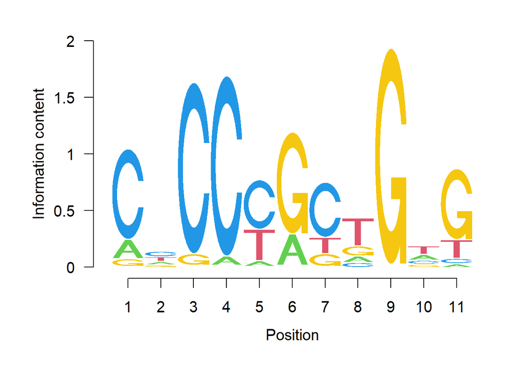

```r
# trim low information positions
opaPWM2 <- opaPWM2[3:13,]
topaPWM2 <- t(opaPWM2)
seqLogo(topaPWM2)
```

Save PWM.

```r
pdf(file = "../Plots/opa-meme.pdf", width = 6,height = 5)

seqLogo(topaPWM2)

dev.off()
```

Reverse complement Opa PWM 2

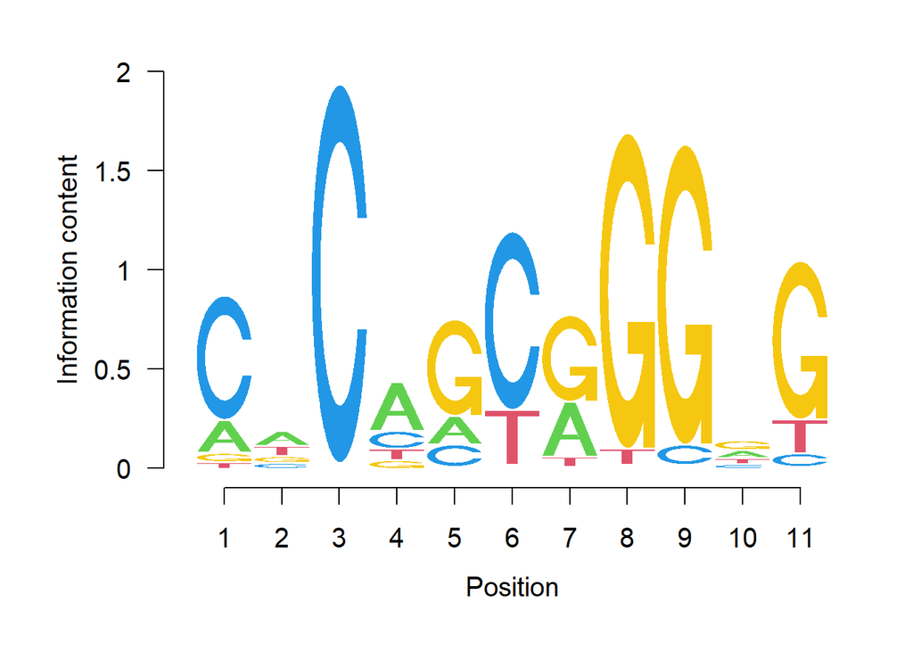

```r
topaPWM2RevCom <- t(reverseComplement(opaPWM2))
seqLogo(topaPWM2RevCom)
```

Save PWM.

```r
pdf(file = "../Plots/opa-meme-revcom.pdf", width = 6,height = 5)

seqLogo(topaPWM2RevCom)

dev.off()
```

(We will save time and skip this part, the updated motif table can be found in ./WT_timecourse/motif-table.txt)

Opa PWM 2 in peaks. We will search both strands

```r
opa.peak.2 <- lapply(seq.peaks, function(x){
  matchPWM(topaPWM2, subject = x, min.score = "80%",with.score = TRUE)
})

opa.peak.rc.2 <- lapply(seq.peaks, function(x){
  matchPWM(topaPWM2RevCom, subject = x, min.score = "80%",with.score = TRUE)
})
```

```r
# peaks with at least one match will have a length greater than 0

n.opa.peak.2 <- opa.peak.2[lengths(opa.peak.2) > 0]

n.opa.peak.rc.2 <- opa.peak.rc.2[lengths(opa.peak.rc.2) > 0]
```

```r
paste0("percent of peaks with an opa MEME motif ",
       round(length(unique(c(names(n.opa.peak.2),names(n.opa.peak.rc.2))))/(length(peaks.32157))*100,1),"%")
```

```r
paste0("percent of peaks with an opa motif ",
       round(length(unique(c(names(n.opa.peak),names(n.opa.peak.rc),names(n.opa.peak.2),names(n.opa.peak.rc.2))))/(length(peaks.32157))*100,1),"%")
```

Update the motif table

```r
opa.peaks.2.l <- names(peaks.32157) %in% names(n.opa.peak.2)
opa.peaks.rc.2.l <- names(peaks.32157) %in% names(n.opa.peak.rc.2)
```

```r
motif.table <- data.frame(motif.table,
           opa.sites.2 = opa.peaks.2.l,
           opa.sites.rc.2 = opa.peaks.rc.2.l)


#head(motif.table)
```

SAVE updated motif table.

```r
write.table(motif.table,file = "../WT_timecourse/motif-table.txt", sep = "\t", row.names = FALSE, col.names = TRUE)
```

## 6. Identifying Cal-opa targets

Starting with NC12

### NC12

##### NC12 high-level observations

Before we get to the targets. We will report some high-level observations.

For these observations the tables characterizing peaks (e.g. genomic.feature.peaks, motif.table) produced in previous sections will be used. Dplyr will be used to merge, filter and manipulate dfs.

Below is the % of DA peaks whose accessibility decreases or increases (DA peaks DOWN or DA peaks UP).

```r
motif.table<-read_delim("../WT_timecourse/motif-table.txt")
nc12.res.opa.ac.atac %>% filter(.,Sig == TRUE) %>%
  count(.,Change) %>%
  mutate(percent = round((n / sum(n)) * 100,1)) %>%
  arrange(desc(percent))
```

```
##   Change  n percent
## 1   DOWN 79    91.9
## 2     UP  7     8.1
```

Below is the % of DA peaks segmented by genomic feature (exon, intron, exon-intron, promoter, or intergenic).

```r
nc12.res.opa.ac.atac  %>%
  merge(x=.,y=genomic.feature.peaks, by = "peak.name",all.x = TRUE)  %>%
  merge(x=.,y=motif.table, by = "peak.name",all.x = TRUE) %>%
  #arrange(original.row) %>%
  filter(.,Sig == TRUE) %>%
  mutate(has.opa.motif = if_else((opa.sites==TRUE | opa.sites.rc == TRUE | opa.sites.2 == TRUE | opa.sites.rc.2),TRUE,FALSE)) %>%
  count(genomic.feature) %>%
  mutate(percent = round((n / sum(n)) * 100,1)) %>%
  arrange(desc(percent))
```

```
##   genomic.feature  n percent
## 1      intergenic 27    31.4
## 2            exon 21    24.4
## 3          intron 19    22.1
## 4 exon and intron 18    20.9
## 5        promoter  1     1.2
```

Below is the % of DA peaks segmented by change and genomic feature (exon, intron, exon-intron, promoter, or intergenic).

```r
nc12.res.opa.ac.atac  %>%
  merge(x=.,y=genomic.feature.peaks, by = "peak.name",all.x = TRUE)  %>%
  merge(x=.,y=motif.table, by = "peak.name",all.x = TRUE) %>%
  #arrange(original.row) %>%
  filter(.,Sig == TRUE) %>%
  mutate(has.opa.motif = if_else((opa.sites==TRUE | opa.sites.rc == TRUE | opa.sites.2 == TRUE | opa.sites.rc.2),TRUE,FALSE)) %>%
  group_by(Change) %>%
  count(genomic.feature) %>%
  ungroup() %>%
  mutate(percent = round((n / sum(n)) * 100,1)) %>%
  arrange(desc(percent))
```

```
## # A tibble: 8 × 4
##   Change genomic.feature     n percent
##   <chr>  <chr>           <int>   <dbl>
## 1 DOWN   intergenic         26    30.2
## 2 DOWN   exon               21    24.4
## 3 DOWN   intron             17    19.8
## 4 DOWN   exon and intron    14    16.3
## 5 UP     exon and intron     4     4.7
## 6 UP     intron              2     2.3
## 7 DOWN   promoter            1     1.2
## 8 UP     intergenic          1     1.2
```

Write to a df.

```r
nc12.opa.daps.change.genomic.feature <- nc12.res.opa.ac.atac  %>%
  merge(x=.,y=genomic.feature.peaks, by = "peak.name",all.x = TRUE)  %>%
  merge(x=.,y=motif.table, by = "peak.name",all.x = TRUE) %>%
  #arrange(original.row) %>%
  filter(.,Sig == TRUE) %>%
  mutate(has.opa.motif = if_else((opa.sites==TRUE | opa.sites.rc == TRUE | opa.sites.2 == TRUE | opa.sites.rc.2),TRUE,FALSE)) %>%
  group_by(Change) %>%
  count(genomic.feature) %>%
  ungroup() %>%
  mutate(percent = round((n / sum(n)) * 100,1))
```

Below is the % of DA peaks that have an Opa motif.

```r
nc12.res.opa.ac.atac  %>% merge(x=.,y=genomic.feature.peaks, by = "peak.name",all.x = TRUE)  %>%
  merge(x=.,y=motif.table, by = "peak.name",all.x = TRUE) %>%
  #arrange(original.row) %>%
  filter(.,Sig == TRUE) %>%
  mutate(has.opa.motif = if_else((opa.sites==TRUE | opa.sites.rc == TRUE | opa.sites.2 == TRUE | opa.sites.rc.2),TRUE,FALSE)) %>%
  count(has.opa.motif) %>%
  mutate(percent = round((n / sum(n)) * 100,1)) %>%
  arrange(desc(percent))
```

```
##   has.opa.motif  n percent
## 1          TRUE 63    73.3
## 2         FALSE 23    26.7
```

Below is the % of DA peaks that have an Opa motif segmented by change.

```r
nc12.res.opa.ac.atac  %>% merge(x=.,y=genomic.feature.peaks, by = "peak.name",all.x = TRUE)  %>%
  merge(x=.,y=motif.table, by = "peak.name",all.x = TRUE) %>%
  #arrange(original.row) %>%
  filter(.,Sig == TRUE) %>%
  mutate(has.opa.motif = if_else((opa.sites==TRUE | opa.sites.rc == TRUE | opa.sites.2 == TRUE | opa.sites.rc.2),TRUE,FALSE)) %>%
  group_by(Change) %>%
  count(has.opa.motif) %>%
  ungroup() %>%
  mutate(percent = round((n / sum(n)) * 100,1)) %>%
  arrange(desc(percent))
```

```
## # A tibble: 3 × 4
##   Change has.opa.motif     n percent
##   <chr>  <lgl>         <int>   <dbl>
## 1 DOWN   TRUE             63    73.3
## 2 DOWN   FALSE            16    18.6
## 3 UP     FALSE             7     8.1
```

Write to a df.

```r
nc12.opa.daps.motif <- nc12.res.opa.ac.atac  %>%
  merge(x=.,y=genomic.feature.peaks, by = "peak.name",all.x = TRUE)  %>%
  merge(x=.,y=motif.table, by = "peak.name",all.x = TRUE) %>%
  #arrange(original.row) %>%
  filter(.,Sig == TRUE) %>%
  mutate(has.opa.motif = if_else((opa.sites==TRUE | opa.sites.rc == TRUE | opa.sites.2 == TRUE | opa.sites.rc.2),TRUE,FALSE)) %>%
  group_by(Change) %>%
  count(has.opa.motif) %>%
  ungroup() %>%
  mutate(percent = round((n / sum(n)) * 100,1))
```

Below is the % of DA peaks that have an Opa motif segmented by change and genomic feature (exon, intron, exon-intron, promoter, or intergenic).

```r
nc12.res.opa.ac.atac  %>%
  merge(x=.,y=genomic.feature.peaks, by = "peak.name",all.x = TRUE)  %>%
  merge(x=.,y=motif.table, by = "peak.name",all.x = TRUE) %>%
  filter(.,Sig == TRUE) %>%
  mutate(has.opa.motif = if_else((opa.sites==TRUE | opa.sites.rc == TRUE | opa.sites.2 == TRUE | opa.sites.rc.2),TRUE,FALSE)) %>%
  group_by(.,genomic.feature,Change) %>%
  count(has.opa.motif) %>%
  ungroup() %>%
  mutate(percent = round((n / sum(n)) * 100,1)) %>%
  arrange(desc(percent))
```

```
## # A tibble: 11 × 5
##    genomic.feature Change has.opa.motif     n percent
##    <chr>           <chr>  <lgl>         <int>   <dbl>
##  1 intergenic      DOWN   TRUE             22    25.6
##  2 exon            DOWN   TRUE             14    16.3
##  3 exon and intron DOWN   TRUE             14    16.3
##  4 intron          DOWN   TRUE             13    15.1
##  5 exon            DOWN   FALSE             7     8.1
##  6 exon and intron UP     FALSE             4     4.7
##  7 intergenic      DOWN   FALSE             4     4.7
##  8 intron          DOWN   FALSE             4     4.7
##  9 intron          UP     FALSE             2     2.3
## 10 intergenic      UP     FALSE             1     1.2
## 11 promoter        DOWN   FALSE             1     1.2
```

Write to a df.

```r
nc12.opa.daps.c.gf.m <- nc12.res.opa.ac.atac  %>%
  merge(x=.,y=genomic.feature.peaks, by = "peak.name",all.x = TRUE)  %>%
  merge(x=.,y=motif.table, by = "peak.name",all.x = TRUE) %>%
  filter(.,Sig == TRUE) %>%
  mutate(has.opa.motif = if_else((opa.sites==TRUE | opa.sites.rc == TRUE | opa.sites.2 == TRUE | opa.sites.rc.2),TRUE,FALSE)) %>%
  group_by(.,genomic.feature,Change) %>%
  count(has.opa.motif) %>%
  ungroup() %>%
  mutate(percent = round((n / sum(n)) * 100,1)) %>%
  group_by(.,Change)
```

Below is the % of DA peaks that fall into a dynamic/non dynamic group segmented by change. Write to df.

```r
nc12.opa.daps.dyn <- nc12.res.opa.ac.atac %>%
  merge(x=.,y=patterns.group.table, by = "peak.name",all.x = TRUE) %>%
  merge(x=.,y=peaks.open.by.stage, by = "peak.name",all.x = TRUE) %>%
  mutate(class = case_when(
  group.1 == TRUE ~ "group.1",
  group.2 == TRUE ~ "group.2",
  group.3 == TRUE ~ "group.3",
  group.4 == TRUE ~ "group.4",
  group.5 == TRUE ~ "group.5",
  group.6 == TRUE ~ "group.6",
  group.7 == TRUE ~ "group.7",
  group.8 == TRUE ~ "group.8",
  group.9 == TRUE ~ "group.9",
  group.10 == TRUE ~ "group.10",
  group.11 == TRUE ~ "group.11",
  group.12 == TRUE ~ "group.12",
  group.13 == TRUE ~ "group.13",
  group.14 == TRUE ~ "group.14",
  group.15 == TRUE ~ "group.15",
  group.16 == TRUE ~ "group.16",
  group.17 == TRUE ~ "group.17",
  group.18 == TRUE ~ "group.18",
  group.19 == TRUE ~ "group.19",
  group.20 == TRUE ~ "group.20",
  group.21 == TRUE ~ "group.21",
  dynamic.peak == TRUE & dynamic.in.class == FALSE ~ "dynamic not in group",
  dynamic.peak == FALSE & dynamic.in.class == FALSE ~ "not dynamic not in group")) %>%
  filter(.,Sig ==TRUE) %>%
  group_by(.,Change) %>%
  count(.,class) %>%
  mutate(percent = round((n / sum(n)) * 100,1))
```

Now we want to identify TFs that are differentially expressed upon Cal-opa depletion and whose loci contain Cal-opa sensitive peaks.

We will make a df of DEGs and the corresponding peaks in their loci. We will add other information (e.g. from the results of the DE analysis) to this df including if the peak is DA in Cal-opa KD embryos and if the peak contains Opa motifs.

First for each DEG a 40 Kb gene region will be defined.

```r
nc12.degs <- nc12.res.opa.ac.rna %>% filter(.,Sig == TRUE) %>% rownames() # get the names of the degs

nc12.deg.regions <- resize(transcripts.by.gene[names(transcripts.by.gene) %in% nc12.degs],width = 40000,fix = "center") # define a gene region of 40Kb for degs
```

Now for each gene find peaks within its locus. Make a new df with the gene name (gene.locus) and name of peak (peak.name).

```r
nc12.deg.regions.peaks <- as.data.frame(findOverlaps(query = peaks.32157,subject = nc12.deg.regions,type="any")) # find overlaps of peaks in deg regions, return a df

# update the df so that it has the gene and the peak name
nc12.deg.regions.peaks <- nc12.deg.regions.peaks %>%
mutate(.,gene.locus=names(nc12.deg.regions[subjectHits]),peak.name = names(peaks.32157[queryHits]))

head(nc12.deg.regions.peaks)
```

```
##   queryHits subjectHits            gene.locus                    peak.name
## 1       882          11 evm.TU.scaffold_1.606   scaffold_1:9425773-9425911
## 2       883          11 evm.TU.scaffold_1.606   scaffold_1:9439214-9439313
## 3       884          11 evm.TU.scaffold_1.606   scaffold_1:9443741-9443943
## 4       885          11 evm.TU.scaffold_1.606   scaffold_1:9444050-9444455
## 5       886          11 evm.TU.scaffold_1.606   scaffold_1:9446255-9446352
## 6       939          12 evm.TU.scaffold_1.644 scaffold_1:10197742-10198036
```

```r
all(unique(nc12.deg.regions.peaks$gene.locus) %in% nc12.degs) # check all degs have at least one peak
```

```
## [1] TRUE
```

We will integrate the results of the DE ATAC-seq analysis. We will add a column, “DA”, indicating if a peak has undergone a significant change in accessibility. We will add a column, “Change.peak”, indicating if the change in accessibility was up or down.

```r
nc12.deg.regions.peaks <- nc12.deg.regions.peaks %>%
  merge(., y=nc12.res.opa.ac.atac, by.x ="peak.name", by.y ="peak.name", all.x = TRUE)  %>% select(-c(baseMean,log2FoldChange,lfcSE,stat,pvalue,padj)) %>%
  rename(DA=Sig,Change.peak=Change) %>%
  relocate(peak.name, .after=gene.locus)
```

We will integrate the motif data (in motif.table). We will add a column, “has.opa.motif”, which is TRUE if a peak has a motif matching an Opa PWM (using the Dme PWM or MEME derived Opa PWM).

```r
nc12.deg.regions.peaks <- nc12.deg.regions.peaks %>%
  merge(x=.,y=motif.table, by = "peak.name",all.x = TRUE) %>%
  mutate(has.opa.motif = if_else((opa.sites==TRUE | opa.sites.rc == TRUE | opa.sites.2 == TRUE | opa.sites.rc.2),TRUE,FALSE)) %>%
  select(-c(opa.sites,opa.sites.rc,zld.sites,zld.sites.rc,opa.sites.2,opa.sites.rc.2))

head(nc12.deg.regions.peaks)
```

```
##                      peak.name queryHits subjectHits            gene.locus
## 1 scaffold_1:10197742-10198036       939          12 evm.TU.scaffold_1.644
## 2 scaffold_1:10214958-10215051       940          12 evm.TU.scaffold_1.644
## 3 scaffold_1:10216433-10216579       941          12 evm.TU.scaffold_1.644
## 4 scaffold_1:10228656-10228809       942          12 evm.TU.scaffold_1.644
## 5 scaffold_1:11602866-11603059      1069          13 evm.TU.scaffold_1.724
## 6 scaffold_1:11612809-11613220      1070          13 evm.TU.scaffold_1.724
##      DA Change.peak            gene_locus zld.sites.2 zld.sites.rc.2
## 1 FALSE          NA evm.TU.scaffold_1.642        TRUE           TRUE
## 2 FALSE          NA evm.TU.scaffold_1.645       FALSE          FALSE
## 3 FALSE          NA evm.TU.scaffold_1.644       FALSE          FALSE
## 4 FALSE          NA evm.TU.scaffold_1.646        TRUE          FALSE
## 5    NA        <NA>                  <NA>        TRUE           TRUE
## 6 FALSE          NA evm.TU.scaffold_1.723        TRUE          FALSE
##   zld.sites.2.1 zld.sites.rc.2.1 has.opa.motif
## 1          TRUE             TRUE         FALSE
## 2         FALSE            FALSE         FALSE
## 3         FALSE            FALSE         FALSE
## 4          TRUE            FALSE         FALSE
## 5          TRUE             TRUE         FALSE
## 6          TRUE            FALSE          TRUE
```

Integrate the genomic feature data (genomic.feature.peaks table), add the “genomic.region” from this df which indicates if a peak is either an exon, intron, exon-intron, promoter, or intergenic.

```r
nc12.deg.regions.peaks <- nc12.deg.regions.peaks %>%
  merge(x=., y=genomic.feature.peaks, by.x="peak.name", by.y="peak.name", all.x = TRUE) %>% select(-c(intergenic,promoter,intron,exon,original.row))

head(nc12.deg.regions.peaks)
```

```
##                      peak.name queryHits subjectHits            gene.locus
## 1 scaffold_1:10197742-10198036       939          12 evm.TU.scaffold_1.644
## 2 scaffold_1:10214958-10215051       940          12 evm.TU.scaffold_1.644
## 3 scaffold_1:10216433-10216579       941          12 evm.TU.scaffold_1.644
## 4 scaffold_1:10228656-10228809       942          12 evm.TU.scaffold_1.644
## 5 scaffold_1:11602866-11603059      1069          13 evm.TU.scaffold_1.724
## 6 scaffold_1:11612809-11613220      1070          13 evm.TU.scaffold_1.724
##      DA Change.peak            gene_locus zld.sites.2 zld.sites.rc.2
## 1 FALSE          NA evm.TU.scaffold_1.642        TRUE           TRUE
## 2 FALSE          NA evm.TU.scaffold_1.645       FALSE          FALSE
## 3 FALSE          NA evm.TU.scaffold_1.644       FALSE          FALSE
## 4 FALSE          NA evm.TU.scaffold_1.646        TRUE          FALSE
## 5    NA        <NA>                  <NA>        TRUE           TRUE
## 6 FALSE          NA evm.TU.scaffold_1.723        TRUE          FALSE
##   zld.sites.2.1 zld.sites.rc.2.1 has.opa.motif genomic.feature
## 1          TRUE             TRUE         FALSE            exon
## 2         FALSE            FALSE         FALSE        promoter
## 3         FALSE            FALSE         FALSE        promoter
## 4          TRUE            FALSE         FALSE exon and intron
## 5          TRUE             TRUE         FALSE exon and intron
## 6          TRUE            FALSE          TRUE            exon
```

Add a column to indicate if the change in the gene’s expression was up or down.

```r
nc12.deg.regions.peaks <- nc12.deg.regions.peaks %>%
  merge( x=., y=nc12.res.opa.ac.rna, by.x="gene.locus",by.y = "gene.locus", all.x = TRUE)  %>% select(-c(baseMean,log2FoldChange,lfcSE,stat,pvalue,padj))

head(nc12.deg.regions.peaks)
```

```
##               gene.locus                    peak.name queryHits subjectHits
## 1 evm.TU.scaffold_1.1038 scaffold_1:15962939-15963355      1628           1
## 2 evm.TU.scaffold_1.1038 scaffold_1:15964931-15965234      1629           1
## 3 evm.TU.scaffold_1.1038 scaffold_1:15970968-15971079      1630           1
## 4 evm.TU.scaffold_1.1038 scaffold_1:15981179-15981261      1631           1
## 5 evm.TU.scaffold_1.1038 scaffold_1:15983836-15983921      1632           1
## 6 evm.TU.scaffold_1.1062 scaffold_1:16218826-16219005      1664           2
##      DA Change.peak             gene_locus zld.sites.2 zld.sites.rc.2
## 1 FALSE          NA evm.TU.scaffold_1.1037        TRUE           TRUE
## 2 FALSE          NA evm.TU.scaffold_1.1038        TRUE           TRUE
## 3    NA        <NA>                   <NA>       FALSE           TRUE
## 4    NA        <NA>                   <NA>       FALSE          FALSE
## 5    NA        <NA>                   <NA>       FALSE           TRUE
## 6 FALSE          NA evm.TU.scaffold_1.1059       FALSE           TRUE
##   zld.sites.2.1 zld.sites.rc.2.1 has.opa.motif genomic.feature  Sig Change
## 1          TRUE             TRUE         FALSE      intergenic TRUE     UP
## 2          TRUE             TRUE          TRUE        promoter TRUE     UP
## 3         FALSE             TRUE         FALSE      intergenic TRUE     UP
## 4         FALSE            FALSE         FALSE      intergenic TRUE     UP
## 5         FALSE             TRUE         FALSE      intergenic TRUE     UP
## 6         FALSE             TRUE         FALSE            exon TRUE   DOWN
```

Finally, we will integrate the annotation information for these genes. Later we want to filter for COG and GO terms matching transcription/transcription factor.

Use the gene name (gene.locus) to find a match in the annotation data (contained in all.annote.data). The ID match contains the COG,GO information, While the Parent match has the Dme homolog and flybase information. Note: a gene may have more than one entry (corresponding to multiple transcripts). Note: The annotation gff3 was manually corrected for two sets of paralogs. For these genes their “gene.locus” is simplified to their pre-manually correction name in this loop. This is okay because we are only pulling meta information for the gene not gene coordinates.

For each gene get the desired information for the match in the parent or ID column.

```r
for (i in 1:nrow(nc12.deg.regions.peaks)){
        goi <- nc12.deg.regions.peaks$gene.locus[i]
        if(goi == "evm.TU.scaffold_3.2548a" | goi == "evm.TU.scaffold_3.2548b"){
                goi <- "evm.TU.scaffold_3.2548"}else{
                  if(goi == "evm.TU.scaffold_4.40a" | goi == "evm.TU.scaffold_4.40b"){
                          goi <- "evm.TU.scaffold_4.40"}else{
                            goi <- goi}}
        # get the index of the match to deg name to the parent column
        index.parent <- which(all.annote.data$Parent == goi)[1]

        # repeat for the ID column, which has the GO and COG information
        index.ID <- which(all.annote.data$ID == goi)[1]


        # from the matched parent or row get information of interest

        nc12.deg.regions.peaks$Parent[i] <- all.annote.data$Parent[index.parent]
        nc12.deg.regions.peaks$ID[i] <- all.annote.data$ID[index.ID]

        # from ID
        nc12.deg.regions.peaks$Name[i] <- all.annote.data$Name[index.ID]
        nc12.deg.regions.peaks$Preferred_name[i] <- all.annote.data$Preferred_name[index.ID]
        nc12.deg.regions.peaks$GOs[i] <- all.annote.data$GOs[index.ID]
        nc12.deg.regions.peaks$COG_category[i] <- all.annote.data$COG_category[index.ID]

         # from parent
        nc12.deg.regions.peaks$dme.hit[i] <- all.annote.data$dme.hits[index.parent]
        nc12.deg.regions.peaks$flybase.id[i] <- all.annote.data$flybase.id[index.parent]

  }
```

```r
head(nc12.deg.regions.peaks)
```

```
##               gene.locus                    peak.name queryHits subjectHits
## 1 evm.TU.scaffold_1.1038 scaffold_1:15962939-15963355      1628           1
## 2 evm.TU.scaffold_1.1038 scaffold_1:15964931-15965234      1629           1
## 3 evm.TU.scaffold_1.1038 scaffold_1:15970968-15971079      1630           1
## 4 evm.TU.scaffold_1.1038 scaffold_1:15981179-15981261      1631           1
## 5 evm.TU.scaffold_1.1038 scaffold_1:15983836-15983921      1632           1
## 6 evm.TU.scaffold_1.1062 scaffold_1:16218826-16219005      1664           2
##      DA Change.peak             gene_locus zld.sites.2 zld.sites.rc.2
## 1 FALSE          NA evm.TU.scaffold_1.1037        TRUE           TRUE
## 2 FALSE          NA evm.TU.scaffold_1.1038        TRUE           TRUE
## 3    NA        <NA>                   <NA>       FALSE           TRUE
## 4    NA        <NA>                   <NA>       FALSE          FALSE
## 5    NA        <NA>                   <NA>       FALSE           TRUE
## 6 FALSE          NA evm.TU.scaffold_1.1059       FALSE           TRUE
##   zld.sites.2.1 zld.sites.rc.2.1 has.opa.motif genomic.feature  Sig Change
```

[output cut: 34 more lines]

Now that the necessary data is aggregated we can answer some questions.

##### DE TFs at NC12

How many DEGs are TFs?

Below returns a table of the DE TFs; each gene name, flybase ID (if a Dme homolog was identified), and the number of peaks within its loci.

```r
nc12.deg.regions.peaks %>%
  filter(grepl("K",COG_category) | grepl("GO:0003700",GOs)) %>%
  group_by(.,gene.locus) %>%
  count(flybase.id)
```

```
## # A tibble: 11 × 3
## # Groups:   gene.locus [11]
##    gene.locus             flybase.id     n
##    <chr>                  <chr>      <int>
##  1 evm.TU.scaffold_2.1802 <NA>          15
##  2 evm.TU.scaffold_3.1882 <NA>           3
##  3 evm.TU.scaffold_4.1647 <NA>           9
##  4 evm.TU.scaffold_5.1243 <NA>           8
##  5 evm.TU.scaffold_5.150  <NA>           7
##  6 evm.TU.scaffold_5.184  <NA>           9
##  7 evm.TU.scaffold_5.983  <NA>           9
##  8 evm.TU.scaffold_5.985  <NA>           8
##  9 evm.TU.scaffold_5.987  <NA>          10
## 10 evm.TU.scaffold_7.2949 <NA>           2
## 11 evm.TU.scaffold_7.878  <NA>          10
```

Write DE TFs to a df. Note there will be multiple entries (rows) for TFs with more than one peak in its locus. A new row is generated for each peak a TF has.

```r
nc12.deg.tfs <- nc12.deg.regions.peaks %>% filter(grepl("K",COG_category) | grepl("GO:0003700",GOs))
```

Below shows if the change in expression for a DE TF was up or down.

```r
nc12.deg.tfs %>%
  distinct(.,Sig,Change,gene.locus)
```

```
##     Sig Change             gene.locus
## 1  TRUE   DOWN evm.TU.scaffold_2.1802
## 2  TRUE   DOWN evm.TU.scaffold_3.1882
## 3  TRUE   DOWN evm.TU.scaffold_4.1647
## 4  TRUE   DOWN evm.TU.scaffold_5.1243
## 5  TRUE   DOWN  evm.TU.scaffold_5.150
## 6  TRUE   DOWN  evm.TU.scaffold_5.184
## 7  TRUE   DOWN  evm.TU.scaffold_5.983
## 8  TRUE   DOWN  evm.TU.scaffold_5.985
## 9  TRUE   DOWN  evm.TU.scaffold_5.987
## 10 TRUE   DOWN evm.TU.scaffold_7.2949
## 11 TRUE   DOWN  evm.TU.scaffold_7.878
```

##### DE TFs with Opa positive ATAC-seq peaks

Lets determine how many DE TFs have at least one ATAC-seq peak with an Opa motif. This TFs are putative direct targets.

Below returns a table of the DE TFs; each gene name, flybase ID (if a Dme homolog was identified), and the number of Opa motif positive peaks within its loci.

```r
nc12.deg.regions.peaks %>% filter(grepl("K",COG_category) | grepl("GO:0003700",GOs)) %>%
  filter(has.opa.motif ==TRUE) %>%
  group_by(.,gene.locus) %>%
  count(flybase.id)
```

```
## # A tibble: 10 × 3
## # Groups:   gene.locus [10]
##    gene.locus             flybase.id     n
##    <chr>                  <chr>      <int>
##  1 evm.TU.scaffold_2.1802 <NA>           1
##  2 evm.TU.scaffold_3.1882 <NA>           2
##  3 evm.TU.scaffold_4.1647 <NA>           3
##  4 evm.TU.scaffold_5.1243 <NA>           1
##  5 evm.TU.scaffold_5.150  <NA>           3
##  6 evm.TU.scaffold_5.184  <NA>           3
##  7 evm.TU.scaffold_5.983  <NA>           3
##  8 evm.TU.scaffold_5.985  <NA>           4
##  9 evm.TU.scaffold_7.2949 <NA>           1
## 10 evm.TU.scaffold_7.878  <NA>           2
```

Write to a df.

```r
nc12.deg.tfs.w.opa <- nc12.deg.regions.peaks %>%
  filter(grepl("K",COG_category) | grepl("GO:0003700",GOs)) %>%
  filter(has.opa.motif ==TRUE)
```

##### DE TFs with Cal-Opa sensitive peaks

Lets identify DE TFs that have at least one Cal-opa sensitive peak.

Below returns a table of the DE TFs; each gene name, flybase ID (if a Dme homolog was identified), and the number of Cal-opa sensitive peak (DAPs) within its loci.

We identify hbn (evm.TU.scaffold_4.1647), slp1 (evm.TU.scaffold_5.983), slp2 (evm.TU.scaffold_5.985) and opa (evm.TU.scaffold_7.878).

```r
nc12.deg.regions.peaks %>% filter(grepl("K",COG_category) | grepl("GO:0003700",GOs)) %>%
  filter(.,DA == TRUE) %>%
  group_by(.,gene.locus) %>%
  count(flybase.id)
```

```
## # A tibble: 4 × 3
## # Groups:   gene.locus [4]
##   gene.locus             flybase.id     n
##   <chr>                  <chr>      <int>
## 1 evm.TU.scaffold_4.1647 <NA>           2
## 2 evm.TU.scaffold_5.983  <NA>           4
## 3 evm.TU.scaffold_5.985  <NA>           3
## 4 evm.TU.scaffold_7.878  <NA>           1
```

Write to a df.

```r
nc12.deg.tfs.w.dap <- nc12.deg.regions.peaks %>% filter(grepl("K",COG_category) | grepl("GO:0003700",GOs)) %>%
  filter(.,DA == TRUE)
```

##### DE TFs with Cal-Opa sensitive peaks with an Opa motif. (AKA key targets)

Lets identify DE TFs that have at least one Opa motif positive Cal-opa sensitive peak.

Below returns a table of the DE TFs; each gene name, flybase ID (if a Dme homolog was identified), and the number of Opa motif positive Cal-opa sensitive peak (Opa+ DAPs) within its loci.

We identify hbn (evm.TU.scaffold_4.1647), slp1 (evm.TU.scaffold_5.983), slp2 (evm.TU.scaffold_5.985) and opa (evm.TU.scaffold_7.878).

```r
nc12.deg.regions.peaks %>% filter(grepl("K",COG_category) | grepl("GO:0003700",GOs)) %>%
  filter(has.opa.motif ==TRUE & DA == TRUE) %>%
  group_by(.,gene.locus) %>%
  count(flybase.id)
```

```
## # A tibble: 4 × 3
## # Groups:   gene.locus [4]
##   gene.locus             flybase.id     n
##   <chr>                  <chr>      <int>
## 1 evm.TU.scaffold_4.1647 <NA>           2
## 2 evm.TU.scaffold_5.983  <NA>           3
## 3 evm.TU.scaffold_5.985  <NA>           3
## 4 evm.TU.scaffold_7.878  <NA>           1
```

Write to a df.

```r
nc12.deg.tfs.w.dap.w.opa <- nc12.deg.regions.peaks %>%
  filter(grepl("K",COG_category) | grepl("GO:0003700",GOs)) %>%
  filter(has.opa.motif ==TRUE & DA == TRUE)
```

#### Save NC12 result tables

```r
nc12.res.opa.ac.rna <- cbind("row.name" =rownames(nc12.res.opa.ac.rna),nc12.res.opa.ac.rna)

nc12.res.opa.ac.atac <- cbind("row.name"=rownames(nc12.res.opa.ac.atac),nc12.res.opa.ac.atac)

nc12.deg.regions.peaks <- cbind("row.name"=rownames(nc12.deg.regions.peaks),nc12.deg.regions.peaks)

nc12.deg.tfs <- cbind("row.name"=rownames(nc12.deg.tfs),nc12.deg.tfs)

nc12.deg.tfs.w.opa <- cbind("row.name"=rownames(nc12.deg.tfs.w.opa),nc12.deg.tfs.w.opa)

nc12.deg.tfs.w.dap <- cbind("row.name"=rownames(nc12.deg.tfs.w.dap),nc12.deg.tfs.w.dap)

nc12.deg.tfs.w.dap.w.opa <- cbind("row.name"=rownames(nc12.deg.tfs.w.dap.w.opa),nc12.deg.tfs.w.dap.w.opa)
```

```r
write_xlsx(list(
              "nc12.deg.regions.peaks"=as.data.frame(nc12.deg.regions.peaks),
              "nc12.deg.tfs"=as.data.frame(nc12.deg.tfs),
              "nc12.deg.tfs.w.opa" =as.data.frame(nc12.deg.tfs.w.opa),
              "nc12.deg.tfs.w.dap"=as.data.frame(nc12.deg.tfs.w.dap),
              "nc12.deg.tfs.w.dap.w.opa"=as.data.frame(nc12.deg.tfs.w.dap.w.opa),
              "nc12.opa.daps.motif" = as.data.frame(nc12.opa.daps.motif),
              "nc12.opa.daps.change.genomic.feature" = as.data.frame(nc12.opa.daps.change.genomic.feature),
              "nc12.opa.daps.c.gf.m" =as.data.frame(nc12.opa.daps.c.gf.m),
              "nc12.opa.daps.dyn" =as.data.frame(nc12.opa.daps.dyn)),
              "../opaKD/nc12_opaKD_vs_ac_analysis.xlsx")
```

#### NC12 opa vs injection control (dsred) comparison

To test the robustness of this result we will identify what DE TFs potentially targeted by Cal-Opa directly and DE TFs with Cal-opa sensitive peaks that are also recovered when opa is compared to the injection control (dsred).

Get results for opa vs dsred comparison for both the RNA-seq and ATAC-seq DESeq2 analysis.

To either the RNA or ATAC results…

Add a column Add a column, “Sig”, indicating if a gene/peak is significantly differential expressed/accessible.

Add a column, “gene.locus”, with the gene name.

Add a column, “peak.name”, with the peak name.

RNA

```r
nc12.res.opa.dsred.rna <- as.data.frame(results(nc12.rna.dds, contrast = c("genotype", "opa", "dsred"), independentFiltering = FALSE))

nc12.res.opa.dsred.rna  <- nc12.res.opa.dsred.rna %>% mutate(.,Sig = if_else((padj <= 0.05 & abs(log2FoldChange) >=1),TRUE,FALSE))

nc12.res.opa.dsred.rna <- nc12.res.opa.dsred.rna %>% mutate(gene.locus = rownames(.))
```

ATAC

```r
nc12.res.opa.dsred.atac <- as.data.frame(results(nc12.atac.dds, contrast = c("genotype", "opa", "dsred"), independentFiltering = FALSE))

nc12.res.opa.dsred.atac  <- nc12.res.opa.dsred.atac %>% mutate(.,Sig = if_else((padj <= 0.05 & abs(log2FoldChange) >=1),TRUE,FALSE))

nc12.res.opa.dsred.atac <- nc12.res.opa.dsred.atac %>% mutate(peak.name = rownames(.))
```

###### What putative direct targets (DE TFs with Opa positive ATAC-seq peaks ) are also significant when opa is compared to the injection control (dsred)?

DE TFs with Opa positive ATAC-seq peaks are in the df “nc12.deg.tfs.w.opa”.

We will add columns to the df “nc12.deg.tfs.w.opa” containing the results of the opa vs injection control (dsred) comparison. We will make new columns “LFC.opa.v.dsred” and “padj.opa.v.dsred” containing the log2FC and adjusted p-value from this comparison. We will also add a column “Sig.opa.v.dsred”, indicating if a TF’s change in expression was significant. This will produce a new table “nc12.deg.tfs.w.opa.opa.v.dsred”.

```r
nc12.deg.tfs.w.opa.opa.v.dsred <- nc12.deg.tfs.w.opa  %>%
  merge(x=.,y=nc12.res.opa.dsred.rna,by = "gene.locus", all.x = TRUE) %>%
  rename(., LFC.opa.v.dsred = log2FoldChange,
         padj.opa.v.dsred = padj,
         Sig.opa.v.dsred = Sig.y) %>%
  select(., -c(baseMean,lfcSE,stat,pvalue))
```

Filter this table for TFs DE in opa vs injection control (dsred).

We find that hbn, slp1, slp2 and opa are significantly differentially expressed.

Other TFs do not meet the significance threshold.

```r
nc12.deg.tfs.w.opa.opa.v.dsred  %>% select(c(gene.locus,LFC.opa.v.dsred,padj.opa.v.dsred,Sig.opa.v.dsred,has.opa.motif)) %>% distinct(.) %>% filter(., Sig.opa.v.dsred == TRUE)
```

```
##               gene.locus LFC.opa.v.dsred padj.opa.v.dsred Sig.opa.v.dsred
## 1 evm.TU.scaffold_4.1647       -8.641397     1.774296e-10            TRUE
## 2  evm.TU.scaffold_5.983       -6.734980     9.998187e-36            TRUE
## 3  evm.TU.scaffold_5.985       -2.678910     3.470553e-10            TRUE
## 4  evm.TU.scaffold_7.878       -3.746178     3.347045e-03            TRUE
##   has.opa.motif
## 1          TRUE
## 2          TRUE
## 3          TRUE
## 4          TRUE
```

###### What DE TFs with Cal-Opa sensitive peaks are also significant when opa is compared to the injection control (dsred)?

DE TFs with Cal-Opa sensitive peaks are in the df “nc12.deg.tfs.w.dap”.

We will add columns to the df “nc12.deg.tfs.w.dap” containing the results of the opa vs injection control (dsred) comparison. We will make new columns “LFC.opa.v.dsred” and “padj.opa.v.dsred” containing the log2FC an adjusted p-value from this comparison. We will also add acolumn “Sig.opa.v.dsred”, indicating if peaks change in accessibility was significant. This will produce a new table “nc12.deg.tfs.w.dap.opa.v.dsred”.

```r
nc12.deg.tfs.w.dap.opa.v.dsred <- nc12.deg.tfs.w.dap %>%
  merge(x=.,y=nc12.res.opa.dsred.atac,by = "peak.name", all.x = TRUE) %>%
  rename(., LFC.opa.v.dsred = log2FoldChange,
         padj.opa.v.dsred = padj,
         Sig.opa.v.dsred = Sig.y) %>%
  select(., -c(baseMean,lfcSE,stat,pvalue))
```

Peaks at the loci of hbn (scaffold_4:18077983-18078654,scaffold_4:18079790-18080495), slp1 (scaffold_5:23577384-23577708) and opa (scaffold_7:16236995-16237127) are significantly differentially accessible.

Other peaks do not meet the significance threshold for significance.

```r
nc12.deg.tfs.w.dap.opa.v.dsred  %>% select(c(gene.locus,peak.name,has.opa.motif,LFC.opa.v.dsred,padj.opa.v.dsred,Sig.opa.v.dsred)) %>% filter(.,Sig.opa.v.dsred ==TRUE)
```

```
##               gene.locus                    peak.name has.opa.motif
## 1 evm.TU.scaffold_4.1647 scaffold_4:18077983-18078654          TRUE
## 2 evm.TU.scaffold_4.1647 scaffold_4:18079790-18080495          TRUE
## 3  evm.TU.scaffold_5.983 scaffold_5:23577384-23577708          TRUE
## 4  evm.TU.scaffold_7.878 scaffold_7:16236995-16237127          TRUE
##   LFC.opa.v.dsred padj.opa.v.dsred Sig.opa.v.dsred
## 1       -1.604104     1.153111e-02            TRUE
## 2       -3.553516     9.914887e-14            TRUE
## 3       -2.991275     2.113669e-12            TRUE
## 4       -2.556440     2.316246e-03            TRUE
```

##### Save the opa dsred comparison at NC12

```r
nc12.res.opa.dsred.rna <-  cbind("row.name" =rownames(nc12.res.opa.dsred.rna),nc12.res.opa.dsred.rna)

nc12.res.opa.dsred.atac <- cbind("row.name" =rownames(nc12.res.opa.dsred.atac),nc12.res.opa.dsred.atac)

nc12.deg.tfs.w.opa.opa.v.dsred <- cbind("row.name" =rownames(nc12.deg.tfs.w.opa.opa.v.dsred),nc12.deg.tfs.w.opa.opa.v.dsred)

nc12.deg.tfs.w.dap.opa.v.dsred <- cbind("row.name" =rownames(nc12.deg.tfs.w.dap.opa.v.dsred),nc12.deg.tfs.w.dap.opa.v.dsred)
```

```r
write_xlsx(list(
                list("nc12.deg.tfs.w.opa.opa.v.dsred"=as.data.frame(nc12.deg.tfs.w.opa.opa.v.dsred),
                "nc12.deg.tfs.w.dap.opa.v.dsred"=as.data.frame(nc12.deg.tfs.w.dap.opa.v.dsred)),
                "../opaKD/nc12_opaKD_vs_dsred_analysis.xlsx")
```

### NC13

We will repeat the exact same process for the NC13 data.

#### NC13 high-level observations

Before we get to the targets. We will report some high-level observations.

Below is the % of DA peaks whose accessibility decreases or increases (DA peaks DOWN or DA peaks UP).

```r
nc13.res.opa.ac.atac %>% filter(.,Sig == TRUE) %>% count(.,Change) %>%
  mutate(percent = round((n / sum(n)) * 100,1)) %>% arrange(desc(percent))
```

```
##   Change   n percent
## 1   DOWN 250    85.6
## 2     UP  42    14.4
```

Below is the % of DA peaks segmented by genomic feature (exon, intron, exon-intron, promoter, or intergenic).

```r
nc13.res.opa.ac.atac %>%
  #mutate(peak.name = rownames(.)) %>%
  merge(x=.,y=genomic.feature.peaks, by = "peak.name",all.x = TRUE)  %>%
  merge(x=.,y=motif.table, by = "peak.name",all.x = TRUE) %>%
  #arrange(original.row) %>%
  filter(.,Sig == TRUE) %>%
  mutate(has.opa.motif = if_else((opa.sites==TRUE | opa.sites.rc == TRUE | opa.sites.2 == TRUE | opa.sites.rc.2),TRUE,FALSE)) %>%
  count(genomic.feature) %>%
  mutate(percent = round((n / sum(n)) * 100,1)) %>%
  arrange(desc(percent))
```

```
##   genomic.feature   n percent
## 1      intergenic 115    39.4
## 2          intron  83    28.4
## 3            exon  44    15.1
## 4 exon and intron  33    11.3
## 5        promoter  17     5.8
```

Below is the % of DA peaks segmented by change and genomic feature (exon, intron, exon-intron, promoter, or intergenic).

```r
nc13.res.opa.ac.atac %>%
  #mutate(peak.name = rownames(.)) %>%
  merge(x=.,y=genomic.feature.peaks, by = "peak.name",all.x = TRUE)  %>%
  merge(x=.,y=motif.table, by = "peak.name",all.x = TRUE) %>%
  #arrange(original.row) %>%
  filter(.,Sig == TRUE) %>%
  mutate(has.opa.motif = if_else((opa.sites==TRUE | opa.sites.rc == TRUE | opa.sites.2 == TRUE | opa.sites.rc.2),TRUE,FALSE)) %>%
  group_by(Change) %>%
  count(genomic.feature) %>%
  ungroup() %>%
  mutate(percent = round((n / sum(n)) * 100,1)) %>%
  arrange(desc(percent))
```

```
## # A tibble: 10 × 4
##    Change genomic.feature     n percent
##    <chr>  <chr>           <int>   <dbl>
##  1 DOWN   intergenic        101    34.6
##  2 DOWN   intron             74    25.3
##  3 DOWN   exon               37    12.7
##  4 DOWN   exon and intron    31    10.6
##  5 UP     intergenic         14     4.8
##  6 UP     promoter           10     3.4
##  7 UP     intron              9     3.1
##  8 DOWN   promoter            7     2.4
##  9 UP     exon                7     2.4
## 10 UP     exon and intron     2     0.7
```

Write to a df.

```r
nc13.opa.daps.change.genomic.feature  <- nc13.res.opa.ac.atac %>%
  #mutate(peak.name = rownames(.)) %>%
  merge(x=.,y=genomic.feature.peaks, by = "peak.name",all.x = TRUE) %>%
  merge(x=.,y=motif.table, by = "peak.name",all.x = TRUE) %>%
  #arrange(original.row) %>%
  filter(.,Sig == TRUE) %>%
  mutate(has.opa.motif = if_else((opa.sites==TRUE | opa.sites.rc == TRUE | opa.sites.2 == TRUE | opa.sites.rc.2),TRUE,FALSE)) %>%
  group_by(Change) %>%
  count(genomic.feature) %>%
  ungroup() %>%
  mutate(percent = round((n / sum(n)) * 100,1))
```

Below is the % of DA peaks that have an Opa motif.

```r
nc13.res.opa.ac.atac %>%
  #mutate(peak.name = rownames(.)) %>%
  merge(x=.,y=genomic.feature.peaks, by = "peak.name",all.x = TRUE)  %>%
  merge(x=.,y=motif.table, by = "peak.name",all.x = TRUE) %>%
  #arrange(original.row) %>%
  filter(.,Sig == TRUE) %>%
  mutate(has.opa.motif = if_else((opa.sites==TRUE | opa.sites.rc == TRUE | opa.sites.2 == TRUE | opa.sites.rc.2),TRUE,FALSE)) %>%
  count(has.opa.motif) %>%
  mutate(percent = round((n / sum(n)) * 100,1)) %>%
  arrange(desc(percent))
```

```
##   has.opa.motif   n percent
## 1         FALSE 174    59.6
## 2          TRUE 118    40.4
```

Below is the % of DA peaks that have an Opa motif segmented by change.

```r
nc13.res.opa.ac.atac %>%
  #mutate(peak.name = rownames(.)) %>%
  merge(x=.,y=genomic.feature.peaks, by = "peak.name",all.x = TRUE)  %>%
  merge(x=.,y=motif.table, by = "peak.name",all.x = TRUE) %>%
  #arrange(original.row) %>%
  filter(.,Sig == TRUE) %>%
  mutate(has.opa.motif = if_else((opa.sites==TRUE | opa.sites.rc == TRUE | opa.sites.2 == TRUE | opa.sites.rc.2),TRUE,FALSE)) %>%
  group_by(Change) %>%
  count(has.opa.motif) %>%
  ungroup() %>%
  mutate(percent = round((n / sum(n)) * 100,1)) %>%
  arrange(desc(percent))
```

```
## # A tibble: 4 × 4
##   Change has.opa.motif     n percent
##   <chr>  <lgl>         <int>   <dbl>
## 1 DOWN   FALSE           138    47.3
## 2 DOWN   TRUE            112    38.4
## 3 UP     FALSE            36    12.3
## 4 UP     TRUE              6     2.1
```

Write to a df.

```r
nc13.opa.daps.motif <- nc13.res.opa.ac.atac %>%
  #mutate(peak.name = rownames(.)) %>%
  merge(x=.,y=genomic.feature.peaks, by = "peak.name",all.x = TRUE)  %>%
  merge(x=.,y=motif.table, by = "peak.name",all.x = TRUE) %>%
  #arrange(original.row) %>%
  filter(.,Sig == TRUE) %>%
  mutate(has.opa.motif = if_else((opa.sites==TRUE | opa.sites.rc == TRUE | opa.sites.2 == TRUE | opa.sites.rc.2),TRUE,FALSE)) %>%
  group_by(Change) %>%
  count(has.opa.motif) %>%
  ungroup() %>%
  mutate(percent = round((n / sum(n)) * 100,1))
```

Below is the % of DA peaks that have an Opa motif segmented by change and genomic feature (exon, intron, exon-intron, promoter, or intergenic).

```r
nc13.res.opa.ac.atac %>%
  #mutate(peak.name = rownames(.)) %>%
  merge(x=.,y=genomic.feature.peaks, by = "peak.name",all.x = TRUE)  %>%
  merge(x=.,y=motif.table, by = "peak.name",all.x = TRUE) %>%
  filter(.,Sig == TRUE) %>%
  mutate(has.opa.motif = if_else((opa.sites==TRUE | opa.sites.rc == TRUE | opa.sites.2 == TRUE | opa.sites.rc.2),TRUE,FALSE)) %>%
  group_by(.,genomic.feature,Change) %>%
  count(has.opa.motif) %>%
  ungroup() %>%
  mutate(percent = round((n / sum(n)) * 100,1)) %>%
  arrange(desc(percent))
```

```
## # A tibble: 18 × 5
##    genomic.feature Change has.opa.motif     n percent
##    <chr>           <chr>  <lgl>         <int>   <dbl>
##  1 intergenic      DOWN   FALSE            59    20.2
##  2 intron          DOWN   FALSE            43    14.7
##  3 intergenic      DOWN   TRUE             42    14.4
##  4 intron          DOWN   TRUE             31    10.6
##  5 exon            DOWN   TRUE             20     6.8
##  6 exon and intron DOWN   TRUE             18     6.2
##  7 exon            DOWN   FALSE            17     5.8
##  8 exon and intron DOWN   FALSE            13     4.5
##  9 intergenic      UP     FALSE            12     4.1
## 10 intron          UP     FALSE             9     3.1
## 11 promoter        UP     FALSE             8     2.7
## 12 promoter        DOWN   FALSE             6     2.1
## 13 exon            UP     FALSE             5     1.7
## 14 exon            UP     TRUE              2     0.7
## 15 exon and intron UP     FALSE             2     0.7
## 16 intergenic      UP     TRUE              2     0.7
## 17 promoter        UP     TRUE              2     0.7
## 18 promoter        DOWN   TRUE              1     0.3
```

Write to a df.

```r
nc13.opa.daps.c.gf.m <- nc13.res.opa.ac.atac %>%
  #mutate(peak.name = rownames(.)) %>%
  merge(x=.,y=genomic.feature.peaks, by = "peak.name",all.x = TRUE) %>%
  merge(x=.,y=motif.table, by = "peak.name",all.x = TRUE) %>%
  filter(.,Sig == TRUE) %>%
  mutate(has.opa.motif = if_else((opa.sites==TRUE | opa.sites.rc == TRUE | opa.sites.2 == TRUE | opa.sites.rc.2),TRUE,FALSE)) %>%
  group_by(.,genomic.feature,Change) %>%
  count(has.opa.motif) %>%
  ungroup() %>%
  mutate(percent = round((n / sum(n)) * 100,1)) %>% group_by(.,Change)
```

Below is the % of DA peaks that fall into a dynamic/non dynamic group segmented by change. Write to df.

```r
nc13.opa.daps.dyn <- nc13.res.opa.ac.atac %>%
  merge(x=.,y=patterns.group.table, by = "peak.name",all.x = TRUE) %>%
  merge(x=.,y=peaks.open.by.stage, by = "peak.name",all.x = TRUE) %>%
  mutate(class = case_when(
  group.1 == TRUE ~ "group.1",
  group.2 == TRUE ~ "group.2",
  group.3 == TRUE ~ "group.3",
  group.4 == TRUE ~ "group.4",
  group.5 == TRUE ~ "group.5",
  group.6 == TRUE ~ "group.6",
  group.7 == TRUE ~ "group.7",
  group.8 == TRUE ~ "group.8",
  group.9 == TRUE ~ "group.9",
  group.10 == TRUE ~ "group.10",
  group.11 == TRUE ~ "group.11",
  group.12 == TRUE ~ "group.12",
  group.13 == TRUE ~ "group.13",
  group.14 == TRUE ~ "group.14",
  group.15 == TRUE ~ "group.15",
  group.16 == TRUE ~ "group.16",
  group.17 == TRUE ~ "group.17",
  group.18 == TRUE ~ "group.18",
  group.19 == TRUE ~ "group.19",
  group.20 == TRUE ~ "group.20",
  group.21 == TRUE ~ "group.21",
  dynamic.peak == TRUE & dynamic.in.class == FALSE ~ "dynamic not in group",
  dynamic.peak == FALSE & dynamic.in.class == FALSE ~ "not dynamic not in group")) %>%
  filter(.,Sig ==TRUE) %>%
  group_by(.,Change) %>%
  count(.,class) %>%
  mutate(percent = round((n / sum(n)) * 100,1))
```

Now we want to identify TFs that are differentially expressed upon Cal-opa depletion and whose loci contain Cal-opa sensitive peaks.

We will make a df of DEGs and the corresponding peaks in their loci. We will add other information (e.g. from the results of the DE analysis) to this df including if the peak is DA in Cal-opa KD embryos and if the peak contains Opa motifs.

```r
nc13.degs <- nc13.res.opa.ac.rna %>% filter(.,Sig == TRUE) %>% rownames() # get the names of the degs
nc13.deg.regions <- resize(transcripts.by.gene[names(transcripts.by.gene) %in% nc13.degs],width = 40000,fix = "center") # define a gene region of 40Kb for degs
```

Now for each gene find peaks within its locus. Make a new df with the gene name (gene.locus) and name of peak (peak.name).

```r
nc13.deg.regions.peaks <- as.data.frame(findOverlaps(query = peaks.32157,subject = nc13.deg.regions,type="any")) # find overlaps of peaks in deg regions, return a df

# update the data frame so that it has the deg and the peak name
nc13.deg.regions.peaks <- nc13.deg.regions.peaks %>%
mutate(.,gene.locus=names(nc13.deg.regions[subjectHits]),peak.name = names(peaks.32157[queryHits]))

head(nc13.deg.regions.peaks)
```

```
##   queryHits subjectHits            gene.locus                  peak.name
## 1       110          25 evm.TU.scaffold_1.134 scaffold_1:2263476-2263597
## 2       111          25 evm.TU.scaffold_1.134 scaffold_1:2275337-2275436
## 3       112          25 evm.TU.scaffold_1.134 scaffold_1:2276387-2276570
## 4       113          25 evm.TU.scaffold_1.134 scaffold_1:2289598-2289695
## 5       114          25 evm.TU.scaffold_1.134 scaffold_1:2290990-2291112
## 6       115          25 evm.TU.scaffold_1.134 scaffold_1:2291447-2291895
```

```r
all(unique(nc13.deg.regions.peaks$gene.locus) %in% nc13.degs) # check that all degs have at least one peak
```

```
## [1] TRUE
```

We will integrate the results of the DE ATAC-seq analysis. We will add a column, “DA”, indicating if a peak has undergone a significant change in accessibility. We will add a column, “Change.peak”, indicating if the change in accessibility was up or down.

```r
nc13.deg.regions.peaks <- nc13.deg.regions.peaks %>%
  merge(., y=nc13.res.opa.ac.atac, by.x ="peak.name", by.y ="peak.name", all.x = TRUE) %>% select(-c(baseMean,log2FoldChange,lfcSE,stat,pvalue,padj)) %>%
  rename(DA=Sig,Change.peak=Change) %>%
  relocate(peak.name, .after=gene.locus)
```

We will integrate the motif data (in motif.table). We will add a column, “has.opa.motif”, which is TRUE if a peak has a motif matching an Opa PWM (using the Dme PWM or MEME derived Opa PWM).

```r
nc13.deg.regions.peaks <- nc13.deg.regions.peaks %>%
  merge(x=.,y=motif.table, by = "peak.name",all.x = TRUE) %>%
  mutate(has.opa.motif = if_else((opa.sites==TRUE | opa.sites.rc == TRUE | opa.sites.2 == TRUE | opa.sites.rc.2),TRUE,FALSE)) %>%
  select(-c(opa.sites,opa.sites.rc,zld.sites,zld.sites.rc,opa.sites.2,opa.sites.rc.2))


head(nc13.deg.regions.peaks)
```

```
##                      peak.name queryHits subjectHits            gene.locus
## 1 scaffold_1:10060972-10061057       920         152 evm.TU.scaffold_1.631
## 2 scaffold_1:10061819-10061927       921         152 evm.TU.scaffold_1.631
## 3 scaffold_1:10063872-10063984       922         152 evm.TU.scaffold_1.631
## 4 scaffold_1:10064176-10064346       923         152 evm.TU.scaffold_1.631
## 5 scaffold_1:10064610-10065033       924         152 evm.TU.scaffold_1.631
## 6 scaffold_1:10065195-10065325       925         152 evm.TU.scaffold_1.631
##      DA Change.peak            gene_locus zld.sites.2 zld.sites.rc.2
## 1 FALSE          NA evm.TU.scaffold_1.631       FALSE          FALSE
## 2 FALSE          NA evm.TU.scaffold_1.631       FALSE           TRUE
## 3 FALSE          NA evm.TU.scaffold_1.631       FALSE          FALSE
## 4 FALSE          NA evm.TU.scaffold_1.631       FALSE           TRUE
## 5 FALSE          NA evm.TU.scaffold_1.631        TRUE           TRUE
## 6 FALSE          NA evm.TU.scaffold_1.631        TRUE          FALSE
##   zld.sites.2.1 zld.sites.rc.2.1 has.opa.motif
## 1         FALSE            FALSE          TRUE
## 2         FALSE             TRUE         FALSE
## 3         FALSE            FALSE         FALSE
## 4         FALSE             TRUE         FALSE
## 5          TRUE             TRUE         FALSE
## 6          TRUE            FALSE         FALSE
```

Integrate the genomic feature data (genomic.feature.peaks table), add the “genomic.region” from this df which indicates if a peak is either an exon, intron, exon-intron, promoter, or intergenic.

```r
nc13.deg.regions.peaks <- nc13.deg.regions.peaks %>%
  merge(x=., y=genomic.feature.peaks, by.x="peak.name", by.y="peak.name", all.x = TRUE) %>% select(-c(intergenic,promoter,intron,exon,original.row))
```

Add a column to indicate if the change in the gene’s expression was up or down.

```r
nc13.deg.regions.peaks <- nc13.deg.regions.peaks %>% merge( x=., y=nc13.res.opa.ac.rna, by.x="gene.locus",by.y = "gene.locus", all.x = TRUE)  %>% select(-c(baseMean,log2FoldChange,lfcSE,stat,pvalue,padj))
```

Finally, we will integrate the annotation information for these genes. Later we want to filter for COG and GO terms matching transcription/transcription factor.

```r
# For each gene get the desired information for the match in the parent or ID column
for (i in 1:nrow(nc13.deg.regions.peaks)){
        goi <- nc13.deg.regions.peaks$gene.locus[i]
        if(goi == "evm.TU.scaffold_3.2548a" | goi == "evm.TU.scaffold_3.2548b"){
                goi <- "evm.TU.scaffold_3.2548"}else{
                  if(goi == "evm.TU.scaffold_4.40a" | goi == "evm.TU.scaffold_4.40b"){
                          goi <- "evm.TU.scaffold_4.40"}else{
                            goi <- goi}}
        # get the index of the match to deg name to the parent column
        index.parent <- which(all.annote.data$Parent == goi)[1]

        # repeat for the ID column, which has the GO and COG information
        index.ID <- which(all.annote.data$ID == goi)[1]


        # from the matched parent or row get information of interest

        nc13.deg.regions.peaks$Parent[i] <- all.annote.data$Parent[index.parent]
        nc13.deg.regions.peaks$ID[i] <- all.annote.data$ID[index.ID]

        # from ID
        nc13.deg.regions.peaks$Name[i] <- all.annote.data$Name[index.ID]
        nc13.deg.regions.peaks$Preferred_name[i] <- all.annote.data$Preferred_name[index.ID]
        nc13.deg.regions.peaks$GOs[i] <- all.annote.data$GOs[index.ID]
        nc13.deg.regions.peaks$COG_category[i] <- all.annote.data$COG_category[index.ID]

         # from parent
        nc13.deg.regions.peaks$dme.hit[i] <- all.annote.data$dme.hits[index.parent]
        nc13.deg.regions.peaks$flybase.id[i] <- all.annote.data$flybase.id[index.parent]

  }
```

```r
head(nc13.deg.regions.peaks)
```

```
##               gene.locus                    peak.name queryHits subjectHits
## 1 evm.TU.scaffold_1.1004 scaffold_1:15443604-15443866      1562           1
## 2 evm.TU.scaffold_1.1004 scaffold_1:15444288-15444382      1563           1
## 3 evm.TU.scaffold_1.1004 scaffold_1:15445442-15445624      1564           1
## 4 evm.TU.scaffold_1.1004 scaffold_1:15446635-15447019      1565           1
## 5 evm.TU.scaffold_1.1004 scaffold_1:15456126-15456246      1566           1
## 6 evm.TU.scaffold_1.1004 scaffold_1:15458417-15458625      1567           1
##      DA Change.peak             gene_locus zld.sites.2 zld.sites.rc.2
## 1 FALSE          NA evm.TU.scaffold_1.1003       FALSE           TRUE
## 2 FALSE          NA evm.TU.scaffold_1.1003        TRUE          FALSE
## 3 FALSE          NA evm.TU.scaffold_1.1004       FALSE          FALSE
## 4 FALSE          NA evm.TU.scaffold_1.1004        TRUE           TRUE
## 5 FALSE          NA evm.TU.scaffold_1.1004        TRUE           TRUE
## 6 FALSE          NA evm.TU.scaffold_1.1004       FALSE          FALSE
##   zld.sites.2.1 zld.sites.rc.2.1 has.opa.motif genomic.feature  Sig Change
```

[output cut: 27 more lines]

##### DE TFs at NC13

How many DEGs are TFs?

Below returns a table of the DE TFs; each gene name, flybase ID (if a Dme homolog was identified), and the number of peaks within its loci.

Because there are many, I used head to show only the first six.

```r
nc13.deg.regions.peaks %>% filter(grepl("K",COG_category) | grepl("GO:0003700",GOs)) %>% distinct(.,gene.locus) %>% nrow()
```

```
## [1] 116
```

```r
nc13.deg.regions.peaks %>% filter(grepl("K",COG_category) | grepl("GO:0003700",GOs)) %>%
  group_by(.,gene.locus) %>%
  count(flybase.id) %>% head()
```

```
## # A tibble: 6 × 3
## # Groups:   gene.locus [6]
##   gene.locus             flybase.id     n
##   <chr>                  <chr>      <int>
## 1 evm.TU.scaffold_1.1048 <NA>           2
## 2 evm.TU.scaffold_1.1095 <NA>           3
## 3 evm.TU.scaffold_1.1107 <NA>           7
## 4 evm.TU.scaffold_1.1194 <NA>          11
## 5 evm.TU.scaffold_1.1262 <NA>           9
## 6 evm.TU.scaffold_1.134  <NA>           7
```

Write DE TFs to a df. Note there will be multiple entries (rows) for TFs with more than one peak in its locus. A new row is generated for each peak a TF has.

```r
nc13.deg.tfs <- nc13.deg.regions.peaks %>%
  filter(grepl("K",COG_category) | grepl("GO:0003700",GOs))
```

Below shows the number DE TFs whose change in expression was up or down.

```r
nc13.deg.tfs %>%
  distinct(.,Sig,Change,gene.locus) %>%
  count(Change)
```

```
##   Change  n
## 1   DOWN 67
## 2     UP 49
```

##### DE TFs with Opa positive ATAC-seq peaks

Lets determine how many DE TFs have at least one ATAC-seq peak with an Opa motif. These TFs are putative direct targets.

Below returns a table of the DE TFs; each gene name, flybase ID (if a Dme homolog was identified), and the number of Opa motif positive peaks within its loci.

```r
nc13.deg.regions.peaks %>%
  filter(grepl("K",COG_category) | grepl("GO:0003700",GOs)) %>%
  filter(has.opa.motif ==TRUE) %>%
  group_by(.,gene.locus) %>%
  count(flybase.id)
```

```
## # A tibble: 72 × 3
## # Groups:   gene.locus [72]
##    gene.locus             flybase.id     n
##    <chr>                  <chr>      <int>
##  1 evm.TU.scaffold_1.1194 <NA>           1
##  2 evm.TU.scaffold_1.1262 <NA>           2
##  3 evm.TU.scaffold_1.134  <NA>           1
##  4 evm.TU.scaffold_1.1422 <NA>           3
##  5 evm.TU.scaffold_1.1497 <NA>           4
##  6 evm.TU.scaffold_1.1676 <NA>           1
##  7 evm.TU.scaffold_1.182  <NA>           1
##  8 evm.TU.scaffold_1.2409 <NA>           3
##  9 evm.TU.scaffold_1.2511 <NA>           2
## 10 evm.TU.scaffold_1.2651 <NA>           1
## # ℹ 62 more rows
```

Write to a df.

```r
nc13.deg.tfs.w.opa <- nc13.deg.regions.peaks %>% filter(grepl("K",COG_category) | grepl("GO:0003700",GOs)) %>% filter(has.opa.motif ==TRUE)
```

Below shows the number DE TFs whose change in expression was up or down.

```r
nc13.deg.tfs.w.opa %>%
  distinct(.,Sig,Change,gene.locus) %>% count(Change)
```

```
##   Change  n
## 1   DOWN 42
## 2     UP 30
```

##### DE TFs with Cal-Opa sensitive peaks

Lets identify DE TFs that have at least one Cal-opa sensitive peak.

Below returns a table of the DE TFs; each gene name, flybase ID (if a Dme homolog was identified), and the number of Cal-opa sensitive peak (DAPs) within its loci.

```r
nc13.deg.regions.peaks %>% filter(grepl("K",COG_category) | grepl("GO:0003700",GOs)) %>%
  filter(.,DA == TRUE) %>%
  group_by(.,gene.locus) %>%
  count(flybase.id)
```

```
## # A tibble: 15 × 3
## # Groups:   gene.locus [15]
##    gene.locus             flybase.id     n
##    <chr>                  <chr>      <int>
##  1 evm.TU.scaffold_1.1497 <NA>           2
##  2 evm.TU.scaffold_1.2511 <NA>           1
##  3 evm.TU.scaffold_3.2623 <NA>           1
##  4 evm.TU.scaffold_4.1328 <NA>           1
##  5 evm.TU.scaffold_4.1449 <NA>           1
##  6 evm.TU.scaffold_4.1647 <NA>           3
##  7 evm.TU.scaffold_4.2497 <NA>           1
##  8 evm.TU.scaffold_5.235  <NA>           2
##  9 evm.TU.scaffold_5.983  <NA>           5
## 10 evm.TU.scaffold_5.985  <NA>           3
## 11 evm.TU.scaffold_5.987  <NA>           1
## 12 evm.TU.scaffold_7.1074 <NA>           1
## 13 evm.TU.scaffold_7.1783 <NA>           3
## 14 evm.TU.scaffold_7.1785 <NA>           4
## 15 evm.TU.scaffold_7.878  <NA>           2
```

Write to a df.

```r
nc13.deg.tfs.w.dap <- nc13.deg.regions.peaks %>% filter(grepl("K",COG_category) | grepl("GO:0003700",GOs)) %>%
  filter(.,DA == TRUE)
```

##### DE TFs with Cal-Opa sensitive peaks with an Opa motif. (AKA key targets)

Lets identify DE TFs that have at least one Opa motif positive Cal-opa sensitive peak.

Below returns a table of the DE TFs; each gene name, flybase ID (if a Dme homolog was identified), and the number of Opa motif positive Cal-opa sensitive peak (Opa+ DAPs) within its loci.

We identify hbn (evm.TU.scaffold_4.1647), slp1 (evm.TU.scaffold_5.983) slp2 (evm.TU.scaffold_5.985), Kr (evm.TU.scaffold_7.1074), D(evm.TU.scaffold_1.1497), evm.TU.scaffold_4.1328 and opa (evm.TU.scaffold_7.878).

```r
nc13.deg.regions.peaks %>%
  filter(grepl("K",COG_category) | grepl("GO:0003700",GOs)) %>%
  filter(has.opa.motif ==TRUE & DA == TRUE) %>%
  group_by(.,gene.locus) %>%
  count(flybase.id)
```

```
## # A tibble: 7 × 3
## # Groups:   gene.locus [7]
##   gene.locus             flybase.id     n
##   <chr>                  <chr>      <int>
## 1 evm.TU.scaffold_1.1497 <NA>           1
## 2 evm.TU.scaffold_4.1328 <NA>           1
## 3 evm.TU.scaffold_4.1647 <NA>           2
## 4 evm.TU.scaffold_5.983  <NA>           2
## 5 evm.TU.scaffold_5.985  <NA>           1
## 6 evm.TU.scaffold_7.1074 <NA>           1
## 7 evm.TU.scaffold_7.878  <NA>           2
```

Write to a df.

```r
nc13.deg.tfs.w.dap.w.opa <- nc13.deg.regions.peaks %>%
  filter(grepl("K",COG_category) | grepl("GO:0003700",GOs)) %>%
  filter(has.opa.motif ==TRUE & DA == TRUE)
```

#### Save NC13 result tables

```r
nc13.res.opa.ac.rna <- cbind("row.name" =rownames(nc13.res.opa.ac.rna),nc13.res.opa.ac.rna)

nc13.res.opa.ac.atac <- cbind("row.name"=rownames(nc13.res.opa.ac.atac),nc13.res.opa.ac.atac)

nc13.deg.regions.peaks <- cbind("row.name"=rownames(nc13.deg.regions.peaks),nc13.deg.regions.peaks)

nc13.deg.tfs <- cbind("row.name"=rownames(nc13.deg.tfs),nc13.deg.tfs)

nc13.deg.tfs.w.opa <- cbind("row.name"=rownames(nc13.deg.tfs.w.opa),nc13.deg.tfs.w.opa)

nc13.deg.tfs.w.dap <- cbind("row.name"=rownames(nc13.deg.tfs.w.dap),nc13.deg.tfs.w.dap)

nc13.deg.tfs.w.dap.w.opa <- cbind("row.name"=rownames(nc13.deg.tfs.w.dap.w.opa),nc13.deg.tfs.w.dap.w.opa)
```

```r
write_xlsx(list(
                "nc13.deg.regions.peaks"=as.data.frame(nc13.deg.regions.peaks),
                "nc13.deg.tfs"=as.data.frame(nc13.deg.tfs),
                "nc13.deg.tfs.w.opa" =as.data.frame(nc13.deg.tfs.w.opa),
                "nc13.deg.tfs.w.dap"=as.data.frame(nc13.deg.tfs.w.dap),
                "nc13.deg.tfs.w.dap.w.opa"=as.data.frame(nc13.deg.tfs.w.dap.w.opa),
                "nc13.opa.daps.motif" = as.data.frame(nc13.opa.daps.motif),
                "nc13.opa.daps.change.genomic.feature" = as.data.frame(nc13.opa.daps.change.genomic.feature),
                "nc13.opa.daps.c.gf.m" = as.data.frame(nc13.opa.daps.c.gf.m),
                "nc13.opa.daps.dyn" =as.data.frame(nc13.opa.daps.dyn)),
                "../opaKD/nc13_opaKD_vs_ac_analysis.xlsx")
```

#### NC13 opa vs injection control (dsred) comparison

To test the robustness of this result we will identify what DE TFs potentially targeted by Cal-Opa directly and DE TFs with Cal-opa sensitive peaks that are also recovered when opa is compared to the injection control (dsred).

Get results for opa vs dsred for both the RNA-seq and ATAC-seq DESeq2 analysis.

To either the RNA or ATAC results…

Add a column Add a column, “Sig”, indicating if a gene/peak is significantly differential expressed/accessible.

Add a column, “gene.locus”, with the gene name.

Add a column, “peak.name”, with the peak name.

RNA

```r
nc13.res.opa.dsred.rna <- as.data.frame(results(nc13.rna.dds, contrast = c("genotype", "opa", "dsred"), independentFiltering = FALSE))

nc13.res.opa.dsred.rna  <- nc13.res.opa.dsred.rna %>% mutate(.,Sig = if_else((padj <= 0.05 & abs(log2FoldChange) >=1),TRUE,FALSE))

nc13.res.opa.dsred.rna <- nc13.res.opa.dsred.rna %>% mutate(gene.locus = rownames(.))
```

ATAC

```r
nc13.res.opa.dsred.atac <- as.data.frame(results(nc13.atac.dds, contrast = c("genotype", "opa", "dsred"), independentFiltering = FALSE))

nc13.res.opa.dsred.atac  <- nc13.res.opa.dsred.atac %>% mutate(.,Sig = if_else((padj <= 0.05 & abs(log2FoldChange) >=1),TRUE,FALSE))

nc13.res.opa.dsred.atac <- nc13.res.opa.dsred.atac %>% mutate(peak.name = rownames(.))
```

###### What putative direct targets (DE TFs with Opa positive ATAC-seq peaks ) are also significant when opa is compared to the injection control (dsred)?

DE TFs with Opa positive ATAC-seq peaks are in the df “nc13.deg.tfs.w.opa”.

We will add columns to the df “nc13.deg.tfs.w.opa” containing the results of the opa vs injection control (dsred) comparison. We will make new columns “LFC.opa.v.dsred” and “padj.opa.v.dsred” containing the log2FC an adjusted p-value from this comparison. We will also add a column “Sig.opa.v.dsred”, indicating if a TF’s change in expression was significant. This will produce a new table “nc13.deg.tfs.w.opa.opa.v.dsred”.

```r
nc13.deg.tfs.w.opa.opa.v.dsred <- nc13.deg.tfs.w.opa  %>%
  merge(x=.,y=nc13.res.opa.dsred.rna,by = "gene.locus", all.x = TRUE) %>%
  rename(., LFC.opa.v.dsred = log2FoldChange,
         padj.opa.v.dsred = padj,
         Sig.opa.v.dsred = Sig.y) %>%
  select(., -c(baseMean,lfcSE,stat,pvalue))
```

Filter this table for TFs DE in opa vs injection control (dsred).

hbn, slp1, slp2 and evm.TU.scaffold_7.53 are significantly differentially expressed.

Other TFs do not meet the significance threshold.

```r
nc13.deg.tfs.w.opa.opa.v.dsred  %>%
  select(c(gene.locus,flybase.id,LFC.opa.v.dsred,padj.opa.v.dsred,Sig.opa.v.dsred,has.opa.motif,flybase.id)) %>%
  distinct(.) %>% filter(Sig.opa.v.dsred == TRUE)
```

```
##               gene.locus flybase.id LFC.opa.v.dsred padj.opa.v.dsred
## 1 evm.TU.scaffold_4.1647       <NA>       -8.553474     4.209019e-10
## 2  evm.TU.scaffold_5.983       <NA>       -8.231656     1.007376e-07
## 3  evm.TU.scaffold_5.985       <NA>       -4.828695     1.308889e-19
## 4   evm.TU.scaffold_7.53       <NA>        1.295380     5.927422e-03
##   Sig.opa.v.dsred has.opa.motif
## 1            TRUE          TRUE
## 2            TRUE          TRUE
## 3            TRUE          TRUE
## 4            TRUE          TRUE
```

##### What DE TFs with Cal-Opa sensitive peaks are also significant when opa is compared to the injection control (dsred)?

DE TFs with Cal-Opa sensitive peaks are in the df “nc13.deg.tfs.w.dap”.

We will add columns to the df “nc13.deg.tfs.w.dap” containing the results of the opa vs injection control (dsred) comparison. We will make new columns “LFC.opa.v.dsred” and “padj.opa.v.dsred” containing the log2FC an adjusted p-value from this comparison. We will also add acolumn “Sig.opa.v.dsred”, indicating if peaks change in accessibility was significant. This will produce a new table “nc13.deg.tfs.w.dap.opa.v.dsred”.

```r
nc13.deg.tfs.w.dap.opa.v.dsred <- nc13.deg.tfs.w.dap %>%
  merge(x=.,y=nc13.res.opa.dsred.atac,by = "peak.name", all.x = TRUE) %>%
  rename(., LFC.opa.v.dsred = log2FoldChange,
         padj.opa.v.dsred = padj,
         Sig.opa.v.dsred = Sig.y) %>%
  select(., -c(baseMean,lfcSE,stat,pvalue))
```

Peaks at the hbn locus (scaffold_4:18077983-18078654,scaffold_4:18079790-18080495), slp1 locus (scaffold_5:23577384-23577708,scaffold_5:23579220-23580212), slp2 locus (scaffold_5:23579220-23580212), and hb2 locus (scaffold_7:31030953-31031349, this peak does not hae an Opa motif) are significantly differentially accessible.

Other peaks do not meet the significance threshold for significance.

```r
nc13.deg.tfs.w.dap.opa.v.dsred  %>% select(c(gene.locus,peak.name,has.opa.motif,LFC.opa.v.dsred,padj.opa.v.dsred,Sig.opa.v.dsred)) %>%
  distinct(.) %>%
  filter(.,Sig.opa.v.dsred ==TRUE)
```

```
##               gene.locus                    peak.name has.opa.motif
## 1 evm.TU.scaffold_4.1647 scaffold_4:18077983-18078654          TRUE
## 2 evm.TU.scaffold_4.1647 scaffold_4:18079790-18080495          TRUE
## 3  evm.TU.scaffold_5.983 scaffold_5:23577384-23577708          TRUE
## 4  evm.TU.scaffold_5.983 scaffold_5:23579220-23580212          TRUE
## 5  evm.TU.scaffold_5.985 scaffold_5:23579220-23580212          TRUE
## 6 evm.TU.scaffold_7.1785 scaffold_7:31030953-31031349         FALSE
##   LFC.opa.v.dsred padj.opa.v.dsred Sig.opa.v.dsred
## 1       -1.408151     1.184836e-03            TRUE
## 2       -2.244766     1.184836e-03            TRUE
## 3       -2.488587     9.284913e-11            TRUE
## 4       -1.143421     1.108386e-05            TRUE
## 5       -1.143421     1.108386e-05            TRUE
## 6       -1.108053     1.452350e-02            TRUE
```

#### Save the opa dsred comparison at NC13

```r
nc13.res.opa.dsred.rna <-  cbind("row.name" =rownames(nc13.res.opa.dsred.rna),nc13.res.opa.dsred.rna)

nc13.res.opa.dsred.atac <- cbind("row.name" =rownames(nc13.res.opa.dsred.atac),nc13.res.opa.dsred.atac)

nc13.deg.tfs.w.opa.opa.v.dsred <- cbind("row.name" =rownames(nc13.deg.tfs.w.opa.opa.v.dsred),nc13.deg.tfs.w.opa.opa.v.dsred)

nc13.deg.tfs.w.dap.opa.v.dsred <- cbind("row.name" =rownames(nc13.deg.tfs.w.dap.opa.v.dsred),nc13.deg.tfs.w.dap.opa.v.dsred)
```

```r
write_xlsx(list(
                "nc13.deg.tfs.w.opa.opa.v.dsred"=as.data.frame(nc13.deg.tfs.w.opa.opa.v.dsred),
                "nc13.deg.tfs.w.dap.opa.v.dsred"=as.data.frame(nc13.deg.tfs.w.dap.opa.v.dsred)),
                "../opaKD/nc13_opaKD_vs_dsred_analysis.xlsx")
```

### Peaks within 20kb of the TSSs of Candidate opa target TFs

```r
nc12.opaKD.ac.atac<-as.data.frame(read_xlsx("../opaKD/NC12_opa_daps_all.xlsx", sheet = 1, col_names = TRUE))
nc12.res.opa.dsred.atac<-as.data.frame(read_xlsx("../opaKD/NC12_opa_daps_all.xlsx", sheet = 2, col_names = TRUE))
nc13.opaKD.ac.atac.nc13<-as.data.frame(read_xlsx("../opaKD/NC13_opa_daps_all.xlsx", sheet = 1, col_names = TRUE))
nc13.opaKD.dsred.atac<-as.data.frame(read_xlsx("../opaKD/NC13_opa_daps_all.xlsx", sheet = 2, col_names = TRUE))
nc13.opaKD.opanoKD.atac<-as.data.frame(read_xlsx("../opaKD/NC13_opa_daps_all.xlsx", sheet = 3, col_names = TRUE))

candidate_genes <- c("evm.TU.scaffold_7.1783", "evm.TU.scaffold_7.1785", "evm.TU.scaffold_5.983","evm.TU.scaffold_5.985", "evm.TU.scaffold_5.987", "evm.TU.scaffold_7.878","evm.TU.scaffold_4.1647")

all_genes_gr <- genes(calbi.txdb)
candidate_genes_gr <- all_genes_gr[names(all_genes_gr) %in% candidate_genes]
tss_regions <- promoters(candidate_genes_gr, upstream = 20000, downstream = 20000)
filtered_gr <- subsetByOverlaps(peaks.32157, tss_regions)

# 3. Filter the dataframes (Fixed typo: added .atac to nc12.res.opa.dsred)
nc12.opaKD.ac.atac.candidate <- nc12.opaKD.ac.atac %>% filter(peak.name %in% names(filtered_gr))
nc12.res.opa.dsred.atac.candidate <- nc12.res.opa.dsred.atac %>% filter(peak.name %in% names(filtered_gr))
nc13.opaKD.ac.atac.nc13.candidate <- nc13.opaKD.ac.atac.nc13 %>% filter(peak.name %in% names(filtered_gr))
nc13.opaKD.dsred.atac.candidate <- nc13.opaKD.dsred.atac %>% filter(peak.name %in% names(filtered_gr))
nc13.opaKD.opanoKD.atac.candidate <- nc13.opaKD.opanoKD.atac %>% filter(peak.name %in% names(filtered_gr))

# 4. Save to a new Excel file
# The names given to the list elements will become the sheet tabs in Excel
candidate_lists <- list(
  "nc12.opaKD.ac.atac.candidate" = nc12.opaKD.ac.atac.candidate,
  "nc12.res.opa.dsred.atac.candidate" = nc12.res.opa.dsred.atac.candidate,
  "nc13.opaKD.ac.atac.nc13.candidate" = nc13.opaKD.ac.atac.nc13.candidate,
  "nc13.opaKD.dsred.atac.candidate" = nc13.opaKD.dsred.atac.candidate,
  " nc13.opaKD.opanoKD.atac.candidate" = nc13.opaKD.opanoKD.atac.candidate
)
head( candidate_lists)
```

```
## $nc12.opaKD.ac.atac.candidate
##                       peak.name   baseMean log2FoldChange     lfcSE
## 1  scaffold_4:18066699-18067040  46.124382    -0.02553489 0.3970300
## 2  scaffold_4:18069044-18069486  43.788548    -0.70951583 0.3650762
## 3  scaffold_4:18077983-18078654 213.277580    -2.24062342 0.3088645
## 4  scaffold_4:18079790-18080495 211.982084    -3.57358296 0.3486905
## 5  scaffold_5:23565924-23566070  70.437914    -0.81240523 0.3891676
## 6  scaffold_5:23566726-23566812  12.290219    -0.62932057 0.4587733
## 7  scaffold_5:23576710-23576822  28.588893    -1.45606494 0.3751746
## 8  scaffold_5:23577384-23577708 168.547923    -3.58868133 0.3076189
## 9  scaffold_5:23579220-23580212 636.444708    -1.58422918 0.2909566
## 10 scaffold_5:23586369-23586491  18.458020    -0.78081609 0.4691709
## 11 scaffold_5:23596921-23597397 337.780175    -1.37235230 0.2976537
## 12 scaffold_5:23599102-23599351 241.312127    -1.83078378 0.2556571
## 13 scaffold_5:23603865-23604427  21.759297    -1.54047127 0.4469999
```

[output cut: 1299 more lines]

```r
# write.xlsx handles the named list perfectly
write_xlsx(candidate_lists, "../opaKD/Candidate_Gene_Peaks_TSS_20kb.xlsx")
```

## 7. Bicoid targets in Cal-opa

Bcd is required to drive anterior expression of segmentation genes and to establish the accessibility of a set of anterior enhancers. Bcd sensitive enhancers have been described in the Hannon et al 2017 elife study in Drosophila.

We will check if Cal-opa affects Bcd targets and other developmental genes of interest (goi). Some of these genes have already come up at NC12 and/or NC13 as a Cal-opa direct or indirect target either transcriptionally or at the level of chromatin accessibility.

Read in df with gois

```r
goi.df <- read_xlsx("../opaKD/cal-dev-gois.xlsx")

goi.df
```

```
## # A tibble: 26 × 2
##    gene.locus             cal.name
##    <chr>                  <chr>
##  1 evm.TU.scaffold_7.1783 Cal-hb1
##  2 evm.TU.scaffold_7.1785 Cal-hb2
##  3 evm.TU.scaffold_1.1986 Cal-gt
##  4 evm.TU.scaffold_7.729  Cal-kni/knrl1
##  5 evm.TU.scaffold_7.724  Cal-kni/knrl2
##  6 evm.TU.scaffold_7.1074 Cal-Kr
##  7 evm.TU.scaffold_4.1375 Cal-ems1
##  8 evm.TU.scaffold_4.1371 Cal-ems2
##  9 evm.TU.scaffold_4.1372 Cal-ems3
## 10 evm.TU.scaffold_4.1374 Cal-ems4
## # ℹ 16 more rows
```

First for each goi a 40 Kb gene region will be defined.

```r
goi.regions <- resize(calbi.genes[names(calbi.genes) %in% goi.df$gene.locus],width = 40000,fix = "center")

head(goi.regions)
```

```
## GRanges object with 6 ranges and 1 metadata column:
##                            seqnames            ranges strand |
##                               <Rle>         <IRanges>  <Rle> |
##   evm.TU.scaffold_1.1497 scaffold_1 22185728-22225727      - |
##   evm.TU.scaffold_1.1986 scaffold_1 33840661-33880660      - |
##   evm.TU.scaffold_2.1090 scaffold_2 23149109-23189108      - |
##   evm.TU.scaffold_2.1785 scaffold_2 35173407-35213406      + |
##   evm.TU.scaffold_4.1371 scaffold_4 14826403-14866402      - |
##   evm.TU.scaffold_4.1372 scaffold_4 14843159-14883158      - |
##                                         gene_id
##                                     <character>
##   evm.TU.scaffold_1.1497 evm.TU.scaffold_1.1497
##   evm.TU.scaffold_1.1986 evm.TU.scaffold_1.1986
##   evm.TU.scaffold_2.1090 evm.TU.scaffold_2.1090
##   evm.TU.scaffold_2.1785 evm.TU.scaffold_2.1785
##   evm.TU.scaffold_4.1371 evm.TU.scaffold_4.1371
##   evm.TU.scaffold_4.1372 evm.TU.scaffold_4.1372
##   -------
##   seqinfo: 308 sequences from ca6 genome
```

Now for each gene find peaks within its locus. Make a new df with the gene name (gene.locus) and name of peak (peak.name).

```r
nc12.goi.regions.peaks <- as.data.frame(findOverlaps(query = peaks.32157,subject = goi.regions,type="any")) # find overlaps of peaks in goi regions, return a df

# update the data frame so that it has the goi and the peak name
# add the common gene name
nc12.goi.regions.peaks <- nc12.goi.regions.peaks %>%
mutate(.,gene.locus=names(goi.regions[subjectHits]),peak.name = names(peaks.32157[queryHits])) %>% merge(x=., y=goi.df, by.x ="gene.locus", by.y = "gene.locus",all.x = TRUE)

head(nc12.goi.regions.peaks)
```

```
##               gene.locus queryHits subjectHits                    peak.name
## 1 evm.TU.scaffold_1.1497      2357           1 scaffold_1:22186280-22186711
## 2 evm.TU.scaffold_1.1497      2358           1 scaffold_1:22192272-22192370
## 3 evm.TU.scaffold_1.1497      2359           1 scaffold_1:22192722-22192851
## 4 evm.TU.scaffold_1.1497      2360           1 scaffold_1:22196117-22196210
## 5 evm.TU.scaffold_1.1497      2361           1 scaffold_1:22198700-22198926
## 6 evm.TU.scaffold_1.1497      2362           1 scaffold_1:22201346-22201469
##   cal.name
## 1    Cal-D
## 2    Cal-D
## 3    Cal-D
## 4    Cal-D
## 5    Cal-D
## 6    Cal-D
```

```r
all(unique(nc12.goi.regions.peaks$gene.locus) %in% goi.df$gene.locus) # check all degs have at least one peak
```

```
## [1] TRUE
```

We will integrate the results of the DE ATAC-seq analysis. We will add a column, “DA”, indicating if a peak has undergone a significant change in accessibility. We will add a column, “Change.peak”, indicating if the change in accessibility was up or down. We will integrate the results of the DE RNA-seq analysis. We will add a column, “Sig.gene”, indicating if a gene is significantly differential expressed. We will add a column “Change.gene” ,indicating if the change in expression was up or down.

We will integrate the motif data (in motif.table). We will add a column, “has.opa.motif”, which is TRUE if a peak has a motif matching an Opa PWM (using the Dme PWM or MEME derived Opa PWM). We will add a column, “has.zld.motif”, which is TRUE if a peak has a motif matching the Zld PWM.

We will integrate the genomic feature data (genomic.feature.peaks table), add the “genomic.region” from this df which indicates if a peak is either an exon, intron, exon-intron, promoter, or intergenic. We will integrate the dynamic/non dynamic peak classification (in patterns.group.table).

```r
nc12.goi.regions.peaks <- nc12.goi.regions.peaks  %>%
  merge(., y=nc12.res.opa.ac.rna, by.x ="gene.locus", by.y ="gene.locus", all.x = TRUE) %>%
  select(-c(lfcSE,stat,pvalue,row.name)) %>%
  rename(baseMean.gene=baseMean,LFC.gene=log2FoldChange,padj.gene=padj,Sig.gene=Sig,Change.gene=Change) %>%
  merge(., y=nc12.res.opa.ac.atac, by.x ="peak.name", by.y ="peak.name", all.x = TRUE) %>%
  select(-c(baseMean,lfcSE,stat,pvalue,row.name)) %>%
  rename(DA=Sig,Change.peak=Change,LFC.peak=log2FoldChange,padj.peak=padj) %>%
  merge(x=.,y=genomic.feature.peaks, by = "peak.name",all.x = TRUE) %>%
  merge(x=.,y=motif.table, by = "peak.name",all.x = TRUE) %>%
  merge(x=.,y=patterns.group.table, by = "peak.name",all.x = TRUE) %>%
  mutate(has.opa.motif = if_else((opa.sites==TRUE | opa.sites.rc == TRUE | opa.sites.2 == TRUE | opa.sites.rc.2),TRUE,FALSE)) %>%
  mutate(has.zld.motif = if_else((zld.sites ==TRUE | zld.sites.rc == TRUE ),TRUE,FALSE)) %>%
  select(-c(intergenic,promoter,intron,exon,original.row,opa.sites,opa.sites.rc,opa.sites.rc,opa.sites.rc,zld.sites,zld.sites.rc,opa.sites.2,opa.sites.rc.2))  %>%
  relocate(c(has.opa.motif,has.zld.motif), .after=genomic.feature) %>%
  relocate(c(non.dynamic.peak,dynamic.peak,dynamic.in.class),.after=has.zld.motif) %>%
  relocate(peak.name, .after=Change.gene)

head(nc12.goi.regions.peaks)
```

```
##               gene.locus queryHits subjectHits cal.name baseMean.gene
## 1 evm.TU.scaffold_1.1497      2357           1    Cal-D      598.3419
## 2 evm.TU.scaffold_1.1497      2358           1    Cal-D      598.3419
## 3 evm.TU.scaffold_1.1497      2359           1    Cal-D      598.3419
## 4 evm.TU.scaffold_1.1497      2360           1    Cal-D      598.3419
## 5 evm.TU.scaffold_1.1497      2361           1    Cal-D      598.3419
## 6 evm.TU.scaffold_1.1497      2362           1    Cal-D      598.3419
##     LFC.gene padj.gene Sig.gene Change.gene                    peak.name
## 1 -0.1802548 0.8903778    FALSE          NA scaffold_1:22186280-22186711
## 2 -0.1802548 0.8903778    FALSE          NA scaffold_1:22192272-22192370
## 3 -0.1802548 0.8903778    FALSE          NA scaffold_1:22192722-22192851
## 4 -0.1802548 0.8903778    FALSE          NA scaffold_1:22196117-22196210
## 5 -0.1802548 0.8903778    FALSE          NA scaffold_1:22198700-22198926
## 6 -0.1802548 0.8903778    FALSE          NA scaffold_1:22201346-22201469
##     LFC.peak padj.peak    DA Change.peak             gene_locus genomic.feature
```

[output cut: 41 more lines]

We will filter for genes that either have a significant change in expression or whose loci contain Cal-opa sensitive ATAC-seq peaks. We will produce a df for each gene.

hbn, slp1, slp2 and opa are differentially expressed and contain Opa + Cal-Opa sensitive peaks. slp3 is differentially expressed. No other developmental gois not affected by Cal-opa depletion at NC12.

```r
nc12.goi.regions.peaks %>%
  filter(.,Sig.gene == TRUE | DA == TRUE) %>% select(gene.locus,cal.name,Sig.gene,Change.gene,DA,Change.peak,has.opa.motif) %>%
  group_by(gene.locus) %>% group_split()
```

```
## <list_of<
##   tbl_df<
##     gene.locus   : character
##     cal.name     : character
##     Sig.gene     : logical
##     Change.gene  : character
##     DA           : logical
##     Change.peak  : character
##     has.opa.motif: logical
##   >
## >[5]>
## [[1]]
## # A tibble: 9 × 7
##   gene.locus       cal.name Sig.gene Change.gene DA    Change.peak has.opa.motif
##   <chr>            <chr>    <lgl>    <chr>       <lgl> <chr>       <lgl>
## 1 evm.TU.scaffold… Cal-hbn  TRUE     DOWN        FALSE NA          FALSE
## 2 evm.TU.scaffold… Cal-hbn  TRUE     DOWN        NA    <NA>        FALSE
## 3 evm.TU.scaffold… Cal-hbn  TRUE     DOWN        FALSE NA          FALSE
## 4 evm.TU.scaffold… Cal-hbn  TRUE     DOWN        FALSE NA          FALSE
## 5 evm.TU.scaffold… Cal-hbn  TRUE     DOWN        NA    <NA>        TRUE
## 6 evm.TU.scaffold… Cal-hbn  TRUE     DOWN        TRUE  DOWN        TRUE
## 7 evm.TU.scaffold… Cal-hbn  TRUE     DOWN        TRUE  DOWN        TRUE
## 8 evm.TU.scaffold… Cal-hbn  TRUE     DOWN        NA    <NA>        FALSE
## 9 evm.TU.scaffold… Cal-hbn  TRUE     DOWN        NA    <NA>        FALSE
##
## [[2]]
## # A tibble: 9 × 7
##   gene.locus       cal.name Sig.gene Change.gene DA    Change.peak has.opa.motif
##   <chr>            <chr>    <lgl>    <chr>       <lgl> <chr>       <lgl>
## 1 evm.TU.scaffold… Cal-slp1 TRUE     DOWN        FALSE NA          FALSE
## 2 evm.TU.scaffold… Cal-slp1 TRUE     DOWN        FALSE NA          FALSE
## 3 evm.TU.scaffold… Cal-slp1 TRUE     DOWN        TRUE  DOWN        FALSE
## 4 evm.TU.scaffold… Cal-slp1 TRUE     DOWN        TRUE  DOWN        TRUE
## 5 evm.TU.scaffold… Cal-slp1 TRUE     DOWN        TRUE  DOWN        TRUE
## 6 evm.TU.scaffold… Cal-slp1 TRUE     DOWN        NA    <NA>        FALSE
## 7 evm.TU.scaffold… Cal-slp1 TRUE     DOWN        FALSE NA          FALSE
## 8 evm.TU.scaffold… Cal-slp1 TRUE     DOWN        NA    <NA>        FALSE
## 9 evm.TU.scaffold… Cal-slp1 TRUE     DOWN        TRUE  DOWN        TRUE
##
## [[3]]
```

[output cut: 26 more lines]

```
##
## [[5]]
## # A tibble: 10 × 7
##    gene.locus      cal.name Sig.gene Change.gene DA    Change.peak has.opa.motif
##    <chr>           <chr>    <lgl>    <chr>       <lgl> <chr>       <lgl>
##  1 evm.TU.scaffol… Cal-opa  TRUE     DOWN        FALSE NA          FALSE
##  2 evm.TU.scaffol… Cal-opa  TRUE     DOWN        TRUE  DOWN        TRUE
##  3 evm.TU.scaffol… Cal-opa  TRUE     DOWN        FALSE NA          FALSE
##  4 evm.TU.scaffol… Cal-opa  TRUE     DOWN        FALSE NA          TRUE
##  5 evm.TU.scaffol… Cal-opa  TRUE     DOWN        FALSE NA          FALSE
##  6 evm.TU.scaffol… Cal-opa  TRUE     DOWN        FALSE NA          FALSE
##  7 evm.TU.scaffol… Cal-opa  TRUE     DOWN        FALSE NA          FALSE
##  8 evm.TU.scaffol… Cal-opa  TRUE     DOWN        FALSE NA          FALSE
##  9 evm.TU.scaffol… Cal-opa  TRUE     DOWN        FALSE NA          FALSE
## 10 evm.TU.scaffol… Cal-opa  TRUE     DOWN        FALSE NA          FALSE
```

Repeat for NC13.

```r
nc13.goi.regions.peaks <- as.data.frame(findOverlaps(query = peaks.32157,subject = goi.regions,type="any")) # find overlaps of peaks in goi regions, return a df

# update the data frame so that it has the goi and the peak name
# add the common gene name
nc13.goi.regions.peaks <- nc13.goi.regions.peaks %>%
mutate(.,gene.locus=names(goi.regions[subjectHits]),peak.name = names(peaks.32157[queryHits])) %>% merge(x=., y=goi.df, by.x ="gene.locus", by.y = "gene.locus",all.x = TRUE)

head(nc13.goi.regions.peaks)
```

```
##               gene.locus queryHits subjectHits                    peak.name
## 1 evm.TU.scaffold_1.1497      2357           1 scaffold_1:22186280-22186711
## 2 evm.TU.scaffold_1.1497      2358           1 scaffold_1:22192272-22192370
## 3 evm.TU.scaffold_1.1497      2359           1 scaffold_1:22192722-22192851
## 4 evm.TU.scaffold_1.1497      2360           1 scaffold_1:22196117-22196210
## 5 evm.TU.scaffold_1.1497      2361           1 scaffold_1:22198700-22198926
## 6 evm.TU.scaffold_1.1497      2362           1 scaffold_1:22201346-22201469
##   cal.name
## 1    Cal-D
## 2    Cal-D
## 3    Cal-D
## 4    Cal-D
## 5    Cal-D
## 6    Cal-D
```

```r
all(unique(nc13.goi.regions.peaks$gene.locus) %in% goi.df$gene.locus) # check all degs have at least one peak
```

```
## [1] TRUE
```

We will integrate the results of the DE ATAC-seq analysis. We will add a column, “DA”, indicating if a peak has undergone a significant change in accessibility. We will add a column, “Change.peak”, indicating if the change in accessibility was up or down. We will integrate the results of the DE RNA-seq analysis. We will add a column, “Sig.gene”, indicating if a gene is significantly differential expressed. We will add a column “Change.gene” ,indicating if the change in expression was up or down.

We will integrate the motif data (in motif.table). We will add a column, “has.opa.motif”, which is TRUE if a peak has a motif matching an Opa PWM (using the Dme PWM or MEME derived Opa PWM). We will add a column, “has.zld.motif”, which is TRUE if a peak has a motif matching the Zld PWM.

We will integrate the genomic feature data (genomic.feature.peaks table), add the “genomic.region” from this df which indicates if a peak is either an exon, intron, exon-intron, promoter, or intergenic. We will integrate the dynamic/non dynamic peak classification (in patterns.group.table).

```r
nc13.goi.regions.peaks <- nc13.goi.regions.peaks  %>%
  merge(., y=nc13.res.opa.ac.rna, by.x ="gene.locus", by.y ="gene.locus", all.x = TRUE) %>%
  select(-c(lfcSE,stat,pvalue,row.name)) %>%
  rename(baseMean.gene=baseMean,LFC.gene=log2FoldChange,padj.gene=padj,Sig.gene=Sig,Change.gene=Change) %>%
  merge(., y=nc13.res.opa.ac.atac, by.x ="peak.name", by.y ="peak.name", all.x = TRUE) %>%
  select(-c(baseMean,lfcSE,stat,pvalue,row.name)) %>%
  rename(DA=Sig,Change.peak=Change,LFC.peak=log2FoldChange,padj.peak=padj) %>%
  merge(x=.,y=genomic.feature.peaks, by = "peak.name",all.x = TRUE) %>%
  merge(x=.,y=motif.table, by = "peak.name",all.x = TRUE) %>%
  merge(x=.,y=patterns.group.table, by = "peak.name",all.x = TRUE) %>%
  mutate(has.opa.motif = if_else((opa.sites==TRUE | opa.sites.rc == TRUE | opa.sites.2 == TRUE | opa.sites.rc.2),TRUE,FALSE)) %>%
  mutate(has.zld.motif = if_else((zld.sites ==TRUE | zld.sites.rc == TRUE ),TRUE,FALSE)) %>%
  select(-c(intergenic,promoter,intron,exon,original.row,opa.sites,opa.sites.rc,opa.sites.rc,opa.sites.rc,zld.sites,zld.sites.rc,opa.sites.2,opa.sites.rc.2))  %>%
  relocate(c(has.opa.motif,has.zld.motif), .after=genomic.feature) %>%
  relocate(c(non.dynamic.peak,dynamic.peak,dynamic.in.class),.after=has.zld.motif) %>%
  relocate(peak.name, .after=Change.gene)

head(nc13.goi.regions.peaks)
```

```
##               gene.locus queryHits subjectHits cal.name baseMean.gene  LFC.gene
## 1 evm.TU.scaffold_1.1497      2357           1    Cal-D      2142.931 -1.744372
## 2 evm.TU.scaffold_1.1497      2358           1    Cal-D      2142.931 -1.744372
## 3 evm.TU.scaffold_1.1497      2359           1    Cal-D      2142.931 -1.744372
## 4 evm.TU.scaffold_1.1497      2360           1    Cal-D      2142.931 -1.744372
## 5 evm.TU.scaffold_1.1497      2361           1    Cal-D      2142.931 -1.744372
## 6 evm.TU.scaffold_1.1497      2362           1    Cal-D      2142.931 -1.744372
##      padj.gene Sig.gene Change.gene                    peak.name   LFC.peak
## 1 2.585578e-05     TRUE        DOWN scaffold_1:22186280-22186711 -0.0588932
## 2 2.585578e-05     TRUE        DOWN scaffold_1:22192272-22192370 -0.7034393
## 3 2.585578e-05     TRUE        DOWN scaffold_1:22192722-22192851 -0.5980565
## 4 2.585578e-05     TRUE        DOWN scaffold_1:22196117-22196210 -0.1794065
## 5 2.585578e-05     TRUE        DOWN scaffold_1:22198700-22198926 -0.4034968
## 6 2.585578e-05     TRUE        DOWN scaffold_1:22201346-22201469 -0.4559767
##   padj.peak    DA Change.peak             gene_locus genomic.feature
```

[output cut: 41 more lines]

We will filter for genes that either have a significant change in expression or whose loci contain Cal-opa sensitive ATAC-seq peaks. We will produce a df for each gene.

hbn, slp1, slp2, D, Kr and opa are differentially expressed and contain Opa + Cal-Opa sensitive peak(s). slp3 is differentially expressed and contains one Cal-opa sensitive peak, this peak does not have an Opa motif. cnc is not expressed at this stage, its locus has one Cal-opa sensitive peak but the peak does not contain an Opa motif, visual inspection confirms this is a small peak. hb1 and hb2 are differential expressed and have Cal-opa sensitive peaks, however none of the peaks contain Opa motifs. hkb is not expressed at this stage, there is one Cal-opa sensitive peak that contains an Opa motif at its locus. The expression of eve2 is increased, the peaks at it locus are Cal-Opa insensitive. The expression of btd is reduced but does not meet the significance threshold, the btd locus contains one Opa motif positive Cal-opa sensitive peak. The expression of otd1 is significantly reduced and it locus contains two Cal-opa sensitive peaks but the peaks do not contain Opa motifs.

```r
nc13.goi.regions.peaks %>%
  filter(.,Sig.gene == TRUE | DA == TRUE) %>%
select(cal.name,gene.locus,peak.name,Sig.gene,Change.gene,DA,Change.peak,has.opa.motif) %>%
  group_by(gene.locus)  %>%
  group_split(.,)
```

```
## <list_of<
##   tbl_df<
##     cal.name     : character
##     gene.locus   : character
##     peak.name    : character
##     Sig.gene     : logical
##     Change.gene  : character
##     DA           : logical
##     Change.peak  : character
##     has.opa.motif: logical
##   >
## >[14]>
## [[1]]
## # A tibble: 15 × 8
##    cal.name gene.locus          peak.name Sig.gene Change.gene DA    Change.peak
##    <chr>    <chr>               <chr>     <lgl>    <chr>       <lgl> <chr>
##  1 Cal-D    evm.TU.scaffold_1.… scaffold… TRUE     DOWN        FALSE NA
##  2 Cal-D    evm.TU.scaffold_1.… scaffold… TRUE     DOWN        FALSE NA
##  3 Cal-D    evm.TU.scaffold_1.… scaffold… TRUE     DOWN        FALSE NA
##  4 Cal-D    evm.TU.scaffold_1.… scaffold… TRUE     DOWN        FALSE NA
##  5 Cal-D    evm.TU.scaffold_1.… scaffold… TRUE     DOWN        FALSE NA
##  6 Cal-D    evm.TU.scaffold_1.… scaffold… TRUE     DOWN        FALSE NA
##  7 Cal-D    evm.TU.scaffold_1.… scaffold… TRUE     DOWN        FALSE NA
##  8 Cal-D    evm.TU.scaffold_1.… scaffold… TRUE     DOWN        FALSE NA
##  9 Cal-D    evm.TU.scaffold_1.… scaffold… TRUE     DOWN        FALSE NA
## 10 Cal-D    evm.TU.scaffold_1.… scaffold… TRUE     DOWN        FALSE NA
## 11 Cal-D    evm.TU.scaffold_1.… scaffold… TRUE     DOWN        TRUE  DOWN
## 12 Cal-D    evm.TU.scaffold_1.… scaffold… TRUE     DOWN        FALSE NA
## 13 Cal-D    evm.TU.scaffold_1.… scaffold… TRUE     DOWN        FALSE NA
## 14 Cal-D    evm.TU.scaffold_1.… scaffold… TRUE     DOWN        FALSE NA
## 15 Cal-D    evm.TU.scaffold_1.… scaffold… TRUE     DOWN        TRUE  DOWN
## # ℹ 1 more variable: has.opa.motif <lgl>
##
## [[2]]
## # A tibble: 1 × 8
##   cal.name gene.locus           peak.name Sig.gene Change.gene DA    Change.peak
##   <chr>    <chr>                <chr>     <lgl>    <chr>       <lgl> <chr>
## 1 Cal-hkb  evm.TU.scaffold_2.1… scaffold… NA       <NA>        TRUE  DOWN
## # ℹ 1 more variable: has.opa.motif <lgl>
##
```

[output cut: 166 more lines]

```
## [[14]]
## # A tibble: 10 × 8
##    cal.name gene.locus          peak.name Sig.gene Change.gene DA    Change.peak
##    <chr>    <chr>               <chr>     <lgl>    <chr>       <lgl> <chr>
##  1 Cal-opa  evm.TU.scaffold_7.… scaffold… TRUE     DOWN        FALSE NA
##  2 Cal-opa  evm.TU.scaffold_7.… scaffold… TRUE     DOWN        TRUE  DOWN
##  3 Cal-opa  evm.TU.scaffold_7.… scaffold… TRUE     DOWN        FALSE NA
##  4 Cal-opa  evm.TU.scaffold_7.… scaffold… TRUE     DOWN        TRUE  DOWN
##  5 Cal-opa  evm.TU.scaffold_7.… scaffold… TRUE     DOWN        FALSE NA
##  6 Cal-opa  evm.TU.scaffold_7.… scaffold… TRUE     DOWN        FALSE NA
##  7 Cal-opa  evm.TU.scaffold_7.… scaffold… TRUE     DOWN        FALSE NA
##  8 Cal-opa  evm.TU.scaffold_7.… scaffold… TRUE     DOWN        FALSE NA
##  9 Cal-opa  evm.TU.scaffold_7.… scaffold… TRUE     DOWN        FALSE NA
## 10 Cal-opa  evm.TU.scaffold_7.… scaffold… TRUE     DOWN        FALSE NA
## # ℹ 1 more variable: has.opa.motif <lgl>
```

#### Save results for goi

```r
nc12.goi.regions.peaks <- cbind("row.name" =rownames(nc12.goi.regions.peaks),nc12.goi.regions.peaks)

nc13.goi.regions.peaks <- cbind("row.name" =rownames(nc13.goi.regions.peaks),nc13.goi.regions.peaks)

write_xlsx(list("nc12.goi.regions.peaks"=as.data.frame(nc12.goi.regions.peaks),
                "nc13.goi.regions.peaks"=as.data.frame(nc13.goi.regions.peaks)),
                "../opaKD/goi-in-opa-nc12-nc13.xlsx")
```

## 8.Save opa results

```r
nc12.res.opa.ac.atac<-  nc12.res.opa.ac.atac%>%
  merge(x=.,y=genomic.feature.peaks, by = "peak.name",all.x = TRUE)  %>%
  merge(x=.,y=motif.table, by = "peak.name",all.x = TRUE) %>% mutate(best_hit_in_Dme=blast.data[gene_locus,]$gene_name)

nc12.res.opa.dsred.atac<- nc12.res.opa.dsred.atac%>%
  merge(x=.,y=genomic.feature.peaks, by = "peak.name",all.x = TRUE)  %>%
  merge(x=.,y=motif.table, by = "peak.name",all.x = TRUE) %>% mutate(best_hit_in_Dme=blast.data[gene_locus,]$gene_name)

nc13.res.opa.ac.atac<-nc13.res.opa.ac.atac%>%
  merge(x=.,y=genomic.feature.peaks, by = "peak.name",all.x = TRUE)  %>%
  merge(x=.,y=motif.table, by = "peak.name",all.x = TRUE) %>% mutate(best_hit_in_Dme=blast.data[gene_locus,]$gene_name)

nc13.res.opaKD.dsred.atac<-nc13.res.opaKD.dsred.atac%>%
  merge(x=.,y=genomic.feature.peaks, by = "peak.name",all.x = TRUE)  %>%
  merge(x=.,y=motif.table, by = "peak.name",all.x = TRUE) %>% mutate(best_hit_in_Dme=blast.data[gene_locus,]$gene_name)

nc13.res.opaKD.opanoKD.atac<-nc13.res.opaKD.opanoKD.atac%>%
  merge(x=.,y=genomic.feature.peaks, by = "peak.name",all.x = TRUE)  %>%
  merge(x=.,y=motif.table, by = "peak.name",all.x = TRUE) %>% mutate(best_hit_in_Dme=blast.data[gene_locus,]$gene_name)

nc13.res.opanoKD.ac.atac<-nc13.res.opanoKD.ac.atac%>%
  merge(x=.,y=genomic.feature.peaks, by = "peak.name",all.x = TRUE)  %>%
  merge(x=.,y=motif.table, by = "peak.name",all.x = TRUE) %>% mutate(best_hit_in_Dme=blast.data[gene_locus,]$gene_name)




write_xlsx(list("nc12.opaKD.ac.atac"=nc12.res.opa.ac.atac, "nc12.opaKD.dsred.atac"=nc12.res.opa.dsred.atac), paste0(opa.results.folder, "../opaKD/NC12_opa_daps_all.xlsx"))
write_xlsx(list("nc13.opaKD.ac.atac.nc13"=nc13.res.opa.ac.atac,"nc13.opaKD.dsred.atac"=nc13.res.opaKD.dsred.atac,"nc13.opaKD.opanoKD.atac"=nc13.res.opaKD.opanoKD.atac,"nc13.noKD.ac.atac"=nc13.res.opanoKD.ac.atac), paste0(opa.results.folder, "../opaKD/NC13_opa_daps_all.xlsx"))
```

# Section 3 zld

### Background

ATAC-seq was performed on Cal-zld RNAi embryos at Late NC14. RNA was isolated from the ATAC preps and made into RNA-seq libraries. Two control groups were collected for these experiments. 1) Wild-type (WT): untreated embryos. 2) Alignment controls: aligned on the injected slide and not injected. Successful Cal-zld knockdown is determined from the RNA-seq data by a fold change (FC) calculation. The FC calculation of Cal-zld mRNA levels is conducted with the average of control embryos (untreated wild-type and alignment controls) from the same experimental date (embryo batch) as reference. Cal-zld RNAi embryos with a FC < 0.25 (knockdown efficiency greater than 75%) were used for further analysis.

Differential enrichment analysis on the ATAC- and RNA-seq data will be performed using DESeq2. All experimental groups are used to build the DESeq2 model. The results of the Cal-zld KDs vs alignment control (ac) comparison is reported for both ATAC and RNA-seq DE analysis.

This section will

1. Identify successful Cal-zld KDs
2. Perform DESeq2 on Cal-zld KD RNA- and ATAC-seq data
3. Perform MEME analysis
4. Present some high-level observations about Cal-zld sensitive peaks (DAPs)
5. Present some high-level observations about genes differentially expressed in (degs) Cal-zld

Hence forth Cal-zld/Cal-Zld may be shortened to zld/Zld.

```r
zld.results.folder<-"../zldKD/"
```

#### Data

##### Create zld coldata from the all.coldata. Filter only samples from the zld experiment.

```r
zld.coldata.atac <- all.coldata %>%
  filter(.,Experiment == "zldKD")

head(zld.coldata.atac)
```

```
##    Sample.name.full embryo   treatment.group alignment injection Stage Dev.time
## 1 wt.1.LNC14.zldKD1      1                wt     FALSE      none LNC14    7h50m
## 2 wt.2.LNC14.zldKD1      2                wt     FALSE      none LNC14    7h51m
## 3 ac.1.LNC14.zldKD1      3 alignment control      TRUE      none LNC14    7h45m
## 4 ac.2.LNC14.zldKD1      4 alignment control      TRUE      none LNC14    7h46m
## 5 wt.3.LNC14.zldKD2      5                wt     FALSE      none LNC14    7h45m
## 6 wt.4.LNC14.zldKD2      6                wt     FALSE      none LNC14    7h46m
##   Experiment Experiment.Date ATAC.and.RNA   TDE.ref.lot.num   sample.id.atac
## 1      zldKD          231211          yes 20034211/20728110 23003FL-14-01-01
## 2      zldKD          231211          yes 20034211/20728110 23003FL-14-01-02
## 3      zldKD          231211          yes 20034211/20728110 23003FL-14-01-03
## 4      zldKD          231211          yes 20034211/20728110 23003FL-14-01-04
## 5      zldKD          231213          yes 20034211/20728110 23003FL-14-01-08
## 6      zldKD          231213          yes 20034211/20728110 23003FL-14-01-09
##        sample.id.rna         sample.id.rna.2 instrument.atac.data
## 1 SB-USO-RSL54-EA101 SB-USO-RSL54-EA101-FC02       NovaSeq X Plus
## 2 SB-USO-RSL54-EA102 SB-USO-RSL54-EA102-FC02       NovaSeq X Plus
## 3 SB-USO-RSL54-EA103 SB-USO-RSL54-EA103-FC02       NovaSeq X Plus
## 4 SB-USO-RSL54-EA104 SB-USO-RSL54-EA104-FC02       NovaSeq X Plus
## 5 SB-USO-RSL54-EA108 SB-USO-RSL54-EA108-FC02       NovaSeq X Plus
## 6 SB-USO-RSL54-EA109 SB-USO-RSL54-EA109-FC02       NovaSeq X Plus
##   instrument.rna.data
## 1          NovaSeq X2
## 2          NovaSeq X2
## 3          NovaSeq X2
## 4          NovaSeq X2
## 5          NovaSeq X2
## 6          NovaSeq X2
```

```r
zld.coldata.rna <- all.coldata %>%
  filter(.,Experiment == "zldKD")

head(zld.coldata.rna)
```

```
##    Sample.name.full embryo   treatment.group alignment injection Stage Dev.time
## 1 wt.1.LNC14.zldKD1      1                wt     FALSE      none LNC14    7h50m
## 2 wt.2.LNC14.zldKD1      2                wt     FALSE      none LNC14    7h51m
## 3 ac.1.LNC14.zldKD1      3 alignment control      TRUE      none LNC14    7h45m
## 4 ac.2.LNC14.zldKD1      4 alignment control      TRUE      none LNC14    7h46m
## 5 wt.3.LNC14.zldKD2      5                wt     FALSE      none LNC14    7h45m
## 6 wt.4.LNC14.zldKD2      6                wt     FALSE      none LNC14    7h46m
##   Experiment Experiment.Date ATAC.and.RNA   TDE.ref.lot.num   sample.id.atac
## 1      zldKD          231211          yes 20034211/20728110 23003FL-14-01-01
## 2      zldKD          231211          yes 20034211/20728110 23003FL-14-01-02
## 3      zldKD          231211          yes 20034211/20728110 23003FL-14-01-03
## 4      zldKD          231211          yes 20034211/20728110 23003FL-14-01-04
## 5      zldKD          231213          yes 20034211/20728110 23003FL-14-01-08
## 6      zldKD          231213          yes 20034211/20728110 23003FL-14-01-09
##        sample.id.rna         sample.id.rna.2 instrument.atac.data
## 1 SB-USO-RSL54-EA101 SB-USO-RSL54-EA101-FC02       NovaSeq X Plus
## 2 SB-USO-RSL54-EA102 SB-USO-RSL54-EA102-FC02       NovaSeq X Plus
## 3 SB-USO-RSL54-EA103 SB-USO-RSL54-EA103-FC02       NovaSeq X Plus
## 4 SB-USO-RSL54-EA104 SB-USO-RSL54-EA104-FC02       NovaSeq X Plus
## 5 SB-USO-RSL54-EA108 SB-USO-RSL54-EA108-FC02       NovaSeq X Plus
## 6 SB-USO-RSL54-EA109 SB-USO-RSL54-EA109-FC02       NovaSeq X Plus
##   instrument.rna.data
## 1          NovaSeq X2
## 2          NovaSeq X2
## 3          NovaSeq X2
## 4          NovaSeq X2
## 5          NovaSeq X2
## 6          NovaSeq X2
```

##### zld ATAC-seq Data

This GRanges object contains all open ATAC-seq reads ( <= 120 bp) for all samples.

Sample names in the GRanges will match information in the columns of the coldata.

The naming convention is coldata$Sample.name.full"."coldata$sample.id.atac.

The Sample.name.full will correspond to only one sample.

```r
load("../GRanges/zldkd-openreads.GRanges.R")

head(zldkd.openreads)
```

```
## GRangesList object of length 6:
## $wt.1.LNC14.zldKD1.23003FL.14.01.01
## GRanges object with 10428746 ranges and 0 metadata columns:
##                seqnames            ranges strand
##                   <Rle>         <IRanges>  <Rle>
##          [1] scaffold_1       23412-23506      +
##          [2] scaffold_1       29393-29498      -
##          [3] scaffold_1       36070-36142      +
##          [4] scaffold_1       36953-36996      -
##          [5] scaffold_1       36986-37032      -
##          ...        ...               ...    ...
##   [10428742] scaffold_7 51667198-51667254      +
##   [10428743] scaffold_7 51667198-51667254      +
##   [10428744] scaffold_7 51667206-51667254      -
##   [10428745] scaffold_7 51667206-51667254      -
##   [10428746] scaffold_7 51700424-51700519      -
##   -------
##   seqinfo: 6 sequences from ca6 genome
##
## ...
## <5 more elements>
```

##### zld RNA-seq Data

This GRanges object contains all RNA-seq reads for all samples.

Sample names in the GRanges will match information in the columns of the coldata.

The naming convention is coldata$Sample.name.full"."coldata$sample.id.rna.

The Sample.name.full will correspond to only one sample.

```r
load("../GRanges/zldkd-rnaseq.GRanges.R")

head(zldkd.rnaseq)
```

```
## GRangesList object of length 6:
## $wt.1.LNC14.zldKD1.SB.USO.RSL54.EA101
## GRanges object with 44700182 ranges and 0 metadata columns:
##                seqnames            ranges strand
##                   <Rle>         <IRanges>  <Rle>
##          [1] scaffold_1       48541-48795      -
##          [2] scaffold_1       67508-67742      +
##          [3] scaffold_1       67508-67742      +
##          [4] scaffold_1       67508-67742      +
##          [5] scaffold_1       70776-71076      +
##          ...        ...               ...    ...
##   [44700178] scaffold_7 51667173-51667249      -
##   [44700179] scaffold_7 51667133-51667278      -
##   [44700180] scaffold_7 51667133-51667278      -
##   [44700181] scaffold_7 51667153-51667293      -
##   [44700182] scaffold_7 51667197-51667289      -
##   -------
##   seqinfo: 6 sequences from genome genome
##
## ...
## <5 more elements>
```

### 1. Identify Cal-zld knockdowns

We will identify KDs by calculating the fold change (FC) of zld for each sample.

First we create a count matrix of RNA-seq counts per gene.

Then we create a CPM matrix that will be used in the FC calculation.

The FC calculation of Cal-zld mRNA levels is conducted with the average of control embryos (untreated wild-type and alignment controls) from the same experimental date (embryo batch) as reference. If a date does not have any wild-type or alignment control embryos fold change will be calculated using the average CPM of all wild-type and alignment control embryos in the data set.

Cal-zld is evm.TU.scaffold_7.1757 in the annotation

Count overlaps of RNA-seq reads with transcripts.by.gene.

```r
genome(zldkd.rnaseq) <- "ca6" # make sure the genome is specified
zld.counts.rna <- lapply(zldkd.rnaseq, function(x) countOverlaps(transcripts.by.gene,x))
zld.counts.rna <- do.call("cbind",zld.counts.rna) # force the counts data into a table format where rows are genes and columns are samples

head(zld.counts.rna[,1:6])
```

```
##                        wt.1.LNC14.zldKD1.SB.USO.RSL54.EA101
## evm.TU.scaffold_1.10                                      0
## evm.TU.scaffold_1.100                                     0
## evm.TU.scaffold_1.1000                                 3187
## evm.TU.scaffold_1.1001                                 1717
## evm.TU.scaffold_1.1002                                 2059
## evm.TU.scaffold_1.1003                                11938
##                        wt.2.LNC14.zldKD1.SB.USO.RSL54.EA102
## evm.TU.scaffold_1.10                                      0
## evm.TU.scaffold_1.100                                     0
## evm.TU.scaffold_1.1000                                 2485
## evm.TU.scaffold_1.1001                                 2444
## evm.TU.scaffold_1.1002                                 1791
## evm.TU.scaffold_1.1003                                12402
##                        ac.1.LNC14.zldKD1.SB.USO.RSL54.EA103
## evm.TU.scaffold_1.10                                      0
## evm.TU.scaffold_1.100                                     1
## evm.TU.scaffold_1.1000                                 3819
## evm.TU.scaffold_1.1001                                  591
## evm.TU.scaffold_1.1002                                 1313
## evm.TU.scaffold_1.1003                                17844
##                        ac.2.LNC14.zldKD1.SB.USO.RSL54.EA104
## evm.TU.scaffold_1.10                                      0
## evm.TU.scaffold_1.100                                     0
## evm.TU.scaffold_1.1000                                 3334
## evm.TU.scaffold_1.1001                                  481
## evm.TU.scaffold_1.1002                                 1079
## evm.TU.scaffold_1.1003                                15835
##                        wt.3.LNC14.zldKD2.SB.USO.RSL54.EA108
## evm.TU.scaffold_1.10                                      0
## evm.TU.scaffold_1.100                                     0
## evm.TU.scaffold_1.1000                                 6715
## evm.TU.scaffold_1.1001                                  211
## evm.TU.scaffold_1.1002                                 2334
## evm.TU.scaffold_1.1003                                24993
##                        wt.4.LNC14.zldKD2.SB.USO.RSL54.EA109
## evm.TU.scaffold_1.10                                      0
## evm.TU.scaffold_1.100                                     0
## evm.TU.scaffold_1.1000                                 6884
## evm.TU.scaffold_1.1001                                  419
## evm.TU.scaffold_1.1002                                 4010
## evm.TU.scaffold_1.1003                                35280
```

```r
zld.colsums <- colSums(zld.counts.rna) # Sum all counts for each sample

zld.cpm <- sweep(x = zld.counts.rna, MARGIN = 2, STATS = zld.colsums, FUN = '/') # For each sample divide each count by the total counts

zld.cpm <- zld.cpm*1e6 # Multiple by 1M to get CPM

table(round(colSums(zld.cpm))) # double check the sum is 1M
```

```
##
## 1e+06
##    18
```

```r
zld.fc.table <- data.frame(Sample.name.full = zld.coldata.rna$Sample.name.full,
                            treatment.group = zld.coldata.rna$treatment.group,
                            Experiment.Date = zld.coldata.rna$Experiment.Date,
                            zld.cpm=zld.cpm["evm.TU.scaffold_7.1757",],
                           actin.cpm=zld.cpm["evm.TU.scaffold_5.1045",])
zld.fc.table%>% mutate(.,zld_to_actin= zld.cpm/actin.cpm)
```

```
##                                           Sample.name.full   treatment.group
## wt.1.LNC14.zldKD1.SB.USO.RSL54.EA101     wt.1.LNC14.zldKD1                wt
## wt.2.LNC14.zldKD1.SB.USO.RSL54.EA102     wt.2.LNC14.zldKD1                wt
## ac.1.LNC14.zldKD1.SB.USO.RSL54.EA103     ac.1.LNC14.zldKD1 alignment control
## ac.2.LNC14.zldKD1.SB.USO.RSL54.EA104     ac.2.LNC14.zldKD1 alignment control
## wt.3.LNC14.zldKD2.SB.USO.RSL54.EA108     wt.3.LNC14.zldKD2                wt
## wt.4.LNC14.zldKD2.SB.USO.RSL54.EA109     wt.4.LNC14.zldKD2                wt
## ac.3.LNC14.zldKD2.SB.USO.RSL54.EA110     ac.3.LNC14.zldKD2 alignment control
## ac.4.LNC14.zldKD2.SB.USO.RSL54.EA111     ac.4.LNC14.zldKD2 alignment control
## zld.4.LNC14.zldKD2.SB.USO.RSL54.EA112   zld.4.LNC14.zldKD2               zld
## zld.5.LNC14.zldKD2.SB.USO.RSL54.EA113   zld.5.LNC14.zldKD2               zld
## wt.5.LNC14.zldKD3.SB.USO.RSL54.EA117     wt.5.LNC14.zldKD3                wt
## ac.5.LNC14.zldKD3.SB.USO.RSL54.EA118     ac.5.LNC14.zldKD3 alignment control
## zld.9.LNC14.zldKD3.SB.USO.RSL54.EA119   zld.9.LNC14.zldKD3               zld
## zld.15.LNC14.zldKD4.SB.USO.RSL54.EA150 zld.15.LNC14.zldKD4               zld
## zld.16.LNC14.zldKD4.SB.USO.RSL54.EA151 zld.16.LNC14.zldKD4               zld
## zld.17.LNC14.zldKD4.SB.USO.RSL54.EA152 zld.17.LNC14.zldKD4               zld
## zld.18.LNC14.zldKD4.SB.USO.RSL54.EA153 zld.18.LNC14.zldKD4               zld
## zld.19.LNC14.zldKD4.SB.USO.RSL54.EA154 zld.19.LNC14.zldKD4               zld
##                                        Experiment.Date    zld.cpm  actin.cpm
## wt.1.LNC14.zldKD1.SB.USO.RSL54.EA101            231211  259.00184  140.27230
## wt.2.LNC14.zldKD1.SB.USO.RSL54.EA102            231211  290.82495  125.79768
## ac.1.LNC14.zldKD1.SB.USO.RSL54.EA103            231211  397.82251  100.08632
## ac.2.LNC14.zldKD1.SB.USO.RSL54.EA104            231211  271.60540   55.95641
## wt.3.LNC14.zldKD2.SB.USO.RSL54.EA108            231213 1032.80634  369.48016
## wt.4.LNC14.zldKD2.SB.USO.RSL54.EA109            231213 1191.51453  450.47107
## ac.3.LNC14.zldKD2.SB.USO.RSL54.EA110            231213 1384.72051  144.99836
## ac.4.LNC14.zldKD2.SB.USO.RSL54.EA111            231213 1106.78587  144.91982
## zld.4.LNC14.zldKD2.SB.USO.RSL54.EA112           231213   99.32410  833.57814
## zld.5.LNC14.zldKD2.SB.USO.RSL54.EA113           231213  281.87918 1157.25909
## wt.5.LNC14.zldKD3.SB.USO.RSL54.EA117            231218  823.68389  718.85265
## ac.5.LNC14.zldKD3.SB.USO.RSL54.EA118            231218 1458.19359  329.76400
## zld.9.LNC14.zldKD3.SB.USO.RSL54.EA119           231218 1223.38891  425.59026
## zld.15.LNC14.zldKD4.SB.USO.RSL54.EA150          240222   77.88082  746.35788
## zld.16.LNC14.zldKD4.SB.USO.RSL54.EA151          240222  332.14374  289.84921
## zld.17.LNC14.zldKD4.SB.USO.RSL54.EA152          240222  801.77900  346.79710
## zld.18.LNC14.zldKD4.SB.USO.RSL54.EA153          240222  187.32617  632.27648
## zld.19.LNC14.zldKD4.SB.USO.RSL54.EA154          240222 1618.37739  435.83605
##                                        zld_to_actin
## wt.1.LNC14.zldKD1.SB.USO.RSL54.EA101      1.8464218
## wt.2.LNC14.zldKD1.SB.USO.RSL54.EA102      2.3118467
## ac.1.LNC14.zldKD1.SB.USO.RSL54.EA103      3.9747940
## ac.2.LNC14.zldKD1.SB.USO.RSL54.EA104      4.8538745
## wt.3.LNC14.zldKD2.SB.USO.RSL54.EA108      2.7952958
## wt.4.LNC14.zldKD2.SB.USO.RSL54.EA109      2.6450412
## ac.3.LNC14.zldKD2.SB.USO.RSL54.EA110      9.5499048
## ac.4.LNC14.zldKD2.SB.USO.RSL54.EA111      7.6372290
## zld.4.LNC14.zldKD2.SB.USO.RSL54.EA112     0.1191539
## zld.5.LNC14.zldKD2.SB.USO.RSL54.EA113     0.2435748
## wt.5.LNC14.zldKD3.SB.USO.RSL54.EA117      1.1458313
## ac.5.LNC14.zldKD3.SB.USO.RSL54.EA118      4.4219307
## zld.9.LNC14.zldKD3.SB.USO.RSL54.EA119     2.8745698
## zld.15.LNC14.zldKD4.SB.USO.RSL54.EA150    0.1043478
## zld.16.LNC14.zldKD4.SB.USO.RSL54.EA151    1.1459191
## zld.17.LNC14.zldKD4.SB.USO.RSL54.EA152    2.3119541
## zld.18.LNC14.zldKD4.SB.USO.RSL54.EA153    0.2962726
## zld.19.LNC14.zldKD4.SB.USO.RSL54.EA154    3.7132710
```

Get the averaged zld CPM for control samples (wt and alignment) by embryo batch.

```r
zld.cpm.wt.ac.avg.by.date <- zld.fc.table %>%
  filter(.,treatment.group == "wt" | treatment.group == "alignment control") %>%
  group_by(.,Experiment.Date) %>% summarize(.,mean(zld.cpm))
```

Add the averaged control CPM to the fc.table, each will have a column. Then perform the FC calculation by dividing each sample’s CPM by the control CPM from thesame embryo batch. Add the result to the fc.table, producing the the column called “FC”.

Note there are no control samples (wt and alignment) for one embryo batch (240222). In this case, the average of all control samples will be used to calculate the FC of RNAi embryos from that batch.

```r
zld.fc.table <- zld.fc.table %>%
mutate(., zld.cpm.wt.ac.avg.231211 = rep(zld.cpm.wt.ac.avg.by.date[[1,2]],nrow(zld.fc.table)),
zld.cpm.wt.ac.avg.231213 =rep(zld.cpm.wt.ac.avg.by.date[[2,2]],nrow(zld.fc.table)),
zld.cpm.wt.ac.avg.231218 = rep(zld.cpm.wt.ac.avg.by.date[[3,2]],nrow(zld.fc.table))) %>% mutate(., FC =case_when(
  Experiment.Date == "231211" ~ zld.cpm/zld.cpm.wt.ac.avg.231211,
  Experiment.Date == "231213" ~ zld.cpm/zld.cpm.wt.ac.avg.231213,
  Experiment.Date == "231218" ~ zld.cpm/zld.cpm.wt.ac.avg.231218,
  Experiment.Date == "240222" ~ zld.cpm/mean(c(zld.cpm.wt.ac.avg.by.date[[1,2]],zld.cpm.wt.ac.avg.by.date[[2,2]],zld.cpm.wt.ac.avg.by.date[[3,2]]))))
```

Plot

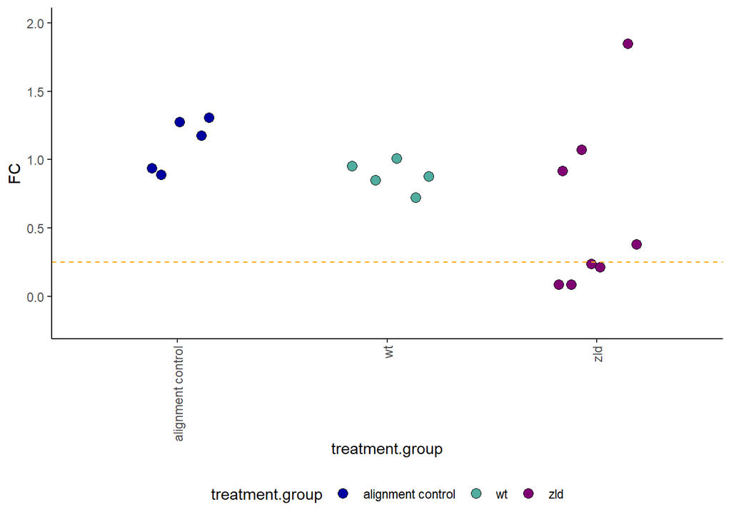

```r
color.code <-c("wt" = "#50ad9f","alignment control" = "#0000A2", "zld"="#800074")

 zld.fc.table %>% ggplot(., aes(x= treatment.group, y = FC, fill = treatment.group)) +
  geom_jitter(size = 3,shape = 21, color = "black",width=0.2)+
  scale_fill_manual(values = color.code) +
  ylim(-0.2,2) +
  geom_hline(yintercept = 0.25, linetype = 'dashed', col = 'orange') +
theme(axis.text.x = element_text(angle = 90, vjust = 0.5, hjust=1),
        axis.line = element_line(colour = "black"),
        legend.position = "bottom",
        panel.background = element_blank(),
        panel.grid.major = element_blank(),
    panel.grid.minor = element_blank())
```

Plot CPM only

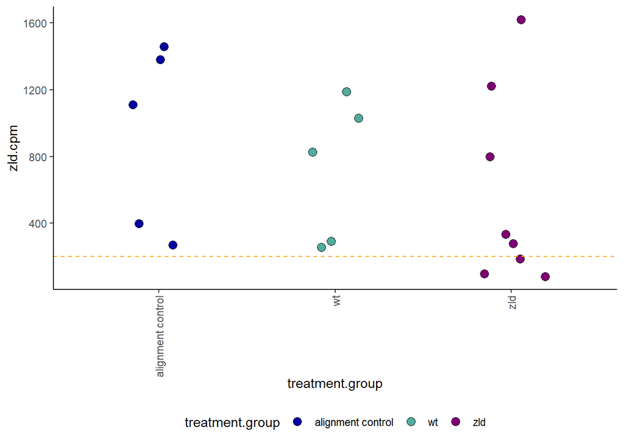

```r
color.code <-c("wt" = "#50ad9f","alignment control" = "#0000A2", "zld"="#800074")

 zld.fc.table %>% ggplot(., aes(x= treatment.group, y = zld.cpm, fill = treatment.group)) +
  geom_jitter(size = 3,shape = 21, color = "black",width=0.2)+
  scale_fill_manual(values = color.code) +
  geom_hline(yintercept = 200, linetype = 'dashed', col = 'orange') +
theme(axis.text.x = element_text(angle = 90, vjust = 0.5, hjust=1),
        axis.line = element_line(colour = "black"),
        legend.position = "bottom",
        panel.background = element_blank(),
        panel.grid.major = element_blank(),
    panel.grid.minor = element_blank())
```

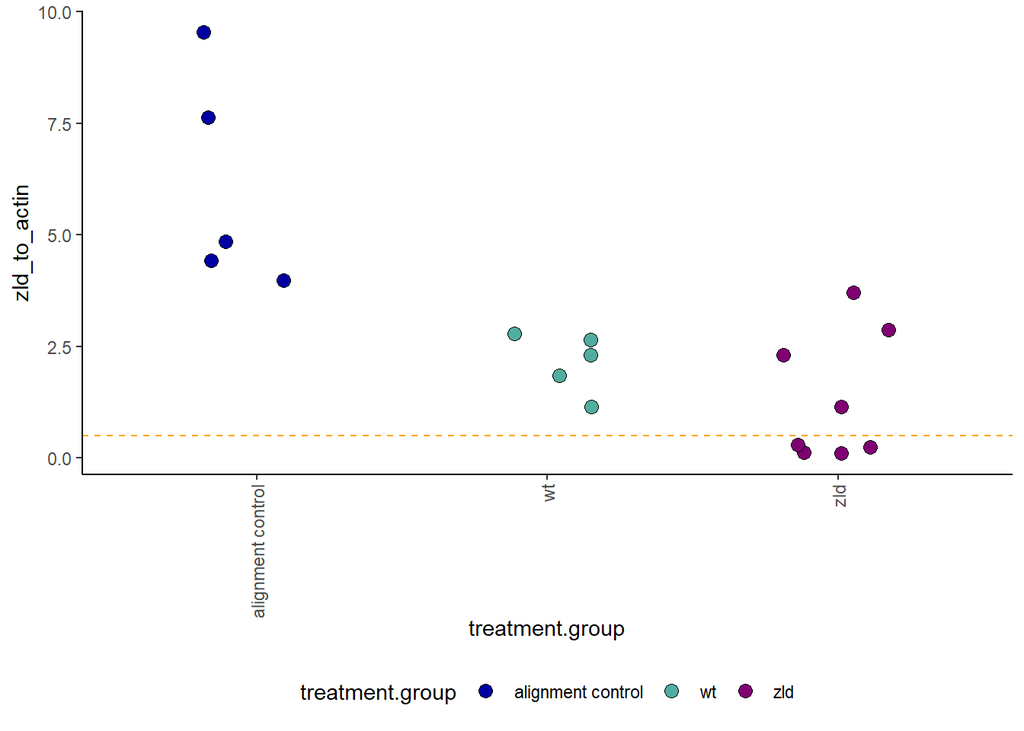

```r
zld.fc.table<-zld.fc.table%>% mutate(.,zld_to_actin= zld.cpm/actin.cpm)
color.code <-c("wt" = "#50ad9f","alignment control" = "#0000A2", "zld"="#800074")

 zld.fc.table %>% ggplot(., aes(x= treatment.group, y = zld_to_actin, fill = treatment.group)) +
  geom_jitter(size = 3,shape = 21, color = "black",width=0.2)+
  scale_fill_manual(values = color.code) +
  geom_hline(yintercept = 0.5, linetype = 'dashed', col = 'orange') +
theme(axis.text.x = element_text(angle = 90, vjust = 0.5, hjust=1),
        axis.line = element_line(colour = "black"),
        legend.position = "bottom",
        panel.background = element_blank(),
        panel.grid.major = element_blank(),
    panel.grid.minor = element_blank())
```

4 Cal-zld RNAi embryos have a FC < 0.25

### 2. DE analysis Setup

Add a genotype column to coldata. For the zld treatment group an embryo’s genotype will be either zld, intKD or noKD based on the FC; FC < 0.25 is a KD (zld), 0.25 < FC < 0.5 is an intermediate KD (intKD) and FC > 0.5 is no KD (noKD). For the control treatment groups, genotype is equal to the treatment group, but written in short hand.

Starting with the zld.coldata.rna.

```r
zld.coldata.rna <- cbind(zld.coldata.rna, FC = zld.fc.table$FC)

zld.coldata.rna <- zld.coldata.rna %>%
  mutate(genotype = case_when(
  treatment.group == "wt" ~ "wt",
  treatment.group == "alignment control" ~ "ac",
  #(treatment.group == "zld" & FC<1.5&FC > 0.5) ~ "noKD",
  #(treatment.group == "zld" & FC>1.5) ~ "outlier",
  (treatment.group == "zld" & FC > 0.5) ~ "noKD",
  (treatment.group == "zld" & 0.25 < FC & FC < 0.5) ~ "intKD",
   (treatment.group == "zld" & FC < 0.25) ~ "zld")) %>%
  relocate(.,genotype,.after = treatment.group)

#convert all columns to factors
for (i in 1:ncol(zld.coldata.rna)){
    zld.coldata.rna[, i] = as.factor(zld.coldata.rna[, i])
}

# set ref levels
zld.coldata.rna$treatment.group <- relevel(zld.coldata.rna$treatment.group,ref = "alignment control")

zld.coldata.rna$genotype <- relevel(zld.coldata.rna$genotype,ref = "ac")

zld.coldata.rna$Experiment.Date <- relevel(zld.coldata.rna$Experiment.Date,ref = "231213")

head(zld.coldata.rna)
```

```
##    Sample.name.full embryo   treatment.group genotype alignment injection Stage
## 1 wt.1.LNC14.zldKD1      1                wt       wt     FALSE      none LNC14
## 2 wt.2.LNC14.zldKD1      2                wt       wt     FALSE      none LNC14
## 3 ac.1.LNC14.zldKD1      3 alignment control       ac      TRUE      none LNC14
## 4 ac.2.LNC14.zldKD1      4 alignment control       ac      TRUE      none LNC14
## 5 wt.3.LNC14.zldKD2      5                wt       wt     FALSE      none LNC14
## 6 wt.4.LNC14.zldKD2      6                wt       wt     FALSE      none LNC14
##   Dev.time Experiment Experiment.Date ATAC.and.RNA   TDE.ref.lot.num
## 1    7h50m      zldKD          231211          yes 20034211/20728110
## 2    7h51m      zldKD          231211          yes 20034211/20728110
## 3    7h45m      zldKD          231211          yes 20034211/20728110
## 4    7h46m      zldKD          231211          yes 20034211/20728110
## 5    7h45m      zldKD          231213          yes 20034211/20728110
## 6    7h46m      zldKD          231213          yes 20034211/20728110
##     sample.id.atac      sample.id.rna         sample.id.rna.2
## 1 23003FL-14-01-01 SB-USO-RSL54-EA101 SB-USO-RSL54-EA101-FC02
## 2 23003FL-14-01-02 SB-USO-RSL54-EA102 SB-USO-RSL54-EA102-FC02
## 3 23003FL-14-01-03 SB-USO-RSL54-EA103 SB-USO-RSL54-EA103-FC02
## 4 23003FL-14-01-04 SB-USO-RSL54-EA104 SB-USO-RSL54-EA104-FC02
## 5 23003FL-14-01-08 SB-USO-RSL54-EA108 SB-USO-RSL54-EA108-FC02
## 6 23003FL-14-01-09 SB-USO-RSL54-EA109 SB-USO-RSL54-EA109-FC02
##   instrument.atac.data instrument.rna.data                FC
## 1       NovaSeq X Plus          NovaSeq X2 0.849705429886521
## 2       NovaSeq X Plus          NovaSeq X2 0.954107299559685
## 3       NovaSeq X Plus          NovaSeq X2  1.30513341667451
## 4       NovaSeq X Plus          NovaSeq X2 0.891053853879287
## 5       NovaSeq X Plus          NovaSeq X2 0.876034073379273
## 6       NovaSeq X Plus          NovaSeq X2  1.01065154806857
```

Add the column names of the counts matrix to the rownames of the coldata. Double check that all match.

```r
#cbind(as.character(zld.coldata.rna$Sample.name.full),colnames(zld.counts.rna))

rownames(zld.coldata.rna) <- colnames(zld.counts.rna)

all(colnames(zld.counts.rna) == rownames(zld.coldata.rna))
```

```
## [1] TRUE
```

Now repeat for the coldata.atac

```r
zld.coldata.atac <- cbind(zld.coldata.atac, FC = zld.fc.table$FC)

zld.coldata.atac <- zld.coldata.atac %>%
  mutate(genotype = case_when(
  treatment.group == "wt" ~ "wt",
  treatment.group == "alignment control" ~ "ac",
  #(treatment.group == "zld" & FC<1.5&FC > 0.5) ~ "noKD",
  #(treatment.group == "zld" & FC>1.5) ~ "outlier",
  (treatment.group == "zld" & FC > 0.5) ~ "noKD",
  (treatment.group == "zld" & 0.25 < FC & FC < 0.5) ~ "intKD",
   (treatment.group == "zld" & FC < 0.25) ~ "zld")) %>%
  relocate(.,genotype,.after = treatment.group)

#convert all columns to factors
for (i in 1:ncol(zld.coldata.atac)){
    zld.coldata.atac[, i] = as.factor(zld.coldata.atac[, i])
}


# set ref levels
zld.coldata.atac$treatment.group <- relevel(zld.coldata.atac$treatment.group,ref = "alignment control")

zld.coldata.atac$genotype <- relevel(zld.coldata.atac$genotype,ref = "ac")

zld.coldata.atac$Experiment.Date <- relevel(zld.coldata.atac$Experiment.Date,ref = "231213")


head(zld.coldata.atac)
```

```
##    Sample.name.full embryo   treatment.group genotype alignment injection Stage
## 1 wt.1.LNC14.zldKD1      1                wt       wt     FALSE      none LNC14
## 2 wt.2.LNC14.zldKD1      2                wt       wt     FALSE      none LNC14
## 3 ac.1.LNC14.zldKD1      3 alignment control       ac      TRUE      none LNC14
## 4 ac.2.LNC14.zldKD1      4 alignment control       ac      TRUE      none LNC14
## 5 wt.3.LNC14.zldKD2      5                wt       wt     FALSE      none LNC14
## 6 wt.4.LNC14.zldKD2      6                wt       wt     FALSE      none LNC14
##   Dev.time Experiment Experiment.Date ATAC.and.RNA   TDE.ref.lot.num
## 1    7h50m      zldKD          231211          yes 20034211/20728110
## 2    7h51m      zldKD          231211          yes 20034211/20728110
## 3    7h45m      zldKD          231211          yes 20034211/20728110
## 4    7h46m      zldKD          231211          yes 20034211/20728110
## 5    7h45m      zldKD          231213          yes 20034211/20728110
## 6    7h46m      zldKD          231213          yes 20034211/20728110
##     sample.id.atac      sample.id.rna         sample.id.rna.2
## 1 23003FL-14-01-01 SB-USO-RSL54-EA101 SB-USO-RSL54-EA101-FC02
## 2 23003FL-14-01-02 SB-USO-RSL54-EA102 SB-USO-RSL54-EA102-FC02
## 3 23003FL-14-01-03 SB-USO-RSL54-EA103 SB-USO-RSL54-EA103-FC02
## 4 23003FL-14-01-04 SB-USO-RSL54-EA104 SB-USO-RSL54-EA104-FC02
## 5 23003FL-14-01-08 SB-USO-RSL54-EA108 SB-USO-RSL54-EA108-FC02
## 6 23003FL-14-01-09 SB-USO-RSL54-EA109 SB-USO-RSL54-EA109-FC02
##   instrument.atac.data instrument.rna.data                FC
## 1       NovaSeq X Plus          NovaSeq X2 0.849705429886521
## 2       NovaSeq X Plus          NovaSeq X2 0.954107299559685
## 3       NovaSeq X Plus          NovaSeq X2  1.30513341667451
## 4       NovaSeq X Plus          NovaSeq X2 0.891053853879287
## 5       NovaSeq X Plus          NovaSeq X2 0.876034073379273
## 6       NovaSeq X Plus          NovaSeq X2  1.01065154806857
```

Create the counts matrix for zldKD ATAC-seq data

```r
zld.counts.atac <- lapply(zldkd.openreads, function(x) countOverlaps(peaks.32157, x)) # count open reads that overlap with a peak
zld.counts.atac <- do.call("cbind", zld.counts.atac) # coerce to a matrix

head(zld.counts.atac[,1:6])
```

```
##                          wt.1.LNC14.zldKD1.23003FL.14.01.01
## scaffold_1:39064-39403                                   88
## scaffold_1:41080-41159                                   20
## scaffold_1:46323-46446                                    6
## scaffold_1:113573-113903                                620
## scaffold_1:114565-114639                                 44
## scaffold_1:116022-116187                                228
##                          wt.2.LNC14.zldKD1.23003FL.14.01.02
## scaffold_1:39064-39403                                  101
## scaffold_1:41080-41159                                   15
## scaffold_1:46323-46446                                   10
## scaffold_1:113573-113903                                604
## scaffold_1:114565-114639                                 68
## scaffold_1:116022-116187                                280
##                          ac.1.LNC14.zldKD1.23003FL.14.01.03
## scaffold_1:39064-39403                                   52
## scaffold_1:41080-41159                                    8
## scaffold_1:46323-46446                                    1
## scaffold_1:113573-113903                                377
## scaffold_1:114565-114639                                 19
## scaffold_1:116022-116187                                172
##                          ac.2.LNC14.zldKD1.23003FL.14.01.04
## scaffold_1:39064-39403                                  100
## scaffold_1:41080-41159                                   11
## scaffold_1:46323-46446                                   13
## scaffold_1:113573-113903                                526
## scaffold_1:114565-114639                                 32
## scaffold_1:116022-116187                                285
##                          wt.3.LNC14.zldKD2.23003FL.14.01.08
## scaffold_1:39064-39403                                   68
## scaffold_1:41080-41159                                   12
## scaffold_1:46323-46446                                    7
## scaffold_1:113573-113903                                426
## scaffold_1:114565-114639                                 40
## scaffold_1:116022-116187                                199
##                          wt.4.LNC14.zldKD2.23003FL.14.01.09
## scaffold_1:39064-39403                                   75
## scaffold_1:41080-41159                                   21
## scaffold_1:46323-46446                                    2
## scaffold_1:113573-113903                                526
## scaffold_1:114565-114639                                 60
## scaffold_1:116022-116187                                272
```

Add the column names of the counts matrix to the rownames of the coldata. Double check that all match.

```r
#cbind(as.character(zld.coldata.atac$Sample.name.full),colnames(zld.counts.atac))

rownames(zld.coldata.atac) <- colnames(zld.counts.atac)

all(colnames(zld.counts.atac) == rownames(zld.coldata.atac))
```

```
## [1] TRUE
```

##### Filter counts

Before proceeding with the DESeq2 analysis, the RNA-seq counts need to be filtered to remove noisy and no count genes. This will be done by plotting the distribution of counts, which will show the true distribution and the noise. A cutoff based on the count distribution will be applied to remove any counts below those values.

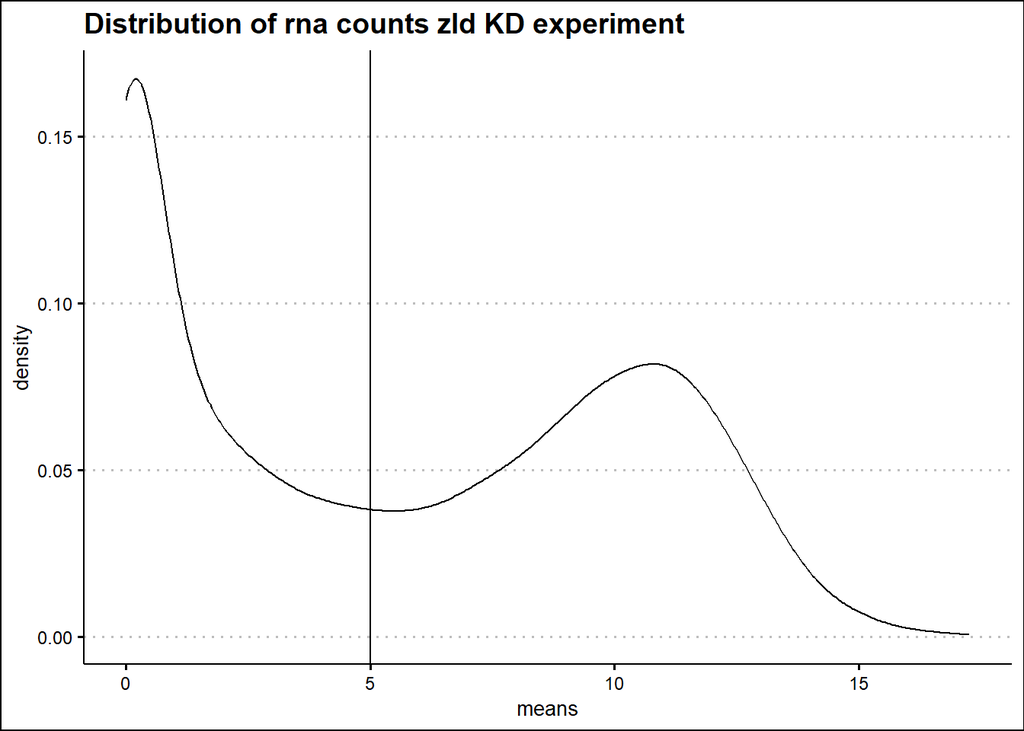

```r
data.frame(means = log2(rowMeans(zld.counts.rna)+1)) %>%
  ggplot(aes(means)) +
  geom_density() +
  geom_vline(xintercept = 5) +
  theme_clean() +
  labs(title = 'Distribution of rna counts zld KD experiment')
```

Remove any gene counts below 2^5

```r
zld.counts.rna <- zld.counts.rna[which(rowMeans(zld.counts.rna) > 2^5),]
```

Again check that the colnames in the counts matrix match the rownames in coldata.

```r
all(colnames(zld.counts.rna) == rownames(zld.coldata.rna))
```

```
## [1] TRUE
```

##### Filter ATAC counts

Before running DESeq2 we need to get rid of any peaks that have low or noisy counts.

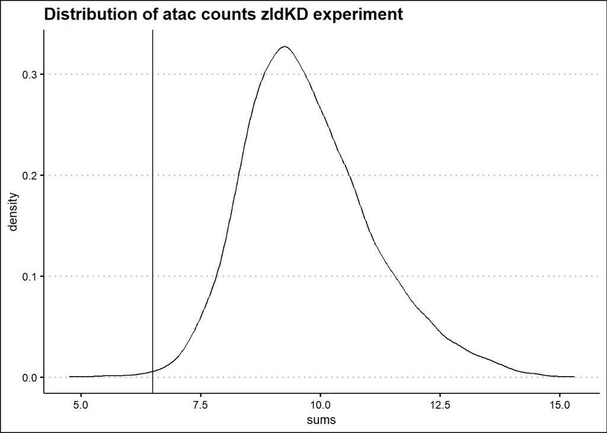

```r
data.frame(sums = log2(rowSums(zld.counts.atac)+1)) %>%
  ggplot(aes(sums)) +
  geom_density() +
  geom_vline(xintercept = 6.5) +
  theme_clean() +
  labs(title = 'Distribution of atac counts zldKD experiment')
```

The number of peaks from the distribution above with counts less than 2^6.5.

```r
length(which(rowSums(zld.counts.atac) < 2^6.5))
```

```
## [1] 79
```

The number of peaks with any count value of 0 or 1.

```r
table(apply(zld.counts.atac, 1, function(x) sum(x <= 1)))
```

```
##
##     0     1     2     3     4     5     6     7     8     9    10    11    12
## 26433  3872  1128   351   101    80    32    49    38    57     9     2     1
##    13    14    16    17
##     1     1     1     1
```

We will filter peaks that have any count value of 0 or 1.

```r
zld.counts.atac <- zld.counts.atac[apply(zld.counts.atac, 1, function(x) !any(x <= 1)),]
```

This removes low count peaks form the distribution above.

```r
length(which(rowSums(zld.counts.atac) < 2^6.5))
```

```
## [1] 0
```

Again check that the colnames in the counts matrix match the rownames in coldata.

```r
all(colnames(zld.counts.atac) == rownames(zld.coldata.atac))
```

```
## [1] TRUE
```

### 3.DESeq2 RNA-seq data

The design component for RNA-seq and ATAC-seq the DESeq2 analysis with be the same. The design component will include embryo batch (Experiment.Date) and genotype. We are interested in the changes in expression/accessibility due to genotype, this variable will be added last in the design.

```r
zld.rna.dds <- DESeqDataSetFromMatrix(countData = zld.counts.rna, colData = zld.coldata.rna, design = ~ Experiment.Date + genotype)
zld.rna.dds <- DESeq(zld.rna.dds, parallel = FALSE)
zld.rna.norm_counts <- counts(zld.rna.dds , normalized=TRUE)


noKD_samples <- rownames(colData(zld.rna.dds))[zld.rna.dds$genotype == "noKD"]
AC_samples <- rownames(colData(zld.rna.dds))[zld.rna.dds$genotype == "ac"]

# 3. Get the sample sizes (n)
n_noKD_samples <- length(noKD_samples)
n_AC_samples  <- length(AC_samples )

# 4. Calculate the Standard Error on the normalized counts
# rowSds calculates the sample standard deviation (s), then we divide by sqrt(n)
se_norm_noKD_samples <- sum(rowSds(zld.rna.norm_counts[, noKD_samples]) / sqrt(n_noKD_samples))
se_norm_n_AC_samples <- sum(rowSds(zld.rna.norm_counts[, AC_samples]) / sqrt(n_AC_samples ))
```

Check that the names of results are as expected.

```r
resultsNames(zld.rna.dds)
```

```
## [1] "Intercept"                        "Experiment.Date_231211_vs_231213"
## [3] "Experiment.Date_231218_vs_231213" "Experiment.Date_240222_vs_231213"
## [5] "genotype_intKD_vs_ac"             "genotype_noKD_vs_ac"
## [7] "genotype_wt_vs_ac"                "genotype_zld_vs_ac"
```

Dispersion estimates. Take a look at dispersion to makes sure that the data fitting looks reasonable.

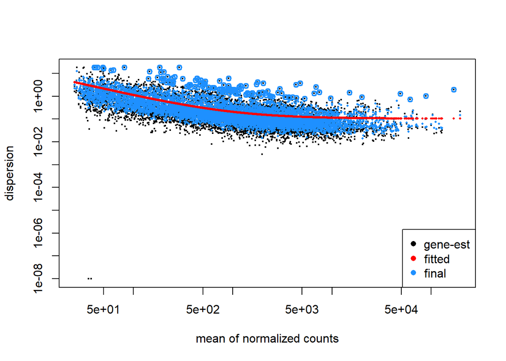

```r
plotDispEsts(zld.rna.dds)
```

Results

```r
res.zldnoKD.ac.rna<-as.data.frame(results(zld.rna.dds, contrast = c("genotype", "noKD", "ac"), independentFiltering = FALSE))
```

Add a column, “Sig”, indicating if a gene is significantly differential expressed.

Significant DEGs will be genes with a LFC >= 1 or LFC <=-1 and a padj <= 0.05

```r
res.zldnoKD.ac.rna <- res.zldnoKD.ac.rna %>% mutate(.,Sig = if_else((padj <= 0.05 & abs(log2FoldChange) >=1),TRUE,FALSE))
```

Add a column “Change”, indicating if the change in expression was up or down.

```r
 res.zldnoKD.ac.rna <- res.zldnoKD.ac.rna %>%
  mutate(Change = case_when(
  is.na(log2FoldChange) == TRUE | Sig == FALSE ~ "NA",
  log2FoldChange < 0 ~ "DOWN",
  log2FoldChange > 0 ~ "UP"))
```

Add a column, “gene.locus”, with the gene name.

```r
res.zldnoKD.ac.rna <- res.zldnoKD.ac.rna %>% mutate(gene.locus = rownames(.))
```

MA plot

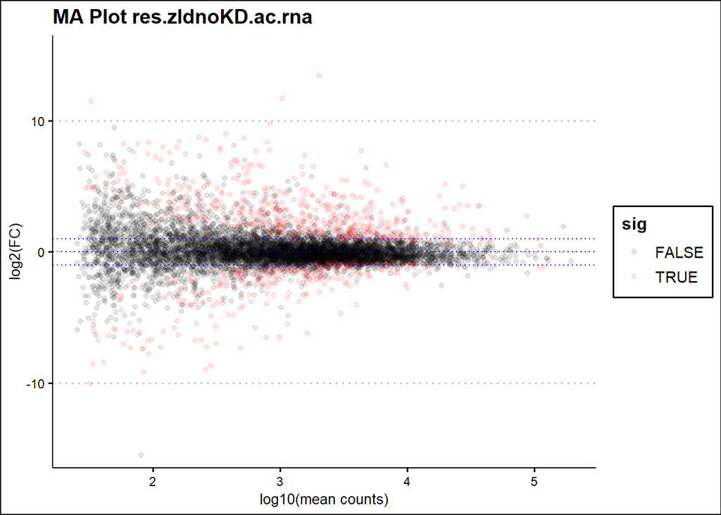

```r
res.zldnoKD.ac.rna %>%
  mutate(sig = padj <= 0.05) %>%
  ggplot(aes(x = log10(baseMean), y = log2FoldChange, color = sig)) +
  geom_point(alpha = 0.1) +
  coord_cartesian(ylim = c(-15,15)) +
  scale_color_manual(values = c("TRUE" = "red", "FALSE" =  "black")) +
  geom_hline(yintercept = c(0,1,-1), linetype = 'dotted', color = 'blue') +
  theme_clean() +
  labs(title = "MA Plot res.zldnoKD.ac.rna",
       x = "log10(mean counts)",
       y = "log2(FC)")
```

Lets plot the result and highlight significant DEGs. For this plot sig DEGs will be highlighted, and the number of DEGs that go up or down will be quantified.

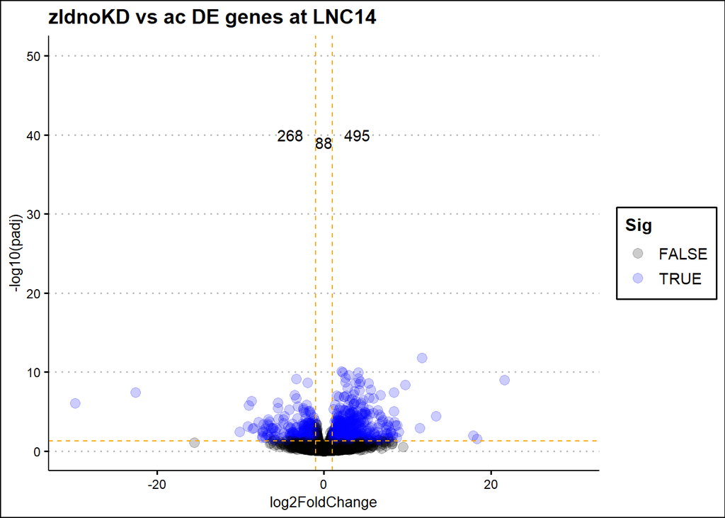

```r
zld.noKD.vol.rna <- res.zldnoKD.ac.rna %>%
  ggplot(aes(x = log2FoldChange, y = -log10(padj), color = Sig)) +
  geom_point(alpha = 0.2, size = 3) +
  coord_cartesian(xlim =c(-30,30),ylim = c(0,50)) +
  geom_hline(yintercept = -log10(0.05), linetype = 'dashed', col = 'orange') +
  geom_vline(xintercept = log2(c(0.5,2)), linetype = 'dashed', col = 'orange') +
  scale_color_manual(values = c("TRUE" = 'blue', "FALSE" = "black")) +
  theme_clean() +
  labs(title = 'zldnoKD vs ac DE genes at LNC14')

zld.noKD.vol.rna  +
  annotate(geom = "text", x = -4, y = 40, label = length(which(res.zldnoKD.ac.rna$padj <= 0.05 & res.zldnoKD.ac.rna$log2FoldChange <= -1))) +
  annotate(geom = "text", x = 4, y = 40, label = length(which(res.zldnoKD.ac.rna$padj <= 0.05 & res.zldnoKD.ac.rna$log2FoldChange >= 1))) +
  annotate(geom = 'text', x = 0, y = 39, label = length(which(res.zldnoKD.ac.rna$padj <= 0.05 & abs(res.zldnoKD.ac.rna$log2FoldChange) < 1)))
```

##### WT vs alignment control DE genes

```r
res.WT.ac.rna<-as.data.frame(results(zld.rna.dds, contrast = c("genotype", "wt", "ac"), independentFiltering = FALSE))
```

Add a column, “Sig”, indicating if a gene is significantly differential expressed.

Significant DEGs will be genes with a LFC >= 1 or LFC <=-1 and a padj <= 0.05

```r
res.WT.ac.rna <- res.WT.ac.rna %>% mutate(.,Sig = if_else((padj <= 0.05 & abs(log2FoldChange) >=1),TRUE,FALSE))
```

Add a column “Change”, indicating if the change in expression was up or down.

```r
 res.WT.ac.rna <- res.WT.ac.rna%>%
  mutate(Change = case_when(
  is.na(log2FoldChange) == TRUE | Sig == FALSE ~ "NA",
  log2FoldChange < 0 ~ "DOWN",
  log2FoldChange > 0 ~ "UP"))
```

Add a column, “gene.locus”, with the gene name.

```r
res.WT.ac.rna <- res.WT.ac.rna %>% mutate(gene.locus = rownames(.))
```

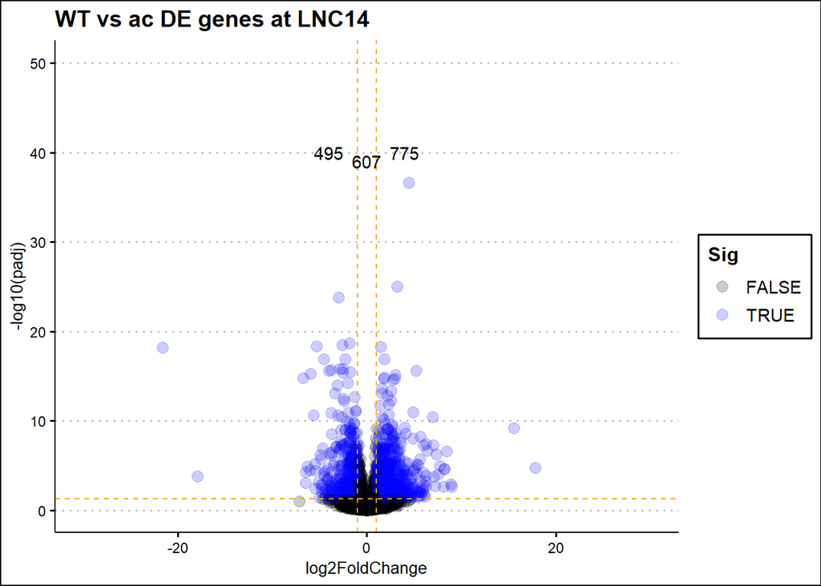

```r
zld.WT.vol.rna <- res.WT.ac.rna %>%
  ggplot(aes(x = log2FoldChange, y = -log10(padj), color = Sig)) +
  geom_point(alpha = 0.2, size = 3) +
  coord_cartesian(xlim =c(-30,30),ylim = c(0,50)) +
  geom_hline(yintercept = -log10(0.05), linetype = 'dashed', col = 'orange') +
  geom_vline(xintercept = log2(c(0.5,2)), linetype = 'dashed', col = 'orange') +
  scale_color_manual(values = c("TRUE" = 'blue', "FALSE" = "black")) +
  theme_clean() +
  labs(title = 'WT vs ac DE genes at LNC14')

zld.WT.vol.rna   +
  annotate(geom = "text", x = -4, y = 40, label = length(which(res.WT.ac.rna$padj <= 0.05 & res.WT.ac.rna$log2FoldChange <= -1))) +
  annotate(geom = "text", x = 4, y = 40, label = length(which(res.WT.ac.rna$padj <= 0.05 & res.WT.ac.rna$log2FoldChange >= 1))) +
  annotate(geom = 'text', x = 0, y = 39, label = length(which(res.WT.ac.rna$padj <= 0.05 & abs(res.WT.ac.rna$log2FoldChange) < 1)))
```

##### zldn vs alignment control DE genes

```r
res.zld.ac.rna <- as.data.frame(results(zld.rna.dds, contrast = c("genotype", "zld", "ac"), independentFiltering = FALSE))
```

Add a column, “Sig”, indicating if a gene is significantly differential expressed.

Significant DEGs will be genes with a LFC >= 1 or LFC <=-1 and a padj <= 0.05

```r
res.zld.ac.rna <- res.zld.ac.rna %>% mutate(.,Sig = if_else((padj <= 0.05 & abs(log2FoldChange) >=1),TRUE,FALSE))
```

Add a column “Change”, indicating if the change in expression was up or down.

```r
 res.zld.ac.rna <- res.zld.ac.rna %>%
  mutate(Change = case_when(
  is.na(log2FoldChange) == TRUE | Sig == FALSE ~ "NA",
  log2FoldChange < 0 ~ "DOWN",
  log2FoldChange > 0 ~ "UP"))
```

Add a column, “gene.locus”, with the gene name.

```r
res.zld.ac.rna <- res.zld.ac.rna %>% mutate(gene.locus = rownames(.))
```

MA plot

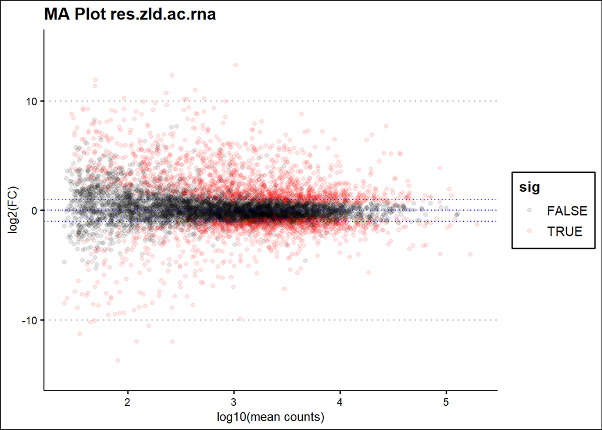

```r
res.zld.ac.rna %>%
  mutate(sig = padj <= 0.05) %>%
  ggplot(aes(x = log10(baseMean), y = log2FoldChange, color = sig)) +
  geom_point(alpha = 0.1) +
  coord_cartesian(ylim = c(-15,15)) +
  scale_color_manual(values = c("TRUE" = "red", "FALSE" =  "black")) +
  geom_hline(yintercept = c(0,1,-1), linetype = 'dotted', color = 'blue') +
  theme_clean() +
  labs(title = "MA Plot res.zld.ac.rna",
       x = "log10(mean counts)",
       y = "log2(FC)")
```

Lets plot the result and highlight significant DEGs. For this plot sig DEGs will be highlighted, and the number of DEGs that go up or down will be quantified.

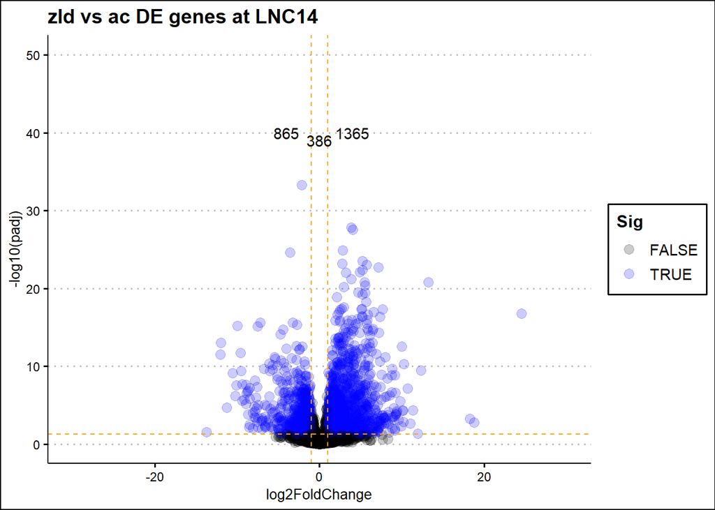

```r
zld.ac.vol.rna <- res.zld.ac.rna %>%
  ggplot(aes(x = log2FoldChange, y = -log10(padj), color = Sig)) +
  geom_point(alpha = 0.2, size = 3) +
  coord_cartesian(xlim =c(-30,30),ylim = c(0,50)) +
  geom_hline(yintercept = -log10(0.05), linetype = 'dashed', col = 'orange') +
  geom_vline(xintercept = log2(c(0.5,2)), linetype = 'dashed', col = 'orange') +
  scale_color_manual(values = c("TRUE" = 'blue', "FALSE" = "black")) +
  theme_clean() +
  labs(title = 'zld vs ac DE genes at LNC14')

zld.ac.vol.rna  +
  annotate(geom = "text", x = -4, y = 40, label = length(which(res.zld.ac.rna$padj <= 0.05 & res.zld.ac.rna$log2FoldChange <= -1))) +
  annotate(geom = "text", x = 4, y = 40, label = length(which(res.zld.ac.rna$padj <= 0.05 & res.zld.ac.rna$log2FoldChange >= 1))) +
  annotate(geom = 'text', x = 0, y = 39, label = length(which(res.zld.ac.rna$padj <= 0.05 & abs(res.zld.ac.rna$log2FoldChange) < 1)))
```

```r
res.zld.noKD.rna <- as.data.frame(results(zld.rna.dds, contrast = c("genotype", "zld", "noKD"), independentFiltering = FALSE))
```

Add a column, “Sig”, indicating if a gene is significantly differential expressed.

Significant DEGs will be genes with a LFC >= 1 or LFC <=-1 and a padj <= 0.05

```r
res.zld.noKD.rna <- res.zld.noKD.rna  %>% mutate(.,Sig = if_else((padj <= 0.05 & abs(log2FoldChange) >=1),TRUE,FALSE))
```

Add a column “Change”, indicating if the change in expression was up or down.

```r
 res.zld.noKD.rna  <- res.zld.noKD.rna  %>%
  mutate(Change = case_when(
  is.na(log2FoldChange) == TRUE | Sig == FALSE ~ "NA",
  log2FoldChange < 0 ~ "DOWN",
  log2FoldChange > 0 ~ "UP"))
```

Add a column, “gene.locus”, with the gene name.

```r
res.zld.noKD.rna <- res.zld.noKD.rna  %>% mutate(gene.locus = rownames(.))
```

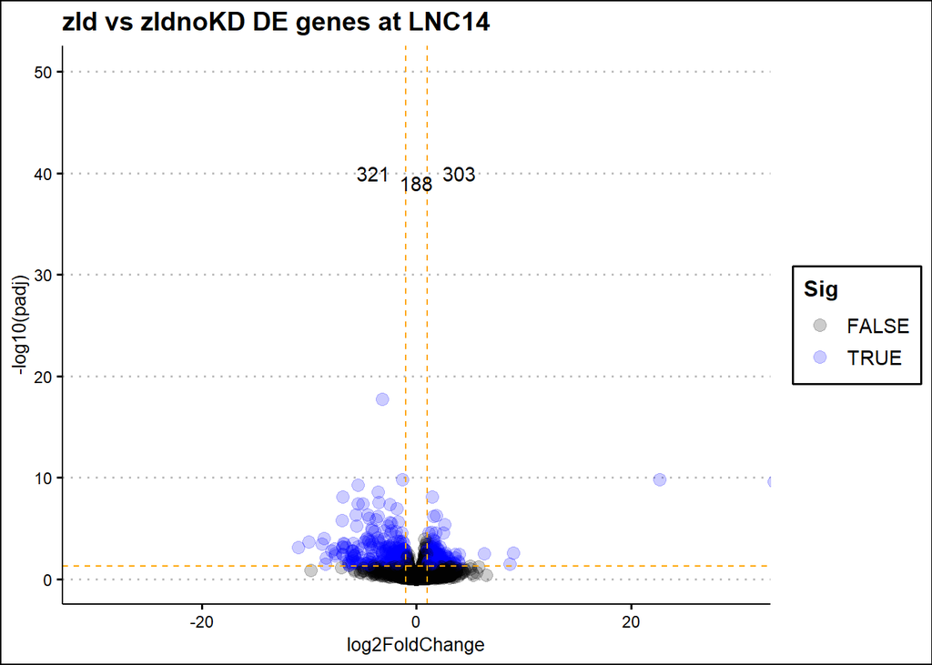

```r
zld.zldnoKD.vol.rna <- res.zld.noKD.rna  %>%
  ggplot(aes(x = log2FoldChange, y = -log10(padj), color = Sig)) +
  geom_point(alpha = 0.2, size = 3) +
  coord_cartesian(xlim =c(-30,30),ylim = c(0,50)) +
  geom_hline(yintercept = -log10(0.05), linetype = 'dashed', col = 'orange') +
  geom_vline(xintercept = log2(c(0.5,2)), linetype = 'dashed', col = 'orange') +
  scale_color_manual(values = c("TRUE" = 'blue', "FALSE" = "black")) +
  theme_clean() +
  labs(title = 'zld vs zldnoKD DE genes at LNC14')

zld.zldnoKD.vol.rna  +
  annotate(geom = "text", x = -4, y = 40, label = length(which(res.zld.noKD.rna$padj <= 0.05 & res.zld.noKD.rna$log2FoldChange <= -1))) +
  annotate(geom = "text", x = 4, y = 40, label = length(which(res.zld.noKD.rna$padj <= 0.05 & res.zld.noKD.rna$log2FoldChange >= 1))) +
  annotate(geom = 'text', x = 0, y = 39, label = length(which(res.zld.noKD.rna$padj <= 0.05 & abs(res.zld.noKD.rna$log2FoldChange) < 1)))
```

##### Save zld RNA DEG results

```r
res.zld.ac.rna<-res.zld.ac.rna%>% mutate(best_hit_in_Dme=blast.data[gene.locus,]$gene_name)
res.zld.noKD.rna<-res.zld.noKD.rna%>% mutate(best_hit_in_Dme=blast.data[gene.locus,]$gene_name)
res.zldnoKD.ac.rna<-res.zldnoKD.ac.rna%>% mutate(best_hit_in_Dme=blast.data[gene.locus,]$gene_name)

write_xlsx(list("zldKD.ac.rna"=res.zld.ac.rna,"zldKD.zldnoKD.rna"=res.zld.noKD.rna,"zldnoKD.ac.rna"=res.zldnoKD.ac.rna), paste0(zld.results.folder, "zld_degs_all.xlsx"))
```

### 4.DESeq2 ATAC-seq data

```r
zld.atac.dds <- DESeqDataSetFromMatrix(countData = zld.counts.atac, colData = zld.coldata.atac, design = ~ Experiment.Date + genotype)
zld.atac.dds <- DESeq(zld.atac.dds, parallel = FALSE)
```

Check that the names of results are as expected.

```r
resultsNames(zld.atac.dds)
```

```
## [1] "Intercept"                        "Experiment.Date_231211_vs_231213"
## [3] "Experiment.Date_231218_vs_231213" "Experiment.Date_240222_vs_231213"
## [5] "genotype_intKD_vs_ac"             "genotype_noKD_vs_ac"
## [7] "genotype_wt_vs_ac"                "genotype_zld_vs_ac"
```

Dispersion estimates. Take a look at dispersion to makes sure that the data fitting looks reasonable.

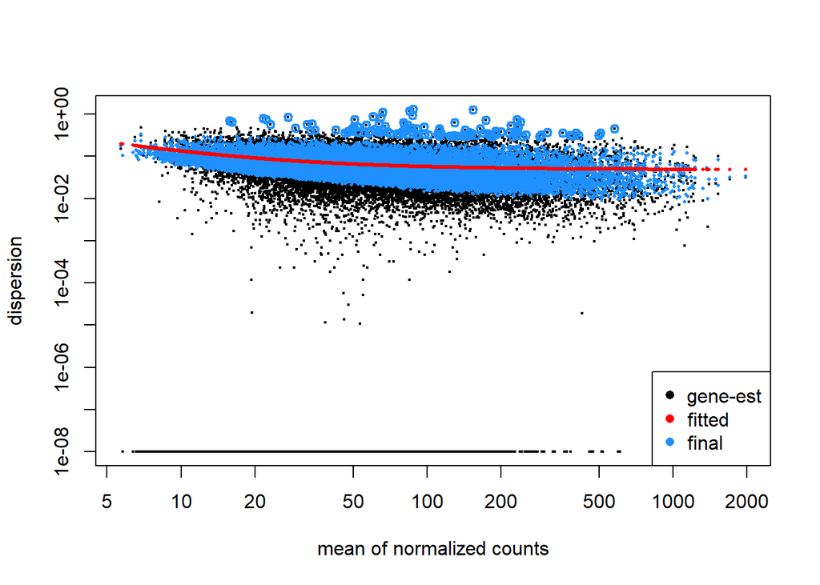

```r
plotDispEsts(zld.atac.dds)
```

##### zldKD vs alignment control DA peaks

```r
res.zld.ac.atac <- as.data.frame(results(zld.atac.dds, contrast = c("genotype", "zld", "ac"), independentFiltering = FALSE))
```

Add a column, “Sig”, indicating if a peak has undergone a significantly change in accessibility.

Significant DAPs will be peaks with a LFC >= 1 or LFC <=-1 and a padj <= 0.05

```r
res.zld.ac.atac <- res.zld.ac.atac %>% mutate(.,Sig = if_else((padj <= 0.05 & abs(log2FoldChange) >=1),TRUE,FALSE))
```

Add a column, “Change”, indicating if the change in accessibility was up or down.

```r
res.zld.ac.atac <- res.zld.ac.atac %>%
  mutate(Change = case_when(is.na(log2FoldChange) == TRUE | Sig == FALSE ~ "NA",
  log2FoldChange < 0 ~ "DOWN",
  log2FoldChange > 0 ~ "UP"))
```

Add a column, “peak.name”, with the peak name.

```r
res.zld.ac.atac <- res.zld.ac.atac %>% mutate(.,peak.name=rownames(.))
res.zld.ac.atac$gene_locus<-peak_annotation[match(res.zld.ac.atac$peak.name, row.names(peak_annotation)),]$geneId
```

MA plot

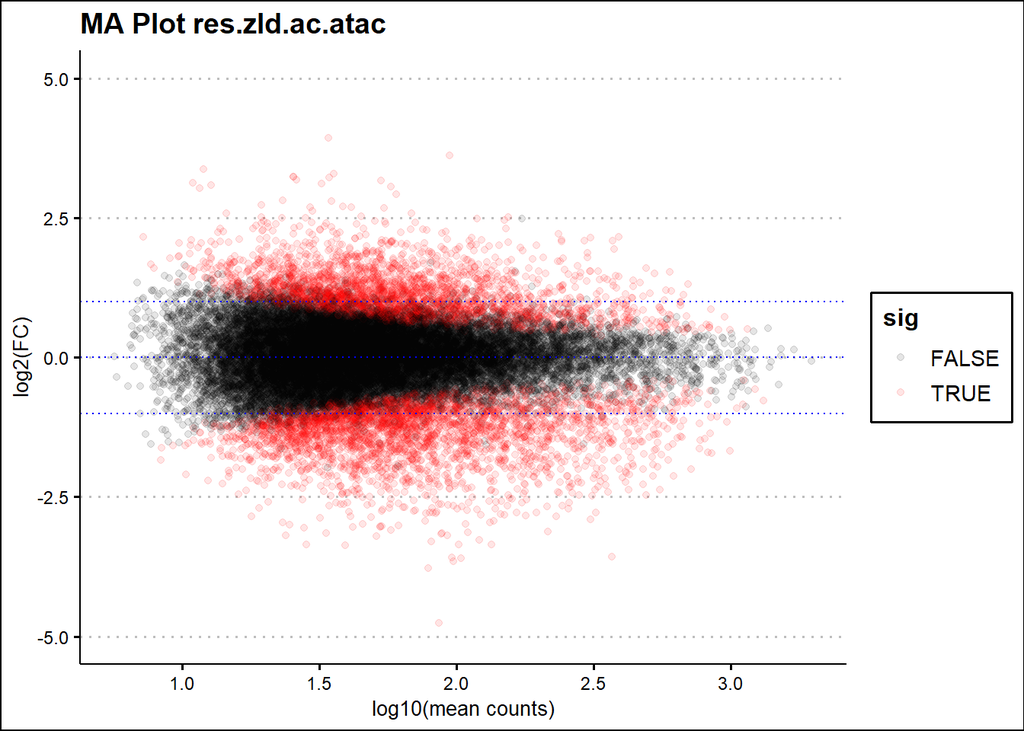

```r
res.zld.ac.atac %>%
  mutate(sig = padj <= 0.05) %>%
  ggplot(aes(x = log10(baseMean), y = log2FoldChange, color = sig)) +
  geom_point(alpha = 0.1) +
  coord_cartesian(ylim = c(-5,5)) +
  scale_color_manual(values = c("TRUE" = "red", "FALSE" =  "black")) +
  geom_hline(yintercept = c(0,1,-1), linetype = 'dotted', color = 'blue') +
  theme_clean() +
  labs(title = "MA Plot res.zld.ac.atac",
       x = "log10(mean counts)",
       y = "log2(FC)")
```

Lets plot the result and highlight significant DAPs. For this plot sig DAPs will be highlighted, and the number of DAPs that go up or down will be quantified. The size of each data point will correspond to the intensity of the peak.

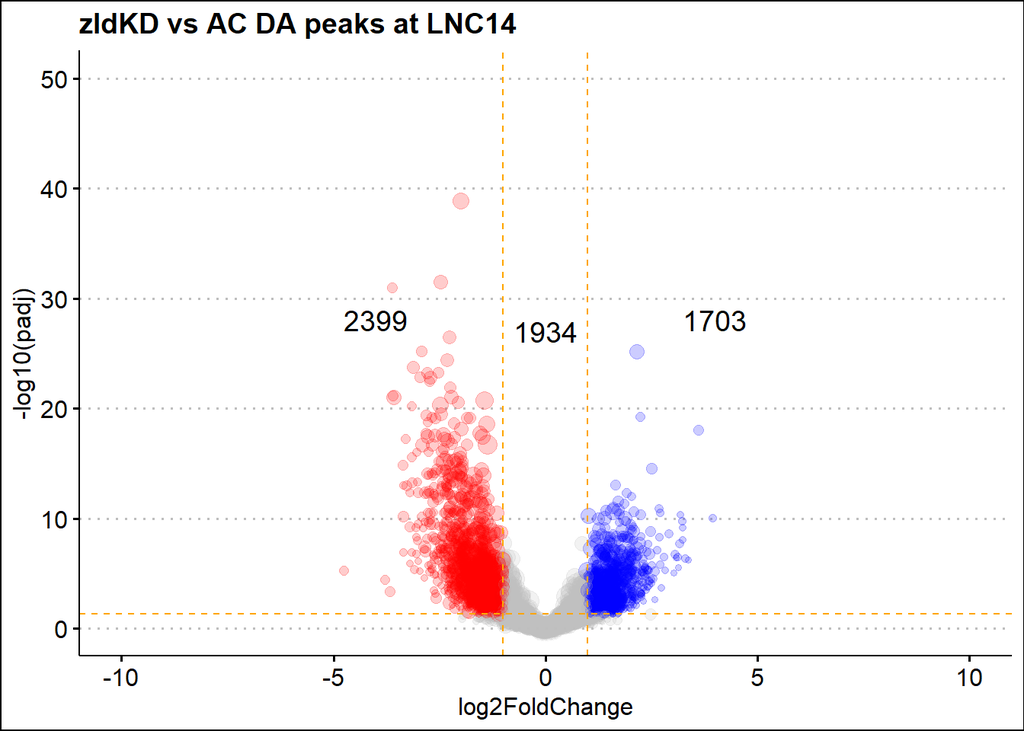

```r
#pdf(file = "../vol_zldvsAC.pdf", width = 5,height = 5)

zld.ac.vol.atac <- res.zld.ac.atac %>%
  mutate(mean.intensity = baseMean/max(baseMean)) %>%
  ggplot(aes(x = log2FoldChange, y = -log10(padj), color = Change, size = mean.intensity)) +
  geom_point(alpha = 0.2) +
  coord_cartesian(xlim = c(-10, 10), ylim = c(0, 50)) +
  geom_hline(yintercept = -log10(0.05), linetype = 'dashed', col = 'orange') +
  geom_vline(xintercept = log2(c(0.5, 2)), linetype = 'dashed', col = 'orange') +
  scale_color_manual(values = c("DOWN" = 'red', "UP" = "blue", "NA" = "grey")) +

  theme_clean(base_size = 12) + theme(legend.position = "none")+

  # Optional: Fine-tune specific elements if base_size isn't enough
  theme(
    plot.title = element_text(size = 14),
    axis.title = element_text(size = 12),
    axis.text = element_text(size = 12)
  ) +
  labs(title = 'zldKD vs AC DA peaks at LNC14')


zld.ac.vol.atac  +

  annotate(geom = "text", x = -4, y = 28,
           label = length(which(res.zld.ac.atac$padj <= 0.05 & res.zld.ac.atac$log2FoldChange <= -1)),
           size = 5) +

  annotate(geom = "text", x = 4, y = 28,
           label = length(which(res.zld.ac.atac$padj <= 0.05 & res.zld.ac.atac$log2FoldChange >= 1)),
           size = 5) +

  annotate(geom = 'text', x = 0, y = 27,
           label = length(which(res.zld.ac.atac$padj <= 0.05 & abs(res.zld.ac.atac$log2FoldChange) < 1)),
           size = 5)
```

```r
#dev.off()
```